# Lectures on the Philosophy of Mathematics.Hamkins2020

[figure not shown]

**数学哲学讲座**

**Lectures on the Philosophy of Mathematics**

乔尔·大卫·哈姆金斯

Joel David Hamkins

麻省理工学院出版  
社，马萨诸塞州剑桥，  
英国伦敦

The MIT Press  
Cambridge, Massachusetts  
London, England

© 2020年麻省理工学院

© 2020 Massachusetts Institute of Technology

版权所有。未经出版商书面许可，任何电子或机械方式（包括复印、录音或信息存储和检索）不得以任何形式复制本书内容。

All rights reserved. No part of this book may be reproduced in any form by any electronic or mechanical means (including photocopying, recording, or information storage and retrieval) without permission in writing from the publisher.

国会图书馆出版目录数据

Library of Congress Cataloging-in-Publication Data

姓名：哈姆金斯，乔尔·大卫，作家。

Names: Hamkins, Joel David, author.

标题：数学哲学讲座 / 乔尔·大卫·哈姆金斯。

Title: Lectures on the philosophy of mathematics / Joel David Hamkins.

描述：马萨诸塞州剑桥：麻省理工学院出版社，[2020] |包含参考文献和索引。

Description: Cambridge, Massachusetts: The MIT Press, [2020] | Includes bibliographical references and index.

标识符：LCCN 2020009876 |ISBN 9780262542234（平装）

Identifiers: LCCN 2020009876 | ISBN 9780262542234 (paperback)

科目：LCSH：数学-哲学。

Subjects: LCSH: Mathematics–Philosophy.

分类：LCC QA8.6.H35 2020 |DDC 510.1–dc23

Classification: LCC QA8.6.H35 2020 | DDC 510.1–dc23

LC记录可于 [https:// lccn.loc.gov/2020009876](https://lccn.loc.gov/2020009876)获取

LC record available at https://lccn.loc.gov/2020009876

致所有且仅限于那些不为自己献书的作者。

To all and only those authors who do not dedicate books to themselves.

# 序言 Preface

哲学难题贯穿数学，从数学本体论的基本问题——什么是数字？什么是无限？——关于真理、证明和意义之间关系的问题。图形在几何论证中扮演什么角色？是否存在我们无法构造的数学对象？每个数学问题都能原则上通过计算解决吗？数学的每一个真理都是有原因的吗？每一个数学真理都能被证明吗？

Philosophical conundrums pervade mathematics, from fundamental questions of mathematical ontology—What is a number? What is infinity?—to questions about the relations among truth, proof, and meaning. What is the role of figures in geometric argument? Do mathematical objects exist that we cannot construct? Can every mathematical question be solved in principle by computation? Is every truth of mathematics true for a reason? Can every mathematical truth be proved?

本书是数学哲学的入门书，我们将探讨所有这些问题及更多内容。我从数学领域进入这个领域，在这本书中我努力追求一种全新的数学哲学方法——一种以数学为基础，受数学探究或数学实践驱动的态度。我努力以数学中自然产生的哲学问题来处理。因此，我按数学主题组织了这本书，比如数、无穷、几何和可计算性，并在揭示哲学问题时加入了一些数学论证和基本证明。

This book is an introduction to the philosophy of mathematics, in which we shall consider all these questions and more. I come to the subject from mathematics, and I have strived in this book for what I hope will be a fresh approach to the philosophy of mathematics—one grounded in mathematics, motivated by mathematical inquiry or mathematical practice. I have strived to treat philosophical issues as they arise organically in mathematics. Therefore, I have organized the book by mathematical themes, such as number, infinity, geometry, and computability, and I have included some mathematical arguments and elementary proofs when they bring philosophical issues to light.

柏拉图主义、实在论、逻辑主义、结构主义、形式主义、直觉主义、类型论等哲学立场在各种数学语境中自然产生。从古代毕达哥拉斯的不可通约性和等非理性，到柳维尔构造先验数，与几何中不可构造数的发现相呼应，这为区别对比柏拉图主义与结构主义及其他关于数和数学对象的解释提供了机会。结构主义起源于德德金的算术范畴性定理，随着对实数的范例论述及我们熟悉的其他数学结构的阐述而日益壮大。微积分严谨性的提升，是讨论数学在科学中不可或缺性是否为数学真理提供依据的自然场合。芝诺的运动悖论和伽利略的无限悖论引出了康托尔-休谟原理，随后又引出了弗雷格的数概念和康托尔关于超限的研究。因此，数学主题跨越千年，一次又一次地引发哲学思考。

因此，我旨在呈现一种以数学为导向的数学哲学。多年前，Penelope Maddy（1991年）批评当时数学哲学的部分内容，认为其相当于

I therefore aim to present a mathematics-oriented philosophy of mathematics. Years ago, Penelope Maddy (1991) criticized parts of the philosophy of mathematics at that time as amounting to

这是形而上学者之间的内部争吵，以及一场不清楚究竟涉及什么，甚至是否真的涉及什么的争吵。（第158页）

an intramural squabble between metaphysicians, and a squabble in which it is not clear what, if anything, is really at stake. (p. 158)

她试图将数学哲学重新聚焦于更接近数学的哲学问题：

She sought to refocus the philosophy of mathematics on philosophical issues closer to mathematics:

我推荐的是一种动手操作的数学哲学，一种与实际实践相关的哲学，一种对数学家自身的问题、程序和关切敏感的哲学。（第159页）

What I’m recommending is a hands-on sort of philosophy of mathematics, a sort relevant to actual practice, a sort sensitive to the problems, procedures, and concerns of mathematicians themselves. (p. 159)

我觉得这很鼓舞人心，而我在这本书中也希望遵循这个建议——呈现一本数学哲学的入门，让数学家和哲学家都能觉得相关。无论你是否同意Maddy的严厉批评，数学哲学中确实存在许多真正引人注目的问题，我希望在这本书中与你分享。希望你会喜欢这些内容。

I find that inspiring, and part of what I have aimed to do in this book is follow that advice—to present an introduction to the philosophy of mathematics that both mathematicians and philosophers might find relevant. Whether or not you agree with Maddy’s harsh criticism, there are many truly compelling issues in the philosophy of mathematics, which I hope to share with you in this book. I hope that you will enjoy them.

我写这本书的另一个目标是帮助读者在数学哲学中重要的数学主题上提升数学水平，比如数论基础、非欧几里得几何、非标准分析、哥德尔不完备定理和不可数性。读者们肯定来自各种数学背景，从初学者到专家都有，因此我尽力为每个人提供有用的内容，始终从温和的起点开始，但始终触及深层次。例如，希尔伯特《大酒店》的寓言是讨论康托尔关于可数和不可数无穷的结果，最终进入大基数主题的通俗入门。我在几个数学主题上立志较高，但也努力以轻松的态度处理，不陷入复杂的细节。

Another aim I have with the book is to try to help develop a little the mathematical sophistication of the reader on mathematical topics important in the philosophy of mathematics, such as the foundations of number theory, non-Euclidean geometry, nonstandard analysis, Gödel’s incompleteness theorems, and uncountability. Readers surely come to this subject from diverse mathematical backgrounds, ranging from novice to expert, and so I have tried to provide something useful for everyone, always beginning gently but still reaching deep waters. The allegory of Hilbert’s Grand Hotel, for example, is an accessible entryway to the discussion of Cantor’s results on countable and uncountable infinities, and ultimately to the topic of large cardinals. I have aimed high on several mathematical topics, but I have also strived to treat them with a light touch, without getting bogged down in difficult details.

这本书成为我在2018年、2019年和2020年迈克尔马斯学期于牛津大学举办的数学哲学系列讲座的基础。我感谢牛津数学哲学社区的广泛讨论，帮助我完善了这本书。特别感谢丹尼尔·艾萨克森、亚历克斯·帕索、博·芒特、蒂莫西·威廉姆森、沃尔克·哈尔巴赫，尤其是罗宾·索尔伯格，他对早期草稿给予了详尽的评论。同时感谢纽约哥伦比亚大学的贾斯汀·克拉克-多恩的评论。感谢特蕾莎·卡卡尔迪在编辑上的广泛帮助。

This book served as the basis for the lecture series I gave on the philosophy of mathematics at the University of Oxford for Michaelmas terms in 2018, and again in 2019 and 2020. I am grateful to the Oxford philosophy of mathematics community for wide-ranging discussions that have helped me to improve this book. Special thanks to Daniel Isaacson, Alex Paseau, Beau Mount, Timothy Williamson, Volker Halbach, and especially Robin Solberg, who gave me extensive comments on earlier drafts. Thanks also to Justin Clarke-Doane of Columbia University in New York for comments. And thanks to Theresa Carcaldi for extensive help with editing.

这本书的排版采用了。除了第89页的图片属于公有领域外，本书中的所有其他图片都是我用TikZ in ，专门为本书创作，并且在几次情况下也为我的著作《*Proof and the Art of Mathematics*》（2020年，MIT出版社可得）创作。

# **关于作者** **About the Author**

我既是数学家也是哲学家，专注于数学和哲学逻辑领域的研究，重点是无限数学与哲学，特别是集合论、集合论哲学以及势能主义的数学与哲学。我关于证明写作的新书《*证明与数学的艺术*》（2020年）由麻省理工学院出版社出版。

I am both a mathematician and a philosopher, undertaking research in the area of mathematical and philosophical logic, with a focus on the mathematics and philosophy of the infinite, especially set theory and the philosophy of set theory and the mathematics and philosophy of potentialism. My new book on proof-writing, *Proof and the Art of Mathematics* (2020), is available from MIT Press.

我最近在牛津大学任职，之前在纽约市立大学长期任职。多年来，我还曾在纽约大学、卡内基梅隆大学、神户大学、阿姆斯特丹大学、明斯特大学、加州大学伯克利分校等地担任访问职位。我1994年在加州大学伯克利分校获得数学博士学位，之前在加州理工学院获得数学本科学位。

I have recently taken up a position in Oxford, after a longstanding appointment at the City University of New York. I have also held visiting positions over the years at New York University, Carnegie Mellon University, Kobe University, University of Amsterdam, University of Muenster, University of California at Berkeley, and elsewhere. My 1994 Ph.D. in mathematics was from the University of California at Berkeley, after an undergraduate degree in mathematics at the California Institute of Technology.

乔尔·大卫·哈姆金斯

Joel David Hamkins

逻辑学教授及彼得·斯特劳森爵士哲学研究员

Professor of Logic and Sir Peter Strawson Fellow in Philosophy

牛津大学，大学学院

Oxford University, University College

牛津高街0X1 4BH

High Street, Oxford 0X1 4BH

joeldavid.hamkins@philosophy.ox.ac.uk

joeldavid.hamkins@philosophy.ox.ac.uk

joeldavid.hamkins@maths.ox.ac.uk

joeldavid.hamkins@maths.ox.ac.uk

博客：[http:// jdh.hamkins.org](http://jdh.hamkins.org/)

Blog: http://jdh.hamkins.org

Math溢出：[http:// mathoverflow.net/users/1946/joel-david-hamkins](http://mathoverflow.net/users/1946/joel-david-hamkins)

MathOverflow: http://mathoverflow.net/users/1946/joel-david-hamkins

推特：[@JDHamkins](https://twitter.com/JDHamkins)

Twitter: [@JDHamkins](https://twitter.com/JDHamkins)

**1**

**1**

# **数字** **Numbers**

**摘要。**数字或许是数学的核心思想，但数字到底是什么？数有许多种类——自然数、整数、有理数、实数、复数、超实数、超现实数、序数等——这些数系统为经典关于不可通约性和先验性的论证提供了富有成效的背景，同时为柏拉图主义、逻辑主义、抽象本质、范畴性意义和结构主义的讨论奠定了基础。

**Abstract.** Numbers are perhaps the essential mathematical idea, but what are numbers? There are many kinds of numbers—natural numbers, integers, rational numbers, real numbers, complex numbers, hyperreal numbers, surreal numbers, ordinal numbers, and more—and these number systems provide a fruitful background for classical arguments on incommensurability and transcendentality, while setting the stage for discussions of platonism, logicism, the nature of abstraction, the significance of categoricity, and structuralism.

## **1.1 数字与数字的区别** **1.1 Numbers versus numerals**

什么是数字？看看数字57。怎么了？我们区分数字和表示它的数字。记号57——字面意思是符号5后跟符号7——是对如何构造数字的描述：取五个十加上七。数字57用二进制表示为111001，这是另一种配方：从新鲜的32号开始，折叠16和8号，顶部加一个装饰，冷藏后上桌。罗马人会写下LVII，也就是以下配方：从五十个开始，加五个，再两个。

What is a number? Consider the number 57. What is it? We distinguish between the number and the numerals used to represent it. The notation 57—I mean literally the symbol 5 followed by the symbol 7—is a description of how to build the number: take five tens and add seven. The number 57 is represented in binary as 111001, which is a different recipe: start with a fresh thirty-two, fold in sixteen and eight, and garnish with one on top, chill and serve. The Romans would have written LVII, which is the following recipe: start with fifty, add five, and then two more.

在1961年出版的儿童小说《*幽灵收费站》*中，数字来自数字城的数字矿，他们在那里找到*了最大的数字*！那是......*咳咳*......一个巨大的数字3——高超过4米——由石头制成。矿井中破碎的数字用于分数，比如5/3，当数字5分裂成三块时。但当然，这会混淆数字和数字，混淆物体和它的描述。我们不会把希帕提娅这个人和希*帕提娅*混淆，后者是她名字的七个字母串;还有山核桃派（美味！），上面有书面说明（像纸板一样有嚼劲）。

In the delightful children’s novel, *The Phantom Tollbooth*, Juster and Feiffer (1961), numbers come from the number mine in Digitopolis, and they found there *the largest number*! It was…*ahem*…a gigantic number 3—over 4 meters tall—made of stone. Broken numbers from the mine were used for fractions, like 5/3, when the number 5 has broken into three pieces. But of course, this confuses the number with the numeral, the object with its description. We would not confuse Hypatia, the person, with *Hypatia*, the string of seven letters forming her name; or the pecan pie (delicious!) with the written instructions (chewy, like cardboard) for how to prepare it.

自然数有许多不同的类型。例如，*平方*数就是那些可以排列成正方形的：

There are many diverse kinds of natural numbers. The *square* numbers, for example, are those that can be arranged in the form of a square:

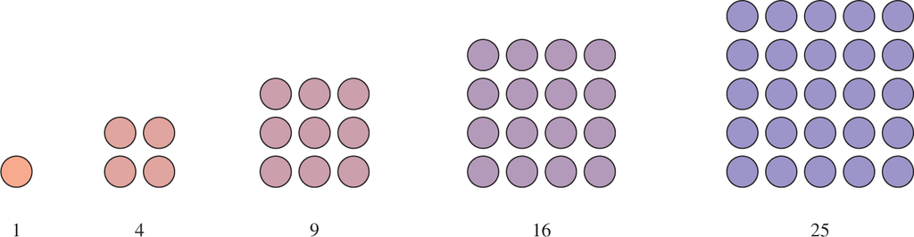

相比之下，*三角形*数则是可以排列成三角形的数字：

The *triangular* numbers, in contrast, are those that can be arranged in the form of a triangle:

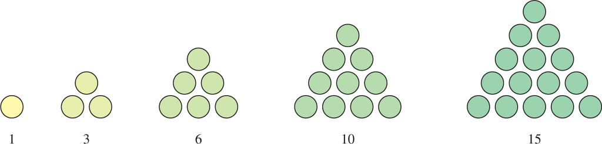

接着是六*边形*数字，依此类推。数字零在每种情况下都是退化实例。

One proceeds to the *hexagonal* numbers, and so forth. The number zero is a degenerate instance in each case.

*回文*数是指数字，如121或523323325，其数字正反读同，类似于回文短语“我更喜欢圆周率”。虽然方形性和三角形性是数的性质，但一个数是否回文性则取决于其基底（因此数学家有时认为这一概念不自然或业余）。例如，27不是回文，但在二进制中表示为11011，即回文。每个数字在任何足够大的基数中都是回文，因此它变成了单位数回文。因此，回文性不是数字的属性，而是数字描述的属性。

The *palindromic* numbers are the numbers, such as 121 or 523323325, whose digits read the same forward and backward, like the palindromic phrase, “I prefer pi.” Whereas squareness and triangularity are properties of numbers, however, the question of whether a number is palindromic depends on the base in which it is presented (and for this reason, mathematicians sometimes find the notion unnatural or amateurish). For example, 27 is not a palindrome, but in binary, it is represented as 11011, which is a palindrome. Every number is a palindrome in any sufficiently large base, for it thereby becomes a single digit, a palindrome. Thus, palindromicity is not a property of numbers, but of number descriptions.

## **1.2 数字系统** **1.2 Number systems**

让我们把各种数字系统摆在桌面上。

Let us lay our various number systems on the table.

### **自然数** **Natural numbers**

*自然数*通常被取为以下数：

The *natural numbers* are commonly taken to be the numbers:

[figure not shown]

自然数集合通常用N表示。历史上，零的引入是一个艰难的概念步骤。考虑到我们目前对这个概念的了解，认为可能需要一个数字来表示*虚无*或缺席的想法，比我们想象的更深。零作为数字首次完全明确是在五世纪的印度，尽管早期它被用作占位符，但没有罗马数字，因为罗马数字没有位值。即使在今天，一些数学家仍偏好以1开头;有些计算机编程语言的索引以0开头，另一些则以1开头。再考虑一下欧洲和美国在计算楼层数的方式上的文化差异，或者中国的计算年龄方法，比如婴儿出生时和第一年都是“一岁”，一年后变成“两岁”，等等。

The set of natural numbers is often denoted by ℕ. The introduction of zero, historically, was a difficult conceptual step. The idea that one might need a number to represent *nothing* or an absence is deeper than one might expect, given our current familiarity with this concept. Zero as a number was first fully explicit in the fifth century in India, although it was used earlier as a placeholder, but not with Roman numerals, which have no place values. Even today, some mathematicians prefer to start the natural numbers with 1; some computer programming languages start their indices with 0, and others with 1. And consider the cultural difference between Europe and the US in the manner of counting floors in a building, or the Chinese method of counting a person’s age, where a baby is “one” at birth and during their first year, turning “two” after one year, and so on.

一种丰富的数论诞生了，建立在自然数基础上，约翰·卡尔·弗里德里希·高斯称其为“数学女王”，并因其纯粹、抽象的孤立性而受到G. H. 哈代（1940年）的赞赏。尽管哈代有这些评论，数论仍然找到了关键应用：高级数论思想构成了密码学的核心，互联网安全基础，因此也是我们经济的基础元素。

A rich number theory has emerged, built upon the natural numbers, described by Johann Carl Friedrich Gauss as the “queen of mathematics” and admired by G. H. Hardy (1940) for its pure, abstract isolation. Despite Hardy’s remarks, number theory has nevertheless found key applications: advanced number-theoretic ideas form the core of cryptography, the basis of internet security, and therefore a foundational element in our economy.

### **整数** **Integers**

*整数*通常表示Z，源自德语单词*Zahlen*，意为“数”，包含所有自然数及其否定，即负数：

The *integers*, usually denoted ℤ for the German word *Zahlen*, meaning “numbers,” include all the natural numbers and their negations, the negative numbers:

[figure not shown]

整数具有自然数不具备的数学特征，例如任意两个整数的和*和差*都是整数。每个整数都有一个加法逆元，即与第一个数字和为零的数，即加法恒等式;乘法分布于加法上。因此，整数构成一个*环*，这是一种具有加法和乘法运算的数学结构，其中每个数字（除其他熟悉的性质外）都应有一个加法逆。

The integers enjoy mathematical features not shared by the natural numbers, such as the fact that the sum *and difference* of any two integers is an integer. Every integer has an additive inverse, a number whose sum with the first number is zero, the additive identity; and multiplication distributes over addition. Thus, the integers form a *ring*, a kind of mathematical structure with addition and multiplication operations for which (among other familiar properties) every number should have an additive inverse.

### **有理数** **Rational numbers**

*有理*数由整数的比值或商数组成，也称为分数，如1/2、5/7或129/53。所有有理数的集合，通常用Q表示“商”，是数轴上点的稠密集合，因为任意两个有理数的平均值仍然是有理数。有理数则具有自然数或整数所不具备的结构特征，例如每个非零元素都存在乘法逆元。这使得有理数 Q 成为*一个域*，实际上是一个*有序*域，因为序关系*<*以某种方式与算术运算相互作用，例如当且仅当 *x* + *a < y* + *a* 时 *x < y*。

*Rational* numbers are formed by the ratios or quotients of integers, also known as fractions, such as 1/2 or 5/7 or 129/53. The collection of all rational numbers, usually denoted by ℚ for “quotient,” is a dense-in-itself collection of points on the number line, for the average of any two rational numbers is again rational. The rational numbers in turn enjoy structural features not shared by the natural numbers or the integers, such as the existence of multiplicative inverses for every nonzero element. This makes the rational numbers ℚ a *field*, and in fact an *ordered* field, since the order relation *<* interacts with the arithmetic operations in a certain way, such as that *x < y* if and only if *x* + *a < y* + *a*.

但数字到底是什么？考虑一个混淆情况：分数3/6不是最低项，而1/2是，但我们说它们相等：

But what is a number, really? Consider a confounding case: the fraction 3/6 is not in lowest terms, while 1/2 is, and yet we say that they are equal:

[figure not shown]

这是怎么回事？如果一个事物拥有另一个没有的属性，它们怎么可能完全相同？那样会违反莱布尼茨关于同一人不可辨的定律。解决方案是，像回文数一样，最低项的属性实际上不是数字本身的属性，而是我们描述或表示该数字方式的属性。我们又把数字和数字搞混了。

What gives? If a thing has a property that another does not, how can they be identical? That would violate Leibniz’s law on the indiscernibility of identicals. The solution is that like the palindromic numbers, the property of being in lowest terms is not actually a property of the number itself, but a property of the way that we have described or represented that number. Again, we have confused number with numeral.

宾语与描述、语义与句法、使用与提及之间的区别——这些都是数理逻辑中的核心区别，澄清了许多问题。通常，不同的描述可以描述同一个天体：晨星就是暮星——两者都是金星——尽管这需要一些时间才学会。

The distinctions between object and description, between semantics and syntax, between use and mention—these are core distinctions in mathematical logic, clarifying many issues. Often, distinct descriptions can characterize the very same object: the morning star is the evening star—both are the planet Venus—even though this took some time to learn.

但数字到底是什么？

But again, what is a number?

## **1.3 不可通约数** **1.3 Incommensurable numbers**

经典数学的一颗宝石——在我看来，也是人类成就的巅峰——是发现了不可通约数，这些量无法用整数的比例来表示。公元前五世纪，毕达哥拉斯学派发现正方形的边和对角线没有共同的度量单位;没有哪个单位长度是它们的整数倍数。用现代术语来说，这相当于无理数的主张，因为这是任意正方形中对角线与边长的比值。如果你将正方形的边数分为10个单位，那么对角线上会有略多于14个单位;如果分为100单位，则略多于141单位;如果是1000人，则略多于1414年;但它永远不会精确——数量是不可通约的。这些数字出现在十进制展开的开头数字中：

[figure not shown]

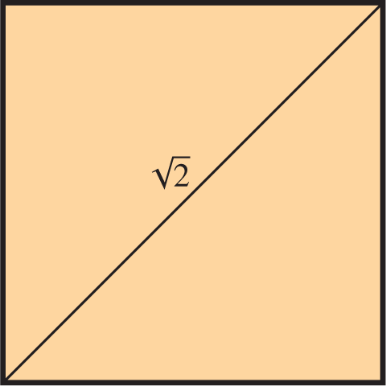

这对毕达哥拉斯学派来说是一次震惊的发现，鉴于他们近乎宗教的数字神秘主义信仰，旨在通过比例和比例来理解一切，将数字视为现实的基础实体。传说中，发现不可通约性的那个人在海上溺亡，因泄露非理性秘密而受到众神惩罚。但这个消息已经传播了两千年，所以让我们一起验证这个美丽的数学事实。我们现在有数十种证明，采用了各种不同的方法。我认为，每一个有自尊、受过教育的人都应该能够证明这种想法是不理性的。

*证据。*一个广为人知的经典论证如下。假设 趋向矛盾 是有理数，因此它可以表示为一个分数：

[figure not shown]

我们可以假设该分数是最低项，意味着*p*和*q*是无共同因子的整数。如果我们将方程两边平方并乘以 *q*<sup>2</sup>，得到

We may assume that this fraction is in lowest terms, meaning that *p* and *q* are integers with no common factor. If we square both sides of the equation and multiply by *q*<sup>2</sup>, we arrive at

[figure not shown]

由此可见，*p2*是2的倍数，因此必定是偶数。由此推断*p*也是偶数，因为奇数×奇数是奇数。因此，对于某个整数 *k，p* = 2*k*，因此 2*q*<sup>2</sup> = *p*<sup>2</sup> = （2*k*）<sup>2</sup> = 4*k*<sup>2</sup>，这意味着 *q*<sup>2</sup> = 2*k*<sup>2</sup>。因此，*q*<sup>2</sup>也是偶数，因此*q*也必须是偶数。所以*p*和*q*都是偶数，这与我们假设*p/q*的比例是最低项的假设相矛盾的。因此 不能表示为分数，因此是无理数。

□

□

### **另一种几何论证** **An alternative geometric argument**

这里还有另一个论点——带有更几何色彩的论点，来自纽约市的逻辑学家斯坦利·特嫩鲍姆。

Here is another argument—one with a more geometric flavor, due to the logician Stanley Tennenbaum from New York City.

*证据。*如果 是有理数，那么我们将得到的方程 *p*<sup>2</sup> = *q*<sup>2</sup> + *q*<sup>2</sup> 用几何方式表示，其中一个大蓝色整数正方形面积与两个中等红色整数正方形相等：

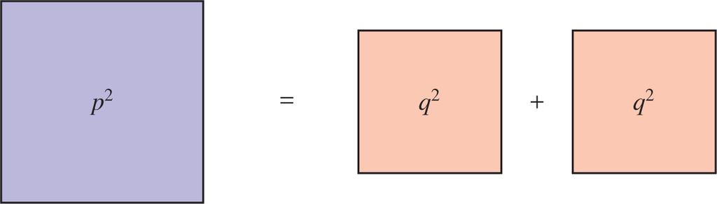

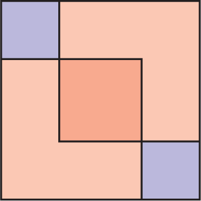

让我们考虑这种关系中最小的整数实例。将重叠的两个红色方块放在蓝色方块内，如图所示。两个蓝色角落被遮盖出来，透出，而中央重叠的红色方块则被覆盖了两次。由于原始蓝色方块与两个红色方块面积相同，因此双重计数的中央方块的面积正好被角落中两个小而未覆盖的蓝色方格所平衡。让我们把这些较小的方格从图中抽出来单独考虑。我们说过红色中央方块的面积与角落里的两个小蓝色方块面积相同。

Let us consider the smallest possible integer instance of this relationship. Place the two red squares overlapping inside the blue square, as shown here. The two blue corners are uncovered, peeking through, while the red square of overlap in the center is covered twice. Since the original blue square had the same area as the two red squares, it follows that the area of the double-counted central square is exactly balanced by the two small, uncovered blue squares in the corners. Let us pull these smaller squares out of the figure and consider them separately. We have said that the red, central square has the same area as the two small blue squares in the corners.

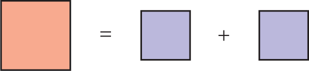

此外，这些较小的正方形也各有整数边，因为它们是与前方方形的差异。因此，我们找到了一个严格更小的整数平方，是另一个整数平方的两个副本之和。这与我们假设从最小的实例开始的假设相矛盾。因此根本不存在这样的实例，因此是无理数的。□

## **1.4 柏拉图主义** **1.4 Platonism**

说真的，数字到底是什么？让我们开始梳理一些可能的答案。根据被称为*柏拉图主义*的哲学立场，数字和其他数学对象作为抽象对象存在。柏拉图认为它们存在于理想形态的领域。你可能在纸上画的某个线条或圆圈是有缺陷且不完美的;在柏拉图领域，有完美的线条和圆圈——还有数字。从这个角度看，数学家说“存在具有某某性质的自然数”意味着在柏拉图领域中存在这样的数。当代柏拉图主义的方法主张抽象对象的存在——这是核心问题——但与柏拉图理想形态或柏拉图领域——一个它们汇聚一处的地方——联系较少。

Truly, what is a number? Let us begin to survey some possible answers. According to the philosophical position known as *platonism*, numbers and other mathematical objects exist as abstract objects. Plato held them to exist in a realm of ideal forms. A particular line or circle that you might draw on paper is flawed and imperfect; in the platonic realm, there are perfect lines and circles—and numbers. From this view, for a mathematician to say, “There is a natural number with such-and-such property,” means that in the platonic realm, there are such numbers to be found. Contemporary approaches to platonism assert that abstract objects exist—this is the core issue—but are less connected with Plato’s idea of an ideal form or the platonic realm, a place where they are all gathered together.

说“存在一个连续但不可微*的函数f*”、“存在该微分方程的解”或“存在一个顺序紧但不紧致的拓扑空间”是什么意思？这不是物质存在;我们无法像短暂握住烫手山芋那样，把这些“物体”握在手中。这算什么样的生活？

What does it mean to say, “There is a function *f* that is continuous but not differentiable,” “There is a solution to this differential equation,” or “There is a topological space that is sequentially compact, but not compact”? This is not physical existence; we cannot hold these “objects” in our hands, as we might briefly hold a hot potato. What kind of existence is this?

根据柏拉图主义，数学对象是抽象的，但却拥有真实存在。对于柏拉图主义者来说，数学中关于数学对象存在的日常讨论可以字面理解——这些对象确实存在，但是抽象而非物理。根据这一观点，数学存在的本质类似于其他抽象事物的存在本质，如美或幸福。美存在吗？我相信是的。平行线存在吗？根据柏拉图主义，答案相似。但什么是抽象对象？这种存在的本质是什么？

According to platonism, mathematical objects are abstract but enjoy a real existence. For the platonist, ordinary talk in mathematics about the existence of mathematical objects can be taken literally—the objects do exist, but abstractly rather than physically. According to this perspective, the nature of mathematical existence is similar to the nature of existence for other abstractions, such as beauty or happiness. Does beauty exist? I believe so. Do parallel lines exist? According to platonism, the answers are similar. But what are abstract objects? What is the nature of this existence?

请考虑一篇作品：亨利克·易卜生的戏剧《*玩偶之家*》。这肯定存在，但具体存在的是什么？我可以给你一份印刷的手稿，上面写着：“这是*玩偶之家*。”但这并不完全正确，因为如果那份手稿受损，我们不会说剧本本身受损;我们不会说这部戏是在我骑摩托车时随意拍的。我能想象这部戏会在百老汇上演，但似乎没有特别的演出是这部戏本身。我们并不认为易卜生的戏剧仅在1879年首演时存在，也不是说剧本随着每次演出而兴起又消失。这部戏剧是一种抽象，是对手稿和表演中各种不完美表现的理想化。

Consider a piece of writing: Henrik Ibsen’s play *A Doll’s House*. This exists, surely, but what is it specifically that exists here? I could offer you a printed manuscript, saying, “This is *A Doll’s House*.” But that would not be fully true, for if that particular manuscript were damaged, we would not say that the play itself was damaged; we would not say that the play had been taken in my back pocket on a motorcycle ride. I could see a performance of the play on Broadway, but no particular performance would seem to be the play itself. We do not say that Ibsen’s play existed only in 1879 at its premiere, or that the play comes into and out of existence with each performance. The play is an abstraction, an idealization of its various imperfect instantiations in manuscripts and performances.

和游戏一样，数字57也存在于各种不完全的实例中：57个苹果在蒲式耳中，57张牌在作弊者牌堆中。抽象对象的存在以某种方式通过它们各种实例的存在来中介。数字57的存在是否类似于戏剧、小说或歌曲的存在？这部戏和其他艺术作品一样，是创作的：易卜生创作了《*玩偶之家*》。虽然有些数学家将他们的工作描述为创造的行为，但毫无疑问，没有数学家会声称创造了数字57。数学是被发现的还是创造的？当代柏拉图主义观点的一部分认为，数字和其他数学对象具有*独立*存在;就像森林里倒下的树一样，下一个数字无论如何都会存在，即使没人能数到那么高。

Like the play, the number 57 similarly exists in various imperfect instantiations: 57 apples in the bushel and 57 cards in the cheater’s deck. The existence of abstract objects is mediated somehow through the existence of their various instantiations. Is the existence of the number 57 similar to the existence of a play, a novel, or a song? The play, as with other pieces of art, was created: Ibsen wrote *A Doll’s House*. And while some mathematicians describe their work as an act of creation, doubtless no mathematician would claim to have created the number 57 in that sense. Is mathematics discovered or created? Part of the contemporary platonist view is that numbers and other mathematical objects have an *independent* existence; like the proverbial tree falling in the forest, the next number would exist anyway, even if nobody ever happened to count that high.

### **充盈柏拉图主义** **Plenitudinous platonism**

马克·巴拉格尔（1998）所捍卫的*“充盈柏拉图主义*”立场，是一种慷慨的柏拉图主义形式，其形而上学承诺非常慷慨;那里充满了他们。根据全貌柏拉图主义，每一个连贯的数学理论都在柏拉图领域的相应数学结构中实现。该理论在理想的数学结构中成立，具体化了理论所涉及的主题。根据全貌柏拉图主义，每一个可想象的连贯数学理论在实际的数学结构中都是真实的，因此这种柏拉图主义形式为我们提供了丰富的数学本体论。

The position known as *plenitudinous platonism*, defended by Mark Balaguer (1998), is a generous form of platonism, generous in its metaphysical commitments; it overflows with them. According to plenitudinous platonism, every coherent mathematical theory is realized in a corresponding mathematical structure in the platonic realm. The theory is true in an ideal mathematical structure, instantiating the subject matter that the theory is about. According to plenitudinous platonism, every conceivable coherent mathematical theory is true in an actual mathematical structure, and so this form of platonism offers us a rich mathematical ontology.

## **1.5 逻辑主义** **1.5 Logicism**

在20世纪初，戈特洛布·弗雷格以及后来的伯特兰·罗素等人，致力于将所有数学，包括数字概念，归结为逻辑。弗雷格首先分析了说存在某种类型中一定数量的事物意味着什么。具有性质*P*的事物恰好有两个，例如，当*存在一个具有*该性质的事物x，并且存在另一个具有该性质*的*独立事物y，此外，任何具有该性质的事物要么是*x*，要么是*y*。因此，在逻辑符号中，“恰好有两个*Ps*”可以这样表达：

Pursuing the philosophical program known as *logicism*, Gottlob Frege, and later Bertrand Russell and others at the dawn of the twentieth century, aimed to reduce all mathematics, including the concept of number, to logic. Frege begins by analyzing what it means to say that there are a certain number of things of a certain kind. There are exactly two things with property *P*, for example, when there is a thing *x* with that property and there is another distinct thing *y* with that property, and furthermore, anything with the property is either *x* or *y*. In logical notation, therefore, “There are exactly two *P*s” can be expressed like this:

[figure not shown]

量词符号∃读作“存在”，∀读作“对所有”，而∧和∨表示“和”或“，→表示”蕴含“。通过这种方式，弗雷格用纯逻辑表达了数字2的概念。你可以有两只羊、两个苹果或两只手，而这些情况的共同点就是数字2是什么。

The quantifier symbol ∃ is read as “There exists” and ∀ as “For all,” while ∧ and ∨ mean “and” and “or,” and → means “implies.” In this way, Frege has expressed the concept of the number 2 in purely logical terms. You can have two sheep or two apples or two hands, and the thing that is common between these situations is what the number 2 is.

### **等值** **Equinumerosity**

弗雷格通过逻辑处理基数的方法使得，置于一一对应的类之间会满足完全相同的弗雷格数断言，因为真值断言的细节通过对应从一个类转移到另一个类。因此，弗雷格的方法与*等值*关系密切相关，这一概念旨在表达两个集合或类具有相同基数大小的观点。等值性也是乔治·康托尔对基数分析的核心，特别是第三章讨论的无限基数。具体来说，两类对象（或用弗雷格的话说：两个概念）是*等数*的——它们的基数大小相同——当它们可以一一对应时。第一类中的每个物品都对应第二类中独特的物品，反之亦然，比如牧羊人用手指数羊。

Frege’s approach to cardinal numbers via logic has the effect that classes placed in a one-to-one correspondence with each other will fulfill exactly the same Fregean number assertions, because the details of the truth assertion transfer through the correspondence from one class to the other. Frege’s approach, therefore, is deeply connected with the *equinumerosity* relation, a concept aiming to express the idea that two sets or classes have the same cardinal size. Equinumerosity also lies at the core of Georg Cantor’s analysis of cardinality, particularly the infinite cardinalities discussed in chapter 3. Specifically, two classes of objects (or as Frege would say: two concepts) are *equinumerous*—they have the same cardinal size—when they can be placed into a one-to-one correspondence. Each object in the first class is associated with a unique object in the second class and conversely, like the shepherd counting his sheep off on his fingers.

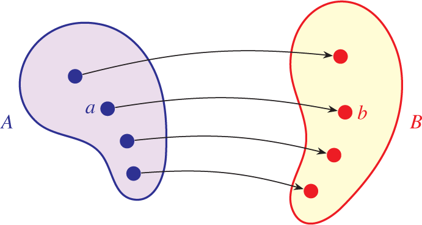

那么，让我们考虑所有集合集合上的等值关系。例如，在这里展示的集合中，等值性由颜色表示：所有绿色集合都是等集合，包含两个元素;所有红色集合均等集合，橙色集合则等等，依此类推。

So let us consider the equinumerosity relation on the collection of all sets. Amongst the sets pictured here, for example, equinumerosity is indicated by color: all the green sets are equinumerous, with two elements, and all the red sets are equinumerous, and the orange sets, and so on.

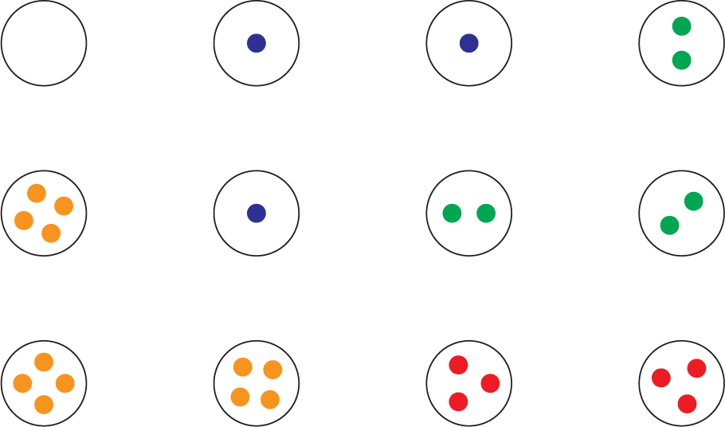

通过这种方式，等值性使我们能够系统地比较任意两个集合，并判断它们是否具有相同的基数大小。

In this way, equinumerosity enables us systematically to compare any two sets and determine whether they have the same cardinal size.

### **康托-休谟原理** **The Cantor-Hume principle**

因此，弗雷格对基数处理的核心是以下数恒一性准则：

At the center of Frege’s treatment of cardinal numbers, therefore, is the following criterion for number identity:

**康托尔-休谟原理。** *两个概念的数量相同当且仅当它们可以一一对应*对应。

**Cantor-Hume principle.** *Two concepts have the same number if and only if those concepts can be placed in a one-to-one correspondence.*

换句话说，当类{ *x |P*（*x*） } 以及类 { *x |Q*（*x*） }。通过符号表达，该原理断言

In other words, the number of objects with property *P* is the same as the number of objects with property *Q* exactly when there is a one-to-one correspondence between the class { *x | P*(*x*) } and the class { *x | Q*(*x*) }. Expressed in symbols, the principle asserts

[figure not shown]

其中#*P*和#*Q*分别表示具有*性质P*或*Q*的对象数量，符号≃表示等值关系。

where #*P* and #*Q* denote the number of objects with property *P* or *Q*, respectively, and the symbol ≃ denotes the equinumerosity relation.

康托尔-休谟原则也被广泛称为*休谟原则*，因为休谟在《人*性论》（*1739年，第一卷第三卷）中对其的简要阐述，弗雷格也提及了该原则（相关的休谟引文见本书第4.5节）。更早之前，伽利略在其《*论两种新科学的对话*录》（1638年）中对等值进行了深入讨论，认为其为大小同一性的判据，尤其是在无限集合的混淆情形中，包括一个悖论性的观察：不同长度的线段和不同半径的圆作为点的集合仍然是等数的。与此同时，在我看来，这一原则主要与康托尔联系在一起，他将其视为基数基础发展的核心动机，可能是最成功、最有影响力的，也是第一个最终明确可数基数和不可数基数本质的康托尔（见第三章）。康托尔在其开创性的集合论文章《康托尔》（1874年）中论述了等值性，并在《康托尔》（1878年）开头句子中陈述了康托尔-休谟原理的一个版本。1877年，他在给理查德·德德金德的一封信中证明了单位区间与平方、立方体，甚至单位超立方体在任何有限维度下的等值性，并对这一发现说：“我看见了，但我不相信！”（Dauben，2004，第941页）我们将在第3.8节第106页回到这个例子。

The Cantor-Hume principle is also widely known simply as *Hume’s principle*, in light of Hume’s brief statement of it in *A Treatise of Human Nature* (1739, I.III.I), which Frege mentions (the relevant Hume quotation appears in section 4.5 of this book). Much earlier, Galileo mounted an extended discussion of equinumerosity in his *Dialogues Concerning Two New Sciences* (1638), considering it as a criterion of size identity, particularly in the confounding case of infinite collections, including the paradoxical observation that line segments of different lengths and circles of different radii are nevertheless equinumerous as collections of points. Meanwhile, to my way of thinking, the principle is chiefly to be associated with Cantor, who takes it as the core motivation underlying his foundational development of cardinality, perhaps the most successful and influential, and the first finally to be clear on the nature of countable and uncountable cardinalities (see chapter 3). Cantor treats equinumerosity in his seminal set-theoretic article, Cantor (1874), and states a version of the Cantor-Hume principle in the opening sentence of Cantor (1878). In an 1877 letter to Richard Dedekind, he proved the equinumerosity of the unit interval with the square, the cube, and indeed the unit hypercube in any finite dimension, saying of the discovery, “I see it, but I don’t believe it!” (Dauben, 2004, p. 941) We shall return to this example in section 3.8, page 106.

康托-休谟原则提供了一个数字同一性的判据，用于判断两个概念是否具有相同数量。然而，它表面上只是表达数字概念的必要特征，而未完全识别数字的含义。也就是说，该原理告诉我们数是等值关系的分类不变量。等价关系的分类*不变量*是对关系域内对象的标记，使得等价对象获得相同标签，不等价对象获得不同标签。例如，如果我们给所有采摘的苹果贴上标签，并且每天采摘的颜色不同，那么标签的颜色将成为这些苹果当天采摘关系的不变量。但还有许多其他不变量;我们可以在标签上写日期，用条形码编码，或者干脆把每天的苹果放进不同的蒲式耳里。

The Cantor-Hume principle provides a criterion of number identity, a criterion for determining when two concepts have the same number. Yet it expresses on its face merely a necessary feature of the number concept, rather than identifying fully what numbers are. Namely, the principle tells us that numbers are classification invariants of the equinumerosity relation. A classification *invariant* of an equivalence relation is a labeling of the objects in the domain of the relation, such that equivalent objects get the same label and inequivalent objects get different labels. For example, if we affix labels to all the apples we have picked, with a different color for each day of picking, then the color of the label will be an invariant for the picked-on-the-same-day-as relation on these apples. But there are many other invariants; we could have written the date on the labels, encoded it in a bar code, or we could simply have placed each day’s apples into a different bushel.

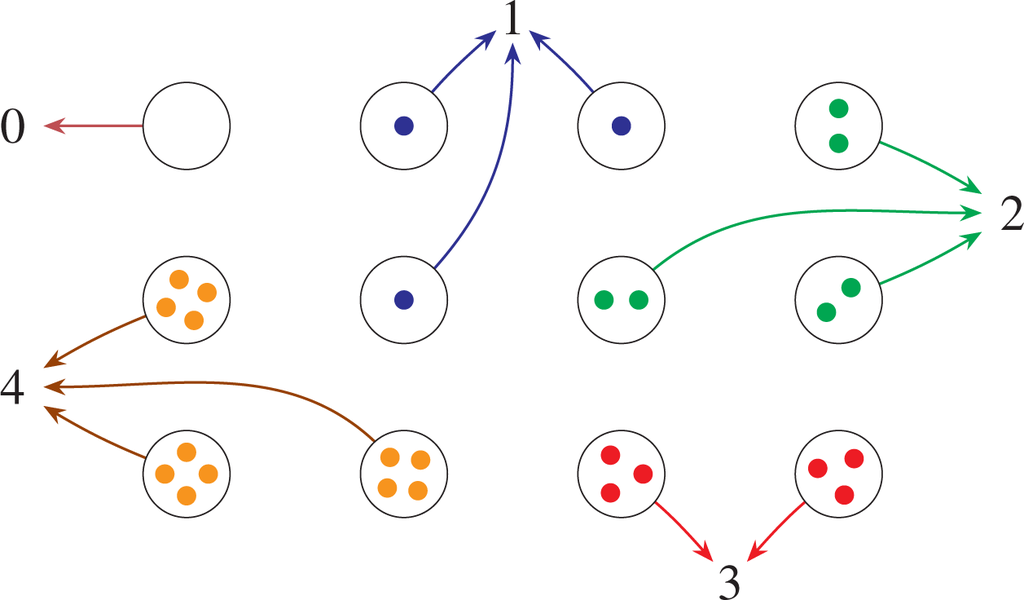

康托-休谟原理告诉我们，数字——无论它们是什么——都以一种方式被赋予每个类，使得等数类得到相同数，而非等数类得到不同数。这正是数字作为等值关系分类不变量的含义。但归根结底，这些被分配到集合上的“数字”对象到底是什么？康托-休谟原理并未说明。

The Cantor-Hume principle tells us that numbers—whatever they are—are assigned to every class in such a way that equinumerous classes get the same number and nonequinumerous classes get different numbers. And this is precisely what it means for numbers to be a classification invariant of the equinumerosity relation. But ultimately, what are these “number” objects that get assigned to the sets? The Cantor-Hume principle does not say.

### **尤利乌斯·凯撒问题** **The Julius Caesar problem**

弗雷格在其逻辑主义纲领中寻求对数的*消极定义*，即通过其他具体概念来定义数。由于康托-休谟原理并未告诉我们数字是什么，他最终认为仅仅基于它来构建数字概念是不令人满意的。他大胆地宣称

Frege had sought in his logicist program an *eliminative* definition of number, for which numbers would be defined in terms of other specific concepts. Since the Cantor-Hume principle does not tell us what numbers are, he ultimately found it unsatisfactory to base a number concept solely upon it. Putting the issue boldly, he proclaimed

我们永远无法——以粗略的例子——通过定义判断任何概念是否拥有属于尤利乌斯·凯撒的数字，或者那位熟悉的高卢征服者是否是一个数字。（弗雷格，1968 [1884]，第57节）

we can never—to take a crude example—decide by means of our definitions whether any concept has the number Julius Caesar belonging to it, or whether that same familiar conqueror of Gaul is a number or not. (Frege, 1968 [1884], §57)

反对意见在于，尽管康托-休谟原则为形式为#*P* = #*Q*的恒等式提供了数同一准则，比较两类的数字，但它没有为形式为#*P* = *x*的恒等式提供同一准则，无法告诉我们*哪些物体x*是数字，包括#*P* = 尤利乌斯·凯撒的情况。

The objection is that although the Cantor-Hume principle provides a number identity criterion for identities of the form #*P* = #*Q*, comparing the numbers of two classes, it does not provide an identity criterion for identities of the form #*P* = *x*, which would tell us which objects *x* were numbers, including the case #*P* = Julius Caesar.

表面上看，这一反对意见强烈反结构主义，我们将在第1.10节详细讨论这一立场，因为它关注的是数字本身，而非其结构特征和角色。然而，Greimann（2003）等人仍认为弗雷格存在细腻的结构主义。

On its face, this objection is strongly antistructuralist, a position we shall discuss at length in section 1.10, for it is concerned with what the numbers are, rather than with their structural features and roles. Yet, Greimann (2003) and others argue, nevertheless, that there is a nuanced structuralism in Frege.

### **数字作为等值类** **Numbers as equinumerosity classes**

为了定义一个适合其程序的数的概念，弗雷格从等值关系中抽象出来。他最终意识到，*等值类本身*可以作为数字。

In order to define a concept of number suitable for his program, Frege undertakes a process of abstraction from the equinumerosity relation. He realizes ultimately that *the equinumerosity classes themselves* can serve as numbers.

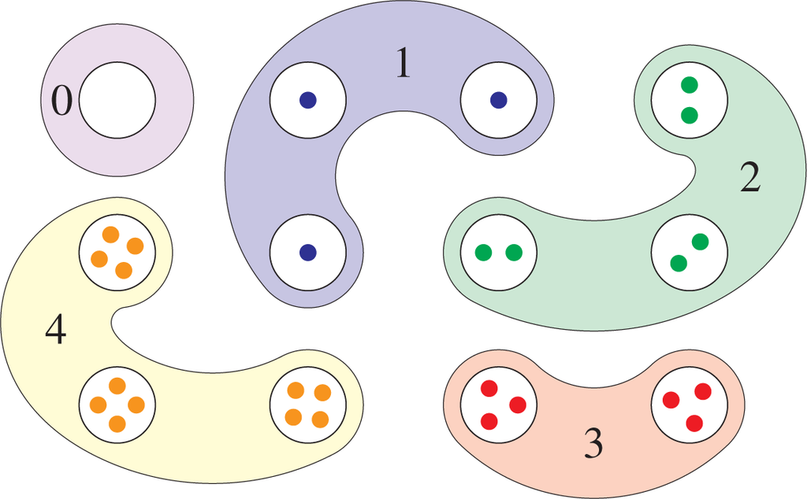

具体来说，弗雷格将概念*P*的基数定义为与*P*等数的概念。换句话说，集合的基数是所有与其等势的集合的类，即该集合的等值类：

Specifically, Frege defines the cardinal “number” of a concept *P* to be the concept of being equinumerous with *P*. In other words, the cardinal number of a set is the class of all sets equinumerous with it, the equinumerosity class of the set:

[figure not shown]

对于弗雷格来说，数字2*是*所有两元素集合的类;数字3*是*所有三元素集合的类，依此类推。数字0恰好是{ ∅}，因为只有空集没有元素。弗雷格的定义满足康托尔-休谟原则，因为集合具有相同的等值类当且仅当它们是等数集合。

For Frege, the number 2 *is* the class of all two-element collections; the number 3 *is* the class of all three-element collections, and so on. The number 0 is precisely { ∅ }, since only the empty set has no elements. Frege’s definition fulfills the Cantor-Hume principle because sets have the same equinumerosity class if and only if they are equinumerous.

弗雷格继续发展他的算术理论，定义零为空类的基数，并定义若*m*是通过向*基数n*的集合添加一个新元素得到的集合的基数，*则m是*另一个*n*的*后继*基数;自然数是通过连续应用后继运算从0生成的基数，更准确地说，是那些具有所有0性质且从每个基数传递到其后继的数。如果将等值和其他概念视为逻辑，那么这种方法最终似乎将算术简化为逻辑。

Frege proceeds to develop his arithmetic theory, defining zero as the cardinal of the empty class and defining that a number *m* is the *successor* cardinal of another *n* if *m* is the cardinal of a set obtained by adding one new element to a set of cardinal *n*; the natural numbers are the cardinals generated from 0 by successive applications of the successor operation, or more precisely, the numbers having every property of 0 that also is passed from every cardinal to its successor. If one regards equinumerosity and these other notions as logical, then this approach seems ultimately to reduce arithmetic to logic.

起初他独立于弗雷格，但后来在弗雷格的基础上回应并加以发展，伯特兰·罗素也试图在逻辑中创立数学。罗素对皮亚诺（1889年）对算术的形式化印象深刻，但他认为弗雷格的基础更深层次，是对“零”、“后继”和“自然数”这些算术概念的纯逻辑解释。在他们随后的巨著《*数学原理*》中，罗素和阿尔弗雷德·诺斯·怀特海将这两个主题融入他们的算术论述中。

At first independently of Frege, but later responding to and building upon Frege’s work, Bertrand Russell also sought to found mathematics in logic. Russell was impressed by the Peano (1889) formalization of arithmetic, but he viewed Frege’s foundation as still deeper in providing purely logical accounts of the arithmetic notions of “zero,” “successor,” and “natural number.” In their subsequent monumental work, *Principia Mathematica*, Russell and Alfred North Whitehead wove both themes into their account of arithmetic.

### **新意构造主义** **Neologicism**

弗雷格和罗素的逻辑主义程序被广泛认为最终未能成功，试图将数学归结为逻辑。弗雷格的基础体系被罗素悖论（第八章讨论）证明了不一致，罗素系统被视为通过无穷公理和选择公理做出非逻辑存在断言。然而，鲍勃·黑尔、克里斯平·赖特等新*逻辑主义*者复兴了逻辑主义，重新诠释弗雷格的逻辑主义方法，避免了矛盾的陷阱，旨在再次将数学归结为逻辑。

The logicist programs of Frege and Russell came widely to be viewed as ultimately unsuccessful in their attempts to reduce mathematics to logic. Frege’s foundational system was proved inconsistent by the Russell paradox (discussed in chapter 8), and Russell’s system is viewed as making nonlogical existence assertions with the axiom of infinity and the axiom of choice. Nevertheless, logicism is revived by Bob Hale and Crispin Wright and others in the *neologicist* program, reconstruing Frege’s approach to logicism in a way that avoids the pitfall of inconsistency, aiming once again to reduce mathematics to logic.

具体来说，赖特（1983）旨在直接建立弗雷格算术，建立在康托尔-休谟原理之上，建立皮亚诺公理而无需复杂的基础体系。等值性用二阶逻辑表示，被视为逻辑。（部分哲学家在此反对，认为二阶原理本质上是集合论且数学化的，但我们先从新逻辑学的视角继续。）新逻辑学家通过寻求纯逻辑的数字赋值问题，基于弗雷格关于*抽象*过程的建议，来解决尤利乌斯·凯撒问题。例如，弗雷格解释了我们如何指代一条线的*方向*，最初只有一个指向性的标准，即平行性。类似地，我们可以谈论国际象棋走法顺序，或彩色瓷砖排列的*模式*，或者某项物品的*价值*。在每种情况下，我们指代一个抽象实体，函数表达式 *f*，仅通过形式为 的准则隐式定义

Specifically, Wright (1983) aims to found Frege’s arithmetic directly upon the Cantor-Hume principle, establishing the Peano axioms without need for the problematic foundational system. Equinumerosity, expressed in second-order logic, is taken as logical. (Some philosophers object at this point, regarding second-order principles as inherently set-theoretic and mathematical, but let us proceed with the neologicist perspective.) The neologicists address the Julius Caesar problem by seeking a purely logical account of the number-assignment problem, building upon suggestions of Frege regarding the process of *abstraction*. Frege explains, for example, how we refer to the *direction* of a line, having initially only a criterion of same-directionality, namely, parallelism. Similarly, we might speak of the *order* of a sequence of chess moves, or the *pattern* of an arrangement of colored tiles, or perhaps the *value* of a certain item. In each case, we refer to an abstract entity with a functional expression *f*, defined only implicitly by a criterion of the form

[figure not shown]

其等价关系为 *R*。例如，当 *l*<sub>1</sub> 与 *l*<sub>2</sub> 平行时，直线 *l*<sub>1</sub> 的方向与直线 *l*<sub>2</sub> 相同;如果瓷砖能关联到颜色和相邻度，则一种铺砌图案与另一种排列是相同的。弗雷格抽象*过程*采用这种抽象原则来定义一个抽象函数*f*。当然，主要观点是康托-休谟原理本身就是一种抽象原则，我们指的是类中元素*的数量*，两个类的数量相同当且仅当它们是等数的。通过抽象过程，我们因此获得了数字作为抽象对象的存在。

with an equivalence relation *R*. The direction of line *ℓ*<sub>1</sub> is the same as the direction of line *ℓ*<sub>2</sub>, for example, exactly when *ℓ*<sub>1</sub> is parallel to *ℓ*<sub>2</sub>; one tiling pattern is the same as another if the tiles can be associated to match color and adjacency from one arrangement to the other. The Fregean *process of abstraction* takes such an abstraction principle to define an abstract function *f*. The main point, of course, is that the Cantor-Hume principle itself is such an abstraction principle, where we refer to the *number* of elements in a class, and two classes have the same number if and only if the classes are equinumerous. By the process of abstraction, we therefore achieve numbers as abstract objects.

与此同时，将所有抽象原则都视为合法存在逻辑问题，因为其中一些原则会导致不一致。例如，一般理解原则可以通过弗雷格抽象产生。因此，抽象原则被称为与“坏伙伴”相伴;已知错误的原则作为实例出现。当然，这只是委婉地说，抽象作为功能定义原则是错误的。我们通常不会因为有错误的实例而说否认前行词的错误与“坏人”同属;相反，我们说它是谬误的。

Meanwhile, there are logical problems with taking every abstraction principle as legitimate, as some of them lead to inconsistency. The general comprehension principle, for example, can arise via Fregean abstraction. Thus, the principle of abstraction is said to consort with “bad company”; known-to-be-false principles arise as instances of it. This is merely a gentle way of saying, of course, that abstraction is wrong as a principle of functional definition. We do not usually say that the fallacy of denying the antecedent consorts with “bad company” because it has false instances; rather, we say that it is fallacious.

## **1.6 算术解释** **1.6 Interpreting arithmetic**

数学家通常试图在彼此之间解释他们的各种理论。我们如何在其他领域解释算术？让我们来探讨一些提案。

Mathematicians generally seek to interpret their various theories within one another. How can we interpret arithmetic in other domains? Let us explore a few of the proposals.

### **数字作为等值类** **Numbers as equinumerosity classes**

我们刚才讨论了弗雷格和后来的罗素如何将数定义为等值等价类。根据该说法，数字2是所有两元素集合的类，数字3是所有三元素集合的类。这些是真类而非集合，后者在集合论上存在问题，但可以通过*Scott*技巧（由Dana Scott提出）将它们归化为集合，方法是用每个类在集合论层级中的最小秩实例集合来表示。

We have just discussed how Frege, and later Russell, defined numbers as equinumerosity equivalence classes. According to this account, the number 2 is the class of all two-element sets, and the number 3 is the class of all three-element sets. These are proper classes rather than sets, which can be seen as set-theoretically problematic, but one can reduce them to sets via *Scott’s trick* (due to Dana Scott) by representing each class with its set of minimal-rank instances in the set-theoretic hierarchy.

### **作为集合的数** **Numbers as sets**

与此同时，集合论中对算术还有其他几种解释。恩斯特·策梅洛用空集表示数字零，然后依次应用单元素运算作为后继运算，如下：

Meanwhile, there are several other interpretations of arithmetic within set theory. Ernst Zermelo represented the number zero with the empty set and then successively applied the singleton operation as a successor operation, like this:

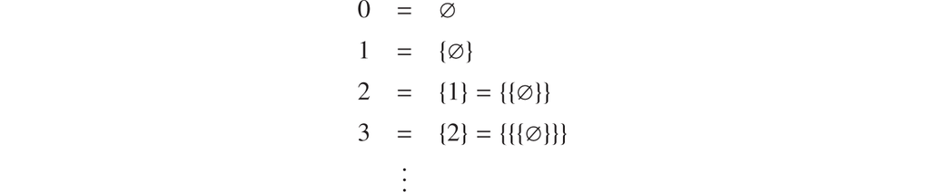

接着用纯集合论术语定义这些数的普通算术结构，包括加法和乘法。

One then proceeds to define in purely set-theoretic terms the ordinary arithmetic structure on these numbers, including addition and multiplication.

约翰·冯·诺依曼提出了另一种解释，基于一个优雅的递归思想：*每个数字都是较小数的集合。*根据这一观点，空集∅是最小的数，因为它没有元素，因此根据口号，没有小于它的数。接下来是{∅}，因为该集合中唯一的元素（因此也是唯一小于它的数）是∅。继续这样，可以得到自然数：

John von Neumann proposed a different interpretation, based upon an elegant recursive idea: *every number is the set of smaller numbers.* On this conception, the empty set ∅ is the smallest number, for it has no elements and therefore, according to the slogan, there are no numbers smaller than it. Next is {∅}, since the only element of this set (and hence the only number less than it) is ∅. Continuing in this way, one finds the natural numbers:

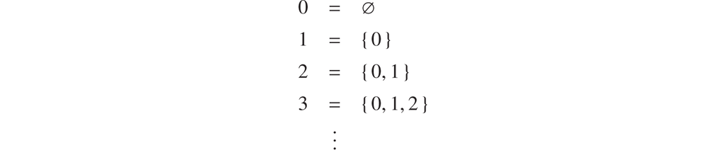

任意数*n*的后从是集合*n*∪{*n*}，因为除了低于*n*的数外，*还会将*自身加到这个新数之下。在冯·诺依曼数概念中，数上的序关系*n<*m与关系*n∈m*的元素是*相同的，因为**m*正是小于*m*的集合。

The successor of any number *n* is the set *n*∪{*n*}, because in addition to the numbers below *n*, one adds *n* itself below this new number. In the von Neumann number conception, the order relation *n < m* on numbers is the same as the element-of relation *n* ∈ *m*, since *m* is precisely the set of numbers that are smaller than *m*.

注意，如果我们解开上述3的定义，会发现

Notice that if we unwind the definition of 3 above, we see that

[figure not shown]

但真是一团糟！而且到了4和5，情况会更糟，依此类推。也许这个想法不自然或复杂？这种看冯·诺依曼数的方式掩盖了每个数都是较小数集合的基本思想，正是这一思想很容易推广到超限，并使得运术中核心的递归定义得以顺利实现。这

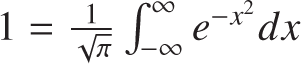

是否意味着数字1很复杂？我不这么认为;简单的事情也可能有复杂的描述。冯·诺依曼序数通常被当今集合论学者视为一种基本的集合论现象，绝对可定义且刚性强，构成累积层级的骨干，并优雅且实用地解释有限和超限算术。

But what a mess! And it gets worse with 4 and 5, and so on. Perhaps the idea is unnatural or complicated? Well, that way of looking at the von Neumann numbers obscures the underlying idea that every number is the set of smaller numbers, and it is this idea that generalizes so easily to the transfinite, and which smoothly enables the recursive definitions central to arithmetic. Does the fact that

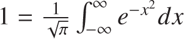

mean that the number 1 is complicated? I do not think so; simple things can also have complex descriptions. The von Neumann ordinals are generally seen by set theorists today as a fundamental set-theoretic phenomenon, absolutely definable and rigid, forming a backbone to the cumulative hierarchy, and providing an interpretation of finite and transfinite arithmetic with grace and utility.

不应将策梅洛和冯·诺依曼数概念完全平等，因为策梅洛诠释在当今集合论中基本不被使用，仅用于此类比较解释的讨论，而冯·诺依曼解释因其便利和概念优势，成为事实上的标准，成千上万的集合论者常常默然使用。

One should not place the Zermelo and von Neumann number conceptions on an entirely equal footing, since the Zermelo interpretation is essentially never used in set theory today except in this kind of discussion comparing interpretations, whereas the von Neumann interpretation, because of its convenient and conceptual advantages, is the de facto standard, used routinely without remark by thousands of set theorists.

### **数字作为原元** **Numbers as primitives**

一些数学家和哲学家更倾向于将数字视为未定义的原始元素，而不是在另一种数学结构中解释它们。根据这种观点，数字2仅仅是一个原始的数学对象，关于它是什么或更根本的组成，已无更多可言。存在一组自然数0、1、2等，作为原元素或不可约本原，我们可以继续在它们基础上构造其他更复杂的数学结构。

Some mathematicians and philosophers prefer to treat numbers as undefined primitives rather than interpreting them within another mathematical structure. According to this view, the number 2 is just that—a primitive mathematical object—and there is nothing more to say about what it is or its more fundamental composition. There is a collection of natural numbers 0, 1, 2, and so on, existing as urelements or irreducible primitives, and we may proceed to construct other, more elaborate mathematical structures upon them.

例如，给定自然数，我们可以这样构造整数：我们希望将每个整数视为两个自然数的差，例如表示数字2为7 − 5，表示− 3为6 − 9或12 − 15。正数则是大数与小数之间的差值，负数则相反。由于表示相同差分的方法有很多种，我们定义了自然数对上的等价关系，即*等差*关系：

For example, given the natural numbers, we may construct the integers as follows: We would like to think of every integer as the difference between two natural numbers, representing the number 2 as 7 − 5, for example, and − 3 as 6 − 9 or as 12 − 15. The positive numbers arise as differences between a larger number and a smaller number, and negative numbers conversely. Since there are many ways to represent the same difference, we define an equivalence relation, the *same-difference* relation, on pairs of natural numbers:

[figure not shown]

注意，我们通过写 *a* + *d* = *c* + *b* 而非 *a* − *b* = *c* − *d*，仅用加法而非减法来表达相同的差分概念，这会成为问题，因为自然数在减法下不封闭。正如弗雷格将数字定义为等值类，我们现在也可以简单地将整数定义*为*自然数对相对于相同差分关系的等价类。根据这种观点，整数*2就是集合*{（2， 0）， （3， 1）， （4， 2）*， ...* }，而− 3是集合{ （0， 3）， （1， 4）， （2， 5）*， ...* }。我们可以继续定义这些新对象的加法和乘法运算。例如，如果 [*（a， b*）] 表示对 （*a， b*） 的相同差等价类，则定义

Notice that we were able to express the same-difference idea by writing *a* + *d* = *c* + *b* rather than *a* − *b* = *c* − *d*, using only addition instead of subtraction, which would have been a problem because the natural numbers are not closed under subtraction. Just as Frege defined numbers as equinumerosity classes, we now may define the integers simply to *be* the equivalence classes of pairs of natural numbers with respect to the same-difference relation. According to this view, the integer 2 simply *is* the set { (2, 0), (3, 1), (4, 2)*, …* }, and − 3 is the set { (0, 3), (1, 4), (2, 5)*, …* }. We may proceed to define the operations of addition and multiplication on these new objects. For example, if [(*a, b*)] denotes the same-difference equivalence class of the pair (*a, b*), then we define

[figure not shown]

如果我们将等价类 [（*a， b*）] 视为整数差 *a*−*b*，这些定义是自然的，因为我们希望在整数中确保

If we think of the equivalence class [(*a, b*)] as representing the integer difference *a*−*b*, these definitions are natural because we want to ensure in the integers that

[figure not shown]

我们的方法存在一个微妙的问题;也就是说，我们定义了等价类 [（*a， b*）] 和 [（*c， d*）] 的运算，但在此过程中，我们在写 *A* + *C* 和 *B* + *D* 时参考了这两个类的特定代表。为了成功定义等价类上的运算，我们需要证明代表元的选择并不重要。我们需要证明，我们的操作相对于等差关系是*良好定义*的——等价输入会产生等价输出。如果输入（*a， b*） *∼* （*a*′*， b*′） 和 （*c， d*） *∼* （*c*′*， d*′），则需要证明相应的输出也是等价的，即 （*a* + *c， b* + *d*） *∼* （*a*′ + *c*′*， b*′ + *d*′），乘法亦然。事实上，我们的定义确实有这样一个明确的特征。因此，我们从自然数对的等价差类构建了一个数学结构，并且可以证明它表现出我们在整数环中预期的所有性质。通过这种方式，我们从自然数构造整数。

There is a subtle issue with our method here; namely, we defined an operation on the equivalence classes [(*a, b*)] and [(*c, d*)], but in doing so, we referred to the particular representatives of those classes when writing *a* + *c* and *b* + *d*. For this to succeed in defining an operation on the equivalence class, we need to show that the choice of representatives does not matter. We need to show that our operations are *well defined* with respect to the same-difference relation—that equivalent inputs give rise to equivalent outputs. If we have equivalent inputs (*a, b*) *∼* (*a*′*, b*′) and (*c, d*) *∼* (*c*′*, d*′), then we need to show that the corresponding outputs are also equivalent, meaning that (*a* + *c, b* + *d*) *∼* (*a*′ + *c*′*, b*′ + *d*′), and similarly for multiplication. And indeed our definition does have this well defined feature. Thus, we build a mathematical structure from the same-difference equivalence classes of pairs of natural numbers, and furthermore, we can prove that it exhibits all the properties that we expect in the ring of integers. In this way, we construct the integers from the natural numbers.

类似地，我们将有理数构造为整数对的等价类，采用*相同的比率*关系。即，将对（*p， q*）写成熟悉的分数形式，并坚持*≠q*为0，定义同比等价关系为

[figure not shown]

注意我们只用整数的乘法结构来实现这一点。接下来，我们定义这些分数的加法和乘法：

Note that we used only the multiplicative structure on the integers to do this. Next, we define addition and multiplication on these fractions:

[figure not shown]

并验证这些运算相对于相同比率关系的良好定义。该分数作为数值，仅代表对应的有理数，即同比等价类。因此，我们从整数构造有理数域，最终由自然数原数构造。

该程序继续到实数，实数可以通过有理数的各种方式定义实数，例如Dedekind割构造或第1.11节中解释的柯西序列的等价类，然后将复数定义为实数对 *a* + *bi*，如第1.13节所述。诸如此类。归根结底，我们熟悉的所有数系统都可以从自然数原源构造出来，这一过程正如列奥波德·克罗内克所说的那样恰当地描述：

The program continues to the real numbers, which one may define by various means from the rational numbers, such as by the Dedekind cut construction or with equivalence classes of Cauchy sequences explained in section 1.11, and then the complex numbers as pairs of real numbers *a* + *bi*, as in section 1.13. And so on. Ultimately, all our familiar number systems can be constructed from the natural number primitives, in a process aptly described by the saying attributed to Leopold Kronecker:

“*Die ganzen Zahlen hat der liebe Gott gemacht, alles andere ist Menschenwerk*”

(“上帝创造了整数，其余都是人的作品。”）

(“God made the integers, all the rest is the work of man.”)

克罗内克（1886），引自（韦伯，1893，第15页）

Kronecker (1886), quoted in (Weber, 1893, p. 15)

### **数作为态射** **Numbers as morphisms**

许多数学家注意到范畴论在统一来自不同数学领域的数学构造和思想方面的力量。例如，群论中的构造可能满足并由某一交换同态图的普遍性质确定，且该构造在这方面可能与环中的对应构造或偏序构造相同。范畴论一次又一次地揭示，数学家们在不同语境下进行了本质上相似的构造。

Many mathematicians have noted the power of category theory to unify mathematical constructions and ideas from disparate mathematical areas. A construction in group theory, for example, might fulfill and be determined up to isomorphism by a universal property for a certain commutative diagram of homomorphisms, and the construction might be identical in that respect to a corresponding construction in rings, or in partial orders. Again and again, category theory has revealed that mathematicians have been undertaking essentially similar constructions in different contexts.

正因为这种统一力量，数学家们试图将范畴论作为数学的基础。在集合范畴初等理论（ETCS）中，这是一种由F. William Lawvere（1963年）提出的基于范畴论的基础系统，研究拓*扑（topos*）是一种具有集合范畴许多特征的范畴。拓扑中的自然数由所谓的*自然数对象*表示，即范畴中的对象N，配备一个态射*z*：1→N，用于选出数零，其中1是范畴中的终结对象，另一个态射*s*：N →N满足某种普遍自由作用性质， 这确保了它在自然数上的后继函数中的作用。其动机思想是，每个自然数都是通过从零生成的后继运算，该运算是通过连续应用*s*到*z*的组合得到：

Because of this unifying power, mathematicians have sought to use category theory as a foundation of mathematics. In the elementary theory of the category of sets (ETCS), a category-theory-based foundational system introduced by F. William Lawvere (1963), one works in a *topos*, which is a certain kind of category having many features of the category of sets. The natural numbers in a topos are represented by what is called a *natural-numbers object*, an object ℕ in the category equipped with a morphism *z*: 1 → ℕ that serves to pick out the number zero, where 1 is a terminal object in the category, and another morphism *s*: ℕ → ℕ that satisfies a certain universal free-action property, which ensures that it acts like the successor function on the natural numbers. The motivating idea is that every natural number is generated from zero by the successor operation, obtained from the composition of successive applications of *s* to *z*:

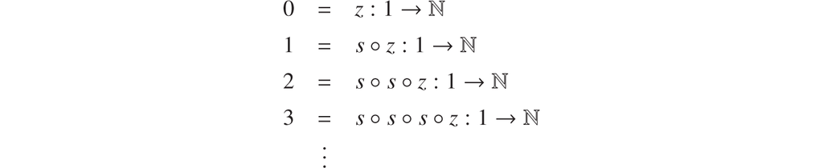

在这种概念中，自然数仅是一个态射 *n*： 1 → N。自然数对象在任意拓扑中（同构）中是唯一的，任何此类对象都能将算术概念解释为范畴论。

In this conception, a natural number is simply a morphism *n*: 1 → ℕ. The natural numbers object is unique in any topos up to isomorphism, and any such object is able to interpret arithmetic concepts into category theory.

### **数字作为博弈** **Numbers as games**

我们甚至可能把数字解读为游戏。在约翰·康威的观点中，博弈是基本概念，数字被定义为某些类型的博弈。最终，他的理论解释了自然数、整数、实数和序数，这些统一为一个统一的数系统——*超现实*数。在康威的框架中，游戏有两个玩家，左和右，轮流走棋。一种描述博弈的方式是为每个玩家指定走法选项;轮到玩家时，玩家选择其中一个选项，实际上从该位置开始新游戏，回合权传给另一名玩家。因此，博弈具有遗传的类博弈性质：每个博弈都是一对博弈集合，

We may even interpret numbers as games. In John Conway’s account, games are the fundamental notion, and one defines numbers to be certain kinds of games. Ultimately, his theory gives an account of the natural numbers, the integers, the real numbers, and the ordinals, all unified into a single number system, the *surreal* numbers. In Conway’s framework, the games have two players, Left and Right, who take turns making moves. One describes a game by specifying for each player the move options; on their turn, a player selects one of those options, which in effect constitutes a new game starting from that position, with turn-of-play passing to the other player. Thus, games are hereditarily gamelike: every game is a pair of sets of games,

[figure not shown]

其中*G*<sub>*L*</sub>的博弈是左的选择，G的R是右的选择。这一思想可以被视为整个理论递归发展的基础公理。当玩家没有合法走法时，即其选项为空，即该玩家输掉游戏。

where the games in *G*<sub>*L*</sub> are the choices available for Left and those in *G*<sub>*R*</sub> for Right. This idea can be taken as a foundational axiom for a recursive development of the entire theory. A player loses a game play when they have no legal move, which happens when their set of options is empty.

我们可能会像集合论中的累积层级一样，从无到有构建博弈宇宙。一开始，我们什么都没有。但这样我们就可以形成称为*零*的博弈，

We may build up the universe of games from nothing, much like the cumulative hierarchy in set theory. At first, we have nothing. But then we may form the game known as *zero*,

[figure not shown]

该选区既没有左翼也没有右翼选项。这局游戏谁先走谁就输。构造出这个博弈后，我们可以构造被称为*星形*博弈的博弈，

which has no options for either Left or Right. This game is a loss for whichever player moves first. Having constructed this game, we may form the game known as *star*,

[figure not shown]

其中零局是左或右唯一的选择。这场游戏对第一个玩家来说是赢，因为轮到的玩家会选择0，而另一位玩家则是失败。我们也可以形成被称为*一*和*二*的博弈：

which has the zero game as the only option for either Left or Right. This game is a win for the first player, since whichever player’s turn it is will choose 0, which is then a loss for the other player. We can also form the games known as *one* and *two*:

[figure not shown]

这些分别是左派获胜，以及*负一*和*负二*的博弈：

which are wins for Left, and the games *negative one* and *negative two*:

[figure not shown]

这些胜利属于右派。再考虑被称为*半*分和*三分之三*的比赛：

which are wins for Right. And consider the games known as *one-half* and *three-quarters*:

[figure not shown]

你能看到继续吗？

Can you see how to continue?

康威随后对游戏类施加了类数的数学结构：例如，如果左赢，无论谁先，游戏都是*正*的;如果右赢，则为*负*。读者可以验证1、2和为正，而−1和−2为负，0和*既非正亦非负。康威还定义了博弈中某种遗传的序式关系，基于这样一个观点*：博弈*G可能大于其左集的博弈，而小于其右集的博弈，就像有理数中的Dedekind割。具体来说，*G* ≤ *H* 当且仅当 *h* 永远不会发生 h ≤ *G* 的 H 是 H 的右集 *h 的某个* *g*，也不会 *H ≤* *g* 的 g 属于左*集的某个* *g*;这一定义是有充分根据的，因为我们已经将 *G* ≤ *H* 的问题简化为与更早创建博弈的顺序中排名较低的实例。一个*数字*是一个游戏 *G*，其中其左集的每个元素都与右集的每个元素处于关系≤。当游戏被构造为无限时，这种概念就导致*了超现实的数字*。康威定义*了博弈*G + *H*和乘积*G*×*H和指数*G、<sup>*H*</sup>的和，并证明了他博弈数概念中所有熟悉的算术性质。这是一个美丽且卓越的数学理论。

### **垃圾定理** **Junk theorems**

每当有人在另一个数学理论中解释了一种数学理论，比如在集合论中解释算术时，就会出现*垃圾定理*现象，即由于解释理论中的对象的性质而产生的不受欢迎的事实，而非预期解释结构的一部分。其中一个包含了废弃定理、废弃性质，甚至还有废弃问题。

Whenever one has provided an interpretation of one mathematical theory in another, such as interpreting arithmetic in set theory, there arises the *junk-theorem* phenomenon, unwanted facts that one can prove about the objects in the interpreted theory which arise because of their nature in the ambient theory rather than as part of the intended interpreted structure. One has junk theorems, junk properties, and even junk questions.

例如，如果通过冯·诺依曼序数来解释集合论中的算术，那么很容易证明几个奇怪的事实：

If one interprets arithmetic in set theory via the von Neumann ordinals, for example, then one can easily prove several strange facts:

[figure not shown]

这里的 *P* 符号表示“幂集”，即所有子集的集合。许多数学家反对这些定理，理由是我们不希望对算术的解释，即数字2是数字3的元素，或者数字2实际上是数字1的所有子集集合的同一数学对象。这些是“垃圾”定理，意思是它们对这些算术对象成立，但仅基于该特定解释的细节——冯·诺依曼序数解释;它们不一定适用于集合论中其他算术解释。在解释集合论中的算术时，许多数学家的反对意见似乎集中在这样一个观点：数字本身可以被解释为任何形式的集合;许多数学家觉得问“数字7的元素是什么？”很奇怪。为了避免这种垃圾定理现象，一些数学家主张某些替代的非集合论基础。

The *P* notation here means “power” set, the set of all subsets. Many mathematicians object to these theorems on the grounds that we do not want an interpretation of arithmetic, they stress, in which the number 2 is an element of the number 3, or in which it turns out that the number 2 is the same mathematical object as the set of all subsets of the number 1. These are “junk” theorems, in the sense that they are true of those arithmetic objects, but only by virtue of the details of this particular interpretation, the von Neumann ordinal interpretation; they would not necessarily be true of other interpretations of arithmetic in set theory. In the case of interpreting arithmetic in set theory, many of the objections one hears from mathematicians seem concentrated in the idea that numbers would be interpreted as sets at all, of any kind; many mathematicians find it strange to ask, “What are the elements of the number 7?” In an attempt to avoid this junk-theorem phenomenon, some mathematicians advocate certain alternative non-set-theoretic foundations.

在我看来，这个问题与集合论关系不大，因为替代基础本身就存在自己的问题。例如，在康威的数字博弈中，合理的问题是：“谁赢得17？”在ETCS的算术中，可以说数字5和7的定义域和陪域，或者用后继运算构成5的复合，或者询问5的定义域是否与实数*π*的定义域相同。这对那些想说17不是游戏，或者数没有定义域且不能用任何态射合成的数学家来说，这被视为废话。垃圾定理现象似乎不可避免;每当有人将一种数学理论解释到另一种理论时，都会发生这种情况。

To my way of thinking, the issue has little to do with set theory, for the alternative foundations exhibit their own junk. In Conway’s game account of numbers, for example, it is sensible to ask, “Who wins 17?” In the arithmetic of ETCS, one may speak of the domain and codomains of the numbers 5 and 7, or form the composition of 5 with the successor operation, or ask whether the domain of 5 is the same as the domain of the real number *π*. This counts as junk to mathematicians who want to say that 17 is not a game or that numbers do not have domains and cannot be composed with morphisms of any kind. The junk theorem phenomenon seems inescapable; it will occur whenever one interprets one mathematical theory in another.

### **理论的解释** **Interpretation of theories**

让我们更仔细地考虑数学中的解释过程。在背景理论*S*中解释对象论*T*，就像在集合论或博弈论中解释算术一样，通过背景理论*S*的语言为对象理论*T*的基本概念提供意义。例如，我们通过定义哪些游戏是数字，并解释如何加法和乘法来解释游戏中的算术。该解释提供了*φ将*客体理论*T**中φ*断言↦*φ**翻译为背景理论*S*中对应的断言*φ**。如果 *S* 证明了每个由 *T* 证明的定理的平移*φ φ**，则该理论 *T* 在 *S* 中被成功解释。例如，皮亚诺算术（PA）可以通过冯·诺依曼序数在策梅洛-弗兰克尔集合论（ZFC）中进行解释（还有无数其他解释）。

Let us consider a little more carefully the process of interpretation in mathematics. One interprets an object theory *T* in a background theory *S*, as when interpreting arithmetic in set theory or in the theory of games, by providing a meaning in the language of the background theory *S* for the fundamental notions of the object theory *T*. We interpret arithmetic in games, for example, by defining which games we view as numbers and explaining how to add and multiply them. The interpretation provides a translation *φ* ↦ *φ** of assertions *φ* in the object theory *T* to corresponding assertions *φ** in the background theory *S*. The theory *T* is successfully interpreted in *S* if *S* proves the translations *φ** of every theorem *φ* proved by *T*. For example, Peano arithmetic (PA) can be interpreted in Zermelo-Fraenkel set theory (ZFC) via the von Neumann ordinals (and there are infinitely many other interpretations).

更强烈的要求是坚持双条件——即当且仅当*T*证明*φ*时*S证明**φ**——因为这意味着背景理论S*在T所*涉及的主体上并不比客体理论T更强。在这种情况下，我们说理论*S**对T*语言中的断言是*保守的**;*解释理论对客体理论的了解并不比*T*多。

It would be a stronger requirement to insist on the biconditional—that *S* proves *φ** if and only if *T* proves *φ*—for this would mean that the background theory *S* was no stronger than the object theory *T* concerning the subject that *T* was about. In this case, we say that theory *S* is *conservative* over *T* for assertions in the language of *T*; the interpreting theory knows nothing more about the object theory than *T* does.

但有时我们将相对较弱的理论置于强普遍背景理论中，在这种情况下，我们可能期望背景理论*S*在对象理论T的语言中证明关于解释对象的额外定*理。*例如，根据通常解释，ZFC证明了PA中无法证明的算术断言的解释，例如表达PA一致性的断言Con（PA）（见第7章）。这不是一个废话定理，而是反映了背景集合论ZFC在算术上的推论比算术理论PA更强。与此同时，ZFC中其他非标准的PA解释，如通过某些非标准模型解释算术所得的解释，无法证明ZFC中Con（PA）的解释。

But sometimes we interpret a comparatively weak theory inside a strong universal background theory, and in this case, we might expect the background theory *S* to prove additional theorems about the interpreted objects, even in the language of the object theory *T*. For example, under the usual interpretation, ZFC proves the interpretation of arithmetic assertions not provable in PA, such as the assertion Con(PA) expressing the consistency of PA (see chapter 7). This is not a junk theorem, but rather reflects the fact that the background set theory ZFC simply has stronger arithmetic consequences than the arithmetic theory PA. Meanwhile, other nonstandard interpretations of PA in ZFC, such as those obtained by interpreting arithmetic via certain nonstandard models, are not able to prove the interpretation of Con(PA) in ZFC.

垃圾定理令人反感的方面不是基础理论*S*用*T*语言证明*了T之外*的其他定理，而是*证明了解释*T对象的*S*特征。例如，算术的伪定理在集合论中用冯·诺依曼序数解释时，是关于这些数的集合论特征的定理，而不是关于它们算术性质的定理。

The objectionable aspect of junk theorems are not cases where the foundational theory *S* proves additional theorems beyond *T* in the language of *T*, but rather where it proves *S*-features of the interpreted *T*-objects. A junk theorem of arithmetic, for example, when interpreted by the von Neumann ordinals in set theory is a theorem about the set-theoretic features of these numbers, not a theorem about their arithmetic properties.

## **1.7 数字不可能的** **1.7 What numbers could not be**

保罗·贝纳塞拉夫（1965年）讲述了欧尼和约翰尼的故事，他们从小就从基本原理学习数学和集合论，欧尼使用冯·诺依曼的算术诠释，约翰尼使用策梅洛诠释（人们不禁好奇贝纳塞拉夫为什么不反过来使用这两个名字，这样每个名字都会是同名的）。由于这些解释同构于算术结构——有办法将数字和算术运算从一个系统翻译到另一个系统——欧尼和约翰尼自然在他们数系统的所有算术断言上达成一致。然而，由于他们用来解释这些数字的集合不同，他们会在某些集合论方面存在分歧，比如3∈17的问题，这体现了垃圾定理现象。

Paul Benacerraf (1965) tells the story of Ernie and Johnny, who from a young age study mathematics and set theory from first principles, with Ernie using the von Neumann interpretation of arithmetic and Johnny using the Zermelo interpretation (one wonders why Benacerraf did not use the names the other way around, so that each would be a namesake). Since these interpretations are isomorphic as arithmetic structures—there is a way to translate the numbers and arithmetic operations from one system to the other—naturally Ernie and Johnny agree on all the arithmetic assertions of their number systems. Since the sets they used to interpret the numbers are not the same, however, they will disagree about certain set-theoretic aspects of their numbers, such as the question of whether 3 ∈ 17, illustrating the junk-theorem phenomenon.

贝纳塞拉夫强调，每当我们在另一个基础系统（如集合论）中解释一种结构时，就会有许多其他解释存在分歧，这些解释在扩展上存在分歧，例如某些集合是数字3。因此，它们不可能全部正确，实际上，最多只有一个——甚至一个——解释是正确的，其他解释都必须涉及数字的非必要特征。

Benacerraf emphasizes that whenever we interpret one structure in another foundational system such as set theory, then there will be numerous other interpretations, which disagree on their extensions, on which particular sets are the number 3, for example. Therefore, they cannot all be right, and indeed, at most one—possibly none—of the interpretations are correct, and all the others must involve nonnecessary features of numbers.

通常，将3与某个特定集合认同的人，是为了提出某种理论，而不是声称自己*发现*了3真正的对象。（贝纳塞拉夫，1965年，III.B）

Normally, one who identifies 3 with some particular set does so for the purpose of presenting some theory and does not claim that he has *discovered* which object 3 really is. (Benacerraf, 1965, III.B)

贝纳塞拉夫更进一步强调，没有单一的解释能成为数字的必然正确解释。

Pressing the point harder, Benacerraf argues that no single interpretation can be the necessarily correct interpretation of number.

换句话说——这正是关键——任何递归序列——无论如何，都表明重要的不是每个元素的个体性，而是它们共同展现的结构......[如果]某个特定的“对象”——例如{ { { ∅ } } }——作为数字3的替代，极端来说毫无意义，事实上确实如此。“对象”并不单一完成数字的工作;整个系统要么完成任务，要么什么都不做。因此，我主张，扩展了导致数字不可能是集合、数字根本不能是对象的结论的论证;因为没有比任何其他已知数字的数字更需要与某个具体对象联系起来。（贝纳塞拉夫，1965年，III.C）

To put the point differently—and this is the crux of the matter—that any recursive sequence whatever would do suggests that what is important is not the individuality of each element but the structure which they jointly exhibit…[W]hether a particular “object”—for example, { { { ∅ } } }—would do as a replacement for the number 3 would be pointless in the extreme, as indeed it is. “Objects” do not do the job of numbers singly; the whole system performs the job or nothing does. I therefore argue, extending the argument that led to the conclusion that numbers could not be sets, that numbers could not be objects at all; for there is no more reason to identify any individual number with any one particular object than with any other (not already known to be a number). (Benacerraf, 1965, III.C)

### **认识论问题** **The epistemological problem**

在另一篇有影响力的论文中，Benacerraf（1973）指出，柏拉图主义将数学对象视为抽象的观点存在认识论问题。如果数学对象存在于抽象或理想柏拉图领域，完全独立于我们的物理世界，我们如何与它们互动？我们如何知道它们或对它们有直觉？我们怎么可能在那个完美的柏拉图世界中指代物体呢？

In a second influential paper, Benacerraf (1973) identifies an epistemological problem with the platonist approach of taking mathematical objects as being abstract. If mathematical objects exist abstractly or in an ideal platonic realm, totally separate in causal interaction from our own physical world, how do we interact with them? How can we know of them or have intuitions about them? How are we able even to refer to objects in that perfect platonic world?

W. D. Hart（1991）将贝纳塞拉夫的论证描述为提出了一个两难——一个是形而上学的，另一个是认识论的。具体来说，数学是关于其主题——数字、函数、集合——的一系列真理，这些真理作为抽象对象存在。然而，正因为它们是抽象的，我们在因果上与它们的领域脱节。那么，我们如何获得数学知识呢？

W. D. Hart (1991) describes Benacerraf’s argument as presenting a dilemma—a problem with two horns, one metaphysical and the other epistemological. Specifically, mathematics is a body of truths about its subject matter—numbers, functions, sets—which exist as abstract objects. And yet, precisely because they are abstract, we are causally disconnected from their realm. So how can we come to have mathematical knowledge?

至少不清楚一个人怎么可能对一个完全无生气的主题有任何知识，因此他无法与之进行因果交易。然而，从困境的第一个角来说，数、函数和集合必须具备，才能让纯数学的数、函数和集合成立。由于这些物体非常抽象，它们完全无动性。因此，一个人如何能够掌握纯数学中关于数、函数和集合的纯数学真相所需的知识，至少是模糊的。正如承诺的，贝纳塞拉夫的困境在于，数学真理看似必要的东西似乎也使得数学知识变得不可能。（哈特，1991，第98页）

It is at least obscure how a person could have any knowledge of a subject matter that is utterly inert, and thus with which he could have no causal commerce. And yet by the first horn of the dilemma, the numbers, functions and sets have to be there for the pure mathematics of numbers, functions and sets to be true. Since these objects are very abstract, they are utterly inert. So it is at least obscure how a person could have any knowledge of the subject matter needed for the truth of the pure mathematics of numbers, functions and sets. As promised, Benacerraf’s dilemma is that what seems necessary for mathematical truth also seems to make mathematical knowledge impossible. (Hart, 1991, p. 98)

Penelope Maddy（1992）直指认识论上的反对，认为我们可以通过经验和具体实例来获得对抽象对象的认识。你打开冰箱里的蛋盒，看到三个鸡蛋;因此，她长篇论证说，你感知到了一串鸡蛋。通过这种经历和人类进化，人类发展出了一种内部集合检测器，一种特定的神经结构，能够识别这些集合对象，就像我们感知其他普通物体一样，就像青蛙拥有某种神经结构——昆虫探测器，使其能够感知下一顿食物一样。她认为，通过直接感知，我们获得了对这些抽象对象、我们所感知集合的本质的认识。然而，可以看看她观点在Maddy（1997）及其后续著作中表达的演变。

Penelope Maddy (1992), grabbing the bull firmly by the horns, addresses the epistemological objection by arguing that we can gain knowledge of abstract objects through experience with concrete instantiations of them. You open the egg carton from the refrigerator and see three eggs; thus you have perceived, she argues at length, a set of eggs. Through this kind of experience and human evolution, humans have developed an internal set detector, a certain neural configuration that recognizes these set objects, much as we perceive other ordinary objects, just as a frog has a certain neural configuration, a bug detector, that enables it to perceive its next meal. By direct perception, she argues, we gain knowledge of the nature of these abstract objects, the sets we have perceived. However, see the evolution of her views expressed in Maddy (1997) and subsequent works.

芭芭拉·盖尔·蒙特罗（1999,2020）通过指出我们早已放弃了物理接触是因果互动的必要条件，从而淡化了与抽象物体因果相互作用问题的重要性：例如，考虑太阳与地球的引力，或推动两个电子分开的电力。但她进一步认为，基于与抽象对象因果互动困难的反对意见，鉴于我们普遍未能充分解释任何因果关系，这种反对意见缺乏说服力。如果我们无法清晰说明即使在普通情况下也意味着*A*导致*B*是什么意思，那么基于与抽象对象因果互动的困难，反对意见又能有多有说服力呢？而且这还没考虑到在因果关系进入画面之前，首先要充分说明抽象对象是什么的难度。

Barbara Gail Montero (1999, 2020) deflates the significance of the problem of causal interaction with abstract objects by pointing out that we have long given up the idea that physical contact is required for causal interaction: consider the gravitational attraction of the Sun and the Earth, for example, or the electrical force pushing two electrons apart. But further, she argues, objections based on the difficulty of causal interactions with abstract objects lack force in light of our general failure to give an adequate account of causality of any kind. If we do not have a clear account of what it means to say that *A* causes *B* even in ordinary instances, then how convincing can an objection be based on the difficulty of causal interaction with abstract objects? And this does not even consider the difficulty of providing a sufficient account of what abstract objects are in the first instance, before causality enters the picture.

哈特里·H·菲尔德（1988年）回避因果相互作用的问题，认为贝纳塞拉夫反对意见的本质可以理解为解释我们数学知识可靠性的问题，因为即使数学事实不同，我们似乎拥有完全相同的数学信念， 这削弱了这些信念。与此同时，贾斯汀·克拉克-多恩（2017）认为，很难准确界定贝纳塞拉夫问题的全部特征。

Sidestepping the issue of causal interaction, Hartry H. Field (1988) argues that the essence of the Benacerraf objection can be taken as the problem of explaining the reliability of our mathematical knowledge, in light of the observation that we would seem to have exactly the same mathematical beliefs, even if the mathematical facts had turned out to be different, and this undermines those beliefs. Justin Clarke-Doane (2017), meanwhile, argues that it is difficult to pin down exactly what the Benacerraf problem is in a way that exhibits all the features of the problem that are attributed to it.

## **1.8 Dedekind 算术** **1.8 Dedekind arithmetic**

理查德·德德金（1888年）提出了描述（并且确实刻画）自然数数学结构的公理。其主要思想是，每个自然数最终都是通过反复应用后继运算*S*从零生成的，S运算从任意数生成下一个数。从初始数字0中，我们生成后继*S*0，SS *0的*后继，*SSS*0的后继，依此类推。更准确地说，*Dedekind 算术*公理断言零不是后继;（2） 后继运算是一对一的，意味着当 *x* = *y* 时 *S x* = *Sy*;以及（3）每个数字最终都是通过应用后继操作从0生成的，也就是说，*每个包含0*且在后继操作下封闭的数集合A都包含所有数字。这就是二阶*归纳公理*，它用二阶逻辑表达，因为它对任意自然数集合进行量化。

Richard Dedekind (1888) identified axioms that describe (and indeed characterize) the mathematical structure of the natural numbers. The main idea is that every natural number is ultimately generated from zero by repeated applications of the successor operation *S*, the operation that generates from any number the next number. From the initial number 0, we generate the successor *S*0, the successor of that *SS*0, the successor of *that SSS*0, and so on. More precisely, the axioms of *Dedekind arithmetic* assert (1) zero is not a successor; (2) the successor operation is one-to-one, meaning that *S x* = *Sy* exactly when *x* = *y*; and (3) every number is eventually generated from 0 by the application of the successor operation, in the sense that every collection *A* of numbers containing 0 and closed under the successor operation contains all the numbers. This is the second-order *induction axiom*, which is expressed in second-order logic because it quantifies over arbitrary sets of natural numbers.

由于零不是后继，后继操作不会回到原点;由于后继运算是一一对应的，它永远不会从较晚的数字回溯到更早的数字。事实证明，人们可以通过德德金原理推导出所有关于自然数及其算术的熟悉事实。例如，定义 *n* ≤ *m* 的序，恰好成立，当每个包含 *n* 且在后继封闭集合 *A* 中也包含 *m* 时。这立即被发现是自反且传递的，并且可以很容易地验证 *x* ≤ *S x* 并且 *x* ≤ 0 只有在 *x* = 0 时。由此可以（如同问题1.10所示）通过归纳法证明 *x* ≤ *y* ↔ *S x ≤* *Sy*，并由此证明 ≤ 是反对称的（*x* ≤ *y* ≤ *x* ⟹ *x* = *y*）和线性的（*x* ≤ *y* 或 *y* ≤ *x*），这两者都通过对 *x* 的归纳法。所以这是一个线性顺序。它也是离散的，意思是 *x* 和 *S x* 之间没有数字。

Since zero is not a successor, the successor operation does not circle back to the origin; and since the successor operation is one-to-one, it never circles back from a later number to an earlier one. It turns out that one can derive all the familiar facts about natural numbers and their arithmetic just from Dedekind’s principles. For example, one defines the order *n* ≤ *m* to hold exactly when every set *A* containing *n* and closed under successors also contains *m*. This is immediately seen to be reflexive and transitive, and one can easily verify that *x* ≤ *S x* and that *x* ≤ 0 only for *x* = 0. One can then prove (as in question 1.10) that *x* ≤ *y* ↔ *S x* ≤ *Sy* by induction, and using this, one can show that ≤ is antisymmetric (*x* ≤ *y* ≤ *x* ⟹ *x* = *y*) and linear (*x* ≤ *y* or *y* ≤ *x*), both by induction on *x*. So it is a linear order. It is also discrete, in the sense that there are no numbers between *x* and *S x*.

朱塞佩·佩亚诺（Giuseppe Peano，1889年）引用了德德金德，对德德金的公理化进行了改进和简化的处理，更接近上述当时的解释，并且还用它发展了许多标准算术理论。这项工作产生了影响，使得公理化也被称为二阶*皮亚诺公理化*或*德德金-皮亚诺算术*，皮亚诺的一些符号，尤其是表示集合成员资格*的ε x*，至今仍然流传。伯特兰·罗素尤其受到皮亚诺形式化的影响。

Giuseppe Peano (1889), citing Dedekind, gave an improved and simplified treatment of Dedekind’s axiomatization, closer to the contemporary account described above, and furthermore used it to develop much of the standard theory of arithmetic. This work became influential, so that the axiomatization is also known as the second-order *Peano axiomatization* or as *Dedekind-Peano arithmetic*, and some of Peano’s notation, notably *a ε x* for set membership, survives to this day. Bertrand Russell was particularly influenced by Peano’s formalization.

与此同时，在当前用法中，*皮亚诺算术*（PA）指的是语言中严格一阶理论，具有+、·、0、1、*<*，断言N是一个离散有序半环，且该语言中对任意一阶可定义集合具有归纳原理。尽管如此，这个较弱的理论仍然基本证明了所有熟悉的算术事实。

Meanwhile, in current usage *Peano arithmetic* (PA) refers to the strictly first-order theory in the language with +, ·, 0, 1, *<*, asserting that ℕ is a discretely ordered semiring with the principle of induction for any first-order definable set in this language. This weaker theory nevertheless still proves essentially all the familiar arithmetic facts.

### **算术范畴性** **Arithmetic categoricity**

在一项具有根本性重要性的关键发展中，德德金观察到他的公理确定了唯一的数学结构——换句话说，它们是*范畴的*，意味着所有遵循这些规则的系统都是彼此的同构复制品。

In a critical development of fundamental importance, Dedekind observed that his axioms determine a unique mathematical structure—in other words, that they are *categorical*, which means that all systems obeying these rules are isomorphic copies of one another.

**定理2。** *任意两个Dedekind算术模型同构。*

**Theorem 2.** *Any two models of Dedekind arithmetic are isomorphic.*

让我更具体地解释这意味着什么以及如何证明它。假设你我各自有一个德德金自然数系统;你有零零和后继运算*S*，而我有备选零零和备选后继运算*S*，我们两个系统都满足完整的二阶归纳公理。我们可以立即开始对应我们的数字，将你的0与我的0联系起来，你的*S*0与我的*S* 0联系起来，你的*SS*0与我的*S S* 0联系起来，依此类推。因此，我们开始在你系统的初始部分与我的初始部分之间建立对应关系。说你的系统 ⟨N，0，S⟩ 同*构*于我的系统 ⟨N， 0， *S*⟩，就是说存在一个双射对应关系 *f*： *N* →*N*，完全定义在整个整域上，其中 *f*（0） = 0，f（*S*（*x*）） = *S*（*f*（*x*）））。

Let me explain more precisely what this means and how to prove it. Suppose that you and I each have a Dedekind natural number system; you have your zero 0 and successor operation *S* while I have my alternative zero 0 and alternative successor operation *S*, and both of our systems fulfill the full second-order induction axiom. We can immediately begin to match up our numbers, associating your 0 with my 0, your *S*0 with my *S* 0, your *SS*0 with my *S* *S* 0, and so on. Thus, we begin to build a correspondence between initial segments of your system with initial segments of mine. To say that your system ⟨N,0,S⟩ is *isomorphic* to my system ⟨*N*, 0, *S*⟩ is to say that there is a bijective correspondence *f*: *N* →*N* defined fully on the entire domains, for which *f*(0) = 0 and *f*(*S*(*x*)) = *S*(*f*(*x*)).

设*A*为你的数字*n*的集合，其中系统中初始段至*n*的部分同构与我系统中的初始段同构。我们已经观察到你的0属于*A*;很容易看出，任何偏同构都可以从 *n* 扩展到后继 *S n*，因此 *A* 在后继下是封闭的。因此，归纳法显示，你所有的数字都属于*A*。此外，通过归纳法，所有偏同构都彼此一致，提供相同的对应物，因为它们必须在0上达成一致，如果它们在*n*上一致，那么它们对后*继的*Sn也存在一致。因此，这些偏同构组合起来构成了你系统与我系统初始段的同构。由于该同构的值域包含我的0，并且在我的后继操作*S*下封闭，我们的两个系统是彼此的同构复制品。

Let *A* be the collection of your numbers *n* for which the initial segment up to *n* in your system admits a partial isomorphism to an initial segment of my system. We have already observed that your 0 is in *A*; and it is easy to see that any partial isomorphism can be extended from *n* to the successor *S n*, and so *A* is closed under successors. By induction, therefore, all your numbers are in *A*. Furthermore, by induction, the partial isomorphisms all agree with one another, providing the same counterparts, since they must agree on 0, and if they agree on *n*, then they will also agree on the successor *S n*. Thus, the partial isomorphisms taken together form an isomorphism of your system to an initial segment of mine. And since the range of this isomorphism includes my 0 and is closed under my successor operation *S*, our two systems are isomorphic copies of one another.

前述论证的核心在于递*归定义*原理，德德金在他的算术中证明了这一原则。也就是说，为了定义自然数上的运算，只需描述它如何从0开始，以及在后续值下如何进行，并用之前在*n*的值定义*Sn处*的下一个值即可。Dedekind 证明了，每一个这样的递归定义都对整个自然数 N 产生唯一定义的运算。也就是说，通过归纳法，每个数字至少有一个递归解，且至少能延伸到该距离，因为*任意解（*n）都可以扩展到*S n*;此外，任意两个解在共同域上都一致，因为不存在最小的分歧点。因此，所有此类有限偏解的共同答案是定义在整个自然数集合上的全解，且该解是唯一的，因为没有两个解可以存在最小的不一致点。

The essence of the previous argument lies in the principle of *recursive definition*, which Dedekind proved for his arithmetic. Namely, in order to define an operation on the natural numbers, it suffices to describe merely how it starts at 0 and how it proceeds under successors, defining the next value at *S n* in terms of the previous value at *n*. Every such recursive definition, Dedekind proved, yields a unique operation defined on the whole of the natural numbers ℕ. Namely, by induction, every number has a recursive solution proceeding at least that far, since any solution up to *n* can be extended to *S n*; and further, any two solutions agree on their common domain, since there can be no least point of disagreement. The common answers of all such finite partial solutions, therefore, is a total solution defined on the whole set of natural numbers, and this solution is unique because no two solutions can have a least point of disagreement.

熟悉的算术运算可以递归定义——比如加法：

The familiar arithmetic operations can be defined recursively—like this for addition:

[figure not shown]

乘法如下：

and like this for multiplication:

[figure not shown]

可以继续验证这些运算的所有通常算术性质，如结合性、交换性和分配性，这些都可以通过归纳法证明。

One may proceed to verify all the usual arithmetic properties for these operations, such as associativity, commutativity, and distributivity, proved by induction.

## **1.9 数学归纳法** **1.9 Mathematical induction**

数学归纳法原理，出现在德德金算术、皮亚诺算术以及弗雷格数概念中隐含的，是用来证明算术基本所有基本事实的核心算术思想。让我们简单地从数学角度绕开，探讨数学归纳原理的一些应用。

The principle of mathematical induction, appearing in Dedekind arithmetic, in Peano’s arithmetic, and implicitly in Frege’s number conception, is a core arithmetic idea used to prove essentially all the fundamental facts of arithmetic. Let us take a brief mathematical detour, exploring some uses of the principle of mathematical induction.

例如，我们可以用归纳法证明每个分数都可以归入最低项。该主张是每个分数都有一个表示*p/q*，其中分子和分母没有非平凡的公因数。为了证明这一点，考虑任意分数。设*p*为给定分数中表示*p/q*的分子的最小自然数。如果*p*和*q*存在非平凡的公因数，我们可以将其因子分解，从而得到分子较小的表示。但*p*最小，所以这是不可能的。因此，*p/q*必须已经处于最低项。

For example, we may use induction to prove that every fraction can be placed into lowest terms. The claim is that every fraction has a representation *p/q* where the numerator and denominator have no nontrivial common factor. To prove this, consider any fraction. Let *p* be the smallest natural number arising as the numerator of a representation *p/q* of the given fraction. If *p* and *q* had a nontrivial common factor, we could factor it out, thereby obtaining a representation with a smaller numerator. But *p* was the smallest, and so this is impossible. Therefore, *p/q* must already be in lowest terms.

在初等解释中，有时会出现一种刚性 *n* → *n* + 1 的归纳法，即*共同归纳原理*，即如果 0 具有某种性质，且该性质从每个数字 *n* 转移到 *n* + 1，则每个自然数都具有该性质。也就是说，如果*P*0 ∧∀*n*（*Pn* ⟹ *Pn* + 1），则∀*n Pn*。相比之下，*强归纳原理*断言，如果我们有一个自然数的性质*P*，并且每个数都具有该性质，那么每个数都具有该性质。即，如果∀*n* [（∀*k < n Pk*） ⟹ *Pn*]，则∀*n Pn*。然而，之前关于最低项的论证采用*了最小数原理*的归纳法，断言每个非空自然数集合都有一个最小元素。我们选择*p*为最小，且其性质是它可以用作分子来表示给定分数。

In elementary accounts, one sometimes sees a rigid *n* → *n* + 1 approach to induction, the *common induction principle*, asserting that if 0 has a certain property, and if that property is transferred from every number *n* to *n* + 1, then every natural number has that property. That is, if *P*0 ∧∀*n*(*Pn* ⟹ *Pn* + 1), then ∀*n Pn*. The *strong induction principle*, in contrast, asserts that if we have a property *P* of natural numbers, with the feature that a number has that property whenever all smaller numbers have it, then indeed every number has that property. That is, if ∀*n* [(∀*k < n Pk*) ⟹ *Pn*], then ∀*n Pn*. The previous argument about lowest terms, however, used induction in the form of the *least-number principle*, asserting that every nonempty set of natural numbers has a least element. We had chosen *p* to be least with the property that it could be used as the numerator to represent the given fraction.

事实上，所有这些归纳原理彼此等价;可以从共同归纳原理证明强归纳原理和最小数原理，反之亦然。电纳是稳健的;表达方式有很多。

In fact, all these induction principles are equivalent to one another; one can prove the strong induction principle and the least number principle from the common induction principle and vice versa. Induction is robust; there are many equivalent ways to express it.

### **算术基本定理** **Fundamental theorem of arithmetic**

读者可能从小学就熟悉过将数字分解为质数的概念。例如，我们可以先将数字315分解为3·105，然后变成3·5 ·21，最终成为素数，3·5 ·3 ·7. 我们是否总是得到相同的因式分解？我这里的“同一”是指3<sup>2</sup>·5 ·7 等于 5·3 ·7 ·3;我们可以重新排列素因子。我们如何知道一个数字的分解在这种意义上总是唯一的？我们称之*为*素因式分解，但也许我们应该说*的是*素因式分解。

Probably the reader is familiar (perhaps from elementary school) with the idea of factoring numbers into primes. For example, we may factor the number 315 first as 3 · 105, and then as 3 · 5 · 21, and then ultimately into primes as 3 · 5 · 3 · 7. Do we always get the same factorization? I mean “the same” here in the sense that 3<sup>2</sup> · 5 · 7 is the same as 5 · 3 · 7 · 3; we are allowed to rearrange the prime factors. How do we know that the factorization of a number is always unique in this sense? We call it *the* prime factorization, but perhaps we should have been saying *a* prime factorization.

我们可以将2678这个数分解为质数，作为2·13 ·例如，103，在这样一个相对较小的案例中，我们可能希望尝试所有候选因子，从而确信分解是唯一的（尽管实际上要穷尽地做到这一点需要大量工作）。然而，对于较大的数字，如345263846453524227283884746353537，这种方法不可行。我们怎么知道这个数有唯一的素因式分解？我想说服你，这是一个比最初看起来更深刻、更难的问题。事实是，通常小学阶段的素因式分解方法很少涉及唯一性问题。我们通过观察许多素因式分解的实例，且从未遇到过多个因式分解的数，从而熟悉了素因式分解的独特性。但这并不是证据。

We can factor the number 2678 into primes as 2 · 13 · 103, for example, and perhaps in a comparatively small case like this, we might hope to try all the candidate factors and thereby become convinced that the factorization is unique (although actually to do this exhaustively takes a lot of work). That method is infeasible, however, for larger numbers, such as 345263846453524227283884746353537. How do we know that this number has a unique prime factorization? I would like to convince you that this is a much deeper and harder question than it may seem at first. The fact of the matter is that the usual elementary-school approach to prime factorization rarely touches on the question of uniqueness. We have become familiar with the uniqueness of prime factorizations simply by observing many instances of prime factorization without ever encountering a number with more than one factorization. But this is not proof.

与此同时，每个数都有唯一的素因式分解这一事实，或许是数论中第一个深度定理，它被认为如此重要和基础性，以至于数学家给它起了个名字：

Meanwhile, the fact that every number has a unique prime factorization is perhaps the first deep theorem of number theory, and it is considered so important and foundational that mathematicians have given it a name:

**定理3（算术基本定理）。** *每个正整数都可以唯一地表示为素数的乘积。*

**Theorem 3 (The fundamental theorem of arithmetic).** *Every positive integer can be expressed uniquely as a product of primes.*

基本定理提出了两个主张，一个是存在性主张，一个是唯一性主张。存在性主张是每个自然数都有素因式分解，即至少有一个。唯一性主张是这些分解唯一的，意思是任意两个数字分解只是重新排列了素因数。这两种说法都可以通过归纳法证明。

The fundamental theorem is making two claims, an existence claim and a uniqueness claim. The existence claim is that every natural number has a prime factorization, that is, at least one. The uniqueness claim is that these factorization are unique in the sense that any two factorizations of a number have simply rearranged the prime factors. Both claims can be proved using induction.

存在声明要简单一些。假设归纳法中，每个小*于 n* 的数都有素因式分解。如果 *n* 本身是素数，则这是其素因数分解。如果它不是素数，那么它是较小数*的乘积*ab，根据归纳假设，这些数有自己的素因式分解 *a* = *p*<sub>1</sub>*p*<sub>2</sub> → *p*<sub>*n*</sub> 和 *b* = *q*<sub>1</sub>*q*<sub>2</sub> → *q*<sub>*m*</sub>。通过并置它们，我们得到 *n* 的素因式分解：

The existence claim is a bit easier. Suppose inductively that every number less than *n* has a prime factorization. If *n* itself is prime, then this is its prime factorization. If it is not prime, then it is a product *ab* of smaller numbers, which by the inductive assumption have their own prime factorizations *a* = *p*<sub>1</sub>*p*<sub>2</sub>⋯*p*<sub>*n*</sub> and *b* = *q*<sub>1</sub>*q*<sub>2</sub>⋯*q*<sub>*m*</sub>. By juxtaposing these, we achieve a prime factorization of *n*:

[figure not shown]

所以每个数字都有素因数分解。

So every number has a prime factorization.

算术基本定理的唯一性主张则更为微妙。我们利用质数*p*在整除因子*a*或*b*时正好除除积*ab*的事实。可以归纳这一性质推广到更大的产物上。如果我们现在有两个素因式分解，p1 *p 2*......*p*<sub>*k*</sub> = *q*<sub>1</sub>*q*<sub>2</sub> → *q*<sub>*r*</sub>，那么我们可以利用这个性质看到*p1*必须整除右边的一个因子，而由于这些因子是素数，*p*<sub>1</sub>这一定是右侧的因素之一。通过取消该共因子，我们简化为定理的一个较小实例。因此，根据归纳假设，剩余的素数是彼此的重排，因此两个原始乘积也是彼此的重排。

The uniqueness claim of the fundamental theorem of arithmetic is more delicate. We use the fact that a prime number *p* divides a product *ab* exactly when it divides one of the factors *a* or *b*. One may extend this property inductively to larger products. If we now have two prime factorizations of a number *p*<sub>1</sub>*p*<sub>2</sub>⋯*p*<sub>*k*</sub> = *q*<sub>1</sub>*q*<sub>2</sub>⋯*q*<sub>*r*</sub>, then we can use this property to see that *p*<sub>1</sub> must divide one of the factors on the right side, and since those are prime, *p*<sub>1</sub> must be one of the factors on the right. By canceling this common factor, we reduce to a smaller instance of the theorem. By the induction assumption, therefore, the primes that remain are rearrangements of each other, and so the two original products were also rearrangements of each other.

该定理指出，每个正整数都是素数的乘积;那数字7呢？它确实是素数，但它是素数的*产*物吗？数学家会说，是的，它是一个仅由一个因子组成的乘积，也就是数字7本身。但你可能会回答，那根本不是产品！与此同时，数学家们发现，如果我们在主要定义中包含这些琐碎或退化的实例，数学理论通常会变得更稳健、更易分析。每个正方形也是矩形，每个等边三角形也是等腰三角形。网上可以找到关于平方形和平行四边形是否应算梯形的争论，但高等数学中的倾向是将退化情况纳入概念。

This theorem says that every positive integer is a product of primes; but what about the number 7? It is prime, to be sure, but is it a *product* of primes? The mathematicians will say, yes, it is a product consisting of just one factor, the number 7 itself. But you might reply, that is not a product at all! Meanwhile, mathematicians have learned that our mathematical theories generally become more robust and smoother to analyze if we include such trivial or degenerate instances in our main definitions. Every square is also a rectangle, and every equilateral triangle is also isosceles. One can find arguments online about whether squares and parallelograms should count as trapezoids, but the tendency in higher mathematics is to incorporate the degenerate cases into a concept.

一些数学家强调，在退化情况下正确理解概念的过程，往往会促使人们发现并构建正确的思路集合，以稳健地处理一般情况。当理论需要明确排除空集或其他琐碎情况——即所谓的“空集炎”疾病时，这表明尚未找到合适的表述。例如，空拓扑空间是连通的吗？空图是一个有限连通的平面图吗？如果是这样，这将与欧拉定理中有限连通平面图的 *v* − *e* + *f* = 2 相矛盾。

Some mathematicians have emphasized that the process of getting a concept right in the degenerate case often leads one to discover and formulate the right collection of ideas for handling the general case in a robust manner. When a theory needs explicitly to exclude the empty set or some other trivial case—the disease known as “emptysetitis”—it is a sign that one has not yet found the right formulation. For example, is the empty topological space connected? Is the empty graph a finite connected planar graph? If so, it would contradict Euler’s theorem that *v* − *e* + *f* = 2 for finite connected planar graphs.

有时会听说7<sup>*n*</sup>意味着我们自己乘以*7* n 次。但这不准确——这是栅栏误差<sup>1</sup>的例子——因为7<sup>2</sup>意味着7 × 7，只有一次乘法实例，而非两次。指数*n*表示因子的数量，而非乘法次数。因此，7<sup>1</sup> 本身就是 7，没有乘法，但它被视为只有一个因子的乘积，而 7<sup>0</sup> = 1 是没有因数的乘积，即空积。这意味着1是素数的乘积。

One sometimes hears that 7<sup>*n*</sup> means that we multiply 7 by itself *n* times. But this is inaccurate—an instance of the fence-post error<sup>1</sup>—since 7<sup>2</sup> means 7 × 7, which has only one instance of multiplication, not two. The exponent *n* refers to the number of factors, rather than to the number of multiplications. Thus, 7<sup>1</sup> is just 7 itself, with no multiplication at all, but it is regarded as a product with just one factor, and 7<sup>0</sup> = 1 is a product with no factors, the empty product. This is the sense in which 1 is a product of prime numbers.

正是这些约定使我们能够优雅简洁地陈述基本定理：每个正整数都可以唯一地表示为素数的乘积。这包括空积数字1，以及素数本身，每个素数作为只有一个因子的乘积。

It is precisely these conventions that enable us to state the fundamental theorem with elegant simplicity: every positive integer can be expressed uniquely as a product of primes. This includes the number 1 as the empty product and includes the primes themselves, each as a product with only one factor.

### **素数的无限** **Infinitude of primes**

接着让我们考虑另一个经典定理，通常归于欧几里得，即质数存在无限多个。前几个质数可能很熟悉：

Let us next consider another classical theorem, often attributed to Euclid, the claim that there are infinitely many prime numbers. The first few primes are probably familiar:

[figure not shown]

但随着数量增加，这种情况会逐渐减少。它们最终会用完吗？还是质数是无限多的？

But as one gets to larger numbers, they gradually become less common. Do they eventually run out? Or are there infinitely many prime numbers?

事实上，素数数量是无限多的。按照欧几里得的理论，我们证明每个有限的素数列表 *p*<sub>1</sub>， *p*<sub>2</sub>， ...， *p*<sub>*n*</sub> 都可以被扩展。设 *N* 是将它们相乘并加一的结果：

Indeed, there are infinitely many prime numbers. Following Euclid, let us prove that every finite list of prime numbers *p*<sub>1</sub>, *p*<sub>2</sub>, …, *p*<sub>*n*</sub> can be extended. Let *N* be the result of multiplying them together, and adding one:

[figure not shown]

由于每个自然数都有素因式分解，必定存在某个质数*q*是*N*的因数。但没有一个素数p_<sub>*i*</sub>是*N*的因子，因为它们除入*N*时都会留下1的余数。因此，*q* 是一个新的质数，不在之前的列表中。因此我们总能找到另一个质数，因此必定有无限多个。

Since every natural number has a prime factorization, there must be some prime number *q* that is a divisor of *N*. But none of the primes *p*<sub>*i*</sub> is a divisor of *N* because each of them leaves a remainder of 1 when dividing into *N*. Therefore, *q* is a new prime number, not on the previous list. So we can always find another prime number, and therefore there must be infinitely many.

也可以通过反驳来证明这一点。即假设有有限的素数列表，包含*所有*素数*p1*、...、*pn*<sub>，则</sub>将它们相乘，并加一个*N* = *p*<sub>1</sub>*p*<sub>2</sub>......*p*<sub>*n*</sub> + 1。这个新数不是任何 *p*<sub>*i*</sub> 的整数倍，因此其素因式分解必须包含新的素数，而不是在列表中。这与我们假设列表中所有素数都已存在的假设相矛盾。

One can prove this alternatively by contradiction. Namely, supposing toward contradiction that one has a finite list of *all* the primes *p*<sub>1</sub>, …, *p*<sub>*n*</sub>, one then multiplies them together and adds one *N* = *p*<sub>1</sub>*p*<sub>2</sub>⋯*p*<sub>*n*</sub> + 1. This new number is not a multiple of any *p*<sub>*i*</sub>, and so its prime factorization must involve new primes, not on the list. This contradiction our assumption that we had all the prime numbers on the list.

我们用反证还是直接证明，重要吗？这个证明看起来完全没问题。与此同时，一些数学家非常谨慎地指出，欧几里得并非通过矛盾给出了他的证明。相反，他证明了，正如我们这里所做的，每一个有限的素数列表都可以被扩展。我们常常更倾向于直接证明而非反证，这是有充分理由的。直接证明通常包含如何构造那些被断言存在的数学对象的信息。但更重要的是，直接证明往往能描绘出更完整的数学现实图景。当直接证明 *p* → *q* 时，假设 *p* 并推导出 *p*<sub>1</sub>、*p*<sub>2</sub> 等各种后续结果，最终得出 *q*。因此，人们推导出了关于*p*世界整体情况的完整背景。同样，通过对位法证明时，假设 ¬*q*，然后推导出关于无 *q* 世界的情况的进一步推导，最后得出 ¬*p* 结论。但在反证中，假设*p*和*¬q*，这最终证明在任何世界中都不成立;这对任何数学世界除了 *p* → *q* 本身的粗暴事实之外，对任何数学世界一无所知。

Does it matter whether we give a proof by contradiction or directly? That proof seems perfectly fine. Meanwhile, some mathematicians are very careful to point out that Euclid did not give his proof by contradiction. Rather, he proved, as we did here, that every finite list of primes can be extended. With good reason, we often prefer direct proofs over proofs by contradiction. Direct proofs often carry information about how to construct the mathematical objects whose existence is being asserted. But more importantly, direct proofs often paint a fuller picture of mathematical reality. When one proves an implication *p* → *q* directly, one assumes *p* and then derives various further consequences *p*<sub>1</sub>, *p*<sub>2</sub>, and so on, before ultimately concluding *q*. Thus, one has derived a whole context about what it is like in the *p* worlds. Similarly, with a proof by contraposition, one assumes ¬*q* and then derives further implications about what it is like in the worlds without *q*, before finally concluding ¬*p*. But in a proof by contradiction, however, one assumes both *p* and ¬*q*, something that is ultimately shown not to hold in any world; this tells us nothing about any mathematical world beyond the brute fact of the implication *p* → *q* itself.

## **1.10 结构主义** **1.10 Structuralism**

既然我们已经确立了德德金在算术中的范畴性结果，让我们讨论被称为*结构主义*的哲学立场，这在某种形式上可能是当今数学家中最广泛持有的哲学立场。当代数学中的结构主义思想往往根植于德德金的范畴性结果以及其他经典范畴性结果，这些结果描绘了数学的核心结构，极大地强调同构-不变性在数学中的作用。而对结构主义的哲学处理则多源自贝纳塞拉夫的影响力论文（1965年，1973年）。

Now that we have established Dedekind’s categoricity result for arithmetic, let us discuss the philosophical position known as *structuralism*, in one form perhaps the most widely held philosophical position amongst mathematicians today. Contemporary structuralist ideas in mathematics tend to find their roots in Dedekind’s categoricity result and the other classical categoricity results characterizing the central structures of mathematics, placing enormous importance on the role of isomorphism-invariance in mathematics. Much of the philosophical treatment of structuralism, meanwhile, grows instead out of Benacerraf’s influential papers (1965, 1973).

结构主义的主要思想是，数字或其他数学对象作为个体并不重要;重要的是它们所居住的结构，整体而言。数字在数字系统中各自发挥结构性角色，其他数学对象在其系统中也扮演结构性角色。根据Shapiro（1996,1997）的说法，结构主义的口号是“数学是结构的科学”。

The main idea of structuralism is that it just does not matter what numbers or other mathematical objects are, taken as individuals; what matters is the structures they inhabit, taken as a whole. Numbers each play their structural roles within a number system, and other mathematical objects play structural roles in their systems. The slogan of structuralism, according to Shapiro (1996, 1997), is that “mathematics is the science of structure.”

在整数环Z的任何副本中，数字零的一个定义性结构角色是加法恒等式。它也是唯一的加法幂幂元，是唯一满足 *z* + *z* = *z* 的数 *z*;它是唯一的加法自逆数 *z* = −*z*;它是两个乘法幂零式中较小的。所以一般来说，有多种方式来描述数学对象所扮演的角色。在有理数 Q 中，该数是唯一与自身和为乘法恒等式的数。在实域 R 中，定义的结构性作用是它是正的，其平方等于 2，即 1 + 1，其中 1 是乘法恒等式。

A defining structural role played by the number zero in any copy of the ring of integers ℤ is that it is the additive identity. It also happens to be the unique additive idempotent, the only number *z* for which *z* + *z* = *z*; it is the only additively self-inverse number *z* = −*z*; and it is the smaller of the two multiplicative idempotents. So in general, there can be many ways to characterize the role played by a mathematical object. In the rational numbers ℚ, the number is the only number whose sum with itself is the multiplicative identity . In the real field ℝ, the defining structural role played by is that it is positive and its square is equal to 2, which is 1 + 1, where 1 is the multiplicative identity.

然而，不应将结构性角色与可定义性混淆。毕竟，塔尔斯基关于实闭域的定理意味着，*π*数作为超越性的，在实域R中不能通过有序域语言中表达的任何性质定义。然而，它仍然扮演着独特的结构性角色，例如，它如何将有理数划分为上下两类;但它的切割完全一样。

Yet, one should not confuse structural roles with definability. Tarski’s theorem on real-closed fields, after all, implies that the number *π*, being transcendental, is not definable in the real field ℝ by any property expressible in the language of ordered fields. Yet it still plays a unique structural role, determined, for example, by how it cuts the rational numbers into those below and those above; only it makes exactly that same cut.

### **可定义性与莱布尼茨结构的比较** **Definability versus Leibnizian structure**

让我详细说明一下。结构 *M* 中的对象 *a* 在该结构中*是可定义*的，如果它在 *M* 中具有唯一具有的性质 *φ*（*a*） ——该性质可用 *M* 的结构关系表达，唯一地选出该对象 *a*。这对结构主义尤为重要，因为*φ*定义明确规定了对象在该结构中所扮演的结构性角色。如果一个结构中的每个对象都可以以这种方式定义，则称该结构是*逐点可定义*的。

Let me elaborate. An object *a* in a structure *M* is *definable* in that structure if it has a property *φ*(*a*) in *M* that it alone has—a property expressible in terms of the structural relations of *M*, which picks out this object *a* uniquely. This is relevant for structuralism, because the definition *φ* specifies explicitly the structural role played by the object in that structure. A structure is *pointwise definable* if every object in it is definable in this way.

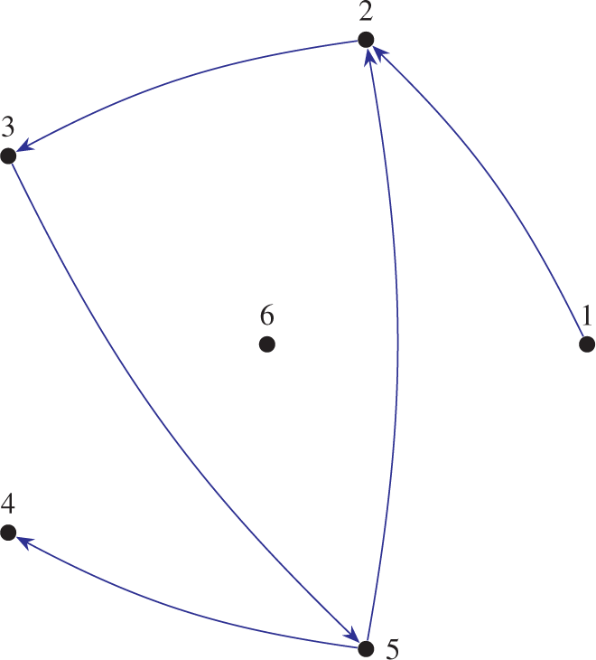

例如，在这里图示的有向图中，节点2是唯一被指向的节点，而该节点不被任何节点指向（即2被指向的节点1，而1则完全不指向）;节点4是唯一被节点指向但自身不指向任何节点的节点。事实上，该图中的每个节点都具有一个可以用指向-指向关系表达的性质，因此该图是可点定义的。相比之下，如果一个数学结构中任意两个不同的对象都能通过某种性质区分，则称该数学结构是莱*布尼茨的*。换句话说，莱布尼茨结构是满足莱布尼茨关于*不可区分元素与*该结构语言中可表达属性的同一性原理的结构。

In the directed graph pictured here, for example, node 2 is the unique node that is pointed at by a node that is not pointed at by any node (namely, 2 is pointed at by 1, which is not pointed at at all); and node 4 is the unique node that is pointed at by a node, yet does not itself point at any node. In fact, every node in this graph is characterized by a property expressible in terms of the pointing-at relation, so this graph is pointwise definable. A mathematical structure is *Leibnizian*, in contrast, if any two distinct objects in the structure can be distinguished by some property. In other words, a Leibnizian structure is one that fulfills Leibniz’s principle on the *identity of indiscernibles* with respect to properties expressible in the language of that structure.

每个逐点可定义结构都是莱布尼茨结构，因为两个不同对象的定义性质会区分它们。但这些概念是不同的。例如，实有序域 ⟨R，+， ·， <，0,1⟩ 是莱布尼茨的，因为对于任意两个不同的实数 *x < y*，它们之间存在有理数，*且 x* 具有 ，而 *y* 没有，这一性质可以用有序域语言表达。但该结构不能逐点定义，因为该结构中只有可数多个可能定义，但实数数量不可数，因此不可能全部可定义。

Every pointwise definable structure is Leibnizian, since the defining properties of two different objects will distinguish them. But the notions are distinct. For example, the real ordered field ⟨ℝ,+, ·, <,0,1⟩ is Leibnizian, since for any two distinct real numbers *x < y*, there is a rational number between them, and *x* has the property that , while *y* does not, and this property is expressible in the language of ordered fields. But this structure is not pointwise definable because there are only countably many possible definitions to use in this structure, but uncountably many real numbers, so they cannot all be definable.

每个莱布尼茨结构都必须是*刚性的*，意味着它不允许非平凡自同构，因为自同构是保持真理的——结构中个体的任何命题为真，在该结构的任何自同构下，其像也同样成立。因此，如果所有个体都可以被识别，那么没有个体可以移动到另一个个体。因此，我们应将莱布尼茨性质视为一种强刚性形式。然而，这两个概念并不相同，因为存在非莱布尼茨的刚性结构。例如，每个良序结构必然是刚性结构，但当序足够大——大于连续统即可时，则不能用所有点的性质来描述，因为语言中没有足够的公式集来区分所有点，因此它不会是莱布尼茨式。事实上，对于任何语言L，每个足够大的L-结构都不会是莱布尼茨式，原因相同。

Every Leibnizian structure must be *rigid*, meaning that it admits no nontrivial automorphism, because automorphisms are truth-preserving—any statement true of an individual in a structure will also be true of its image under any automorphism of the structure. If all individuals are discernible, therefore, then no individual can be moved to another. Because of this, we should look upon the Leibnizian property as a strong form of rigidity. These two concepts are not identical, however, because there can be rigid structures that are not Leibnizian. Every well-order structure, for example, is necessarily rigid, but when an order is sufficiently large—larger than the continuum is enough—then not every point can be characterized by its properties, simply because there aren’t enough sets of formulas in the language to distinguish all the points, and so it will not be Leibnizian. Indeed, for any language ℒ, every sufficiently large ℒ-structure will fail to be Leibnizian for the same reason.

*刚性关系原理*由Hamkins和Palumbo（2012年）提出并研究，是断言每个集合都带有刚性二元关系的数学原理。这是良序原理的推论，因为良序是刚性，但实际上更弱;它是选择公理的中间弱形式，既不等价于选择公理，也无法在没有选择公理的情况下在ZF集合论中证明。

The *rigid relation principle*, introduced and investigated by Hamkins and Palumbo (2012), is the mathematical principle asserting that every set carries a rigid binary relation. This is a consequence of the well-order principle, because well-orders are rigid, but it turns out to be strictly weaker; it is an intermediate weak form of the axiom of choice, neither equivalent to the axiom of choice nor provable in ZF set theory without the axiom of choice.

### **身份在正式语言中的作用** **Role of identity in the formal language**

莱布尼茨结构的性质通常对形式语言中是否包含了等式关系或单位关系 *x* = *y* 的问题敏感。在当代模型论和一阶逻辑的理论中，不言而喻地，平等在每种语言中都被视为逻辑关系，并在每个模型中被解释为实际的平等。当然，这最终是一种惯例，人们可以轻松且合理地在不以这种特殊方式对待平等的情况下进行模型论的变体。

The nature of Leibnizian structures is often sensitive to the question of whether one has included the equality or identity relation *x* = *y* in the formal language. In contemporary approaches to model theory and first-order logic, it often goes without saying that equality is included as a logical relation in every language and interpreted in every model as actual equality. This is ultimately a convention, of course, and one can easily and sensibly undertake a version of model theory without treating equality in this special manner.

当语言中省略等号时，每个模型本质上等价于一个违反莱布尼茨关于不可区分元恒等原理的模型。具体来说，对于无等式语言中的任意模型*M*，考虑一个新模型*M**，该模型通过为*M中任意*或所有元素添加任意数量的重复元素，并根据原结构定义*新结构M**中重复元素的原子关系。例如，在有理数序⟨Q，≤⟩，我们可以考虑⟨Q *，≤⟩，其中每个有理数有两个副本，每个大小于另一个，并与其他元素有序排列，因此例如，0的两个副本都小于任何正元素的副本， 诸如此类。归纳可得，任何对*M*中个体为真的任何无等号命题*φ*（*一个*<sub>0</sub>*， ...，*<sub>*a n*</sub>）也同样适用于其任一重复的个体*φ*（*a*<sub>0</sub>**， ...，*<sub>*a n*</sub>*）。特别地，*结构*M*无法区分个体与其副本，因此如果确实发生了非平凡的重复，该结构也不是莱布尼茨式的。此外，这两个模型的无等号真值断言完全相同;它们在该语言中基本等价。（同时，在等号下我们可以区分这些模型，因为≤在Q中是反对称的，意味着∀*x， y（**x* ≤ *y* ∧*y* ≤*x* → *x* = *y*），但在Q*中这不成立。）

When one omits equality from the language, then every model is elementarily equivalent to a model that violates the Leibnizian principle on the identity of indiscernibles. Specifically, for any model *M* in a language without equality, consider a new model *M** obtained by adding any number of duplicate elements for any or all of the elements of *M*, defining the atomic relations for the duplicates in the new structure *M** in accordance with the original structure. For example, in the rational order ⟨ℚ, ≤ ⟩, we might consider the order ⟨ℚ *, ≤ ⟩ in which every rational number has two copies, each less-than-or-equal to the other and ordered with the other elements as one would expect, so that both copies of 0, for example, are less than any of the copies of positive elements, and so on. It follows inductively that any equality-free statement *φ*(*a*<sub>0</sub>*, …, a*<sub>*n*</sub>) true of individuals in *M* will also be true in *M** of any of their duplicates *φ*(*a*<sub>0</sub>**, …, a*<sub>*n*</sub>*). In particular, the structure *M** will not be able to discern an individual from its copies, and so this structure will not be Leibnizian if indeed any nontrivial duplication occurred. Furthermore, the two models have exactly the same equality-free truth assertions; they are elementarily equivalent in that language. (Meanwhile, with equality we can distinguish the models, since ≤ is anti-symmetric in ℚ, meaning that ∀*x, y* (*x* ≤ *y* ∧ *y* ≤ *x* → *x* = *y*), but this is not true in ℚ*.)

哲学上要强调的是，除非语言明确包含等价关系，否则理论永远不能产生莱布尼茨的不可区分元素同一性原理。特别地，你对非空结构的任何描述都无法保证它是莱布尼茨的，除非明确提及相等，因为该结构与对应的每个个体都被复制的结构具有相同的无相号断言。

The philosophical point to make about this is that one can never expect a theory to give rise to the Leibnizian principle of identity of indiscernibles, unless the language includes the equality relation explicitly. In particular, nothing you say about a nonempty structure can possibly ensure that it is Leibnizian, unless equality is explicitly mentioned, since the structure has all the same equality-free assertions as the corresponding structure in which every individual has been duplicated.

### **同构轨道** **Isomorphism orbit**

虽然可定义性甚至可辨性足以捕捉物体的结构性角色，但它们并非必要，更完整的解释将来自同构轨道的概念。具体来说，两个数学结构*A和**B*同*构*，如果它们彼此是复制品，或者更准确地说，存在同*构π*：*A*→*B*，即结构各自定义域之间一一对应或双射映射，且尊重显著的结构关系和运算。例如，线性阶 ⟨L1， ≤1⟩ 和 ⟨L2， ≤2⟩ 的序同构是两个阶的定义域之间的双射*π*：*L*<sub>1</sub> → *L*<sub>2</sub>，保持了从一个阶到另一个的序结构，意味着 *x* ≤<sub>1</sub>*y* 当且仅当 *π*（*x*） ≤<sub>2</sub>*π**（y ）*).算术结构的同构 ⟨Y，+，·⟩ 和 ⟨Z，⊕，在 ⊗⟩ 是一个双射 *τ*： *Y*→ *Z*，其中 *τ*（*a* + *b*） = *τ*（*a*） ⊕ *τ*（*b*） 和 *τ*（*a* ·*b*） = *τ*（*a*） ⊙ *τ*（*b*），将结构从 *Y* 翻译到 *Z*。每个数学结构概念都伴随着相应的同构概念。

While definability and even discernibility are sufficient for capturing the structural roles played by an object, they are not necessary, and a fuller account will arise from the notion of an isomorphism orbit. Specifically, two mathematical structures *A* and *B* are *isomorphic* if they are copies of one another, or more precisely, if there is an *isomorphism π*: *A* → *B* between them, a one-to-one correspondence or bijective map between the respective domains of the structures that respects the salient structural relations and operations. For example, an order isomorphism of linear orders ⟨L1, ≤1⟩ and ⟨L2, ≤2⟩ is a bijection *π*: *L*<sub>1</sub> → *L*<sub>2</sub> between the domains of the orders that preserves the order structure from one to the other, meaning that *x* ≤<sub>1</sub>*y* if and only if *π*(*x*) ≤<sub>2</sub>*π*(*y*). An isomorphism of arithmetic structures ⟨Y,+,·⟩ and ⟨Z,⊕, ⊗⟩ is a bijection *τ*: *Y*→ *Z*, for which *τ*(*a* + *b*) = *τ*(*a*) ⊕ *τ*(*b*) and *τ*(*a* · *b*) = *τ*(*a*) ⊙ *τ*(*b*), translating the structure from *Y* to *Z*. Every mathematical structural conception is accompanied by a corresponding isomorphism concept.

同构概念与形式语言紧密相连，形式语言是一种精确确定所考虑的数学结构的方法。毕竟，某一一对应是否同构关键取决于哪些结构特征被视为突出。人们是只把有理数作为一个有序的，还是作为有序域来考虑？给定的双射可能只保留结构的一部分。

The isomorphism concept is intricately linked with that of formal language, which is a way of making precise exactly which mathematical structure one is considering. Whether a given one-to-one correspondence is an isomorphism depends crucially, after all, on which structural features are deemed salient. Is one considering the rational numbers only as an order, or as an ordered field? A given bijection may preserve only part of the structure.

结构角色由同构所尊重，事实上，它们*正是*同构所尊重的。结构*A*中的对象*a*与结构*B**中的对象*b在存在A的同构*且B携带**a*到*b*时，扮演相同的*结构角色*。

Structural roles are respected by isomorphism, and indeed, they are *exactly* what is respected by isomorphism. An object *a* in structure *A* plays the same *structural role* as object *b* in structure *B* exactly when there is an isomorphism of *A* with *B* carrying *a* to *b*.

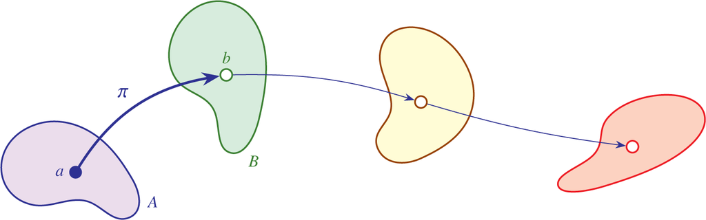

因此，让我们考虑结构中对象的*同构轨道*，即对象/结构对（*a， A*）相对于相同结构角色-As 关系的等价类。

So let us consider the *isomorphism orbit* of an object in a structure, the equivalence class of the object/structure pair (*a, A*) with respect to the same-structural-role-as relation.

[figure not shown]

该轨道追踪 *a* 如何被复制到所有与 *A* 同构的结构中的所有同构图像。无论这些物体在结构中是否可定义或可辨识，正是出现在同构轨道上的物体在这些结构中扮演与*A*在*A*中相同的结构角色。

This orbit tracks how *a* is copied to all its various isomorphic images in all the various structures isomorphic to *A*. And whether or not these objects are definable or discernible in their structures, it is precisely the objects appearing in the isomorphism orbit that play the same structural role in those structures that *a* plays in *A*.

### **分类性** **Categoricity**

如果一个理论的所有模型都是同构的，则该理论是*范畴的*。在这种情况下，理论完全捕捉了其试图描述的结构本质，并将该结构描述为同构。例如，德德金已经分离出算术的基本原理，并证明它们在同构下能刻画自然数;任意两个模型同构。换句话说，他证明了自己的理论是绝对性的。

A theory is *categorical* if all models of it are isomorphic. In such a case, the theory completely captures the structural essence of what it is trying to describe, characterizing that structure up to isomorphism. Dedekind, for example, had isolated fundamental principles of arithmetic and proved that they characterized the natural numbers up to isomorphism; any two models are isomorphic. In other words, he proved that his theory is categorical.

类似的成就早已被几乎所有熟悉的数学结构所实现，我们不仅有自然数N的范畴刻画，还有整数环Z、有理数域Q、实数域R、复数域C的范畴刻画，以及更多（参见第1.11节和第1.13节）。Daniel Isaacson（2011）强调范畴性在识别特定数学结构中的作用。也就是说，我们熟悉了一种结构;我们发现了该结构的基本特征;然后我们证明这些特征在同构下公理化地刻画了该结构。对艾萨克森来说，这就是识别特定数学结构的含义，比如自然数、整数、实数，甚至集合论宇宙。

The analogous feat has long been performed for essentially all the familiar mathematical structures, and we have categorical characterizations not only of the natural numbers ℕ, but of the ring of integers ℤ, the field of rational numbers ℚ, the field of real numbers ℝ, the field of complex numbers ℂ, and many more (see sections 1.11 and 1.13). Daniel Isaacson (2011) emphasizes the role that categoricity plays in identifying particular mathematical structures. Namely, we become familiar with a structure; we find the essential features of that structure; and then we prove that those features axiomatically characterize the structure up to isomorphism. For Isaacson, this is what it means to identify a particular mathematical structure, such as the natural numbers, the integers, the real numbers, or indeed, even the set-theoretic universe.

范畴性是结构主义的核心，因为它表明我们熟悉的数学领域，包括N、Z、Q、R、C等，的本质是由我们可以识别和表达的结构特征决定的。事实上，除了确定一个在其中为真的范畴理论，我们还怎么可能挑出一个确定的数学结构呢？由于范畴性，我们无需建立一个标准的自然数典范副本，比如巴黎保存的铁棒定义标准韵律;相反，我们可以通过研究某一结构是否符合类别特征，独立调查其是否具备正确的结构特征。

Categoricity is central to structuralism because it shows that the essence of our familiar mathematical domains, including ℕ, ℤ, ℚ, ℝ, ℂ, and so on, are determined by structural features that we can identify and express. Indeed, how else could we ever pick out a definite mathematical structure, except by identifying a categorical theory that is true in it? Because of categoricity, we need not set up a standard canonical copy of the natural numbers, like the iron rod kept in Paris that defined the standard meter; rather, we can investigate independently whether any given structure exhibits the right structural features by investigating whether it fulfills the categorical characterization.

出于深层原因，这些范畴性刻画通常使用二阶逻辑，意味着它们的基本公理不仅涉及对域内个体的量化，还涉及对域内任意个体或关系的量化。例如，Dedekind算术断言了任意自然数集合的归纳公理，我们将在第1.11节看到Dedekind对实数的完备性公理涉及对任意有界有理数集合进行量化。

Invariably, for deep reasons, these categorical characterizations use second-order logic, meaning that their fundamental axioms involve quantification not only over the individuals of the domain, but also over arbitrary sets of individuals or relations on the domain. Dedekind’s arithmetic, for example, asserts the induction axiom for arbitrary sets of natural numbers, and we shall see in section 1.11 that Dedekind’s completeness axiom for the real numbers involves quantifying over arbitrary bounded sets of rational numbers.

其深层原因在于，一个纯粹的一阶理论，其公理仅涉及对结构中个体的定义域进行量化，而非对任意个体集合进行量化，永远无法对无限结构做出绝对的刻画。这是勒文海姆-斯科勒姆定理的推论，该定理表明，在无限模型中为真的每一个一阶理论，在具有多种无限基数的模型中也同样成立，因此这些模型不可能同构。与此同时，勒文海姆-斯科伦定理不适用于二阶理论，因此在描述我们熟悉的数学结构的范论理论中发现二阶公理也就不足为奇了。

The deep reasons are that a purely first-order theory, one whose axioms involve quantification only over the domain of individuals in a structure rather than over arbitrary sets of individuals, can never provide a categorical characterization of an infinite structure. This is a consequence of the Löwenheim-Skolem theorem, which shows that every first-order theory that is true in an infinite model is also true in models of diverse infinite cardinalities, which therefore cannot be isomorphic. Meanwhile, the Löwenheim-Skolem theorem does not apply to second-order theories, and it should be no surprise to find second-order axioms in the categorical theories characterizing our familiar mathematical structures.

一些哲学家反对，我们无法通过二阶范畴性刻画来识别或确定我们基本数学结构的确定性。相反，我们只相对于集合论背景进行此分析，而这些背景并非绝对的。该提议是我们知道自然数结构的含义——它是一个确定结构——因为Dedekind算术对该结构具有唯一特征，直到同构。反对意见在于，德德金算术根本上依赖于任意数集合的概念，而这一概念本身不如我们所关注的自然数概念更不安全和确定。如果我们对自然数的确定性存疑，如何通过依赖相对不确定的“任意集合”概念来论证？有哪些合集？范畴性论证发生在一个集合论领域，需要建立其自身的确定性质，才能用它来确定自然数的确定性。

Some philosophers object that we cannot identify or secure the definiteness of our fundamental mathematical structures by means of second-order categoricity characterizations. Rather, we only do so relative to a set-theoretic background, and these backgrounds are not absolute. The proposal is that we know what we mean by the structure of the natural numbers—it is a definite structure—because Dedekind arithmetic characterizes this structure uniquely up to isomorphism. The objection is that Dedekind arithmetic relies fundamentally on the concept of arbitrary collections of numbers, a concept that is itself less secure and definite than the natural-number concept with which we are concerned. If we had doubts about the definiteness of the natural numbers, how can we assuaged by an argument relying on the comparatively indefinite concept of “arbitrary collection”? Which collections are there? The categoricity argument takes place in a set-theoretic realm, whose own definite nature would need to be established in order to use it to establish definiteness for the natural numbers.

### **数学实践中的结构主义** **Structuralism in mathematical practice**

我想对比几种结构主义形式，首先区分一种在数学家中广泛流行的结构主义形式——我称之为*实践中的结构主义*。结构主义在实践中涉及关于如何进行数学的必然性，即对哪些数学研究将有成效的观点。根据结构主义实践者的观点，数学关乎数学结构，数学家应仅以结构主义方式陈述和证明结构主义定理。所有数学概念在同构下都应保持不变。

I should like to contrast several forms of structuralism, distinguishing first a form of structuralism that is widespread amongst mathematicians—a form which I call *structuralism in practice*. Structuralism in practice involves an imperative about how to undertake mathematics, a view about which kinds of mathematical investigations will be fruitful. According to the structuralist-in-practice, mathematics is about mathematical structure, and mathematicians should state and prove only structuralist theorems in a structuralist manner. All of one’s mathematical concepts should be invariant under isomorphisms.

**结构主义的必然性。** *为了获得数学洞察，可以研究数学结构、数学系统中实体之间的关系，并且仅将数学概念视为在同构下不变。因此，不要关心单个数学对象的实质，因为这在数学上是徒劳的，因为结构是从任何对象中产生。*

**The structuralist imperative.** *For mathematical insight, investigate mathematical structure, the relations among entities in a mathematical system, and consider mathematical concepts only as being invariant under isomorphism. Therefore, do not concern yourself with the substance of individual mathematical objects, for this is mathematically fruitless as structure arises with any kind of object.*

根据结构主义命令，关于特定数学结构实例的定理陈述数学上是错误的;例如，涉及实数的定理应以使其在同构下保持不变的方式进行;应能用任何其他完备有序域替换实数，同时保持定理的真实性。实践中的结构主义者将关于数学对象“真实本质”——即数字“实际上”是什么——的问题视为数学上无关紧要。

According to the structuralist imperative, it would be mathematically misguided to state theorems about particular instantiations of mathematical structure; a theorem involving the real numbers, for example, should do so in a way that it becomes invariant under isomorphism; one should be able to replace the real numbers with any other complete ordered field, while preserving the truth of the theorem. The structuralist-in-practice dismisses questions about the “true nature” of mathematical objects—about what numbers “actually” are—as mathematically irrelevant.

例如，如果将该术语取为具有有限模式性质的任意可数图，而有限模式性质的特征则能在同构范围内刻画这些图，那么它将符合结构主义命令，证明关于可数随机图的定理。例如，可以证明可数随机图是齐次的，或者它的直径为二，或者是无限色数;这实际上意味着所有具有有限模式性质的可数图都具有这些特征。由于假设在同构下不变，我们不在意所用的可数随机图的具体副本，这正是结构主义的核心。

It would accord with the structuralist imperative, for example, to prove a theorem about the countable random graph if one takes this term to refer to any countable graph with the finite pattern property, a feature that characterizes these graphs up to isomorphism. One might prove, for example, that the countable random graph is homogeneous or that it has diameter two or an infinite chromatic number; what this really means is that all such countable graphs with the finite pattern property have these features. Because the hypothesis is invariant under isomorphism, we do not care which particular copy of the countable random graph we are using, and this is the heart of structuralism.

相比之下，如果只针对拉多图具体描述这些定理，如果将其视为自然数上有*n和**m*之间的特定图关系，其中*n<*m，且*m的第**n*个二进制数字为1，则则是反结构主义的;该图恰好具有有限模式性质，因此它是可数随机图的一个特定实例（一旦固定了自然数的副本）。

It would be antistructuralist, in contrast, to state those theorems specifically only about the Rado graph if this is taken to refer to the specific graph relation on the natural numbers with an edge between *n* and *m*, where *n < m*, if the *n*th binary digit of *m* is 1; this graph happens to exhibit the finite pattern property, and therefore it is a specific instance of the countable random graph (once one has fixed a copy of the natural numbers).

注意，逻辑上证明关于可数随机图的某些内容，即便具体证明关于拉多图，即使使用拉多图的特定特征，前提是该定理本身在图同构下保持不变，因为这样它就能从拉多图转移到可数随机图的所有副本上。从这个意义上说，结构主义在实践中似乎只要求定理是结构主义的，即它们在同构下是完全不变的。

Notice that it would be fine, logically, to prove something about the countable random graph by proving it specifically about the Rado graph, even using specific features of the Rado graph, provided that the theorem itself was invariant under graph isomorphisms, for then it would transfer from the Rado graph to all copies of the countable random graph. In this sense, it might seem that structuralism in practice requires only that one’s theorems are structuralist, that is, that they are properly invariant under isomorphism.

然而，结构主义命令则反对这种证明方式，即便看似方便时，也不要使用自己特定解释实例的非结构性细节。原因在于这些细节从未成为数学现象的核心——它们总是干扰——正因为这些细节对定理的结构主义结论来说无关紧要。如果你有一个用特定实例的偶然细节证明的同构不变量定理，那么数学结构主义者会说你的论证很差;你忽略了关键点;你的论证不会带来数学上的洞见。从这个意义上说，结构主义命令是关于数学效能的建议。也就是说，通过进行结构性论证，我们将更接近数学真理的追踪。

Yet, the structuralist imperative recommends against that style of proof, against using nonstructural details of one’s specific interpretation instances, even when they might seem convenient. The reason is that those details never lie at the core of the mathematical phenomenon—they are always a distraction—precisely because they cannot matter for the structuralist conclusion of the theorem. If you have a proof of an isomorphism-invariant theorem that uses incidental details of a specific instantiation, then the mathematical structuralist will say that you have a poor argument; you have missed the essential point; and your argument will not produce mathematical insight. In this sense, the structuralist imperative is a recommendation about mathematical efficacy. Namely, by undertaking structural arguments, we will stay closer on the trail of mathematical truth.

与此同时，如果有人关心拉多图中某些额外结构，那么证明关于拉多图的定理将是结构主义的。例如，Rado 图的边关系在自然数上是一个可计算判定关系，但并非每个自然数上的可数随机图副本都是可计算判定的。在这种情况下，我们实际上并不是在研究仅仅有其图结构的可数随机图，而是在研究可计算模型理论，考察该图表示方式的计算复杂性。这同样是结构性的，但附加的结构超越了纯图论。

Meanwhile, it would be structuralist to prove theorems about the Rado graph if one was concerned with some of the extra structure inherent in that particular presentation of this graph. For example, the edge relation of the Rado graph is a computably decidable relation on the natural numbers, but not every copy of the countable random graph on the natural numbers is computably decidable. In this case, one is not really studying the countable random graph, with only its graph structure, but rather one is studying computable model theory, looking at the computational complexity of presentations of this graph. This is again structural, but with different additional structure beyond pure graph theory.

用结构主义的比喻来类比计算机编程。结构主义编程方法仅根据定义数据类型中的结构特征来处理数据对象;这种编程方式通常可以移植到其他操作系统和该编程语言的实现中。如果程序利用某一部分数据在特定系统上的表示细节，窥探机器内部的数据编码，那将是反结构主义的;这种偷偷摸摸地获取数据的方式起初可能有效，但常常导致可移植性问题，因为当换到另一台机器时，这些方法可能会失败，而机器可能在“底层”对数据表示不同。

Consider a structuralist analogy with computer programming. A structuralist approach to programming treats its data objects only with respect to the structural features explicitly in the defining data types; this way of programming is often portable to other operating systems and implementations of the programming language. It would be antistructuralist for a program to use details of how a particular piece of data is represented on a particular system, to peek into the internal coding of data in the machine; this sneaky way of getting at the data might work fine at first, but it often causes portability issues because the methods can fail when one changes to a different machine, which might represent the data differently “under the hood,” so to speak.

结构主义命令往往让人远离垃圾定理现象，因为垃圾常常被特别反对，特别是因为它是反结构主义的（但请以问题1.19作为对照）。实践中的结构主义者认为尤利乌斯·凯撒的反对是误导性的，因为基数是什么并不重要，只要它们遵循康托尔-休谟原则，我们并不在意其中是否有一个是尤利乌斯·凯撒。事实上，我们可以轻易定义一个数字解释，其中尤利乌斯·凯撒是数字17，或者不是，我们的理论中无论如何都成立。这其中没有任何数学上的利害关系。

The structuralist imperative tends to lead one away from the junk-theorem phenomenon, for junk is often particularly objected to, specifically because it is antistructuralist (but consider question 1.19 as a counterpoint). The structuralist-in-practice dismisses the Julius Caesar objection as misguided, for it does not matter what the cardinal numbers are, so long as they obey the Cantor-Hume principle, and so we do not care if any of them are Julius Caesar or not. Indeed, we can easily define an interpretation of number in which Julius Caesar is the number 17, or not, and everything in our theory will work fine either way. There is nothing mathematical at stake in it.

一些数学家强调，在某些范畴论基础中，如ETCS中，这些系统所提供的形式语言*必*然在同构下保持不变。因此，在使用这些语言时，人们不得不遵循结构主义的命令。

Some mathematicians have emphasized that in some of the category-theoretic foundations, such as in ETCS, the formal languages provided for these systems are *necessarily* invariant under isomorphisms. When working in those languages, therefore, one cannot help but follow the structuralist imperative.

### **消除结构主义** **Eliminative structuralism**

我所称的*结构主义在实践*中与*消除结构主义*（也称为*后快速眼期结构主义*）密切相关，后者由Benacerraf（1965）所捍卫——即数学结构仅仅是具体结构中所体现的事物。消极结构主义包括唯名论主张，即除了特定实例中的表征外，没有抽象对象即数学结构本身。没有什么抽象的东西是“数字3”——任何对象都可以在合适的结构中扮演这个角色——因此谈论数字和其他特定的数学对象只是工具性的。Shapiro（1996）说：“因此，数字不是真正的奇异项，而是伪装的界限变量。”提到数字3实际上意味着：*在当前的Dedekind算术模型中，是零的后继*。

What I am calling *structuralism in practice* is closely related to *eliminative structuralism* (also called *post-rem structuralism*), defended by Benacerraf (1965)—namely, the view that mathematical structure is simply that which is instantiated in particular structures. Eliminative structuralism includes the nominalist claim that there is no abstract object that is the mathematical structure itself, beyond representations in particular instantiations. There is no abstract thing that is “the number 3”—any object can play that role in a suitable structure—and so talk of numbers and other particular mathematical objects is merely instrumental. Shapiro (1996) says, “Accordingly, numerals are not genuine singular terms, but are disguised bound variables.” A reference to the number 3 really means: *in the model of Dedekind arithmetic at hand, the successor of the successor of the successor of zero*.

然而，实践中的结构主义与排除结构主义的一个区别在于，实践中的结构主义放弃了消除主张，即名义论本体论中抽象结构对象不存在;实际上，结构主义者在实践中只是遵循结构主义的命令，追求同构不变数学，无论是否存在抽象结构对象。既然消除主义不在观点中，称之为消除结构主义似乎不对。

One difference between structuralism in practice and eliminative structuralism, however, is that the structuralist-in-practice drops the elimination claim, the nominalist ontological claim that abstract structural objects do not exist; rather, the structuralist-in-practice simply follows the structuralist imperative to pursue isomorphism-invariant mathematics, whether abstract structural objects exist or not. And since elimination is not part of the view, it would seem wrong to call it eliminative structuralism.

消去结构主义的另一种形式是*模态结构主义*的观点，也称为*in-re 结构主义*，由Geoffrey Hellman辩护，认为关于数学对象的断言应被理解为对其可能实例化的必要主张。根据这一观点，数学结构在本体论上依赖于所体现的系统。在极端情况下，人们可能希望最终将数学结构简化为具体的物理系统。还有一种相对形式的消灭结构主义，将结构简化为集合。即，根据*集合论还原主义*——一种极端形式的集合论基础主义，结构不存在于其集合论实现之外，例如通过同构轨道实现。这与仅仅将集合论作为数学基础不同，因为人们可以通过解释集合论中的数学结构来提出集合论作为基础，而不必坚持集合论之外不存在结构。

Another form of eliminative structuralism is the view of *modal structuralism*, also called *in-re structuralism* and defended by Geoffrey Hellman, according to which assertions about mathematical objects are to be understood modally as necessary claims about their possible instantiations. According to this view, mathematical structures are ontologically dependent on the systems that exemplify them. In extreme form, one might hope to reduce mathematical structure ultimately to concrete physical systems. And there is also a relative form of eliminative structuralism, which reduces structure to sets. Namely, according to *set-theoretic reductionism*, an extreme form of set-theoretic foundationalism, structure does not exist apart from its set-theoretic realizations, such as by means of the isomorphism orbit. This is different from merely using set theory as a foundation of mathematics, since one can propose set theory as a foundation simply by interpreting mathematical structure within set theory, without insisting that there is no structure outside of set theory.

### **抽象结构主义** **Abstract structuralism**

结构主义数学家虽然遵循结构主义命令，却乐于*引用自然数**、数字*17*和实*数*π*，这有些令人费解。毕竟，如果我们只关心自然数（同构）的部分，那么就不再存在对应这些术语的唯一数学对象或结构，那么这里的“the”是什么意思？实际上，结构主义者似乎应该指*的是自然数**或数字*17。但数学家通常不会这样说，即使他们是结构主义者。结构主义似乎在单一指称问题上面临严重问题。

There is something a little puzzling about the structuralist mathematician, who follows the structuralist imperative, yet happily refers to *the* natural numbers and *the* number 17 and *the* real number *π*. If we only care about the natural numbers up to isomorphism, after all, then there is not any longer a unique mathematical object or structure corresponding to these terms, and so what is meant by “the” here? It would seem that the structuralist-in-practice should be referring instead to *a* natural numbers or *a* number 17. But mathematicians do not generally talk that way, even when they are structuralist. Structuralism seems to face a serious problem with singular reference.

诚然，大多数数学家在被问及其单一参考时，表达的是结构主义实践观点。他们说，对他们来说，我们用的是哪一本自然数并不重要，他们所说的17是指在我们当前拥有的版本中扮演该角色的对象。因此，他们认真地插入了夏皮罗伪装的量词。

To be sure, most mathematicians, when pressed about their singular references, articulate the structuralist-in-practice view. They say that it does not matter to them which copy of the natural numbers we use, and that by 17, they mean to refer to the object playing that role in whichever version we currently have. Thus, they have dutifully inserted Shapiro’s disguised quantifiers.

但一些哲学家致力于为单一指称问题提供更稳健的解决方案。根据抽象*结构主义*，也称为*前REM结构主义*，由Stewart Shapiro（1997）、Michael Resnik（1988）等人辩护，数学的对象，包括数字、函数和集合，本质上是结构性的;它们作为纯粹的结构抽象对象存在，是结构中的位置，是排列模式中的位置，可能以多种实例形式实现。四分卫是美式橄榄球队中的一个位置，指的是指挥战术、接球和传球的人。每个四分卫都是一个人，而非一个位置——是扮演特定球队四分卫角色的人。同样，自然数3是自然数结构中的第三个后继“位置”——即任何特定3的副本在自然数的具体实例中所占据的位置。从这种观点看，数学结构独立于具体实例化该结构的具体系统存在。

But some philosophers aim for a more robust solution to the problem of singular reference. According to *abstract structuralism*, also known as *ante-rem structuralism*, defended by Stewart Shapiro (1997), Michael Resnik (1988), and others, the objects of mathematics, including numbers, functions, and sets, are inherently structural; they exist as purely structural abstract objects, positions within a structure, locations in a pattern of arrangement that might be realized in diverse instantiations. The quarterback is a position on an American football team, the role played by the person who calls the play, receives the hike and makes the passes. Each individual quarterback is a person rather than a position—a person who plays the role of quarterback on a particular team. Similarly, the natural number 3 is the third successor “location” in the natural number structure—the position that any particular copy of 3 fills in any particular instantiation of the natural numbers. On this view, mathematical structure exists independently of the particular systems instantiating that structure.

抽象结构主义直接解释了数学中奇异项的指称，解释数字*3和自然*数如何从结构主义视角合理地指向纯结构对象或这些实体所扮演的抽象结构角色。人们采用弗雷格式的抽象过程，从相同结构角色关系中抽象出来，其等价类正是同构轨道。每个同构轨道通过抽象引导到对应的抽象结构角色。夏皮罗还认为，就像马迪在蛋盒论证中（见第21页提到）一样，抽象结构主义为贝纳塞拉夫的认识论问题提供了解决方案：我们获得有限的抽象结构实例，然后通过抽象推进到结构本身。

Abstract structuralism provides a direct account of the reference of singular terms in mathematics, explaining how *the* number 3 and *the* natural numbers can sensibly refer, even from a structuralist perspective, to the purely structural object or the abstract structural role played by these entities. One undertakes the Fregean process of abstraction from the same-structural-role relation, whose equivalence classes are precisely the isomorphism orbits. Every isomorphism orbit leads one by abstraction to a corresponding abstract structural role. Shapiro also argues, much like Maddy in the egg carton argument (mentioned on page 21), that abstract structuralism offers a solution to Benacerraf’s epistemological problem: we gain access to finite instances of abstract structures and then proceed by abstraction to the structure itself.

抽象结构主义者通过将数学对象视为纯结构性，提供结构主义的数学解释。然而，实践中的结构主义者会说，这种抽象结构主义根本不是结构主义——它违反了结构主义命令——正是因为它关注的是数学对象是什么，即使它给出的答案是它们纯粹是结构性的。根据实践结构主义者的观点，这种担忧是误导性的;它们从未阐明过数学现象，对数学洞见也无关紧要。实践中的结构主义者乐于考虑任何同构轨道关系的分类不变量，比如轨道本身（类似于弗雷格将数字视为等值类），而无需纯结构抽象对象来代表结构角色。

The abstract structuralist is providing a structuralist account of mathematics by realizing mathematical objects as purely structural. Yet, the structuralist-in-practice will say that this form of abstract structuralism is not structuralist at all—it violates the structuralist imperative—precisely because it is concerned with what the mathematical objects are, even if the answer it provides is that they are purely structural. According to the structuralist-in-practice, such concerns are misguided; they never elucidate a mathematical phenomenon and are irrelevant for mathematical insight. The structuralist-in-practice will happily consider any classification invariant of the isomorphism orbit relation, such as the orbit itself (akin to Frege taking numbers as equinumerosity classes), without the need for a purely structural abstract object representing the structural role.

然而，抽象结构主义者可能会回答：“好吧，我们追求抽象结构主义不是为了数学洞见，而是作为数学本体论中的哲学探究，旨在理解数学结构的真正含义。”抽象结构主义者试图识别并阐明数学对象的本质，这是一种哲学努力而非数学努力。抽象结构主义者试图解释*结构是什么*——数学家们认为是如此根本的东西。

Yet, the abstract structuralist may reply, “Fine, we do not pursue abstract structuralism for mathematical insight, but rather as a philosophical investigation in mathematical ontology, aiming to understand what mathematical structure really is.” The abstract structuralist seeks to identify and elucidate the essential nature of mathematical objects, a philosophical effort rather than a mathematical one. The abstract structuralist seeks to give an account of *what structure is*—the thing that the mathematicians take to be so fundamental.

## **1.11 什么是实数？** **1.11 What is a real number?**

让我们考虑真实连续体。无理数的经典发现揭示了有理数线中的空隙：如果是有理数，该位置是有理数线上的一个洞。因此，有理数被视为不完备的。人们试图补全它们，填补这些空洞，形成实数线 R。

Let us consider the real continuum. The classical discovery of irrational numbers reveals gaps in the rational number line: the place where would be, if it were rational, is a hole in the rational line. Thus, the rational numbers are seen to be incomplete. One seeks to complete them, to fill these holes, forming the real number line ℝ.

### **德德金切割** **Dedekind cuts**

Dedekind（1901年，第一节第3节）观察到每个实数都将直线一分为二，并在该思想中发现了一个表达连续性本质的原则：

Dedekind (1901, I.§3) observed how every real number cuts the line in two and found in that idea a principle expressing the essence of continuity:

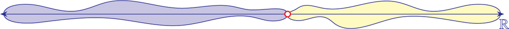

如果直线上的所有点都分为两类，使得第一类的每个点都位于第二类的每个点的左侧，那么存在唯一一个点能产生将所有点划分为两类，即将直线切分为两部分。

If all points of the straight line fall into two classes such that every point of the first class lies to the left of every point of the second class, then there exists one and only one point which produces this division of all points into two classes, this severing of the straight line into two portions.

对于德德金来说，真实数是我们现在所说*的德德金完全*数：每个割位都被填满。在有理直线中，一些由有理数确定的割已经被填满;但其他割对应的是有理线上的空洞，尚未填补。对于任何这样的未被填满的割，德德金提出我们可以在思想中想象或“创造”一个无理数，恰恰是为了填补它。这样，我们将实数线实现为有理数线的Dedekind完备化。

For Dedekind, the real numbers are what we now call *Dedekind complete*: every cut is filled. In the rational line, some cuts, determined by a rational number, are already filled; but other cuts correspond to holes in the rational line, not yet filled. For any such unfilled cut, Dedekind proposes that we may imagine or “create” an irrational number in thought precisely to fill it. In this way, we shall realize the real number line as the Dedekind-completion of the rational number line.

如果我们确定空间是不连续的，那么如果我们愿意，就没有什么能阻止我们填补空间的空白，思考中，从而使空间连续;这种填充意味着创造新的点个体，必须按照上述原则进行。（德德金德，1901年，第一节第3节）

And if we knew for certain that space was discontinuous there would be nothing to prevent us, in case we so desired, from filling up its gaps, in thought, and thus making it continuous; this filling up would consist in a creation of new point-individuals and would have to be effected in accordance with the above principle. (Dedekind, 1901, I.§3)

### **盗窃与诚实劳作** **Theft and honest toil**

罗素解释了如何明确地进行这一创造过程，将实数构建为满足德德金完备性质的数学结构。在一个极为优雅的构造中，他从所有德德金割本身的集合中形成有理直线的德德金完备化，将每个割视为一个新的点。有理直线上的*Dedekind割*是有界且非空的有序初始段，且无最大元素。无最大元素的要求确保有理数唯一表示，否则我们可以将有理极限点放在任一侧，形成两个截然不同的割，而只需一个割。

Russell explains how one may undertake this creation process explicitly, building the real numbers as a mathematical structure that fulfills Dedekind’s completeness property. In a truly elegant construction, he forms the Dedekind-completion of the rational line from the set of all Dedekind cuts themselves, viewing each cut as constituting a single new point. A *Dedekind cut* in the rational line is a bounded nonempty initial segment of the rationals with no largest element. The no-largest-element requirement ensures that rational numbers are represented uniquely, since otherwise we could place the rational limit point on either side, forming two distinct cuts where only one is wanted.

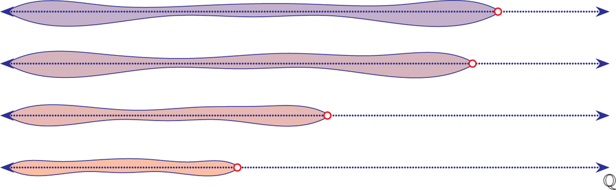

在拉塞尔的指导下，我们形成了所有德德金切割的集合，将每一个都视为一个新的点;我们在它们上定义自然序（它只是割面上的包含序⊆）;我们很容易证明这个新序是Dedekind完备的（任何有界割集的并本身就是最小上界的割）;我们将有理数的域运算扩展到割集，定义了加任意两个割或乘它们的含义;我们证明这些运算和序使得切割集映射到有序域。因此，我们构造实数，作为Dedekind割，形成一个Dedekind完备有序域。

Toiling under Russell’s direction, we form the set of all Dedekind cuts, viewing each as a single new point; we define the natural order upon them (it is just the inclusion order ⊆ on the cuts); we prove easily that this new order is Dedekind complete (the union of any bounded set of cuts is itself a cut that is the least upper bound); we extend the field operations from the rational numbers to the set of cuts, defining what it means to add any two cuts or multiply them; and we prove that these operations and order make the set of cuts into an ordered field. Thus, we construct the real numbers as Dedekind cuts, forming a Dedekind-complete ordered field.

虽然可以想象德德金割源自实数，但这样做恰恰是逻辑的反向。相反，我们希望通过削减来定义*真实数字，*或者至少可能是多少。根据该说法，实数是有理数中的Dedekind割。事实上，罗素（1919年，第71页）对德德金的公理化方法提出了严厉批评，该方法假设实数是德德金完全的。

Although one can imagine the Dedekind cuts as arising from the real numbers, to do so is precisely the inverse of the intended logic. Rather, we seek to use the cuts to define *what the real numbers are*, or at least what they could be. According to this account, a real number is a Dedekind cut in the rational numbers. Indeed, Russell (1919, p. 71) makes a withering criticism of Dedekind’s axiomatic approach, by which one postulates that the real numbers are Dedekind complete.

“假设”我们想要的东西的方法有许多优点;它们和盗窃相比正当劳动的优势是一样的。让我们把这些留给别人，继续我们诚实的劳动。

The method of “postulating” what we want has many advantages; they are the same as the advantages of theft over honest toil. Let us leave them to others and proceed with our honest toil.

罗素的“诚实劳动”是通过这里描述的德德金割构造实数，证明最终结构是德德金完备的，而不仅仅是假设实数已经是德德金完备的。

Russell’s “honest toil” was to construct the real numbers via Dedekind cuts as described here, proving that the resulting structure is Dedekind complete, rather than merely postulating that the real numbers are already Dedekind complete.

### **柯西实数** **Cauchy real numbers**

另一种连续性概念由奥古斯丁-路易·柯西提出，他的灵感来自于每个实数都是收敛于其的各种有理序列极限的观点。如果实数列中的点最终彼此接近，则称该实*数列为柯西序列*。实数的连续性由*柯西完备*性表达，即每个柯西序列都收敛到极限实数的性质。

An alternative continuity concept is provided by Augustin-Louis Cauchy, who was inspired by the idea that every real number is the limit of the various rational sequences converging to it. A sequence of real numbers is a *Cauchy sequence* if the points in the sequence become eventually as close as desired to one another. The continuity of the real numbers is expressed by *Cauchy completeness*, the property that every Cauchy sequence converges to a limiting real number.

当然，有理直线不是柯西完备的，因为存在柯西序列收敛到，其中将是，但该序列的极限没有有理数。其他无理数也是如此。但可以通过考虑所有可能的柯西序列来形成有理数的柯西完备化。如果两个这样的序列最终彼此接近，则它们是等价的，我们可以将实数组成柯西序列的等价类集合。这允许自然有序场结构;它是阿基米德式的;并且它是柯西完全的。根据该说法，实数是柯西序列的一个等价类。

The rational line, of course, is not Cauchy complete, for there are Cauchy sequences converging to where would be, but there is no rational number there as the limit of this sequence. And it is similar for the other irrational numbers. But one may form the Cauchy completion of the rational numbers by considering all possible Cauchy sequences on them. Two such sequences are equivalent if their members eventually become as close to each other as desired, and we may form the real numbers as the collection of equivalence classes of Cauchy sequences. This admits a natural ordered field structure; it is Archimedean; and it is Cauchy complete. According to this account, a real number is an equivalence class of Cauchy sequences.

### **实数作为几何连续统** **Real numbers as geometric continuum**

相比之下，古希腊对连续体的观念延续至今，本质上是几何的：实数是长度、面积或体积。根据经典*的数轴*概念，该概念由勒内·笛卡尔提出并在各地小学教授，实数是数轴上的一个点，由原点和单位长度指定。

The ancient Greek conception of the continuum, in contrast, persisting through the ages, was inherently geometric: a real quantity is a length, area, or volume. According to the classical *number line* conception of number, advanced by René Descartes and taught in primary schools everywhere, a real number is a point on the number line, specified by an origin and a unit length.

这个概念的一个问题是，如果实数*x*是一个长度，积*xy*是面积，*xyz*是体积，那么我们如何理解像*x* + *xy* + *xyz*这样混合不同维度量的表达式？我们能给面积或体积加上长度吗？二次表达式ax <sup>2</sup> + *bx* + *c*变得有问题。我们都同意2×3=6，但如果2×3是一个面积，6是一个长度，那这意味着什么？当然，可以通过将6 = 1×6也视为一个面积来解决，类似地在更高维度中。

One problem with this conception is that if a real number *x* is a length, a product *xy* is an area and *xyz* is a volume, then how are we to conceptualize expressions such as *x* + *xy* + *xyz*, which mix quantities of different dimensions? Can we add a length to an area or a volume? Quadratic expressions *ax*<sup>2</sup> + *bx* + *c* become problematic. We all agree that 2 × 3 = 6, but if 2 × 3 is an area and 6 is a length, what does that mean? One can solve this, of course, by considering 6 = 1 × 6 also as an area, and similarly in higher dimensions.

另一个问题是，人们想表达几何连续体本身是连续的。德德金通过他的切割来实现这一点，断言每一处切割都被填满。

Another problem is that one wants to express the idea that the geometric continuum itself is continuous. Dedekind does this by means of his cuts, asserting that every cut is filled.

### **实数的分类性** **Categoricity for the real numbers**

大卫·希尔伯特确定了我们希望实数成立的基本自然性质，事实证明，这些性质能够刻画实数域直到同构。他指出实数是一个极大阿基米德有序域——极大是指它们不能扩展到更大的阿基米德有序域。这是一种完备形式，正因为任何阿基米德有序域的Dedekind完备化仍然是阿基米德的。用现代术语来说，定义相当于说实数是一个完备有序域，使用德德金完备性表述，因为最小上界性质蕴含阿基米德性质，正如我在定理4证明中将论证的那样。事实上，可以证明被理解为Dedekind割或柯西列列的等价类的实数是完备有序域，从而满足希尔伯特公理。

David Hilbert identified the essential natural properties that we want to be true of the real numbers, which, it turns out, characterize the field of real numbers up to isomorphism. He specified that the real numbers are a maximal Archimedean ordered field—maximal in the sense that they cannot be extended to a larger Archimedean ordered field. This is a form of completeness precisely because the Dedekind completion of any Archimedean ordered field remains Archimedean. In modern terminology, the definition amounts to saying that the real numbers are a complete ordered field, using the Dedekind formulation of completeness, since the least-upper-bound property implies the Archimedean property, as I shall argue in the proof of theorem 4. Indeed, one can prove that the real numbers construed as Dedekind cuts or as equivalence classes of Cauchy sequence are complete ordered fields and thereby fulfill Hilbert’s axioms.

什么是真实数字？例如，作为一个数学对象，数字*π*是什么？是某种德德金特的剪辑吗？它是柯西序列的等价类吗？几何长度？还是别的什么？结构主义者通过指出范式性结果来回答这些问题，断言在同构下只有一个完备有序域。实数是一个完备有序域，所有此类域都是同构的。

What is a real number? What is the number *π*, for example, as a mathematical object? Is it a certain Dedekind cut? Is it an equivalence class of Cauchy sequences? A geometric length? Something else? The structuralist answers these questions by pointing to the categoricity result, asserting that there is only one complete ordered field up to isomorphism. The real numbers are a complete ordered field, and all such fields are isomorphic.

**定理4（亨廷顿，1903年）。** *所有完备有序域都是同构的。*

**Theorem 4 (Huntington, 1903).** *All complete ordered fields are isomorphic.*

*试样草图。*我首先声称每个完备有序域 *R* 都是阿基米德域，这意味着 *R* 中没有哪个数大于每个有限和 1 + 1 + ......+1。如果存在这样的数，那么完备性下，这些和至少存在这样的上界*b*;但 *b* − 1 也是一个上界，这是矛盾的。因此，每个完备有序域都是阿基米德域。

*Proof sketch.* I claim first that every complete ordered field *R* is Archimedean, which means that there is no number in *R* that is larger than every finite sum 1 + 1 + ⋯ + 1. If there were such a number, then by completeness, there would have to be a least such upper bound *b* to these sums; but *b* − 1 would also be an upper bound, which is a contradiction. So every complete ordered field is Archimedean.

假设现在有两个完备有序域，R<sub>0</sub> 和 R<sub>1</sub>。我们通过计算其中所有有限商 *±* （1 + 1 + ⋯ + 1）/（1 + ... + 1）来形成它们各自的素子域，即它们对有理数 Q<sub>0</sub> 和 Q<sub>1</sub> 的复制。该分数表示本身提供了Q<sub>0</sub>与Q<sub>1</sub>的同构，下面用蓝点和箭头表示：

Suppose now that we have two complete ordered fields, ℝ<sub>0</sub> and ℝ<sub>1</sub>. We form their respective prime subfields, that is, their copies of the rational numbers ℚ<sub>0</sub> and ℚ<sub>1</sub>, by computing inside them all the finite quotients *±* (1 + 1 + ⋯ + 1)/(1 + ⋯ + 1). This fractional representation itself provides an isomorphism of ℚ<sub>0</sub> with ℚ<sub>1</sub>, indicated below with blue dots and arrows:

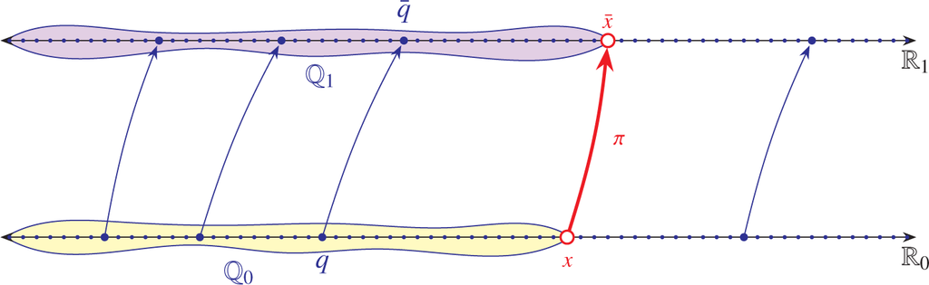

接下来，根据阿基里德性质，每个数*x*∈R<sub>0</sub>都确定了Q<sub>0</sub>中的一个割，黄色表示，且由于R<sub>1</sub>是完备的，存在一个对应的*x*∈R <sub>1</sub>填充Q <sub>1</sub>中对应的割，用紫色表示。因此，我们定义了一个映射 *π*：*x* ↦ *x* 从 R<sub>0</sub> 到 R<sub>1</sub>。该映射是满射的，因为每个 *y* ∈ R<sub>1</sub> 都确定了 Q<sub>1</sub> 中的一个割，且由于 R<sub>0</sub> 的完备性，存在一个 *x* ∈ R<sub>0</sub> 填满对应的割。最后，映射*π*是域同构，因为它是Q<sub>0</sub>与Q<sub>1</sub>同构的连续扩张到R<sub>0</sub>。

Next, by the Archimedean property, every number *x* ∈ ℝ<sub>0</sub> determines a cut in ℚ<sub>0</sub>, indicated in yellow, and since ℝ<sub>1</sub> is complete, there is a counterpart *x* ∈ ℝ<sub>1</sub> filling the corresponding cut in ℚ<sub>1</sub>, indicated in violet. Thus, we have defined a map *π*: *x* ↦ *x* from ℝ<sub>0</sub> to ℝ<sub>1</sub>. This map is surjective, since every *y* ∈ ℝ<sub>1</sub> determines a cut in ℚ<sub>1</sub>, and by the completeness of ℝ<sub>0</sub>, there is an *x* ∈ ℝ<sub>0</sub> filling the corresponding cut. Finally, the map *π* is a field isomorphism since it is the continuous extension to ℝ<sub>0</sub> of the isomorphism of ℚ<sub>0</sub> with ℚ<sub>1</sub>.

□

□

这一结果以描述实数结构的方式，就像德德金的算术公理描述自然数的结构一样。我们找到了实连续统的基本原理，并证明它们决定了该结构直到同构。因此，我们已将实数 R 识别为一种数学结构。

This result characterizes the structure of the real numbers in the same way that Dedekind’s arithmetic axioms characterize the structure of the natural numbers. We found the fundamental principles for the real continuum and proved that they determine that structure up to isomorphism. Thus, we have identified the real numbers ℝ as a mathematical structure.

根据结构主义，无需挑选出某个特定的完全有序域，即官方副本，因为实数唯一数学上相关的性质——数学论证中唯一应当使用的性质——是它们构成一个完备有序域。单个实数通过它们在此类结构中的角色来理解。如前所述， 是你所选完备有序域中唯一的对象，恰好是正的，且与该域中的数字2平方，其中2是该域中的数字1 + 1，其中1是该域中唯一的乘法恒等式。这就是由 起到的结构性作用。在任何完备有序域中，每个有理数都是代数可定义的，每个实数都由它在有理数中所做的割来刻画。由此，实域 R 是一个莱布尼茨结构：任意两个实数都可以在域的语言中区分。

According to structuralism, it is not necessary to pick out a particular complete ordered field, an official copy, since the only mathematically relevant property of the real numbers—the only property that should be used in a mathematical argument—is that they constitute a complete ordered field. Individual real numbers are comprehended by their roles within such a structure. As we noted earlier, is the unique object in whichever complete ordered field you have selected, that happens to be positive and to square to the number 2 in that field, where 2 is the number 1 + 1 in that field, where 1 is the unique multiplicative identity in that field. This is the structural role played by . In any complete ordered field, every rational number is algebraically definable, and every real number is characterized by the cut that it makes in the rational numbers. It follows that the real field ℝ is a Leibnizian structure: any two real numbers are discernible in the language of fields.

Kevin Buzzard（2019）通过探究结构主义问题强调：我们如何知道用Dedekind割实数证明的定理也适用于柯西完备实数？为什么涉及实数的数学断言，即使只是偶然的，当对Dedekind实数成立时，也必须在使用柯西实数时成立？要得出如此笼统的结论，似乎需要证明数学材料是同构不变的，这项工作真的有人做过吗？

Kevin Buzzard (2019) highlights the question of structuralism by inquiring: How do we know that a theorem proved using the Dedekind-cut real numbers is also true of Cauchy-completion real numbers? Why is it that a mathematical assertion involving the real numbers, even if only incidentally, when true for the Dedekind real numbers, must also be true when one uses the Cauchy real numbers? There would seem to be an enormous pile of mathematical material that would have to be proved isomorphism-invariant in order to make such sweeping general conclusions, and has this work actually been done?

作为一个群体，当前实践中的数学家高度结构主义，且往往坚持这一点。如果要证明涉及实数的定理，除非你特别关注这些实数表述所涉及的额外结构特征，否则坚持使用德德金实数而非柯西实数，这会被认为是非常奇怪的。由于这种广泛的实践，绝大多数数学发展确实是结构主义的，并且在核心数学结构（包括自然数、整数、实数等）上遵循结构主义命令。因此，秃鹰声称必须处理的庞大同构不变材料实际上已经被处理过——这是正常数学的标准做法——这也是为什么我们可以推断，涉及实数的数学陈述并不依赖于我们使用的具体实数副本。

As a community, mathematicians in current practice are highly structuralist, often insistently so. It would be considered very strange to prove a theorem involving the real numbers by insisting that one is using the Dedekind real numbers as opposed to the Cauchy real numbers, for example, unless one were specifically concerned with the additional structural features that those formulations of the real numbers involved. Because of this widespread practice, the vast bulk of mathematical development is indeed structuralist and follows the structuralist imperative with regard to the central mathematical structures, including the natural numbers, the integers, the real numbers, and so on. Therefore, the enormous pile of isomorphism-invariant material that Buzzard claims must be undertaken has in fact already been undertaken—this is the standard practice of normal mathematics—and this is why we may deduce that mathematical statements involving the real numbers do not depend on which particular copy of the real numbers we are using.

### **实连续体的范畴性** **Categoricity for the real continuum**

我们通过上述实数构成完备有序域且所有此类域同构来描述。因此，该范畴性论证利用实数的代数性质——即它们构成有序域的事实——作为刻画的本质部分。然而，事实证明，我们也可以纯粹根据实数线的序性质来刻画实数线，而非作为有序域的代数性质。

We characterized the real numbers above by the fact that they form a complete ordered field and all such fields are isomorphic. This categoricity argument, therefore, uses the algebraic properties of the real numbers—the fact that they form an ordered field—as an essential part of the characterization. It turns out, however, that we may also characterize the real number line purely by its order properties rather than its algebraic properties as an ordered field.

具体来说，我们考虑仅有序结构的实数线⟨R， <⟩。作为序拓扑下的拓扑空间，这被称为*实连续体*。我们能说些什么呢？当然，这是一个线性序，因为任意两个实数都是可比较的;它是无穷的，意味着既没有最大实数，也没有最小实数;且它是稠密有序的，意味着在任意两个实数之间，存在另一个;它是Dedekind完备的，意味着实数线上的每个割都被填满。因此，实数直线是一个无穷、完备、稠密的线性序。然而，这还不足以刻画实数线，因为对于熟悉实数线的人来说，还有其他非同构于实数线的序，比如无穷长线。

Specifically, let us consider the real number line ⟨ℝ, <⟩ with only the order structure. Viewed as a topological space under the order topology, this is known as the *real continuum*. What can we say about it? Well, this is a linear order, of course, since any two real numbers are comparable; and it is endless, meaning that there is neither a largest nor a smallest real number; and it is densely ordered, meaning that between any two real numbers, there is another; and it is Dedekind complete, meaning that every cut in the real number line is filled. Thus, the real number line is an endless, complete, dense linear order. This is not yet enough to characterize the real number line, however, for there are other such orders, not isomorphic to the real number line, such as the endless long line, for those who are familiar with it.

不过，还有一个额外的属性，可以让角色的描述得以通过。只需补充实数直线存在一个可数稠密子集即可。也就是说，存在一个子集 Q ⊆ R，即有理数集，它在实数线上是（1）稠密的，意思是每个非平凡的实数区间 （*a， b*） 都包含该子集的元素;以及（2）子集Q是可数的，如第3章所述。所有这些性质共同决定了实数阶直到同构。

One additional property, however, will enable a characterization to go through. It suffices to add that the real number line has a countable dense subset. That is, there is a subset ℚ ⊆ ℝ, the set of rational numbers, which is (1) dense in the real number line in the sense that every nontrivial interval (*a, b*) of real numbers contains elements of the subset; and (2) the subset ℚ is countable, as discussed in chapter 3. All these properties together now determine the real numbers order up to isomorphism.

**定理5。** *任意两个完备且无穷稠密线性序且密度可数的，都是序同构的。*

**Theorem 5.** *Any two complete endless dense linear orders with countable dense sets are order isomorphic.*

证明的核心是康托尔的来回方法，该方法表明两个可数稠密子序同构，康托尔证明了任意两个可数、无穷、稠密线性序同构。然后可以利用序的完备性将该同构从子序提升到整个序，就像我们在完全有序域中所做的那样。

The essence of the proof is Cantor’s back-and-forth method, which shows that the two countable dense suborders are isomorphic, for indeed, Cantor shows that any two countable, endless, dense linear orders are isomorphic. One can then lift this isomorphism from the suborders to the whole order using the completeness of the orders, just as we did in the case of the complete ordered fields.

我提到这种范式结果，部分原因是当考虑其一个小变体时，会出现一个引人入胜的基础问题，这削弱了可数稠密集的要求，即所谓的*可数链条件*，即每一族不重叠区间都是可数的。实数线具有可数链条件，因为如果实数线中有一族不重叠的区间，那么在每个区间内我们可以选择一个有理数，且由于它们不重叠，我们永远不会选择相同的有理数两次;所以这个家族一定是可数的。

I mention this categoricity result in part because a fascinating foundational issue arises when one considers a small variation of it, weakening the countable-dense-set requirement to what is called the *countable chain condition*, which asserts that every family of nonoverlapping intervals is countable. The real number line has the countable chain condition, since if we have a family of nonoverlapping intervals in the real number line, then inside each one we may pick a rational number, and we will never pick the same rational number twice since they do not overlap; so the family must have been countable.

**问题6。**所有具有可数链条件的完备无穷密集线性序是否同构？

**Question 6.** Are all complete endless dense linear orders with the countable chain condition isomorphic?

换句话说，这些性质是否刻画了实数线？答案既微妙又引人入胜。一个积极的答案被称为*苏斯林假设*，而反例序，即一个具有可数链条件但不同构于实数线的完整无限密集线性序，称为*苏斯林线*。极其有趣的情况是，这个问题无法用集合论的标准公理来解决;苏斯林假设是一个*独立*的陈述，既不可证也不可被集合论公理推翻;无论哪种情况，它都是一致的。特别是，实数是否被苏斯林假设的性质定义为范式特征的问题本身是独立的，既不可证也不可反驳，这与集合论公理无关。我们将在第八章详细讨论独立现象。

In other words, do these properties characterize the real number line? The answer is subtle and fascinating. A positive answer is known as *Suslin’s hypothesis*, while a counterexample order, a complete endless dense linear order with the countable chain condition, but which is not isomorphic to the real number line, is called a *Suslin line*. The extremely interesting situation is that this question cannot be settled using the standard axioms of set theory; Suslin’s hypothesis is an *independent* statement, neither provable nor refutable from the axioms of set theory; it is consistent either way. In particular, the question of whether the real numbers are categorically characterized by the property of Suslin’s hypothesis is itself independent, neither provable nor refutable from the axioms of set theory. We shall discuss the independence phenomenon at length in chapter 8.

## **1.12 先验数** **1.12 Transcendental numbers**

*实代*数是指用来求解整数上非平凡多项式方程的实数，例如 *x*<sup>2</sup> = 2，由 解出，或方程 *x*<sup>2</sup> − *x* − 1 = 0，由黄金比例数 解出，及其共轭 。可以用根式表达式构造代数数，但一个深刻的定理表明，并非所有代数数都能用根式以这种方式描述。如果实数不是代数的，则称该实数是*超越的*。约瑟夫·刘维尔证明先验数存在，可以看作毕达哥拉斯证明无理数存在的更高阶类比，是两千年后重新拾起的推理线索的延续。

The *real algebraic* numbers are the real numbers that solve a nontrivial polynomial equation over the integers, such as *x*<sup>2</sup> = 2, which is solved by , or the equation *x*<sup>2</sup> − *x* − 1 = 0, which is solved by the golden ratio number, , and its conjugate, . One can form algebraic numbers with radical expressions such as , but it is a deep theorem that not all algebraic numbers can be described in such a manner by radicals. A real number is *transcendental* if is not algebraic. The proof that transcendental numbers exist, due to Joseph Liouville, can be seen as an higher analogue of the Pythagorean proof that irrational numbers exist, a continuation of a thread of reasoning picked up again after two thousand years.

Liouville定义了一类*空*数，其展开时零点湖越来越大。他考虑了以下具体数字：

Liouville defined a class of *lacunic* numbers, whose expansions had increasingly large lakes of zeros. He considered, for example, the following specific number:

[figure not shown]

现在称为*Liouville常数*，其小数位中数字1由阶乘1、2、6、24等给出。对于任意空缺数，如果湖泊足够大，则湖泊间孤立的1最终不会在有理多项式表达式中相互干涉。特别地，这些数字部分不能在代数组合中相互抵消。正因如此，这些数无法解有理数上的非平凡代数方程，因此它们是超越的。Liouville常数中的零点湖有一个非常有趣的结论，数论学家对此进行了研究——即该数具有有理近似且准确性惊人：0.11在小数点后5位正确，0.110001在23位位正确。在每个湖泊较近岸边的有理近似精度可以延伸到对岸。

now known as the *Liouville constant*, which has the digit 1 in decimal places given by the factorials 1, 2, 6, 24, and so on. For any lacunic number, if the lakes grow sufficiently in size, then the isolated 1s between the lakes eventually do not interfere with one another in rational polynomial expressions. In particular, these parts of the number cannot conspire to cancel each other out in algebraic combinations. Precisely for this reason, such numbers cannot solve a nontrivial algebraic equation over the rational numbers, and therefore they are transcendental. The lakes of zeros in the Liouville constant have a very interesting consequence, investigated by the number theorists—namely, that this number has rational approximations with surprising accuracy: 0.11 is correct to 5 decimal places, and 0.110001 is correct to 23 places. The rational approximation up to the closer shore of each lake extends in accuracy across it to the opposite shore.

我们现在知道*，e*、*π*以及许多其他著名的实数都是先验的，康托尔在第三章讨论的论证在精确意义上表明大多数实数都是先验的。

We now know that *e* and *π* and many other famous real numbers are transcendental, and Cantor’s arguments, discussed in chapter 3, show in a precise sense that most real numbers are transcendental.

### **超越游戏** **The transcendence game**

考虑以下数学博弈。你从一个数字x*开始，可以*是实数或复数，你可以从当前数字中生成下一个数字，方法包括加1、减1、乘以非零整数，或乘以*x*。如果你能通过这个过程得到零，你就赢了。例如，如果我们从开始，可以先减去1四次，形成 ，然后乘以 *x*，

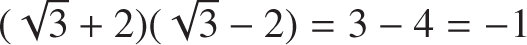

再加1 得到 0。我们赢了！

Consider the following mathematical game. You start with a number *x*, either real or complex, and you are allowed to form a next number from the current number either by adding 1, subtracting 1, multiplying by a nonzero integer, or multiplying by *x*. You win if you can produce the number zero by this process. For example, if we start with , then we could subtract 1 four times to form , and then multiply by *x* to form

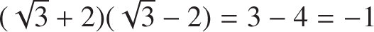

, and then add 1 to form 0. We won!

令人惊讶的是，你能赢得这个游戏的数字*x*恰好是代数数字。如果某人用数字*x*赢得游戏，那么通过展开获胜的走法序列并将其表达为方程，可以得到一个整数多项式，其中*x*是根，从而证明*x*是代数多项式。在这里给出的例子中，我们实际上计算出了 （*x* − 4）*x* + 1 = 0。反过来，如果*x*是代数的，则它是整数多项式方程的解，例如2*x*<sup>4</sup> + 5*x*<sup>3</sup> − 7*x*<sup>2</sup> + 3*x* + 1 = 0。在这种情况下，我们可以简单地将*x*从连续的项对中分解出来，如下：

The amazing fact is that the numbers *x* for which you can win in this game are exactly the algebraic numbers. If a person ever wins the game with a number *x*, then by unwrapping the winning sequence of moves and expressing them as an equation, one finds an integer polynomial of which *x* is a root, thereby showing that *x* is algebraic. In the example given here, we in effect computed (*x* − 4)*x* + 1 = 0. Conversely, if *x* is algebraic, then it is the solution of a polynomial equation over the integers, such as 2*x*<sup>4</sup> + 5*x*<sup>3</sup> − 7*x*<sup>2</sup> + 3*x* + 1 = 0. In this case, we may simply factor *x* out of successive pairs of terms like this:

[figure not shown]

从得到的表达式中，从内层*2 x* + 5 的 *x* 开始，我们可以依次推导出如何从 *x* 生成 0，过程如下：将 *x* 乘以 2，加 5（即加 1 五次），乘以 *x*，减去 7，再乘以 *x*，再加 3，再乘以 *x*，再加 1。这形成了原始多项式，即0，因此我们赢得了游戏。该分解过程表明，任何代数数都可以赢得超越，因此中奖号码正是代数数。

From the resulting expression, starting at the *x* of the inner 2*x* + 5, we can successively read off how to form 0 from *x* by the following process: we multiply *x* by 2, add 5 (which means add 1 five times), multiply by *x*, subtract 7, multiply by *x*, add 3, multiply by *x*, and add 1. This forms the original polynomial, which is 0, and so we have won the game. This factoring process will show that one can win the transcendence with any algebraic number, and so the winning numbers are exactly the algebraic numbers.

特别是，用*e*或*π*无法赢得游戏，因为这些数字是超越的。同时，证明一个数字有理数当且仅当你能在不使用乘以*x*规则的情况下赢得游戏，是个有趣的练习。

In particular, one will not be able to win the game with *e* or *π*, as these numbers are transcendental. Meanwhile, it is a fun exercise to prove that a number is rational if and only if you can win the game without using the multiply-by-*x* rule.

## **1.13 复数** **1.13 Complex numbers**

给定实数后，人们会进入复数C，这既是诱人又可能令人恐惧的虚数单位作为真实数存在的可能性。我们想考虑形如*a* + *bi*的复数，其中*a*和*b*是实数。什么是复数？

Given the real numbers, one proceeds to the complex numbers ℂ, motivated by the enticing, yet perhaps terrifying, possibility that the imaginary unit exists as an actual number. One wants to consider complex numbers of the form *a* + *bi*, where *a* and *b* are real. What is a complex number?

我们可以通过复平面轻松构造复场的自然表示。具体来说，由于复数对于实数*a*和*b*的形式为*a* + *bi*，我们就把数*a* + *bi*想象为平面上的一对（*a， b*）表示。我们可以定义通常的坐标加法运算 （*a， b*） + （*c， d*） = （*a* + *c， b* + *d*），但我们使用一种奇异的乘法运算，定义为 （*a， b*） ·（*c， d*） = （*ac*−*bd， ad* + *bc*）。该定义恰好实现了 *i*<sup>2</sup> = −1 在乘积中的分配后果

We can easily construct a natural presentation of the complex field by means of the complex plane. Specifically, since complex numbers are to have the form *a* + *bi* for real numbers *a* and *b*, let us think of the number *a* + *bi* as represented by the pair (*a, b*), a point in the plane. We may define the usual coordinate-wise addition operation (*a, b*) + (*c, d*) = (*a* + *c, b* + *d*), but we use a certain strange multiplication operation, defined by (*a, b*) · (*c, d*) = (*ac*−*bd, ad* + *bc*). This definition exactly implements the distributive consequences of *i*<sup>2</sup> = −1 in the product

[figure not shown]

通过将 *a* + *bi* 与点 （*a， b*） 等同，我们实现了复数作为平面上的点，即现在称为*复平面*，我们将复算术理解为定义在这些点上的某些初等运算。所以复数中其实并没有什么可怕的谜团。我们可以从实数构造它们。

By identifying *a* + *bi* with the point (*a, b*), we have realized the complex numbers as points in the plane, now called the *complex plane*, and we understand the complex arithmetic simply as certain elementary operations defined on those points. So there is no terrifying mystery after all in the complex numbers. We can construct them from the real numbers.

### **复数的柏拉图主义** **Platonism for complex numbers**

我们通过将实数扩展为方程*z*<sup>2</sup> + 1 = 0，使用*解z* = *i*来形成复数。一个显著的事实，被称为*代数基本定理*，通过添加这个解，复数因此变得代数闭合：复数上的每个非平凡多项式方程都有一个完整的解。复数是实数的代数闭包。

We formed the complex numbers by extending the real numbers with a solution of the equation *z*<sup>2</sup> + 1 = 0, using the solution *z* = *i*. It is a remarkable fact, known as the *fundamental theorem of algebra*, that by adding this one solution, the complex numbers thereby become algebraically closed: every nontrivial polynomial equation over the complex numbers has a full solution there. The complex numbers are the algebraic closure of the real numbers.

### **复域的范畴性** **Categoricity for the complex field**

像实数一样，复域C也具有范畴特征。即，复域在同构下被唯一地刻画为完备有序子域实数的代数闭包。任意两个类似的域同构，因为它们的实子域同构，且该同构可扩展到代数闭包。复域也被同构地描述为唯一特征为0且大小连续的代数闭域。可以通过断言存在一个与实连续体子集的双射来表达二阶逻辑中具有大小连续统的概念。

Like the real numbers, the complex field ℂ admits a categorical characterization. Namely, the complex field is uniquely characterized up to isomorphism as being the algebraic closure of a complete ordered subfield, the real numbers. Any two fields like that are isomorphic, since their real subfields will be isomorphic and this isomorphism will extend to the algebraic closure. The complex field is also characterized up to isomorphism as the unique algebraically closed field of characteristic 0 having size continuum. One can express the concept of having size continuum in second-order logic by asserting that there is a bijection with a subset that is a real continuum.

因此，我们熟悉的每一个数系统——自然数N、整数环Z、有理域Q、实域R和复域C——都允许范畴特征。正因为这些范畴论述，我们能够仅仅描述其中的真实性，而不必展示结构的样本实例，从而识别并引用它们。我们不需要给出特定的构造C副本来指代复域，因为我们可以说我们指的是特征为0且大小连续的代数闭域。在我看来，这种无需展示具体实例即可指代结构的能力，是数学范畴性结果与结构主义哲学之间深刻联系的核心部分。

Thus, each of our familiar number systems—the natural numbers ℕ, the integer ring ℤ, the rational field ℚ, the real field ℝ and the complex field ℂ—admit categorical characterizations. Precisely because of these categorical accounts, we are able to pick out and refer to these structures simply by describing what is true in them, rather than by having to exhibit sample instances of the structures. We don’t need to present a particular constructed copy of ℂ to refer to the complex field, because we can just say that we are referring to the algebraically closed field of characteristic 0 having size continuum. To my way of thinking, this ability to refer to structures without needing to exhibit particular instances is a core part of the deep connection between categoricity results in mathematics and the philosophy of structuralism.

### **结构主义面临的复杂挑战？** **A complex challenge for structuralism?**

虽然人们通常将*i*描述为“负1的平方根”，但鉴于−*i*也是这样的根，人们仍可回答：“哪个根？”：

Although one conventionally describes *i* as “the square root of negative one,” nevertheless one might reply to this, “Which one?” in light of the fact that −*i* also is such a root:

[figure not shown]

事实上，复数存在自同构，即自身与自身的同构，通过交换 *i* 与 − *i* 来诱导——即复共轭：

Indeed, the complex numbers admit an automorphism, an isomorphism of themselves with themselves, induced by swapping *i* with − *i*—namely, complex conjugation:

[figure not shown]

如果想将数学对象理解为结构中的抽象位置，如抽象结构主义，那么必须面对这样一个事实：结合自同构，数字*i*和−*i*在该结构中扮演完全相同的角色（参见Shapiro，2012）。数*i*和− *i*相对于复域具有相同的同构轨道，因此从这个意义上说，虽然它们不同，但在C中它们起着完全相同的结构作用。这似乎削弱了数学对象*是*结构中抽象位置的观点，因为我们希望将它们视为不同的复数。

If one wants to understand mathematical objects as abstract positions within a structure, as in abstract structuralism, then one must grapple with the fact that in light of the conjugation automorphism, the numbers *i* and −*i* play exactly the same roles in this structure (see Shapiro, 2012). The numbers *i* and − *i* have the same isomorphism orbit with respect to the complex field, and so in this sense, although distinct, they each play exactly the same structural role in ℂ. This would seem to undermine the idea that mathematical objects *are* abstract positions in a structure, since we want to regard these as distinct complex numbers.

同时，通过在复数基础上添加额外的自然结构，就能恢复结构角色的独特性。具体来说，当我们将复域 C 补充实部和虚部的标准算子时：

Meanwhile, one recovers the uniqueness of the structural roles simply by augmenting the complex numbers with additional natural structure. Specifically, once we augment the complex field ℂ with the standard operators for the real and imaginary parts:

[figure not shown]

那么展开结构 ⟨C，+，·，Re，Im ⟩ 变*为刚性*结构，意味着它没有非平凡自同构。因此，每个复数在这个新结构中都扮演着独特的结构角色，即莱布尼茨结构。这种额外的结构隐含在复数的复平面概念中，这也是为什么数字*i*作为奇异项看起来没问题——它指复平面中的点（0， 1）——而 −*i* 指的是 （0， − 1）。复平面不仅仅是一个场，因为它通过实部和虚部算符传递坐标信息，使其具有刚性。在复平面中，每个复数扮演着不同的角色。

then the expanded structure ⟨ℂ,+,·,Re, Im ⟩ becomes *rigid*, meaning that it has no nontrivial automorphisms. Thus, every complex number plays a unique structural role in this new structure, which is Leibnizian. This additional structure is implicit in the complex plane conception of the complex numbers, which is part of why the number *i* appears fine as a singular term—it refers to the point (0, 1) in the complex plane—whereas −*i* refers to (0, − 1). The complex plane is not merely a field, for it carries along its coordinate information by means of the real-part and imaginary-part operators, making it rigid. In the complex plane, every complex number plays a different role.

### **结构作为刚性结构的约简** **Structure as reduct of rigid structure**

这种自然非刚性结构被自然附加结构变为刚性的情况在数学中极为常见。例子很多。整数加法群 ⟨Z，+ ⟩ 通过否定存在自同构，但与乘法结构 ⟨Z，+， ·⟩或序结构⟨Z，+，<⟩。有理序⟨Q，<⟩是一个可数的无限密集线性序，因此高度非刚性——每个点看起来相同，事实上，任意两个大小相同的有限集合都是有序自守的——但随着域结构⟨Q，+， ·， <⟩，变得刚性。复域 ⟨C，+，·⟩有2<sup>2<sup>א<sub>0</sub></sup></sup>个自同构，但通过包含坐标结构使得刚性。每个至少包含三个元素的群 *G* 都是非刚性的，但当群被赋予特定的表示方式时，元素会被区分，比如通过生成元和关系，或作为特定集合的排列。

This situation, where a natural nonrigid structure is made rigid by natural additional structure, is extremely common in mathematics. Examples abound. The additive group of integers ⟨ℤ,+ ⟩ admits an automorphism by negation, but is made rigid with the multiplicative structure ⟨ℤ,+, ·⟩ or the order structure ⟨ℤ,+, < ⟩. The rational order ⟨ℚ, < ⟩ is a countable endless dense linear order and therefore highly nonrigid—every point looks the same, and indeed any two finite sets of the same size are order-automorphic—but becomes rigid with the field structure ⟨ℚ,+, ·, <⟩. The complex field ⟨ℂ,+,·⟩ has 2<sup>2<sup>ℵ<sub>0</sub></sup></sup> many automorphisms, but is made rigid by incorporating the coordinate structure. Every group *G* with at least three elements is nonrigid, but elements are distinguished when the group is given a particular presentation, such as by means of generators and relations or as permutations of a particular set.

这种模式是，某个特定的非刚性结构被实现为另一个刚性结构的约简子结构，从而解决了指称问题，因为我们可以通过参照非刚性结构中的对象在扩展结构中的角色来称呼它们。我认为这种模式是数学实践中固有的。原因正是因为指称问题，我们实际上很难真正呈现或指定非刚性结构，除非将其呈现为一个对象被个体化的结构的约简子结构。否则我们怎么能有条理地首先指定这些物体的结构呢？我们不会从一个裸本C开始，然后试图对它强加一个方向，使我们能够从− *i**中解析*i。相反，我们采取相反的路径：数学结构的实例来自更丰富的语境，对象已经被个体化。例如，我们可以从有序实数对构建一个C的副本，其中我们可以从（0， −1）中区分出（0， 1），因此在该C的副本中，可以区分出*i*与− *i*。每一个特定的C副本，实际上任何类型的数学结构，都是从对象被个体化的语境中产生。

The pattern is that a particular nonrigid structure is realized as a reduct substructure of another structure that is rigid, thereby resolving the problem of reference, since we may refer to the objects of the nonrigid structure by reference to their roles in the expanded structure. I claim that this pattern is inherent in mathematical practice. The reason is that precisely because of the reference problem, it is difficult for us ever actually to present or specify a nonrigid structure, except by presenting it as a reduct substructure of a structure in which the objects are individuated. How else are we coherently to specify the structure on those objects in the first place? We don’t start with a naked copy of ℂ and then seek to impose an orientation on it that will enable us to resolve *i* from − *i*. Rather, we proceed oppositely: instances of mathematical structures are obtained from richer contexts where the objects were already individuated. We might build a copy of ℂ from ordered pairs of real numbers, for example, where we can discern (0, 1) from (0, − 1) and therefore *i* from − *i* in this particular copy of ℂ. Every particular copy of ℂ and indeed every particular mathematical structure of any kind arises similarly from a context in which the objects are individuated.

当以ZFC集合论作为数学基础时，这一哲学观察就成为一个数学定理：每个集合都是刚性结构的约简子结构，在刚性结构中每个个体扮演着不同的结构角色。原因在于每个集合都是传递集的子集，且每个传递集相对于∈成员关系都是刚性的。事实上，集合论宇宙⟨*V*，∈⟩整体是刚性——因此，集合论宇宙中的任意两个对象都可以作为集合区分，并承担不同的集合论角色（参见第286页的论证）。因此，所有在集合论中可实现的数学结构都可以作为刚性结构的约简子结构实现。我们可以根据原始结构中各自在更大背景中所扮演的不同结构角色来称呼他们。

When using ZFC set theory as a foundation of mathematics, this philosophical observation becomes a mathematical theorem: every set is a reduct substructure of a rigid structure, a structure in which every individual plays a distinct structural role. The reason is that every set is a subset of a transitive set, and every transitive set is rigid with respect to the ∈ membership relation. Indeed, the set-theoretic universe ⟨*V*, ∈ ⟩ as a whole is rigid—any two objects in the set-theoretic universe are therefore distinguishable as sets and play different set-theoretic roles (see the argument on page 286). Therefore, every mathematical structure that can be realized in set theory at all can be realized as a reduct substructure of a rigid structure. We can refer to distinct individuals in the original structure by the distinct structural roles they play in the larger context.

## **1.14 当代类型理论** **1.14 Contemporary type theory**

数学中充满了各种类型的数学对象：我们有自然数、整数、实数、数集、平面上的直线、实数上的函数、拓扑空间、数列和级数，以及不断不断的。所有这些不同类型的数学对象都有不同的性质和特征，每种类型都遵循特定的规则。只对实数本身是实数的输入对象应用函数是合理的。类型理论关注于跟踪所有这些不同类型及其相互作用规则，同时也关注我们形成新类型的形式方法。归根结底，类型理论认识到数学的强类型性质，并认真对待“类型”的概念。最一般的类型理论形式能够在类型内表示本质上任意的数学结构，它们可以作为基础理论使用，类似于集合论。人们在庞大的超限层级中从旧类型形成新类型，就像集合论的累积层级一样。

Mathematics overflows with mathematical objects of many types: we have natural numbers, integers, real numbers, sets of numbers, lines in the plane, functions on the real numbers, topological spaces, sequences and series, and on and on and on. All these different types of mathematical objects have different natures and features, and each type follows certain rules. It makes sense to apply a function on the real numbers only to input objects that are themselves real numbers. Type theory is concerned with keeping track of all these different types and their interaction rules, and also with the formal methods by which we might form new types. At bottom, type theory recognizes the strongly typed nature of mathematics and takes the idea of a “type” seriously. The most general forms of type theory have the capability to represent essentially arbitrary mathematical structure within the types, and they can be used as a foundational theory, much like set theory. One forms new types from old types in a vast, transfinite hierarchy, just as in the cumulative hierarchy of set theory.

类似的类型变换问题在编程语言中也常被完全明确地表达出来，例如，有时需要将数字的类型从整数变为float，以应用浮点运算中可用的运算，而整数运算中却没有。某些编程语言的强类型特性允许通过检查函数式和关系表达式是否符合其类型来测试程序中的类型错误。

Similar type-changing issues are often made completely explicit in programming languages, where one sometimes must change the type of a number from int to float, for example, to apply operations that are available in floating-point arithmetic, but not in integer arithmetic. The strongly typed nature of some programming languages allows one to test for typing errors in a program, simply by checking that functional and relational expressions are used in accordance with their types.

与此同时，初级数学用法对打字通常较为宽松。每个自然数通常也被视为整数;每个整数也是有理数;每个有理数也是实数，每个实数也是复数：

Meanwhile, elementary mathematical usage is often relaxed about typing. Every natural number is commonly also taken as an integer; every integer is also rational; every rational number is also real, and every real number is also a complex number:

[figure not shown]

从这个角度看，我们可以把数字57看作自然数、实数，甚至复数，而且总是同一个数字。

From this view, we may think of the number 57 either as a natural number or as a real number, or even as a complex number, and it is always the same number.

然而，数学的类型论解释鼓励我们更加谨慎地区分这些类型区分。根据类型论者，自然数57并不等同于整数57或实数57，尽管我们有这些数系统之间的典范嵌入或平译。我们可以通过应用型别变化的平移*τ*<sub>Z， R</sub>，将整数平译为实数。例如，如果57是整数，则*τ*<sub>Z，Q</sub>（57）是对应的有理数57，τ <sub>Z，R</sub>（57）是实数57。

The type-theoretic account of mathematics, however, encourages us to take more care with these type distinctions. According to the type theorists, the natural number 57 is not the same thing as the integer 57 or the real number 57, although we have canonical embeddings or translations from each of these number systems to the next. We can translate an integer to the real numbers by applying the type-changing translation *τ*<sub>ℤ, ℝ</sub>. For example, if 57 is an integer, then *τ*<sub>ℤ, ℚ</sub>(57) would be the corresponding rational number 57, and *τ*<sub>ℤ, ℝ</sub>(57) would be the real number 57.

我们是否应该将传统的算术计算视为充满了无形的类型调整态射？根据类型论，如果我们尊重数学类型，会发现更稳健的数学理论和洞见。而普通数学用法通常忽略这些类型，认为自然数57与整数57相同。问题在于，做出强有力的区分是否会带来数学或哲学上的优势。

Should we regard our conventional arithmetic calculations as ridden with invisible type-adjusting morphisms? According to type theory, we will find more robust mathematical theories and insight if we respect mathematical typing. Meanwhile, ordinary mathematical usage commonly ignores these types and takes the natural number 57 to be identical to the integer 57. The question is whether there would be a mathematical or philosophical advantage in making a robust distinction.

## **1.15 更多数字** **1.15 More numbers**

复数由*四元数*扩展，四元数是一个具有非交换乘法的系统，其中数的形式为 *a* + *bi* + *cj* + *dk*，其中 *i*、*j* 和 *k* 是四元数单位。四元数又被八元数扩展，八*元数*具有非结合乘法和八维空间;它们因与暗物质和理论物理的一些联系而被科普媒体提及。无*穷小*数将在第二章讨论，以及相关的*超实*数，而超限*序*数将在第三章中介绍。与此同时，约翰·康威提出的迷人*超现实*数，将实数、超实数和序数的特征结合成一个优雅的系统，这是一个庞大的普数系统，统一了所有大小数。

The complex numbers are extended by the *quaternions*, a system with a noncommutative multiplication, where numbers have the form *a* + *bi* + *cj* + *dk*, where *i*, *j*, and *k* are the quaternion units. The quaternions are in turn extended by the *octonians*, which have a nonassociative multiplication and eight dimensions; they are mentioned in the popular science press for some connections with dark matter and theoretical physics. *Infinitesimal* numbers will be discussed in chapter 2, along with the associated *hyperreal* numbers, and the transfinite *ordinal* numbers will be covered in chapter 3. Meanwhile, the fascinating *surreal* numbers, introduced by John Conway, combine features of the real numbers, the hyperreal numbers, and the ordinals in one elegant system, a vast universal number system that unifies all numbers, great and small.

## **1.16 哲学的意义是什么？** **1.16 What is a philosophy for?**

数学哲学的目的是什么？这些哲学争论中究竟涉及什么？有些哲学家可能会回答说，我们正在努力探究数学的本质，理解数学的本质以及它为何如此运作。我们希望阐明数学对象和数学命题的本质，以及我们如何认识它们。我们有许多关于数学本质的根本哲学问题，我们试图回答这些问题，或者至少澄清哲学问题，铺设可能答案的边界。相反，其他哲学家反对认为哲学辩论往往在数学上利益不大，但人们仍可能试图利用哲学洞见来实现数学目的。不同的数学哲学可能引导人们走向更有意义的数学问题或更有成效的数学研究方向。因此，成功的数学哲学可能是具有更大数学回报的哲学——带来更有价值的数学见解。

What is the purpose of a philosophy of mathematics? What is at stake in these philosophical disputes? Some philosophers might answer by saying that we are striving to get at the essential nature of mathematics, to understand what mathematics is about and why it works as it does. We hope to give an account of the nature of mathematical objects and mathematical claims, and how we come to know them. We have so many fundamental philosophical questions about the nature of mathematics, and we seek to answer them, or at least clarify the philosophical issues and lay out the terrain of possible answers. Other philosophers, in contrast, object that there often seems to be little mathematically at stake in the philosophical debates, and yet one might seek to harness philosophical insight for mathematical ends. Different philosophies of mathematics might guide one toward more meaningful mathematical questions or more fruitful avenues of mathematical investigation. A successful philosophy of mathematics, therefore, might be one with a greater mathematical payoff—one that leads to more valuable mathematical insights.

举一个例子，考虑当前在集合论哲学中激烈讨论的集合论多元论争议（见第8章讨论）。争议点在于集合论存在的本质，特别是是否存在一个集合论宇宙、理论所涉及的预期模型，还是存在多个平行的集合论概念，从而产生集合论的复数多重宇宙。

To describe one instance, consider the dispute over set-theoretic pluralism, currently raging in the philosophy of set theory (discussed in chapter 8). At issue is the nature of set-theoretic existence, and in particular the question of whether there is just one set-theoretic universe, an intended model that the theory is about, or whether there are multiple parallel conceptions of set theory giving rise to a plural multiverse of set theory.

在我最初参与这场辩论的附录中，我写道：

In the appendix of my initial contribution to this debate, I wrote:

数学家衡量哲学立场的标准可能是其所指向的数学价值。因此，这里的哲学辩论可能代表：集合论应该走向何方？它应该考虑哪些数学问题？哈姆金斯（2012）

The mathematician’s measure of a philosophical position may be the value of the mathematics to which it leads. Thus, the philosophical debate here may be a proxy for: where should set theory go? Which mathematical questions should it consider? Hamkins (2012)

多元宇宙观点可能引导人们思考集合论各种模型之间的相互作用，而宇宙观点则可能引导人们试图发现唯一真正集合论宇宙的基本特征。这些是截然不同的数学项目，因此集合论哲学会引导人们走向不同的数学努力。

The multiverse view might lead one to consider how the various models of set theory interact, whereas the universe view might lead one to try to discover fundamental features of the one true set-theoretic universe. These are quite different mathematical projects, and so one’s philosophy of set theory will direct one to different mathematical efforts.

## **1.17 最后，什么是数字？** **1.17 Finally, what is a number?**

我真的很抱歉，但我们并不完全知道数字是什么。数学本体论的问题尚未解决。尽管我们对此有丰富的哲学观点，但在我看来，没有一种是完全令人满意的。我们其实并不真正知道数学中提出存在断言的最终含义。我们在数学哲学方面的工作是为我们安排的。

I am truly very sorry, but we do not know, fully, what numbers are. The problem of mathematical ontology is not solved. Although we have an abundance of philosophical perspectives on the matter, to my way of thinking, none of them is entirely satisfactory. We do not really know ultimately what it means to make existence assertions in mathematics. Our work is cut out for us in the philosophy of mathematics.

当你完成数学博士学位后，他们会带你去一个特别的房间，并解释说*“我*”并不是唯一的虚数——结果发现所有数字都是虚数，甚至包括那些真实的数字。凯特·欧文斯（2020年）

When you finish a PhD in mathematics, they take you to a special room and explain that *i* isn’t the only imaginary number—turns out that ALL the numbers are imaginary, even the ones that are real. Kate Owens (2020)

## **进一步思考的问题** **Questions for further thought**

**1.1** 数字和数字之间有什么区别（如果有的话）？

**1.1** What is the difference, if any, between a number and a numeral?

**1.3** 解释为什么集合 { ∅ } 在二十世纪初的三种数解释中都是数——弗雷格概念、策梅洛概念和冯·诺依曼概念。他们三人都同意{ ∅}是一个数字，但他们是否同意它是哪个数字？还有其他集合是相对于这三种数概念都是数的吗？

**1.3** Explain why the set { ∅ } is a number in all three of the early twentieth-century number interpretations—the Frege conception, the Zermelo conception, and the von Neumann conception. All three of them agree that { ∅ } is a number, but do they agree on which number it is? Are there any other sets that are numbers with respect to all three number conceptions?

**1.4** 提供形式逻辑表达，断言“恰好有一个*P*”、“恰好有三个*Ps*”以及“没有*Ps*”。你能表达“P是*无限多的*”吗？

**1.4** Provide formal logical expressions asserting that “there is exactly one *P*” and “there are exactly three *P*s” and “there are no *P*s.” Can you express “there are infinitely many *P*s”?

**1.5** 根据弗雷格等值类的数概念，数字2有多大？1有多大？零有多大？如果我们用策梅洛数还是冯·诺依曼数，答案会有什么变化？

**1.5** According to the Fregean equinumerosity-class conception of number, how big is the number 2? How big is 1? How big is zero? How does the answer change if we use the Zermelo numbers or the von Neumann numbers?

**1.6** 为“读过所有相同的书”关系和“看过完全相同的戏剧演出”关系提供若干分类不变量，这两者被视为所有人的等价关系。

**1.6** Provide several classification invariants for the has-read-all-the-same-books-as relation and for the has-attended-exactly-the-same-theater-performances-as relation, considered as equivalence relations on the set of all people.

**1.7** 论证对于任意等价关系，这些等价类构成该关系的分类不变量。这是否为任何等价概念提供了弗雷格式的抽象解？

**1.7** Argue that for any equivalence relation, the equivalence classes form a classification invariant for that relation. Does this provide a Fregean abstraction solution for any concept of equivalence?

**1.8** 当弗雷格的基数继承概念应用于无限集合时会发生什么？

**1.8** What happens with Frege’s conception of the cardinal successor when it is applied to infinite sets?

**1.9** 弗雷格对算术及其数概念的发展与结构主义哲学的契合度如何？

**1.9** How well does Frege’s development of arithmetic and his number concept accord with the philosophy of structuralism?

**1.10** 验证本章所述自然数≤的发展，从Dedekind公理化的第一原理证明≤是一个离散线性序。

**1.10** Verify the development of ≤ on the natural numbers as described in this chapter, proving from first principles in Dedekind’s axiomatization that ≤ is a discrete linear order.

**1.12** 结构主义的核心似乎是这样一个观点：当结构*A*同构于*结构B*时*，A和**B*共享所有相同的数学特征。这种说法在多大程度上，为什么会这样？

**1.12** At the heart of structuralism seems to be the idea that when a structure *A* is isomorphic to a structure *B*, then *A* and *B* share all the same mathematical features. To what extent and why is this true?

**1.13** 在整数环中能找到多少个0的特征？第一？

**1.13** How many characterizations of 0 can you find in the ring of integers? And 1?

**1.14** 每个整数在整数环中是否扮演不同的角色？如果只考虑加法结构⟨Z，+⟩会怎样？

**1.14** Does every integer play a different role in the ring of integers? What if one considers only the additive structure ⟨ℤ,+⟩?

**1.15** 结构主义数学家能否连贯地指代自然数*或**实数*？

**1.15** Can a structuralist mathematician coherently refer to *the* natural numbers or *the* real numbers?

**1.16** 结构主义在多大程度上要求数学对象必须是可定义的？一个数学对象能否在结构中发挥独特的结构性作用，而在该结构中却无法形式定义？

**1.16** To what extent, if any, does structuralism require mathematical objects to be definable? Can a mathematical object play a unique structural role in a structure without being formally definable in that structure?

**1.17** 结构主义如何处理非刚性数学结构，即具有非平凡自同构的结构？这种特定的结构主义在这里有意义吗？

**1.17** How does structuralism handle nonrigid mathematical structures, that is, structures with a nontrivial automorphism? Is the particular kind of structuralism relevant here?

**1.18** 考虑橄榄球/棒球运动中结构主义的隐喻，其中数学对象的结构性角色类似于体育队伍中的某个位置，比如（美式）橄榄球中的四分卫或棒球中的一垒手。哪些常见运动在球员角色方面面临与复数对结构主义形式的挑战相同，而数学对象*即物体*在结构中扮演的结构性角色？

**1.18** Consider the football/baseball sports metaphor for structuralism, by which the structural role of a mathematical object is analogous to a position on a sports team, such as the quarterback in (American) football or the first baseman in baseball. Which common sports exhibit the same challenge in terms of player roles that the complex numbers pose for the form of structuralism by which mathematical objects *are* the structural roles that the object play in the structure?

**1.19** 结构主义者是否受到垃圾定理现象的影响？例如，如果在集合论中解释算术，但遵循结构主义命令，那么无论在集合论中如何解释，是否仍能证明关于数字的集合论事实？例如，所有数字都有幂集，不同的幂集有不同的元素，依此类推，因为这些都是任何集合都成立的事实。这是垃圾吗？

**1.19** Are structuralists aﬄicted by the junk theorem phenomenon? For example, if one interprets arithmetic in set theory but follows the structuralist imperative, then cannot one still prove set-theoretic facts about the numbers, however they might be interpreted in set theory? For example, the numbers will all have power sets and distinct ones have different elements, and so on, since these are facts true of any set. Is this junk?

**1.22** 总结德金关于自然数的范畴性论证。它与结构主义有什么关系？范畴性论证在数学中对结构主义者起什么作用？

**1.22** Summarize Dedekind’s categoricity argument for the natural numbers. How is it relevant for structuralism? What role do categoricity arguments play in mathematics for a structuralist?

**1.23** 解释利奥波德·克罗内克断言“*Die ganzen Zahlen hat der liebe Gott gemacht， alles andere ist Menschenwerk*”（“上帝创造了整数，其他都是人的作品”）的含义。

**1.23** Explain the meaning of Leopold Kronecker’s assertion, “*Die ganzen Zahlen hat der liebe Gott gemacht, alles andere ist Menschenwerk*” (“God made the integers, all the rest is the work of man”).

**1.24** 模型论中一个事实是，不同的集合论模型可以有不同的自然数非同构实例化。也就是说，集合论 *M*<sub>1</sub> 和 *M*<sub>2</sub> 的模型可以存在，使得 N<sup>*M*<sub>1</sub></sup> 和 N<sup>*M*<sub>2</sub></sup>，这两个模型的有限冯·诺依曼序数不同构。这对德德金的自然数分类性描述有何意义（如果有的话）？

**1.24** It is a model-theoretic fact that different models of set theory can have different nonisomorphic instantiations of the natural numbers. That is, there can be models of set theory *M*<sub>1</sub> and *M*<sub>2</sub>, such that ℕ<sup>*M*<sub>1</sub></sup> and ℕ<sup>*M*<sub>2</sub></sup>, the respective finite von Neumann ordinals of these models, are not isomorphic. What is the significance of this, if any, for Dedekind’s categoricity characterization of the natural numbers?

**1.25** 鉴于 *i* 和 − *i* 都是 − 1 的平方根，我们如何知道你所说*的 i* 与我所说的 *i* 是相同的呢？如果有人说“减一的平方根”，假设我回答，是哪一个？这会不会给复数的引用带来问题？

**1.25** In light of the fact that both *i* and − *i* are square roots of − 1, how are we to know that what you call *i* is the same as what I call *i*? If someone says, “the square root of minus one,” suppose that I respond, which one? Does this cause a problem of reference for uses of the complex numbers?

**1.26** 讨论关于自然数、整数、有理数、实数和复数的范畴性问题。结构主义者对这些案例有统一的处理吗？

**1.26** Discuss the issue of categoricity with respect to the natural numbers, the integers, the rational numbers, the real numbers, and the complex numbers. Does the structuralist have a uniform treatment of these cases?

## **延伸阅读** **Further reading**

- 保罗·贝纳塞拉夫（1965年，1973年）。贝纳塞拉夫在其中提出根本反对的那些有影响力的文章。第一篇的标题《那些数字不可能存在的事》当然是对德德金德（1888年）文章标题《Was sind und was sollen die Zahlen？》的戏仿。（什么是数字，应该是什么？）”
- Paul Benacerraf (1965, 1973). The influential articles in which Benacerraf makes his fundamental objection. The title of the first, “What numbers could not be,” is of course a play on the title of Dedekind’s (1888) article, “Was sind und was sollen die Zahlen? (What are numbers and what should they be?).”
- W. D. 哈特（1991年）。哈特以一个困境的形式呈现了贝纳塞拉夫的论证：那些看似必要的数学对象的抽象性质，正是阻碍我们了解数学真理的原因。
- W. D. Hart (1991). Hart presents Benacerraf’s argument in the form of a dilemma: the abstract nature of the mathematical objects that seem necessary in order to make the claims of mathematics true is precisely what interferes with our having knowledge of mathematical truths.
- 乔安妮·E·斯诺（2003年）。对德德金、康托尔、海涅和魏尔施特拉斯关于实数与连续体概念的观点及其交流的启发性阐述。
- Joanne E. Snow (2003). An enlightening account of the views of and exchanges between Dedekind, Cantor, Heine, and Weierstrass on the concept of the real numbers and the continuum.
- 斯图尔特·夏皮罗（2012年）。对虚单位*i*作为单数项的精彩讨论。
- Stewart Shapiro (2012). A delightful discussion of the imaginary unit *i* as a singular term.
- 德克·格赖曼（2003）。对弗雷格的尤利乌斯·凯撒问题的阐释，强调弗雷格观点中微妙的结构主义方面，并论证他将尤利乌斯·凯撒问题超越了反结构主义形而上学问题。
- Dirk Greimann (2003). An elucidating account of Frege’s Julius Caesar problem, emphasizing a subtle structuralist aspect of Frege’s views and arguing that he took the Julius Caesar problem beyond the antistructuralist metaphysical issue.
- 吉迪恩·罗森（2018年）。斯坦福哲学百科全书（SEP）中的一条条目，提供了关于抽象对象本质的极佳总结。
- Gideon Rosen (2018). A Stanford Encyclopedia of Philosophy (SEP) entry providing an excellent summary of views on the nature of abstract objects.
- 凯文·C·克莱门特（2019年）。对伯特兰·罗素逻辑主义的详尽介绍，将其置于逻辑主义的广泛历史发展中。
- Kevin C. Klement (2019). An informative account of Bertrand Russell’s brand of logicism, placing it in the broad historical development of logicism.
- 巴顿和沃尔什（2018）。对哲学相关问题和模型论方面的全面讨论，例如对可能的哲学态度和对德德金算术范畴性结果的回应的详尽讨论（第157页）。
- Button and Walsh (2018). A sweeping account of philosophically relevant issues and aspects of model theory, such as the informative discussion (p. 157) of the possible philosophical attitudes and responses to Dedekind’s arithmetic categoricity result.
- D. E. 克努斯（1974年）。这是一部罕见的数学小说，讲述了人们如何从神秘的初始原理，到一对被困岛上的年轻夫妇的对话，进行超现实数理论的想象发展。评论家约翰·W·道森（John W. Dawson， Jr.）（MR0472278年）表示：“这本书很有趣，剧情确实融入了当代文学成功的必备元素——一段非法性行为的插曲。”
- D. E. Knuth (1974). An unusual text, a rare piece of mathematical fiction, telling the tale of how one might undertake the imaginative development of the theory of surreal numbers from their mysterious first principles through the dialogue of a young couple marooned on an island. Reviewer John W. Dawson, Jr. (MR0472278) says, “it is entertaining, and its plot does incorporate that sine qua non of contemporary literary success, an episode of illicit sex.”
- 多伦·泽尔伯格（2007年）。一场题为“”（但无引号）的无题演讲，也描述了康威数字博弈论述的起源。
- Doron Zeilberger (2007). A talk on nothing, entitled “ ” (but without the quotation marks), which also describes the beginnings of Conway’s game account of numbers.

## **制作人员** **Credits**

休谟原理的术语由乔治·布洛斯提出。莱布尼茨模型的概念由Ali Enayat（2004年）提出。定理4主要出现在Eward V. Huntington（1903年）中，该定理是继1902年对正实数的未发表公理化之后的。奥斯瓦尔德·韦布伦（1904年）定义了公理系统的范畴性概念，引用了约翰·杜威的术语和亨廷顿作为主要例子（尽管德德金在算术中的范例性结果会更早）。感谢Philip Ehrlich（2020年）和Umberto Cavasinni（2020年）帮助揭示了这些历史信息，以回答我在MathOverflow上提出的问题，Hamkins（2020d）。我听过彼得·科尔纳（Peter Koellner）讲述的“天上之神”寓言，他在纽约大学的办公室里向我讲述了这个寓言。以“所有大小数字”为口号，将超现实数字视角归功于菲利普·埃利希（2012年）在其同名专著中。我从Mark Dominus（2016年）那里学到了超越游戏的一个版本。

The terminology of Hume’s principle was introduced by George Boolos. The concept of a Leibnizian model was introduced by Ali Enayat (2004). Theorem 4 appears essentially in Eward V. Huntington (1903), following up on an unpublished 1902 axiomatization of the positive real numbers. Oswald Veblen (1904) defined the notion of categoricity for a system of axioms, citing John Dewey for the terminology and Huntington as a principal example (although Dedekind’s categoricity result for arithmetic would have been an earlier example). Thanks to Philip Ehrlich (2020) and Umberto Cavasinni (2020) for helping to reveal this historical information in answer to the question I had posed about it on MathOverflow, Hamkins (2020d). I heard a version of the God-in-Heaven platonism allegory from Peter Koellner, who related it to me in my office at New York University during a visit he made to New York. The view of the surreal numbers under the slogan “All numbers great and small” is due to Philip Ehrlich (2012), in his monograph of the same title. I learned a version of the transcendence game from Mark Dominus (2016).

1. <sup>1</sup>*栅栏柱误差*是指在计数被其他事物分界的事物时可能出现的“偏差”误差。两段围栏有三根柱子;如果你手里拿着手稿的第12到15页，你有四页，而不是三页;如果你在巴黎待五天，那你在那里睡四晚。
2. <sup>1</sup>A *fence-post error* is an off-by-one error that can arise when counting things delimited by other things. A fence with two segments has three posts; if you are holding pages 12 through 15 of a manuscript, you have four pages, not three; and if you spend five days in Paris, then you sleep there only four nights.

**2**

**2**

# **严谨度** **Rigor**

**摘要。**让我们来考虑微积分发展中的数学严谨性问题。非正式的连续性概念和无穷小的使用最终让位于ε-δ极限概念，后者奠定了更严谨的基础，同时扩展了我们的概念词汇，使我们能够表达更精细的概念，如均匀连续性、等连续性和均匀收敛性。非标准分析在更稳固的基础上复兴了无穷小，提供了该主题的平行发展。与此同时，函数概念的抽象化逐渐显现，我们将用魔鬼阶梯、填充空间曲线和康威十三进制函数来说明。最后，数学对科学的不可或缺性是否能支撑数学真理？虚构主义对此提出了质疑。

**Abstract.** Let us consider the problem of mathematical rigor in the development of the calculus. Informal continuity concepts and the use of infinitesimals ultimately gave way to the epsilon-delta limit concept, which secured a more rigorous foundation while also enlarging our conceptual vocabulary, enabling us to express more refined notions, such as uniform continuity, equicontinuity, and uniform convergence. Nonstandard analysis resurrected the infinitesimals on a more secure foundation, providing a parallel development of the subject. Meanwhile, increasing abstraction emerged in the function concept, which we shall illustrate with the Devil’s staircase, space-filling curves, and the Conway base 13 function. Finally, does the indispensability of mathematics for science ground mathematical truth? Fictionalism puts this in question.

微积分这一学科由牛顿和莱布尼茨独立发展——伴随着关于他们各自应得信用比例的激烈争论，根本上关注的是瞬时变化率的概念，特别是对于实数上的函数。*连续*函数类变得至关重要。那么，函数是连续的，具体意味着什么？

The subject of calculus, developed independently by Newton and Leibniz—accompanied by a century of raging dispute over the proportion of credit due to each of them—is concerned fundamentally with the idea of instantaneous rates of change, particularly for functions on the real numbers. The class of *continuous* functions becomes centrally important. But what does it mean, precisely, for a function to be continuous?

## **2.1 连贯性** **2.1 Continuity**

在自然语言中，区分连续过程（即连续进行、无中断）和连续进行的过程（即无终止）。例如，你可能希望未来几十年工资能持续到账，但不必持续，因为每月单独领取一笔款项是可以的。

In natural language, one distinguishes between a continuous process, which is one that proceeds in an unbroken manner, without interruption, and a process performed continually, which means without ending. For example, you might hope that your salary payments arrive continually in the coming decades, but it is not necessary that they do so continuously, since it will be fine to receive a separate payment each month.

### **连续性的非正式解释** **Informal account of continuity**

在数学中，连续函数是指其图在某种意义上是未被断裂的函数。这是什么感觉？也许一开始用一个非正式的连续性概念就足够了。在我初中时，老师们会说：

In mathematics, a continuous function is one whose graph is unbroken in a sense. What is this sense? Perhaps an informal continuity concept suffices at first. In my junior high school days, my teachers would say:

如果你能在不抬起铅笔的情况下绘制函数，则该函数是连续的。

A function is continuous if you can draw it without lifting your pencil.

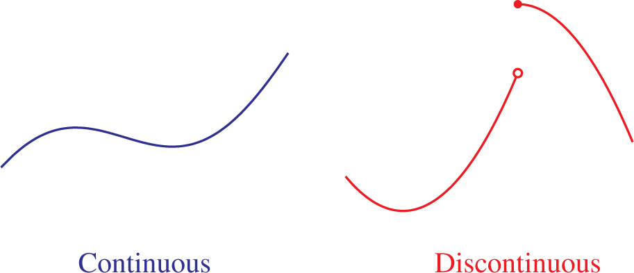

这句话传达了这样一个观点：跳跃不连续点，比如红色函数中间，应该使函数不连续，因为你必须抬起铅笔才能跳过这个间隙。但它显然不足以支持精确的数学论证;而且如果考虑到铅笔笔芯具有一定的非零宽度，且铅笔产生的材料由离散的碳原子组成，那么在细节上是不准确的。所以我们把它当作一个暗示性的隐喻，而不是数学定义。

This statement conveys the idea that a jump discontinuity, as occurs in the middle of the red function, should disqualify a function from being continuous, because you would have to lift your pencil to jump across the gap. But surely it is inadequate to support precise mathematical argument; and it is inaccurate in the fine detail, if one considers that the lead of a pencil has a certain nonzero width, and furthermore, the material coming off the pencil consists of discrete atoms of carbon. So let us take it as a suggestive metaphor rather than as a mathematical definition.

在入门微积分课程中，人们常常听到一个稍微更好的说法：

In introductory calculus classes, one often hears a slightly better statement:

函数*f*在*c*处连续，如果x越接近*c，f**（*x）越接近*f（*c），则f（*x*）也越接近f（*c*）。

A function *f* is continuous at *c* if the closer and closer *x* gets to *c*, the closer and closer *f*(*x*) gets to *f*(*c*).

这是一种改进，因为它表明可以通过对输入的函数施加越来越好的近似来获得连续函数在某一点的越来越好的近似;我们将 *F*（*x*） 视为 *F*（*C*） 的近似，而 *X* 是 *C* 的近似。

This is an improvement, by suggesting that one can obtain increasingly good approximations to the value of a continuous function at a point by applying the function to increasingly good approximations to the input; we view *f*(*x*) as an approximation of *f*(*c*) when *x* is an approximation of *c*.

但定义仍然过于模糊。更糟的是，这并不完全正确。假设你从纽约中央公园南向上城走。当你向北走时，你会越来越接近（哪怕只是稍微）北极。但你不会*靠近*北极，因为你会离北极数千英里。上述定义的问题在于它没有区分“越来越接近某个量”和“越来越接近”的概念。它能接近多久？多近才算足够近？定义并没有告诉我们。

But the definition is still much too vague. Worse, it is not quite right. Suppose you were to walk through Central Park in New York, proceeding uptown from Central Park South. As you walk north, you would be getting closer and closer (if only slightly) to the North Pole. But you would not be getting *close* to the North Pole, since you would remain thousands of miles away from it. The problem with the definition above is that it does not distinguish between the idea of getting closer and closer to a quantity and the idea of getting close to it. How close does it get? How close is close enough? The definition does not tell us.

换个角度来说，想象徒步者在下坡时的高程函数，向边缘陡然下降，那里有一个危险的悬崖突然下坠。当她接近悬崖边缘时，她越来越接近边缘，她的高度也越来越接近谷底高度（因为她在下降，即使只是略微下降），但高程函数并非连续，因为悬崖边缘出现了突然的垂直下降，形成跳跃不连续。 如果她真的走到那一步。

To make the same point differently, consider the elevation function of a hiker as she descends a gently sloped plateau toward its edge, where a dangerous cliff abruptly drops. As she approaches the cliff’s edge, she is getting closer and closer to the edge, and her elevation gets closer and closer to the elevation of the valley floor (since she is descending, even if only slightly), but the elevation function is not continuous, since there is an abrupt vertical drop at the cliff’s edge, a jump discontinuity, if she were to proceed that far.

### **连续性的定义** **The definition of continuity**

因此，更正确的定义不应是“越来越近”，而应关注*x*与*c*的具体距离以及*f*（*x*）与*f*（*c*）的距离，以及这些接近度之间的关系。这正是ε-δ定义中连续性的体现。

A more correct definition should therefore not speak of “closer and closer,” but should rather concern itself with exactly how close *x* is to *c* and how close *f*(*x*) is to *f*(*c*), and how these degrees of closeness are related. This is precisely what the epsilon-delta definition of continuity achieves.

**定义7。**实数函数*f**在点**c*连续，如果对每个正*ε>*0，存在*δ>0*，使得当*x*位于*c*的*δ*范围内时，*f*（*x*）*在f（**c*）的*ε*范围内。如果函数在每点都是连续的，则称该函数整体为连续。

**Definition 7.** A function *f* on the real numbers is *continuous* at the point *c* if for every positive *ε >* 0, there is *δ >* 0 such that whenever *x* is within *δ* of *c*, then *f*(*x*) is within *ε* of *f*(*c*). The function overall is said to be continuous if it is continuous at every point.

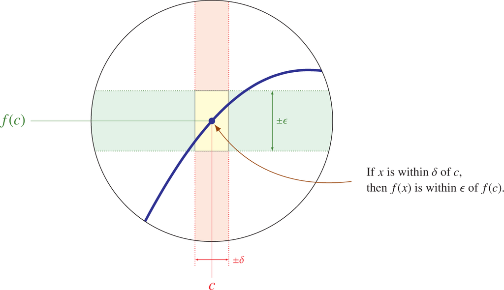

图中，*f*（*c*） *ε* 内的 *y* 值正好是横向绿色带内的值，而 *c* *δ* 以内的 *x* 值则是垂直红带内的值。因此，图示展示了成功选择*δ*的情况（你将在第2.3题中解释原因），即c *δ*内的每个*x**的f**（**x*）都在*f*（*c*）的*ε*范围内。

In the figure, the *y* values within *ε* of *f*(*c*) are precisely those within the horizontal green band, while the *x* values within *δ* of *c* are those within the vertical red band. The diagram therefore illustrates a successful choice of *δ*, a situation (and you will explain precisely why in question 2.3) where every *x* within *δ* of *c* has *f*(*x*) within *ε* of *f*(*c*).

我们可以简明地用符号表达*f*在*c*的连续性如下：

We may express the continuity of *f* at *c* succinctly in symbols as follows:

[figure not shown]

量词符号∀应读作“对所有”，符号∃为“存在”。因此，函数*f*在点*c*处连续，根据此，如果对于任意期望的精度*ε*，存在一个接近度*δ*，使得任何与c如此接近*的**x**的*f（*x*）都将在*f（**c*）的期望精度范围内。简而言之，你可以通过坚持 *x* 足够接近 *c*，确保 *f*（*x*） 与 *f*（*c*） 尽可能接近。

The quantifier symbol ∀ is to be read as “for all” and the symbol ∃ as “there exists.” So a function *f* is continuous at a point *c*, according to what this says, if for any desired degree of accuracy *ε*, there is a degree of closeness *δ*, such that any *x* that is that close to *c* will have *f*(*x*) within the desired accuracy of *f*(*c*). In short, you can ensure that *f*(*x*) is as close to *f*(*c*) as you want by insisting that *x* is sufficiently close to *c*.

### **连贯性游戏** **The continuity game**

考虑连贯性游戏。在这个游戏中，你的角色是保护函数*f*的连续性。挑战者给你一个值*C*和*一个ε>*0，你必须回答*δ>*0。挑战者可以选择 *c* *δ* 内的任意 *x*，只要 *f*（*x*） 确实在 *f*（*c*） 的 *ε* 范围内，你就赢了。在问题2.1中，你将证明函数*f*连续当且仅当你在此博弈中拥有必胜策略。

Consider the continuity game. In this game, your role is to defend the continuity of the function *f*. The challenger presents you with a value *c* and an *ε >* 0, and you must reply with a *δ >* 0. The challenger can then pick any *x* within *δ* of *c*, and you win, provided that *f*(*x*) is indeed within *ε* of *f*(*c*). In question 2.1, you will show that the function *f* is continuous if and only if you have a winning strategy in this game.

数学中的许多断言都存在这样的交替∀ ∃量词，这些量词总可以作为*游戏的战略*解读，挑战者使用全称∀量词实例，防守者则以证人回答∃。数学上复杂的断言通常会有许多量词的交替，这些对应于更长的博弈。也许正因为人类进化发生在一个本质上是博弈论人类选择的挑战环境中，战略失败会带来后果，我们似乎天生具备支撑这些复杂交替量词数学断言的战略推理能力。我觉得我们如何以这种方式利用人类经验获得数学洞见，这非常令人惊讶。

Many assertions in mathematics have such alternating ∀ ∃ quantifiers, and these can always be given the *strategic* reading for the game, in which the challenger plays instances of the universal ∀ quantifier and the defender answers with witnesses for ∃. Mathematically complex assertions often have many alternations of quantifiers, and these correspond to longer games. Perhaps because human evolution took place in a challenging environment of essentially game-theoretic human choices, with consequences for strategic failures, we seem to have an innate capacity for the strategic reasoning underlying these complex, alternating-quantifier mathematical assertions. I find it remarkable how we can leverage our human experience in this way for mathematical insight.

### **分析中的估计** **Estimation in analysis**

让我们通过证明两个连续函数的和是连续的，来说明ε-δ的定义在应用中。假设*f*和*g*在点*c*处都是连续的，考虑函数*f* + *g*，其在*c*处的值为*f*（*c*） + *g*（*c*）。为了证明该函数在*c*处连续，我们将提出一个称为*ε/*2*的参数*。考虑任何*ε>*0。因此，*ε/*2 > 0。由于 *f* 连续，存在 *δ*<sub>1</sub> > 0，使得 c 的任意 *x* 在 *c* 的 *δ*<sub>1</sub> *内 f*（*x*） 在 *f*（*c*） 的 *ε/*2 范围内。同样，由于 *g* 是连续的，存在 *δ*<sub>2</sub> > 0，使得 *c* *δ*<sub>2</sub> 内的*任意 x* 在 *g*（*c*） 的 *ε/*2 范围内的 *g*（*x*） 都存在。设*δ*为*δ*<sub>1</sub>和*δ*<sub>2</sub>中较小的。因此，如果*x*在*c*的*δ*范围内，那么它既在*c*的<sub>1</sub> *δ*范围内，又在*c*的*δ*<sub>2</sub>以内。因此，*f*（*x*） 位于 *f*（*c*） 的 *ε/*2 范围内，*而 g*（*x*） 位于 *g*（*c*） 的 *ε/*2 范围内。由此推测*，f*（*x*） + *g*（*x*） 在 *f*（*c*） + *g*（*c*） 的 *ε* 范围内，因为每个项的误差小于 *ε/*2，因此我们赢得了这次连续性博弈。因此*，f* + *g* 是连续的，正如所期望的。

Let us illustrate the epsilon-delta definition in application by proving that the sum of two continuous functions is continuous. Suppose that *f* and *g* are both continuous at a point *c*, and consider the function *f* + *g*, whose value at *c* is *f*(*c*) + *g*(*c*). To see that this function is continuous at *c*, we shall make what is known as an *ε/*2 *argument*. Consider any *ε >* 0. Thus also, *ε/*2 > 0. Since *f* is continuous, there is *δ*<sub>1</sub> > 0 such that any *x* within *δ*<sub>1</sub> of *c* has *f*(*x*) within *ε/*2 of *f*(*c*). Similarly, since *g* is continuous, there is *δ*<sub>2</sub> > 0 such that any *x* within *δ*<sub>2</sub> of *c* has *g*(*x*) within *ε/*2 of *g*(*c*). Let *δ* be the smaller of *δ*<sub>1</sub> and *δ*<sub>2</sub>. If *x* is within *δ* of *c*, therefore, then it is both within *δ*<sub>1</sub> of *c* and within *δ*<sub>2</sub> of *c*. Consequently, *f*(*x*) is within *ε/*2 of *f*(*c*) and *g*(*x*) is within *ε/*2 of *g*(*c*). It follows that *f*(*x*) + *g*(*x*) is within *ε* of *f*(*c*) + *g*(*c*), since each term has error less than *ε/*2, and thus we have won this instance of the continuity game. So *f* + *g* is continuous, as desired.

这一论证说明了“估计”方法，该方法在实分析领域至关重要，通过将一个数量拆分成单独分析的部分来界定其总误差。不仅有*ε*/2个参数，还有*ε*/3个参数，将数量拆分为三部分，以及*ε*/2<sup>*n*</sup>个参数，分解成无限多个部分，第*n*个部分的误差最多为*ε/*2<sup>*n*</sup>。关键是因为

This argument illustrates the method of “estimation,” so central to the subject of real analysis, by which one delimits the total error of a quantity by breaking it into pieces that are analyzed separately. One finds not only *ε/*2 arguments, but also *ε/*3 arguments, breaking the quantity into three pieces, and *ε/*2<sup>*n*</sup> arguments, splitting into infinitely many pieces, with the error in the *n*th piece at most *ε/*2<sup>*n*</sup>. The point is that because

[figure not shown]

这样，总误差就会被*ε*界定，符合期望。我要强调，“*估计*”一词的使用并不意味着人们在猜测差异有多大，而是在证明误差可能存在的绝对界限。

one thereby bounds the total error by *ε*, as desired. Let me emphasize that this use of the word *estimate* does not mean that one is somehow guessing how much the difference can be, but rather one is proving absolute bounds on how large the error could possibly be.

分析师的态度可以用以下口号表达：

The analyst’s attitude can be expressed by the slogan:

在代数中，它相*等**，相*等，相*等*。

In algebra, it is *equal*, *equal*, *equal*.

但在分析中，它是“*小*于等价”，“*小*于等价”，“*小*于等价”。

But in analysis, it is *less-than-or-equal*, *less-than-or-equal*, *less-than-or-equal*.

在代数中，人们通常沿着一系列方程进行，力求精确求解;而在分析中，则沿不等式序列进行，通过证明误差小于某一事物来进行误差估计，而该误差又小于另一项，依此类推，直到最终证明它小于目标*ε*， 如愿以偿。误差的确切值无关紧要;关键在于，它可以根据需要做得更小。

In algebra, one often proceeds in a sequence of equations, aiming to solve them exactly, while in analysis, one proceeds in a sequence of inequalities, mounting an error estimate by showing that the error is less than one thing, which is less than another, and so on, until ultimately, it is shown to be less than the target *ε*, as desired. The exact value of the error is irrelevant; the point, rather, is that it can be made as small as desired.

### **界限** **Limits**

ε-δ思想使极限概念得以形式化。即定义 *f*（*x*） 在 *x* 趋近 *c* 时的极限是量 *L*，写作如下：

The epsilon-delta idea enables a general formalization of the limit concept. Namely, one defines that the limit of *f*(*x*) as *x* approaches *c* is the quantity *L*, written like this:

[figure not shown]

如果对于任意*ε >* 0，存在*δ >* 0，使得任意 *x* 在 *c* *δ* 内（但忽略 *x* = *c*）在 *L* 的 *ε* 范围内的 *f*（*x*）。

if for any *ε >* 0, there is *δ >* 0 such that any *x* within *δ* of *c* (but ignoring *x* = *c*) has *f*(*x*) within *ε* of *L*.

但为什么会这么大惊小怪？限制和连续性是否需要如此过于精确和细致的处理？为什么我们不能用更自然、直观的叙述来应对？事实上，数学家们在牛顿和莱布尼茨之后的一个半世纪里，采用了非正式、直观的解释。ε-δ关于极限和连续性的概念酝酿已久，最终通过魏尔斯特拉斯以及柯西和博尔扎诺更早的使用实现了现代形式，这些概念源自早期关于无限微小的非正式概念，即无限小的量。让我们将这种用法与现代方法进行比较。

But why all the fuss? Do limits and continuity require such an overly precise and detailed treatment? Why can’t we get by with a more natural, intuitive account? Indeed, mathematicians proceeded with an informal, intuitive account for a century and half after Newton and Leibniz. The epsilon-delta conception of limits and continuity was a long time coming, achieving its modern form with Weierstrass and with earlier use by Cauchy and Bolzano, after earlier informal notions involving infinitesimals, which are infinitely small quantities. Let us compare that usage with our modern method.

## **2.2 瞬间变化** **2.2 Instantaneous change**

在微积分中，我们试图理解*瞬时*变化率的概念。从一座巨大的塔楼上掉下一颗钢球;球开始下落，随着重力向下拉扯，速度越来越快，直到落在地面上——小心！如果高度较大，球可能会达到终端速度，这发生在重力与空气摩擦力平衡时。但在此之前，球一直在*加速*，速度不断提升。这种情况与列车以恒定速度沿轨道行驶的情况本质上不同，我们可以通过求解以下方程计算出这个速度：

In calculus, we seek to understand the idea of an *instantaneous* rate of change. Drop a steel ball from a great tower; the ball begins to fall, with increasing rapidity as gravity pulls it downward, until it strikes the pavement—watch out! If the height is great, then the ball might reach terminal velocity, occurring when the force of gravity is balanced by the force of air friction. But until that time, the ball was *accelerating*, with its velocity constantly increasing. The situation is fundamentally different from the case of a train traveling along a track at a constant speed, a speed we can calculate by solving the equation:

[figure not shown]

然而，对于钢球，如果我们测量掉落的总时间和总距离，所得速度仅为平均速度。即使是非常小的区间内平均变化率，也无法完全捕捉瞬时变化率的概念。

For the steel ball, however, if we measure the total elapsed time of the fall and the total distance, the resulting rate will be merely an average velocity. The average rate over an interval, even a very small one, does not quite seem fully to capture the idea of an instantaneous rate of change.

### **无穷小** **Infinitesimals**

早期微积分的实践者用无穷小来解决了这个问题。考虑函数 *f*（*x*） = *x*<sup>2</sup>。在某一点*x*处*，f*的瞬时变化速率是多少？为此，我们考虑在一个极小的区间上——即从*x*到*x*+*δ*的区间，某个无穷小量*δ*的变化。函数因此从*f*（*x*）变为*f*（*x* + *δ*），因此在这极小区间内的平均变化率为

Early practitioners of calculus solved this issue with infinitesimals. Consider the function *f*(*x*) = *x*<sup>2</sup>. What is the instantaneous rate of change of *f* at a point *x*? To find out, we consider how things change on an infinitesimally small interval—the interval from *x* to *x* + *δ* for some infinitesimal quantity *δ*. The function accordingly changes from *f*(*x*) to *f*(*x* + *δ*), and so the average rate of change over this tiny interval is

[figure not shown]

由于*δ*是无穷小的，因此 2*x* + *δ* 与 2*x* 无穷近，因此我们得出函数的瞬时变化为 2*x*。换句话说，*x*<sup>2</sup>的*导数*是2*x*。

Since *δ* is infinitesimal, this result 2*x* + *δ* is infinitely close to 2*x*, and so we conclude that the instantaneous change in the function is 2*x*. In other words, the *derivative* of *x*<sup>2</sup> is 2*x*.

什么是无穷小数？如果一个无穷小的数只是非常微小但非零的数，那么我们最后把它排除在计算之外是错误的，而且我们得到的不是*f的瞬时*变化*率，而*只是得到一个区间*内的平均*变化率，即使那是一个非常小的区间。相比之下，如果无穷小数不仅是非常微小的数，而是无限微小的，那么这将是一种全新的数学量，我们似乎需要对其数学性质以及无穷小数在计算中如何相互作用进行更全面的解释。例如，在之前的计算中，我们是将这些无穷小数乘以实数，在其他情况下，我们会对这些表达式应用指数函数和三角函数。要有一个连贯的理论，我们似乎需要一个解释为什么这种说法合理。

What exactly is an infinitesimal number? If an infinitesimal number is just a very tiny but nonzero number, then we would be wrong to cast it out of the calculation at the end, and also we would not be getting the *instantaneous* rate of change in *f*, but rather only the *average* rate of change over an interval, even if it was a very tiny interval. If, in contrast, an infinitesimal number is not just a very tiny number, but rather infinitely tiny, then this would be a totally new kind of mathematical quantity, and we would seem to need a much more thorough account of its mathematical properties and how the infinitesimals interact with the real numbers in calculation. In the previous calculation, for example, we were multiplying these infinitesimal numbers by real numbers, and in other contexts, we would be applying exponential and trigonometric functions to such expressions. To have a coherent theory, we would seem to need an account of why this is sensible.

伯克利主教（1734年）对微积分的基础提出了严厉批评。

Bishop Berkeley (1734) makes a withering criticism of the foundations of calculus.

那么这些同样短暂的增量又是什么？它们既不是有限的量，也不是无限小的量，更不是无物。我们难道不能称它们为逝去的幽灵吗？

And what are these same evanescent Increments? They are neither finite Quantities nor Quantities infinitely small, nor yet nothing. May we not call them the ghosts of departed quantities?

伯克利的讽刺点是，本质上看似相似的推理可以用来建立我们知道错误的无意义数学断言。例如，如果*δ*非常小，那么2*δ*和3的*δ*相差极小。如果我们现在把这个差值当作零，那么2*δ*=3*δ*，由此我们可以得出2=3的结论，这很荒谬。如果我们不愿意接受这个结论，为什么我们要认为早期对无穷小的处理是有效的？似乎并不够清楚何时我们可以合理地将无穷小量视为零，何时不能，微积分的早期基础开始显得存在问题，尽管实践者在实践中能够避免错误结论。微积分的基础变得无法无天。

Berkeley’s mocking point is that essentially similar-seeming reasoning can be used to establish nonsensical mathematical assertions, which we know are wrong. For example, if *δ* is vanishingly small, then 2*δ* and 3*δ* differ by a vanishingly small quantity. If we now treat that difference as zero, then 2*δ* = 3*δ*, from which we may conclude 2 = 3, which is absurd. Why should we consider the earlier treatment of infinitesimals as valid if we are not also willing to accept this conclusion? It seems not to be clear enough when we may legitimately treat an infinitesimal quantity as zero and when we may not, and the early foundations of calculus begin to seem problematic, even if practitioners were able to avoid erroneous conclusions in practice. The foundations of calculus become lawless.

### **导数的现代定义** **Modern definition of the derivative**

ε-δ极限定概念解决了这些反对意见，为微积分奠定了新的坚实基础，为成熟的实分析理论铺平了道路。函数*f*导数的现代定义为

The epsilon-delta limit conception addresses these objections and establishes a new, sound foundation for calculus, paving the way for the mature theory of real analysis. The modern definition of the derivative of a function *f* is given by

[figure not shown]

前提是存在这个极限，使用我们之前提到的Epsilon-Δ极限概念。因此，*δ*不只使用单个无穷小量，而是实际上使用多个不同的增量 *h*，并在 *h* 趋近于零时取极限。这种精确的极限处理方式避免了无穷小函数的所有悖论问题，同时保留了其背后的本质直觉——即连续函数是指输入的微小变化只会导致输出微小变化，且函数在某一点的导数是从该点周围越来越小区间内函数的平均变化率得到的。

provided that this limit exists, using the epsilon-delta notion of limit we mentioned earlier. Thus, one does not use just a single infinitesimal quantity *δ*, but rather one in effect uses many various increments *h* and takes a limit as *h* goes to zero. This precise manner of treating limits avoids all the paradoxical issues with infinitesimals, while retaining the essential intuition underlying them—that the continuous functions are those for which small changes in input cause only small changes in the output, and the derivative of a function at a point is obtained from the average rate of change of the function over increasingly tiny intervals surrounding that point.

## **2.3 概念词汇的扩展** **2.3 An enlarged vocabulary of concepts**

ε-δ极限方法所提供的丰富数学词汇扩展了我们表达新颖、更微妙数学概念的能力，极大丰富了学科。让我们来尝尝这些更细致的可能性。

The enlarged mathematical vocabulary provided by the epsilon-delta approach to limits expands our capacity to express new, subtler mathematical concepts, greatly enriching the subject. Let us get a taste of these further refined possibilities.

加强连续性概念，例如，如果对于任意*ε >* 0，存在*δ >* 0，使得当 *x* 和 *y* 在 *δ* 内时，则 *f*（*x*） 和 *f*（*y*） 都在 *ε* 内，则称函数 *f* 在*实*数上的一致连续.但等等——这和普通的连贯性有什么不同？区别在于，普通连续性是在每个点*c*上独立断言，每个数字*c*有独立*的ε*和*δ*。特别地，对于普通连续性，选择*δ*在 *c* 处连续性的值不仅取决于 *ε*，还取决于 *c*。相比之下，在均匀连续性中，*δ*的数量可能仅依赖*于ε*。同一*δ*必须对每个 *x* 和 *y* 均匀工作（这里 *y* 实际上扮演 *c* 的角色）。

Strengthening the continuity concept, for example, a function *f* on the real numbers is said to be *uniformly* continuous if for every *ε >* 0, there is *δ >* 0 such that whenever *x* and *y* are within *δ*, then *f*(*x*) and *f*(*y*) are within *ε*. But wait a minute—how does this differ from ordinary continuity? The difference is that ordinary continuity is a separate assertion made at each point *c*, with separate *ε* and *δ* for each number *c*. In particular, with ordinary continuity, the value *δ* chosen for continuity at *c* can depend not only on *ε*, but also on *c*. With uniform continuity, in contrast, the quantity *δ* may depend only on *ε*. The same *δ* must work uniformly with every *x* and *y* (the number *y* in effect plays the role of *c* here).

考虑函数 *f*（*x*） = *x*<sup>2</sup>，一个简单抛物线，定义域为所有实数。该函数确实是连续的，但在该整域上并非均匀连续，因为当x值较大时，它变得尽可能陡*峭。*也就是说，对于任何*>*0的δ，如果离原点足够远，抛物线就会变得足够陡峭，可以找到数字*x*和*y*非常接近，相差不到*δ*，而*x2*和*y2*变化巨大。因此，即使取非常粗略的值为*ε*，也不可能存在单一*δ*对所有 *x* 和 *y* 都适用。同时，利用实数线闭区间的*紧致性*性质（由Heine-Borel定理表达），可以证明，定义在实数闭区间[*a， b*]上的任意*连续函数f*在该区间上都是一致连续的。

Consider the function *f*(*x*) = *x*<sup>2</sup>, a simple parabola, on the domain of all real numbers. This function is continuous, to be sure, but it is not uniformly continuous on this domain, because it becomes as steep as one likes as one moves to large values of *x*. Namely, for any *δ >* 0, if one moves far enough away from the origin, then the parabola becomes sufficiently steep so that one may find numbers *x* and *y* very close together, differing by less than *δ*, while *x*<sup>2</sup> and *y*<sup>2</sup> have changed by a huge amount. For this reason, there can be no single *δ* that works for all *x* and *y*, even when one takes a very coarse value of *ε*. Meanwhile, using what is known as the *compactness* property of closed intervals in the real number line (expressed by the Heine-Borel theorem), one can prove that every continuous function *f* defined on a closed interval in the real numbers [*a, b*] is uniformly continuous on that interval.

统一连续性概念源于连续性陈述中量词顺序的简单变化，可以通过比较来看出：

The uniform continuity concept arises from a simple change in quantifier order in the continuity statement, which one can see by comparing:

实数上的函数*f**连续*，当

A function *f* on the real numbers is *continuous* when

[figure not shown]

而 *f* 是*均匀连续*的，当

whereas *f* is *uniformly continuous* when

[figure not shown]

让我们探讨其他几种类似的变体——哪些概念会以这种方式产生？读者被要求提供问题2.5中这三个陈述的含义，并在每个案例中准确指出哪些函数表现出该性质：

Let us explore a few other such variations—which concepts result this way? The reader is asked to provide the meaning of these three statements in question 2.5 and to identify in each case exactly which functions exhibit the property:

- ∃*δ >* 0 *∀ε >* 0 ∀*x， y* [*x， y* within *δ* ⟹ *f*（*x*）， *f*（*y*） within *ε*]。
- ∃*δ >* 0 ∀*ε >* 0 ∀*x, y* [*x, y* within *δ* ⟹ *f*(*x*)*, f*(*y*) within *ε*].
- ∀*ε >* 0 ∀*x， y* ∃*δ >* 0 [*x， y* *δ* ⟹ *f*（*x*）内*， f*（*y*） *ε*内]。
- ∀*ε >* 0 ∀*x, y* ∃*δ >* 0 [*x, y* within *δ* ⟹ *f*(*x*)*, f*(*y*) within *ε*].
- ∀*ε >* 0 ∀*δ >* 0 ∀*x* *∃y* [*x， y* *δ* 内 和 *f*（*x**）， f*（*y*） *ε* 内]。
- ∀*ε >* 0 ∀*δ >* 0 ∀*x* ∃*y* [*x, y* within *δ* and *f*(*x*)*, f*(*y*) within *ε*].

此外，在最后一个例子中要求*x满足≠y*，也带来了一个有趣且微妙的性质。

Also requiring *x ≠ y* in the last example makes for an interesting, subtle property.

埃雷特·毕晓普（1977）将ε-delta的连续性概念描述为“常识”，我也倾向于同意。然而，在我看来，连续性陈述中细微的句法差异导致了截然不同的概念，这似乎凸显了ε-delta连续性叙述的根本微妙性和脆弱性，而该概念的微妙性可能表明其高度精炼。

Errett Bishop (1977) describes the epsilon-delta notion of continuity as “common sense,” and I am inclined to agree. To my way of thinking, however, the fact that minor syntactic variations in the continuity statement lead to vastly different concepts seems to underline a fundamental subtlety and fragility of the epsilon-delta account of continuity, and the delicate nature of the concept may indicate how greatly refined it is.

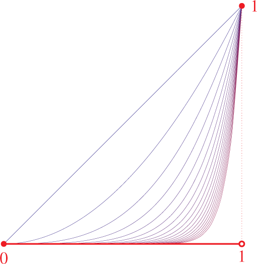

假设我们有一列连续函数 *f*<sub>0</sub>， *f*<sub>1</sub>， *f*<sub>2</sub>， ...，它们恰好逐点收敛到极限函数 *f*<sub>*n*</sub>（*x*） → *f*（*x*）。极限函数也必须是连续的吗？柯西在此上犯了一个错误，他声称连续函数的收敛级数是连续的。但事实证明这是错误的。作为反例，考虑函数 *x*， *x*<sup>2</sup>， *x*<sup>3</sup>， ...单位区间，如图中蓝色所示。这些函数各自是连续的，但随着指数的增长，它们在大部分区间变得平坦，右侧尖锐为1。因此，红色显示的极限函数值常数为0，除非在*x* = 1时跳跃不连续度可达1。因此，连续函数的收敛极限不一定是连续的。为柯西辩护，他使用的是收敛级数而非逐点收敛极限，这掩盖了反例，尽管可以通过连续差异在序列和级数之间转换，使这两种表述同样错误。与此同时，伊姆雷·拉卡托斯（2015年[1976年]）在历史背景下对柯西论点提出了更宽容的看法。

通过加强点对点收敛为一致收敛 *f*<sub>*n*</sub> ⇉ *f*，可以找到正确的推论版本，这意味着对于每个 *ε >* 0，存在 *N*，使得每个函数 *f*<sub>*n 对*</sub> *n* ≥ *N* 都包含在一个围绕 *f* 的 *ε* 管内，意味着 *f*<sub>*n*</sub>（*x*对于每个 *x*，都位于 *f*（*x*） *的 ε* 范围内。连续函数的一致极限确实通过*一个ε/*3的连续变量：如果*x*接近*c*，则*fn*<sub>（</sub>*x*）最终接近*f*（*x*），且接近*f*（c），又接近f*（**c*）。更一般地，如果一个单点收敛的函数列构成*一个等连续族*，这意味着在每个点*c*和对每个*>ε* 0，存在一个*δ* 0，>*对c处*的每个<sub>*fn*</sub>都有效，那么极限函数是连续的。

One finds a correct version of the implication by strengthening pointwise convergence to uniform convergence *f*<sub>*n*</sub> ⇉ *f*, which means that for every *ε >* 0, there is *N* such that every function *f*<sub>*n*</sub> for *n* ≥ *N* is contained within an *ε* tube about *f*, meaning that *f*<sub>*n*</sub>(*x*) is within *ε* of *f*(*x*) for every *x*. The uniform limit of continuous functions is indeed continuous by an *ε/*3 argument: if *x* is close to *c*, then *f*<sub>*n*</sub>(*x*) is eventually close to *f*(*x*) and to *f*<sub>*n*</sub>(*c*), which is close to *f*(*c*). More generally, if a merely pointwise convergent sequence of functions forms an *equicontinuous family*, which means that at every point *c* and for every *ε >* 0, there is a *δ >* 0 that works for every *f*<sub>*n*</sub> at *c*, then the limit function is continuous.

我想说的是，ε-delta方法不仅仅是修复破碎的基础，而保留其余结构。我们不仅仅是在崭新（更稳固）的基础上重复老一套的推理方式。相反，新方法引入了新的推理模式，打开了通往新概念和细微区分的大门。通过新方法，我们可以对之前的理解做出细微的渐进，这些理解现在被视为粗糙;我们可以区分连续性与均匀连续性，或点数收敛、均匀收敛和等连续族的收敛。这极大地清晰了我们对该学科的数学理解。

What I am arguing is that the epsilon-delta methods do not serve merely to repair a broken foundation, leaving the rest of the structure intact. We do not merely carry out the same old modes of reasoning on a shiny new (and more secure) foundation. Rather, the new methods introduce new modes of reasoning, opening doors to new concepts and subtle distinctions. With the new methods, we can make fine gradations in our previous understanding, now seen as coarse; we can distinguish between continuity and uniform continuity or among pointwise convergence, uniform convergence, and convergence for an equicontinuous family. This has been enormously clarifying, and our mathematical understanding of the subject is vastly improved.

## **2.4 最小上界原理** **2.4 The least-upper-bound principle**

实分析的主题可以建立在*最小上界原理*之上，即Dedekind完备性的一种版本。以此为核心原则，我们继续证明所有熟悉的基础定理，如中间值定理、海涅-博雷尔定理等。从某种意义上说，最小上界原理对实分析的意义，就像归纳原理之于数论一样。

The subject of real analysis can be founded upon the *least-upper-bound principle*, a version of Dedekind completeness. Taking this as a core principle, one proceeds to prove all the familiar foundational theorems, such as the intermediate value theorem, the Heine-Borel theorem and many others. In a sense, the least-upper-bound principle is to real analysis what the induction principle is to number theory.

**最小上界原则。** *每个有上界的非空实数集合都有一个最小上界。*

**Least-upper-bound principle.** *Every nonempty set of real numbers with an upper bound has a least upper bound.*

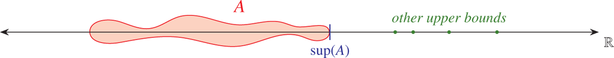

An upper bound of a set *A* ⊆ ℝ is simply a real number *r*, such that every element of *A* is less than or equal to *r*. The number *r* is the *least* upper bound of *A*, also called the *supremum* of *A* and denoted sup(*A*), if *r* is an upper bound of *A* and *r* ≤ *s* whenever *s* is an upper bound of *A*.

### **完备性的后果** **Consequences of completeness**

让我们通过勾勒出实分析中几个熟悉的基本结果的证明来说明这一基本原理的应用。首先考虑*中间值定理，该定理*断言如果 *f* 是实数上的连续函数，且 *d* 是 *f*（*a*） 和 *f*（*b*） 之间的中间值，则存在一个实数 *c*，介于 *a* 和 *b* 之间，且 *f*（*c*） = *d*。简而言之，它断言对于连续函数，每个中间值都被实现。

Let us illustrate how this fundamental principle is used by sketching proofs of a few familiar elementary results in real analysis. Consider first the *intermediate-value theorem*, which asserts that if *f* is a continuous function on the real numbers and *d* is an intermediate value between *f*(*a*) and *f*(*b*), then there is a real number *c* between *a* and *b*, with *f*(*c*) = *d*. In short, it asserts that for continuous functions, every intermediate value is realized.

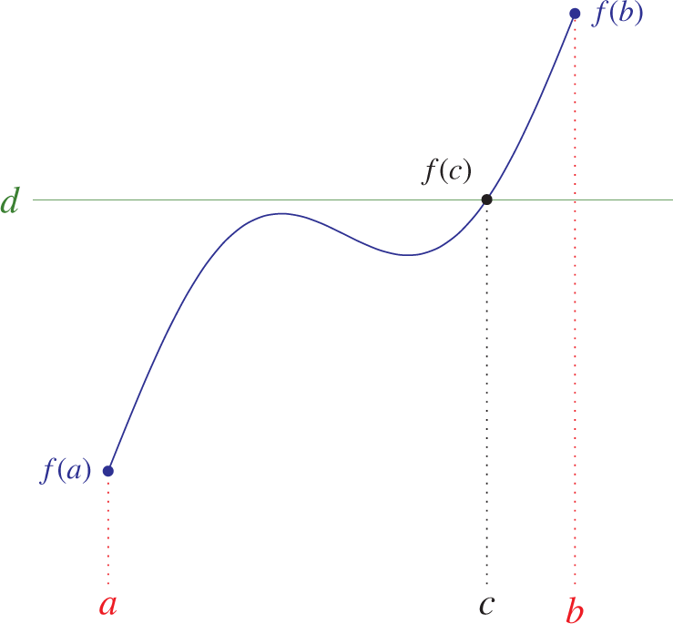

为了从最小上界原理证明这一点，假设*a < b* 和 *f*（*a*） *< d 都 < f*（*b*），并考虑区间 [*a， b*] 内所有实数 *x* 的集合 *A*，其中 *f*（*x*） *< d*。该集合非空，因为*a*属于*A*，且被*b*界定。根据最小上界原理，因此它的最小上界为 *c* = sup（*A*）。考虑 *f*（*c*） 的值。如果 *f*（*c*） 太小，即 *f*（*c*） *< d*，则根据 *f* 的连续性，*x 在* *c* 附近的 *f*（*x*） 值也都小于 *d*。但这意味着*A*在*c*之上存在一些元素，与*c* = sup（*A*）相反。因此，*f*（*c*） ≥ *d*。同样，如果 *f*（*c*） 太大，也就是说 *f*（*c*） *> d*，那么根据 *f* 的连续性，c 的一个小邻域中 *x* 的 *f*（*x*） *值都大*于 *d*，这与 *c* = sup（*A*） 矛盾，因为必须存在 *A* 中与 *c* 极为接近的元素，而这些元素 *x* 必须满足*f*（*x*） *< d* 的*定义。*因此，必须是 *f*（*c*） = *d*，并且我们找到了期望的点 *c*，实现了中间值 *d*。

To prove this from the least-upper-bound principle, assume that *a < b* and *f*(*a*) *< d < f*(*b*), and consider the set *A* of all real numbers *x* in the interval [*a, b*] for which *f*(*x*) *< d*. This set is nonempty because *a* is in *A*, and it is bounded by *b*. By the least-upper-bound principle, therefore, it has a least upper bound *c* = sup(*A*). Consider the value of *f*(*c*). If *f*(*c*) is too small, meaning that *f*(*c*) *< d*, then by the continuity of *f*, the values of *f*(*x*) for *x* near *c* will all also be less than *d*. But this would mean that *A* has some elements above *c*, contrary to *c* = sup(*A*). Therefore, *f*(*c*) ≥ *d*. Similarly, if *f*(*c*) is too large, meaning that *f*(*c*) *> d*, then again by the continuity of *f*, the values of *f*(*x*) for *x* in a small neighborhood of *c* will all be above *d*, contradicting *c* = sup(*A*), since there must be elements of *A* as close as desired to *c*, and those elements *x* must have *f*(*x*) *< d* by the definition of *A*. Therefore, it must be that *f*(*c*) = *d*, and we have found the desired point *c* realizing the intermediate value *d*.

接下来考虑*海涅-博雷尔定理，该定理*断言单位区间 [0， 1] 是*紧的*。这意味着，当 U 是覆盖实数闭单位区间的开区间集合时，则存在有限多个 U 的开区间覆盖 [0， 1]。嗯？对于对实分析新手来说，这种开放式结局的重要性可能并不明显;也许这甚至显得有些奇怪。为什么每个闭区间的开覆盖都必须包含有限子覆盖？答案是，这一性质极其重要，事实上，紧致性概念的重要性难以过分强调，而紧致性是成千上万数学论证的关键。它所涉及的潜在思想最终发展为拓扑学这一主题。让我们尝尝一小段。

Consider next the *Heine-Borel theorem*, which asserts that the unit interval [0, 1] is *compact*. What this means is that whenever 𝒰 is a set of open intervals covering the closed unit interval in the real numbers [0, 1], then there are finitely many open intervals of 𝒰 that already cover [0, 1]. Huh? For someone new to real analysis, the importance of this open-cover conclusion may not be readily apparent; perhaps it may even seem a little bizarre. Why would it be important that every open cover of a closed interval admits a finite subcover? The answer is that this property is vitally important, and indeed, it is difficult to overstate the importance of the compactness concept, which is the key to thousands of mathematical arguments. The underlying ideas with which it engages grow ultimately into the subject of topology. Let us have a small taste of it.

为了证明海涅-博雷尔定理，固定由实数中的开区间组成的开覆盖U，使得每个数字*x*∈[0， 1]都属于某个*U*∈U。考虑集合*B*，包含所有*x*的x∈[0， 1]，使得区间[0*， x*]被U的有限多个元素覆盖。因此，0 ∈ *B*，因为 [0， 0] 只有点 0，该点被 U 中的某个开集覆盖。设*b*为*B*在[0， 1]中的最小上界。如果 *b* = 1，那么我们可以用有限多个 U 的元素覆盖 [0， 1]，就完成了。所以假设*b<*1。由于U覆盖整个区间，存在一个开区*间U∈*U，其中*b*∈*U*。由于 *U* 包含 *b* 的一个邻域，即 *B* 的上确界，B ∈必定*存在一个点* *x* 满足 *x* ∈ *U*。因此，我们可以用有限多个开集覆盖[0*， x*]，而集合*U*本身覆盖区间[*x， b*]的其余部分，因此我们用有限多个开区间覆盖了区间[0*， b*]。但由于开区间必须严格超出 *b*，因此 *B* 中必有严格大于 *b* 的元素，这与 *b* 是 *B* 的最小上界假设相矛盾。所以我们已经证明了定理。

To prove the Heine-Borel theorem, fix the open cover 𝒰, consisting of open intervals in the real numbers, such that every number *x* ∈ [0, 1] is in some *U* ∈ 𝒰. Consider the set *B* consisting of all *x* ∈ [0, 1], such that the interval [0*, x*] is covered by finitely many elements of 𝒰. Thus, 0 ∈ *B*, since [0, 0] has just the point 0, which is covered by some open set in 𝒰. Let *b* be the least upper bound of *B* in [0, 1]. If *b* = 1, then we can cover [0, 1] with finitely many elements of 𝒰, and we’re done. So assume that *b <* 1. Since 𝒰 covers the entire interval, there is some open interval *U* ∈ 𝒰 with *b* ∈ *U*. Since *U* contains a neighborhood of *b*, which is the supremum of *B*, there must be a point *x* ∈ *B* with *x* ∈ *U*. Therefore, we can cover [0*, x*] with finitely many open sets from 𝒰, and the set *U* itself covers the rest of the interval [*x, b*], and so we have covered the interval [0*, b*] with finitely many open intervals from 𝒰. But because the open interval must spill strictly beyond *b*, there must be elements of *B* strictly larger than *b*, which contradicts the assumption that *b* is the least upper bound of *B*. So we have proved the theorem.

最小上界原理的另一个应用是每个嵌套的降序闭区间序列都有一个非空交集。也就是说，如果

Another application of the least-upper-bound principle is the fact that every nested descending sequence of closed intervals has a nonempty intersection. That is, if

[figure not shown]

那么在每个区间*z*∈内存在一个实数*z*[*a*<sub>*n*</sub>*， b*<sub>*n*</sub>]。可以简单地设 *z* = sup<sub>*n a*</sub><sub>*n*</sub>。更一般地，利用海涅-博雷尔定理，可以证明实数区间内每个非空闭集的嵌套降序列都存在非空交集。如果不存在这样的实数 *z*，那么这些闭集的补集将形成原区间的开覆盖，没有有限子覆盖，这与海涅-博雷尔定理相悖。

then there is a real number *z* inside every interval *z* ∈ [*a*<sub>*n*</sub>*, b*<sub>*n*</sub>]. One can simply let *z* = sup<sub>*n*</sub>*a*<sub>*n*</sub>. More generally, using the Heine-Borel theorem, one can prove that every nested descending sequence of nonempty closed sets in a real number interval has a nonempty intersection. For if there were no such real number *z*, then the complements of those closed sets would form an open cover of the original interval, with no finite subcover, contrary to the Heine-Borel theorem.

### **连续归纳** **Continuous induction**

之前我做了一个类比，将实分析中的最小上界原理与数论中的数学归纳原理进行类比。鉴于连续归纳原理，这一类比非常有力，连续归纳法是最小上界原理的类归纳表述，可用于推导实分析中的许多基本结果。

Earlier I made an analogy between the least-upper-bound principle in real analysis and the principle of mathematical induction in number theory. This analogy is quite strong in light of the principle of continuous induction, which is an inductionlike formulation of the least-upper-bound principle that can be used to derive many fundamental results in real analysis.

**连续归纳原理。** *如果A是一组非负实数，满足*

**Principle of continuous induction.** *If A is a set of nonnegative real numbers such that*

*1.* 0 ∈ *A;*

*1.* 0 ∈ *A;*

*2. 如果x*∈*A，则存在δ 0>**，且⊆**A为*[*x， x* + *δ*）;

*2. If x* ∈ *A, then there is δ >* 0 *with* [*x, x* + *δ*) ⊆ *A;*

*3. 如果 x 是一个实数，且* [0*， x*） ⊆ *A，则 x* ∈ *A*。

*3. If x is a real number and* [0*, x*) ⊆ *A, then x* ∈ *A*.

*则A是所有非负实数的集合。*

*Then A is the set of all nonnegative real numbers.*

通俗来说，该原理具有锚定假设0属于集合*A*，并且具有归纳性质：只要所有直到数*x*的数都属于*A*，那么*x*本身属于*A*;每当数字*x*属于*A*时，你可以稍微往上推，所有介于*x*和*某个x*+*δ*之间的数字都属于*A*。结论与归纳原理类似，任何此类集合*A*必须包含所有数（此处为所有非负实数）。

In plain language, the principle has the anchoring assumption that 0 is in the set *A*, and the inductive properties that whenever all the numbers up to a number *x* are in *A*, then *x* itself is in *A*; and whenever a number *x* is in *A*, then you can push it a little higher, and all the numbers between *x* and some *x* + *δ* are in *A*. The conclusion, just as in the principle of induction, is that any such set *A* must contain every number (in this case, every nonnegative real number).

元任超（1919年）描述了类似的原则：

Yuen Ren Chao (1919), describes a similar principle like this:

该定理是对“楔子的细端”或“骆驼鼻子”中常见论证的数学表述。

The theorem is a mathematical formulation of the familiar argument from “the thin end of the wedge,” or again, the argument from “the camel’s nose.”

Hyp。1. 允许饮用半杯啤酒。

Hyp. 1. Let it be granted that the drinking of half a glass of beer be allowable.

Hyp。2. 如果允许任何啤酒*数量x，*只要不超过不可察觉的量*Δ，δ*就没有理由不允许x+*δ*。

Hyp. 2. If any quantity, *x*, of beer is allowable, there is no reason why *x* + *δ* is not allowable, so long as *δ* does not exceed an imperceptible amount Δ.

因此，任意数量都是允许的。

Therefore any quantity is allowable.

连续归纳原理可以通过最小上界原理证明，方法是考虑满足[0*， a*]⊆*A*的数集*a的上*确界r。该上确界必须属于*A*，因为[0*， r*）⊆*A*;但如果 *r* ∈ *A*，那么它至少应该比实际大一点，这就自相矛盾了。反之亦然，正如读者将在第2.16题中证明的那样，因此我们有三个等价的原则：连续归纳、最小上界和Dedekind完备性。

The principle of continuous induction can be proved from the least-upper-bound principle, by considering the supremum *r* of the set of numbers *a* for which [0*, a*] ⊆ *A*. This supremum must be in *A* because [0*, r*) ⊆ *A*; but if *r* ∈ *A*, then it should be at least a little larger than it is, which is a contradiction. The converse implication also holds, as the reader will prove in question 2.16, and so we have three equivalent principles: continuous induction, least upper bounds, and Dedekind completeness.

数学家有时会对连续归纳法原理感到惊讶——即实数上存在使用实数序归纳法的原理——因为普遍存在一种观点，甚至根深蒂固的期望，认为归纳法在良序情况下是根本离散且合理的。然而，我们现在面对的是基于连续序的实数归纳原理。

Mathematicians are sometimes surprised by the principle of continuous induction—by the idea that there is a principle of induction on the real numbers using the real-number order—because there is a widely held view, or even an entrenched expectation, that induction is fundamentally discrete and sensible only with well-orders. Yet here we are with an induction principle on the real numbers based on the continuous order.

连续归纳原理非常实用，可以用来建立实分析的大部分初等理论。我们用该原理来说明，给出海涅-博雷尔定理的另一种归纳证明。假设U是[0， 1]的一个开覆盖。我们将通过连续归纳法证明，每个子区间 [0*， x*] 中 *x ≤ 1* 为 0 ≤ 都被 U 的有限个元素覆盖。当 *x* = 0 时，这也成立，因为 [0， 0] 只有一个点。如果[0*， x*]被U中有限多个集合覆盖，那么包含*x*的开集也必须稍微超过*x*，因此同一有限集合覆盖一个非平凡的扩张[0*， x* + *δ*]。如果每个较小区间 [0*， r*] 对 *r < x* 都是有限覆盖的，则取包含 *x* 的开集，该开集必须包含某个 *r < x* 的 （*r， x*];通过将该开集与有限覆盖 [0*， R*] 结合，我们得到有限覆盖 [0*， x*]。因此，通过连续归纳法，每个[0*， x*]都有一个有限的子覆盖。特别地，[0， 1] 本身是有限覆盖的，正如所愿。

The principle of continuous induction is quite practical and can be used to establish much of the elementary theory of real analysis. Let us illustrate this by using the principle to give an alternative inductive proof of the Heine-Borel theorem. Suppose that 𝒰 is an open cover of [0, 1]. We shall prove by continuous induction that every subinterval [0*, x*] with 0 ≤ *x* ≤ 1 is covered by finitely many elements of 𝒰. This is true of *x* = 0, since [0, 0] has just one point. If [0*, x*] is covered by finitely many sets from 𝒰, then whichever open set contains *x* must also stick a bit beyond *x*, and so the same finite collection covers a nontrivial extension [0*, x* + *δ*]. And if every smaller interval [0*, r*] for *r < x* is finitely covered, then take an open set containing *x*, which must contain (*r, x*] for some *r < x*; by combining that one open set with a finite cover of [0*, r*], we achieve a finite cover of [0*, x*]. So by continuous induction, every [0*, x*] has a finite subcover from 𝒰. In particular, [0, 1] itself is finitely covered, as desired.

## **2.5 数学的不可或缺性** **2.5 Indispensability of mathematics**

我们能从数学工具和词汇似乎几乎是每一个当代科学理论核心的事实中得出什么哲学结论？令人惊讶的是，从微观到宇宙的每一个物理尺度，我们最好的科学理论都是彻底的数学。为什么会这样？牛顿物理的定律通过解释力与运动相互作用的普遍微分方程表达，统一了我们对多种物理现象的理解，从弹簧上的质量的谐振荡到天体的行星运动;我们最好的电磁学理论假设有无形的电磁场环绕着我们所有人，包围着地球;相对论用奇异的数学几何解释空间和时间的本质;量子力学使用希尔伯特空间;弦理论使用更抽象的数学对象;所有实验科学，包括社会科学，都基础性地运用了数理统计。物理学家保罗·狄拉克（1963年）这样描述了这一情况：

What philosophical conclusion can we make from the fact that mathematical tools and vocabulary seem to lie at the very core of nearly every contemporary scientific theory? How remarkable that at every physical scale, from the microscopic to the cosmic, our best scientific theories are thoroughly mathematical. Why should this be? The laws of Newtonian physics are expressed in universal differential equations that explain the interaction of forces and motion, unifying our understanding of diverse physical phenomena, from the harmonic oscillations of a mass on a spring to the planetary motions of the heavenly bodies; our best theory of electromagnetism posits unseen electrical and magnetic fields that surround us all, enveloping the Earth; relativity theory explains the nature of space and time with exotic mathematical geometries; quantum mechanics uses Hilbert spaces; string theory uses still more abstract mathematical objects; and all the experimental sciences, including the social sciences, make fundamental use of mathematical statistics. Physicist Paul Dirac (1963) describes the situation like this:

自然的基本特征之一似乎是，基本物理定律被用极具美感和力量的数学理论来描述，而理解它需要相当高的数学水平。你可能会想：为什么自然会按照这种方式构建？只能回答我们目前的知识表明自然是这样被建构的。我们只能接受它。或许可以这样形容，上帝是一位非常高水平的数学家，祂在构建宇宙时使用了非常先进的数学。我们对数学的微弱尝试使我们能够理解宇宙的一部分，随着我们不断发展更高级的数学，我们有望更好地理解宇宙。<sup>2</sup>

It seems to be one of the fundamental features of nature that fundamental physical laws are described in terms of a mathematical theory of great beauty and power, needing quite a high standard of mathematics for one to understand it. You may wonder: Why is nature constructed along these lines? One can only answer that our present knowledge seems to show that nature is so constructed. We simply have to accept it. One could perhaps describe the situation by saying that God is a mathematician of a very high order, and He used very advanced mathematics in constructing the universe. Our feeble attempts at mathematics enable us to understand a bit of the universe, and as we proceed to develop higher and higher mathematics we can hope to understand the universe better.<sup>2</sup>

因此，数学似乎对物理和其他科学至关重要。

Thus, mathematics appears to be indispensable for physics and other sciences.

基于此，希拉里·普特南和威拉德·范·奥尔曼·奎因提出了数学实在论的*不可或缺性*论证，主张我们应当对那些不可或缺于我们最佳科学理论的对象抱持本体论承诺（参见普特南（1971）的经典论述）。正如科学家在没有直接观察的情况下，基于病菌理论为看不见的微观生物存在找到理由，正如科学家可能认同原子物质理论、电子或地球熔融铁核的存在， 或者黑洞或波函数，即使我们有充分支持的理论中的证据是间接的，同样地，根据不可或缺性论证，我们也应当为我们最佳理论中出现的抽象数学对象的存在找到依据。奎因强调确认整体论的*观点，即*理论只能作为整体被证实。如果数学主张是理论不可或缺的一部分，那么它们就是被证实内容的一部分。

On the basis of this, Hilary Putnam and Willard Van Orman Quine mount the *indispensability* argument for mathematical realism, arguing that we ought to have an ontological commitment to the objects that are indispensably part of our best scientific theories (see Putnam (1971) for a classic presentation). Just as a scientist finds grounds for the existence of unseen microscopic organisms on the basis of the well supported germ theory of disease, even in the absence of direct observations of those organisms, and just as a scientist might commit to the atomic theory of matter or the existence of electrons or a molten iron core in the Earth, or black holes, or wave functions, even when the evidence for them in our well supported theories is indirect, then similarly, according to the indispensability argument, we should find grounds for the existence of the abstract mathematical objects that appear in our best theories. Quine emphasizes a view of *confirmational wholism*, by which theories are confirmed only as a whole. If mathematical claims are an indispensable part of the theory, then they are part of what is confirmed.

### **没有数字的科学** **Science without numbers**

哈特里·H·菲尔德（1980）反驳其核心的不可或缺性论点，认为数学的真理实际上并非科学不可或缺。他为唯名论数学方法辩护，认为我们不需要这些抽象数学对象的实际存在才能进行成功的科学分析。

Attacking the indispensability argument at its heart, Hartry H. Field (1980) argues that the truth of mathematics is not actually indispensable for science. Defending a nominalist approach to mathematics, he argues that we do not require the actual existence of these abstract mathematical objects in order to undertake a successful scientific analysis.

相反，菲尔德指出，不可或缺性论点背后存在一种逻辑错误。也就是说，即使数学理论对科学分析不可或缺，这也不能成为认为数学理论真实的理由。例如，如果数学主张仅是科学理论的*保守扩展*，那就足够了。具体来说，如第一章所述，理论*S对另一个*理论T是*保守的**，且其*扩展到一类断言L时，只要S*证明L*断言时，该断言已在*T*中可证。换句话说，更强的理论S告诉我们没有新的L事实，而这些事实是我们基于*T*已经可以知道的。然而，这并不意味着理论*S无用*或无益，因为也许*S*以某种方式统一了我们的知识，或者更具解释性，或使推理更容易，尽管最终S中不会证明新的L断*言。*

Rather, Field points out that there is a kind of logical error underlying the indispensability argument. Namely, even if the mathematical theories are indispensable to the scientific analysis, this is not a reason to suppose that the mathematical theories are actually true. It would be sufficient, for example, if the mathematical claims formed merely a *conservative extension* of the scientific theory. Specifically, as mentioned in chapter 1, a theory *S* is *conservative* over another theory *T* that it extends with respect to a class of assertions ℒ if, whenever *S* proves an ℒ assertion, this assertion is already provable in *T*. In other words, the stronger theory *S* tells us no new ℒ facts that we could not already know on the basis of *T*. This does not mean that the theory *S* is useless or unhelpful, however, for perhaps *S* unifies our knowledge somehow or is more explanatory or makes reasoning easier, even if ultimately, no new ℒ assertions will be proved in *S*.

在不可或缺性论证中，我们的科学理论*S描述了*物理世界的本质，但该理论包含了对各种数学对象提出存在断言的数学主张。设*N*为科学理论中的唯名论片段，省略数学主张。如果完整的理论*S*在关于物理世界的断言上是保守的，那么我们可以安全地利用完整的理论*S*来对物理世界做出推理，无论其数学主张是否真实。在数学增强理论中，科学家可以安全地推理，假如理论中的数学部分是真实的，而无需承诺那些额外的数学断言的真实性。

In the case of the indispensability argument, our scientific theory *S* describes the nature of the physical world, but this theory includes mathematical claims making existence assertions about various mathematical objects. Let *N* be the nominalist fragment of the scientific theory, omitting the mathematical claims. If the full theory *S* were conservative over *N* concerning assertions about the physical world, then we could safely use the full theory *S* to make deductions about the physical world, whether or not the mathematical claims it makes are true. In the mathematically augmented theory, the scientist may safely reason as if the mathematical part of the theory were true, without needing to commit to the truth of those additional mathematical assertions.

同样的模式也完全出现在数学领域。考虑复数在数学中的早期应用，那时虚数的本质尚未被充分理解。在那些早期，怀疑论的数学家有时会使用所谓的虚数，使用诸如 的表达式，即使他们认为这些表达式毫无意义，因为最终，他们的计算中的虚部有时会相互抵消，他们会找到所需的实数解。看到计算在荒诞的世界中进行，用普通代数操作虚数，最终却能得到一个可以独立于复数验证的实数解，一定令人费解。我的观点是，即使数学家没有承诺复数的实际存在，复数理论在实数论断方面也比实数理论保守。所以即使是怀疑的数学家也可以安全地推理出虚数确实存在。

菲尔德也在为数学的应用提出类似的论点。最终，菲尔德认为，科学理论中提出的数学主张是否真实无关紧要，只要该理论在物理断言方面对非数学部分持保守态度，因为在这种情况下，科学家可以安全地推理出数学主张为真。

Field is arguing similarly for applications of mathematics in general. Ultimately, it does not matter, according to Field, whether the mathematical claims made as part of a scientific theory are actually true or false, provided that the theory is conservative over the nonmathematical part of the theory, so far as physical assertions are concerned, for in this case, the scientist can safely reason as if the mathematical claims were true.

令人印象深刻的是，菲尔德试图展示如何在不涉及数学对象的情况下构建各种科学理论，用名义化的版本取代通常的理论，而这些版本缺乏对数学对象存在的承诺。他对牛顿时空和牛顿引力理论提出了唯名论的解释。一个基本想法是，例如用物理排列代替数学量。例如，可以用空间中两个粒子可能的距离来表示任意实数，然后通过指代这些粒子可能的位置来实际指代该数值。因此，避免了对抽象对象的需求。

Impressively, Field attempts to show how one can cast various scientific theories without any reference to mathematical objects, replacing the usual theories with nominalized versions, which lack a commitment to the existence of mathematical objects. He provides a nominalist account of Newtonian spacetime and of the Newtonian gravitational theory. One basic idea, for example, is to use physical arrangements as stand-ins for mathematical quantities. One may represent an arbitrary real number, for example, by the possible separations of two particles in space, and then refer to that number in effect by referring to the possible locations of those particles. Thus, one avoids the need for abstract objects.

菲尔德的批评者指出，尽管他努力消除数字和其他抽象数学对象，但他的本体论却非常丰富，充满了时空区域和其他可视为抽象的对象。我们是否应该将物理学归结于这些抽象对象？此外，名义化理论繁琐，因此在物理学中解释和洞察方面效用较差——这难道不对不可或缺性很重要吗？

Critics of Field point out that although he has strived to eliminate numbers and other abstract mathematical objects, nevertheless his ontology is rich, filled with spatiotemporal regions and other objects that can be seen as abstract. Shall we take physics to be committed to these abstract objects? Also, the nominalized theory is cumbersome and therefore less useful for explanation and insight in physics—isn’t this relevant for indispensability?

### **虚构主义** **Fictionalism**

*虚构主义*是数学哲学中的一种立场，认为数学存在的断言并非字面上真实，而是一种方便的虚构，用于某些目的，例如数学在科学中的应用。根据虚构主义，数学中的陈述在地位上类似于关于虚构事件的陈述。例如，算术断言*p*可以解释为“根据算术理论，*p*”这样的陈述。正如人们所说，“根据比阿特丽克斯·波特（1906年）的故事，杰里米·费舍尔喜欢踢平底船。”在他的科学名义化方案中，菲尔德本质上是在为科学中数学的虚构主义叙述辩护。即使数学主张不字面上真实，科学家也可以像它们是真的一样推理。

*Fictionalism* is the position in the philosophy of mathematics, according to which mathematical existence assertions are not literally true, but rather are a convenient fiction, useful for a purpose, such as the applications of mathematics in science. According to fictionalism, statements in mathematics are similar in status to statements about fictional events. An arithmetic assertion *p*, for example, can be interpreted as the statement, “According to the theory of arithmetic, *p*.” It is just as one might say, “According to the story by Beatrix Potter (1906), Jeremy Fisher enjoys punting.” In his nominalization program for science, Field is essentially defending a fictionalist account of mathematics in science. Even if the mathematical claims are not literally true, the scientist can reason as if they were true.

我觉得有趣的是，虚构主义的立场似乎会引导人们走向数学中的非经典逻辑。假设在*杰里米·费舍尔*的故事中，他的平底船价格没有被讨论;现在再看看这句话：“杰里米·费舍尔为他的弃踢支付了超过两先令。”说“根据比阿特丽克斯·波特的故事，杰里米·费舍尔为他的弃船支付了超过两先令”是错误的。但说“根据比阿特丽克斯·波特的故事，杰里米·费舍尔的赌注*不*超过两先令”也同样错误。报道对此事毫无实质内容。因此故事既不断言*p*也不¬*p*。这是否违反排中律？

I find it interesting to notice how the fictionalist position might seem to lead one to nonclassical logic in mathematics. Let us suppose that in the story of *Jeremy Fisher*, the cost of his punt is not discussed; and now consider the statement, “Jeremy Fisher paid more than two shillings for his punt.” It would be wrong to say, “According to the story by Beatrix Potter, Jeremy Fisher paid more than two shillings for his punt.” But it would also be wrong to say, “According to the story by Beatrix Potter, Jeremy Fisher did *not* pay more than two shillings for his punt.” The story simply has nothing to say on the matter. So the story asserts neither *p* nor ¬*p*. Is this a violation of the law of excluded middle?

在我看来，不，这并不是否定排中律的含义。虽然既不断言*p*也不*断言p*，但仍然断言*p**∨p，*因为根据比阿特丽克斯·波特的故事，我们可以合理推断杰里米·费舍尔是否为他的弃踢支付了超过两先令，或者没有，因为杰里米·费舍尔的世界被呈现为遵循这种普通逻辑。另一种理解这一点的方式是考虑经典逻辑中的不完备理论*T*。由于该理论不完备，存在一个命题*p*未被理论确定，因此在理论中，我们既不断言*p*也不断言¬*p*，但我们又断言*p**∨¬p*，并且我们没有否认排中律。虚构的叙述本质上就像不完整的理论，不需要放弃经典逻辑。

As I see it, no, this is not what it means to deny the law of excluded middle. While one asserts neither *p* nor ¬*p*, still, one asserts *p* ∨¬*p*, since according to the story by Beatrix Potter, we may reasonably suppose that either Jeremy Fisher did pay more than two shillings for his punt or he did not, since Jeremy Fisher’s world is presented as obeying such ordinary logic. Another way to see this point is to consider an incomplete theory *T* in classical logic. Since the theory is incomplete, there is a statement *p* not settled by the theory, and so in the theory, we do not assert *p* and we do not assert ¬*p*, and yet we do assert *p* ∨¬*p*, and we have not denied the law of excluded middle. Fictional accounts are essentially like incomplete theories, which do not require one to abandon classical logic.

### **理论与元理论的区分** **The theory/metatheory distinction**

从坚实的意义上讲，虚构主义是从客体理论退回元理论。让我们区分理论和元理论。在数学中，*客体理论*是描述该理论所涉及的数学主题的理论。相比之下，*元理论*将对象理论本身置于数学分析之下，并探讨与之相关的元理论问题，如可证性和一致性。在客论中——以ZFC集合论为例——断言存在各种集合，包括实数的良序集合和具有巨大基数的多样不可数集合，而在元理论中，通常只有相对较弱的算术资源适合管理该理论，因此可以不直接提出这些存在性， 相反，像小说家一样，人们只是断言“根据ZFC理论，实数存在良序和不可数的巨大基数集合。”从这个角度看，虚构主义正是元数学上的一种移动。因此，虚构主义与形式主义之间存在亲和力（见第7章），因为形式主义者也退回到元理论中，他或她并不断言无限集合的存在，例如，他或她并不断言无限集合的存在，例如，根据当前的理论，存在无限集合。

In a robust sense, fictionalism is a retreat from the object theory into the metatheory. Let us make the theory/metatheory distinction. In mathematics, the *object theory* is the theory describing the mathematical subject matter that the theory is about. The *metatheory*, in contrast, places the object theory itself under mathematical analysis and looks into metatheoretic issues concerning it such as provability and consistency. In the object theory—take ZFC set theory, for instance—one asserts that there are sets of all kinds, including well-orders of the real numbers and diverse uncountable sets of vast cardinality, while in the metatheory, typically with only comparatively weak arithmetic resources suitable for managing the theory, one might make none of those existence claims outright, and instead one asserts like the fictionalist merely that “According to the theory ZFC, there are well-orders of the real numbers and uncountable sets of such-and-such vast cardinality.” In this way, fictionalism amounts exactly to the metamathematical move. For this reason, there are affinities between fictionalism and formalism (see chapter 7), for the formalist also retreats into the metatheory, taking himself or herself not to have asserted the existence of infinite sets, for example, but asserting instead merely that, according to the theory at hand, there are infinite sets.

## **2.6 函数概念中的抽象** **2.6 Abstraction in the function concept**

数学分析日益严谨的同时，函数概念也日益抽象化。什么是函数？在朴素解释中，通过提供规则或公式来指定函数，说明如何用输入值 *x* 计算输出值 *y*。我们都知道许多例子，比如*y* = *x*<sup>2</sup> + *x* + 1，或者*y* = *e*<sup>*x，y*</sup> *=* sin（*x*）。但你注意到这后两个函数已经不能直接用代数场运算表达吗？相反，它们是*先验*函数，已经在函数概念的抽象层面上更进一步。

The increasing rigor in mathematical analysis was also a time of increasing abstraction in the function concept. What is a function? In the naive account, one specifies a function by providing a rule or formula for how to compute the output value *y* in terms of the input value *x*. We all know many examples, such as *y* = *x*<sup>2</sup> + *x* + 1 or or *y* = *e*<sup>*x*</sup> or *y* = sin(*x*). But do you notice that already these latter two functions are not expressible directly in terms of the algebraic field operations? Rather, they are *transcendental* functions, already a step up in abstraction for the function concept.

处理幂级数的适当工具的发展促使数学家考虑其他更一般的函数表示，如幂级数和傅里叶级数，如指数函数*e*<sup>*x*</sup>和锯齿形函数*s*（*x*）所示：

The development of proper tools for dealing with power series led mathematicians to consider other more general function representations, such as power series and Fourier series, as given here for the exponential function *e*<sup>*x*</sup> and the sawtooth function *s*(*x*):

[figure not shown]

这些表示提供的更一般的函数概念使数学家能够解决之前令人困扰的数学问题。例如，可以通过假设微分方程具有某种级数形式，然后求解特定系数，最终发现假设正确且存在该形式的解。例如，傅里叶利用他的傅里叶级数求解热方程，这些级数如今在科学和工程领域非常普遍。

The more general function concept provided by these kinds of representations enabled mathematicians to solve mathematical problems that were previously troubling. One can look for a solution of a differential equation, for example, by assuming that it will have a certain series form and then solve for the particular coefficients, ultimately finding that indeed the assumption was correct and there is a solution of that form. Fourier used his Fourier series to find solutions of the heat equation, for example, and these series are now pervasive in science and engineering.

### **魔鬼楼梯** **The Devil’s staircase**

让我们来探讨几个可能对函数概念有延伸的例子。请考虑下图中的*魔鬼楼梯*。

Let us explore a few examples that might tend to stretch one’s function concept. Consider the *Devil’s staircase*, pictured below.

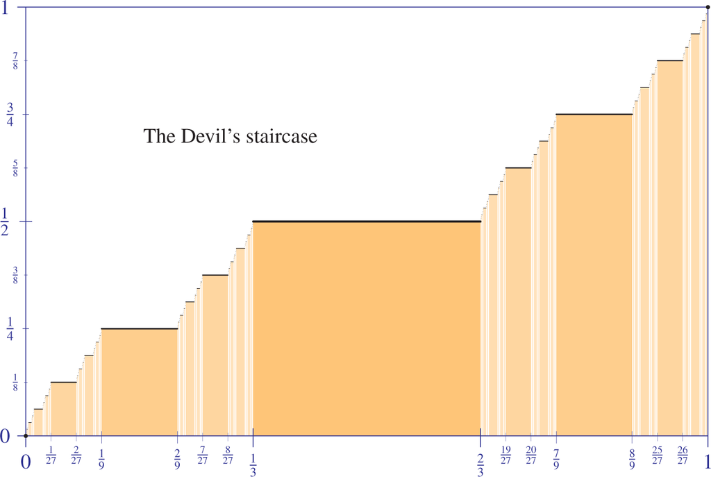

该函数由康托尔用他的中间三分之一集定义，即现称为*康托尔集*，作为微积分基本定理某种自然扩展的反例，因为它是一个从单位区间到自身的连续函数，且在几乎每个点都具有零导数，相对于勒贝格测度， 但在间隔期间，它会从0上升到1。这就是魔鬼从零升到一的过程，同时几乎始终保持静止。

This function was defined by Cantor using his middle-thirds set, now known as the *Cantor set*, and serves as a counterexample to what might have been a certain natural extension of the fundamental theorem of calculus, since it is a continuous function from the unit interval to itself, which has a zero derivative at almost every point with respect to the Lebesgue measure, yet it rises from 0 to 1 during the interval. This is how the Devil ascends from 0 to 1 while remaining almost always motionless.

### **填充空间曲线** **Space-filling curves**

接下来，考虑空间填充曲线的现象。*曲线*是从一维单位区间到空间（如平面）的连续函数，是一个连续函数*c*： [0， 1] → R<sup>2</sup>。我们可以很容易地绘制出许多这样的曲线并分析它们的数学性质。

Next, consider the phenomenon of space-filling curves. A *curve* is a continuous function from the one-dimensional unit interval into a space, such as the plane, a continuous function *c*: [0, 1] → ℝ<sup>2</sup>. We can easily draw many such curves and analyze their mathematical properties.

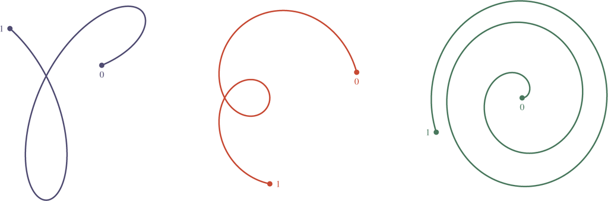

曲线实际上描述了沿特定路径前进的方式：在时间*t*时，位置*c*（*t*）。因此，曲线从*点c*（0）开始;它沿曲线移动，时间*t*的推进;并且它终止于*点c*（1）。弯道可以改变速度、交叉，甚至倒退在同一路径上，重新走原路线。因此，不应将曲线与其在平面上的图像相关联，而曲线则是追踪该路径的一种方式。

A curve in effect describes a way of traveling along a certain path: one is at position *c*(*t*) at time *t*. The curve therefore begins at the point *c*(0); it travels along the curve as time *t* progresses; and it terminates at the point *c*(1). Curves are allowed to change speed, cross themselves, and even to move backward on the same path, retracing their route. For this reason, one should not identify the curve with its image in the plane, but rather the curve is a way of tracing out that path.

由于那些容易绘制和掌握的熟悉曲线似乎表现出本质上的单维特征，令人震惊的是，存在*填充空间*曲线，即完全填满空间的曲线。皮亚诺提出了这样一条填充空间曲线，即从单位区间到单位正方形的连续函数，具有曲线在某个时间点访问正方形上的每个点的性质。让我们考虑希尔伯特空间填充曲线（此处所示），这是一个简化。

Since the familiar curves that are easily drawn and grasped seem to exhibit an essentially one-dimensional character, it was a shocking discovery that there are *space-filling curves*, which are curves that completely fill a space. Peano produced such a space-filling curve, a continuous function from the unit interval to the unit square, with the property that every point in the square is visited at some time by the curve. Let us consider Hilbert’s space-filling curve, shown here, which is a simplification.

希尔伯特曲线可以通过极限过程定义。一开始是一个粗略的近似，由三条线段组成的曲线，如下一页左上角的图;每个近似随后依次被更细致的近似替代，最终的希尔伯特曲线本身就是这些近似的极限，随着近似越来越细。该过程的前六个迭代如下所示。每个近似都是一条从左下角开始，然后绕行，最终在右下角结束的曲线。每条近似曲线由有限条线段组成，我们应设想这些线段以均匀速度穿越。需要证明的是，随着近似的精细，极限值收敛，从而定义极限曲线。

The Hilbert curve can be defined by a limit process. One starts with a crude approximation, a curve consisting of three line segments, as in the figure at the upper left of the next page; each approximation is then successively replaced by one with finer detail, and the final Hilbert curve itself is simply the limit of these approximations as they get finer and finer. The first six iterations of the process are shown here. Each approximation is a curve that starts at the lower left and then wriggles about, ultimately ending at the lower right. Each approximation curve consists of finitely many line segments, which we should imagine are traversed at uniform speed. What needs to be proved is that as the approximations get finer, the limiting values converge, thereby defining the limit curve.

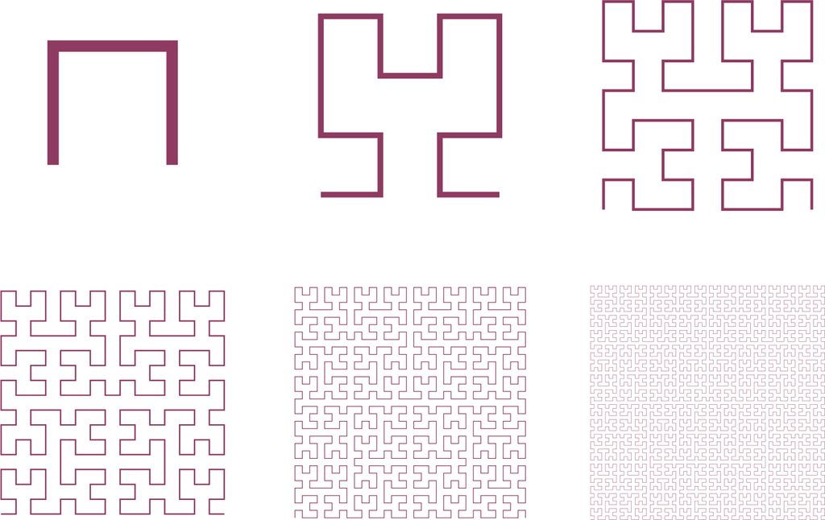

### **康威十三进制函数** **Conway base-13 function**

让我们再看看另一个例子，这可能会进一步拓展我们对函数概念的直觉。康威十三进*制函数C*（*x**）是通过*检查*x*的三进制（十三进制）表示并确定是否编码某个秘密数字——*x*的康威值来定义的。具体来说，我们用三进制符号表示*x*，使用通常的十位数字0*、...、*9，加上三个额外的数字⊕、⊖和⊙，分别在三进制系统中值为10、11和12。如果x的三十进制表示具有形如 的末段

Let us look at another such example, which might further stretch our intuitions about the function concept. The Conway base 13 function *C*(*x*) is defined for every real number *x* by inspecting the tridecimal (base 13) representation of *x* and determining whether it encodes a certain secret number, the Conway value of *x*. Specifically, we represent *x* in tridecimal notation, using the usual ten digits 0*, …*, 9, plus three extra numerals ⊕, ⊖ and ⊙, having values 10, 11 and 12, respectively, in the tridecimal system. If it should happen that the tridecimal representation of *x* has a final segment of the form

[figure not shown]

其中 *a*<sub>*i*</sub> 和 *b*<sub>*j*</sub> 仅使用数字 0 到 9，则康威值 *C*（*x*） 就是数字 *a*<sub>0</sub>*a 1*......*a* *k.b*<sub>0</sub>*b*<sub>1 b</sub><sub>2</sub>*b*<sub>3</sub>...，现在用十进制符号理解。如果*x*的三十进制表示具有形如

where the *a*<sub>*i*</sub> and *b*<sub>*j*</sub> use only the digits 0 through 9, then the Conway value *C*(*x*) is simply the number *a*<sub>0</sub>*a*<sub>1</sub>⋯*a*<sub>*k*</sub>*.b*<sub>0</sub>*b*<sub>1</sub>*b*<sub>2</sub>*b*<sub>3</sub>…, understood now in decimal notation. And if the tridecimal representation of *x* has a final segment of the form

[figure not shown]

where again the *a*<sub>*i*</sub> and *b*<sub>*j*</sub> use only the digits 0 through 9, then the Conway value *C*(*x*) is the number − *a*<sub>0</sub>*a*<sub>1</sub>⋯*a*<sub>*k*</sub>*.b*<sub>0</sub>*b*<sub>1</sub>*b*<sub>2</sub>*b*<sub>3</sub>…, in effect taking ⊕ or ⊖ as a sign indicator for *C*(*x*). Finally, if the tridecimal representation of *x* does not have a final segment of one of those forms, for example, if it uses the ⊕ numeral infinitely many times or if it does not use the ⊙ numeral at all, then we assign the default value *C*(*x*) = 0. Some examples may help illustrate the idea:

[figure not shown]

关键是我们可以很容易地从*x*的十进制三进制表示中读出*C*（*x*）的十进制值。左边是输入数*x*，采用十进制三进制表示;右边是编码后的康威值*C*（*x*），十进制形式，当无数字编码时默认值为0。注意，解码过程中忽略*了x*的十进制三进制点。

The point is that we can easily read off the decimal value of *C*(*x*) from the tridecimal representation of *x*. On the left, we have the input number *x*, given in tridecimal representation, and on the right is the encoded Conway value *C*(*x*), in decimal form, with a default value of 0 when no number is encoded. Note that we ignore the tridecimal point of *x* in the decoding process.

让我们更仔细地看看康威函数，发现其迷人的特点。关键是，每个实数*y*都是某个实数*x*的康威值，此外，你可以在指定x的三十进制表示的任意有限初始段后，将*y*编码到*x*的最后*一段中。*如果你想让*x*的十进制三进制表示以某种方式开始，可以这样做，然后根据*y*是正或负，在数字⊕或⊖后加上数字，然后列出*y*的小数位数字，完成x的*表示，并*用数字⊙表示*y的小数*点应在哪里。由此可得 *C*（*x*） = *y*。由于我们可以在编码*y*之前任意指定*x*的初始数字，因此实数中的每个区间，无论多么微小，都*有一个实数**x*，且C（*x*） = *y*。换句话说，康威函数被限制为任意微小区间，使得一个仍然存在于整个实数集合上的函数。

Let us look a little more closely at the Conway function to discover its fascinating features. The key thing to notice is that every real number *y* is the Conway value of some real number *x*, and furthermore, you can encode *y* into the final segment of *x* after having already specified an arbitrary finite initial segment of the tridecimal representation of *x*. If you want the tridecimal representation of *x* to start in a certain way, go ahead and do that, and then simply add the numeral ⊕ or ⊖ after this, depending on whether *y* is positive or negative, and then list off the decimal digits of *y* to complete the representation of *x*, using the numeral ⊙ to indicate where the decimal point of *y* should be. It follows that *C*(*x*) = *y*. Because we can specify the initial digits of *x* arbitrarily, before the encoding of *y*, it follows that every interval in the real numbers, no matter how tiny, will have a real number *x*, with *C*(*x*) = *y*. In other words, the restriction of the Conway function to any tiny interval results in a function that is still onto the entire set of real numbers.

因此，如果我们制作康威函数的图，它看起来会与其他更普通函数的图完全不同。这是我对该图表的暗示性表示尝试：

Consequently, if we were to make a graph of the Conway function, it would look totally unlike the graphs of other, more ordinary functions. Here is my suggestive attempt to represent the graph:

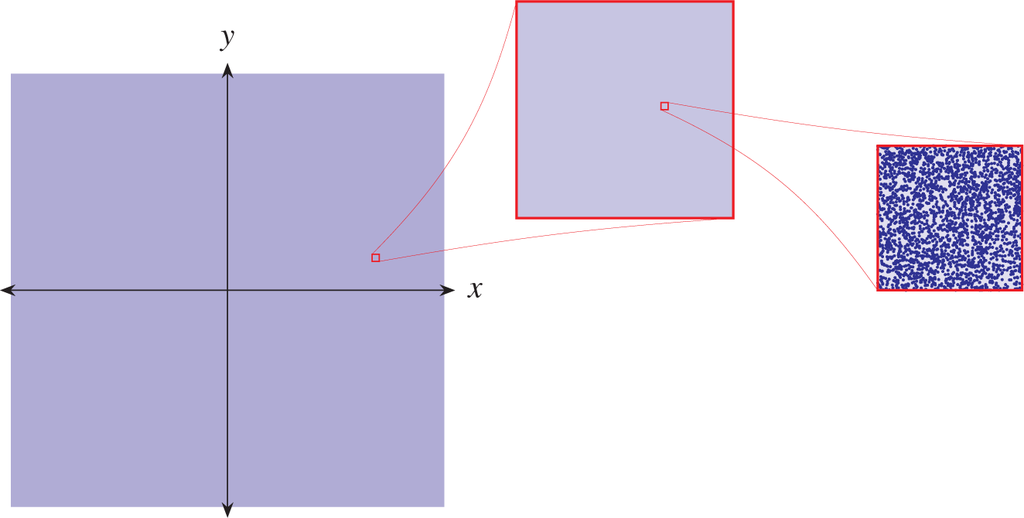

函数的值用蓝色绘制，但由于这些点在平面上非常密集，我们无法轻易区分单个点，图呈现为蓝色的质量块。当我在黑板上画图表时，我只是把粉笔横着铺，然后用灰尘填满黑板。

The values of the function are plotted in blue, you see, but since these dots appear so densely in the plane, we cannot easily distinguish the individual points, and the graph appears as a blue mass. When I draw the graph on a chalkboard, I simply lay the chalk sideways and fill the board with dust.

但康威函数确实是一个函数，每条垂直线都恰好有一个点，应将图想象为由单个点（*x， C*（*x*））组成。如果我们像图中所示放大图，或许能开始逐一辨别这些点。但实际上，应仅视该图为暗示，因为在有限倍率放大后，图当然会保持稠密，没有空白区域，因此放大图像中点之间的空隙并不准确。归根结底，我们似乎无法以完全令人满意的方式准确绘制该图表。

But the Conway function is indeed a function, with every vertical line having exactly one point, and one should imagine the graph as consisting of individual points (*x, C*(*x*)). If we were to zoom in on the graph, as suggested in the figure, we might hope to begin to discern these points individually. But actually, one should take the figure as merely suggestive, since after any finite amount of magnification, the graph would of course remain dense, with no empty regions at all, and so those empty spaces between the dots in the magnified image are not accurate. Ultimately, we cannot seem to draw the graph accurately in any fully satisfactory manner.

另一个微妙点是，默认值0在康威函数中出现得相当频繁，因为未能编码康威值的实数*x*具有完整的勒贝格测度。从这个精确意义上说，几乎每个实数在康威函数的默认情况下都是，因此康威函数几乎总是零。我们或许可以用更密集的蓝色调在*x*轴上来表示函数的这一方面，因为在勒贝格测度的意义下，函数大部分位于该轴上。与此同时，函数真正有趣的部分发生在测度为零的集合上，即编码康威值的实数*x*。

Another subtle point is that the default value of 0 actually occurs quite a lot in the Conway function, since the set of real numbers *x* that fail to encode a Conway value has full Lebesgue measure. In this precise sense, almost every real number is in the default case of the Conway function, and so the Conway function is almost always zero. We could perhaps have represented this aspect of the function in the graph with a somewhat denser hue of blue lying on the *x*-axis, since in the sense of the Lebesgue measure, most of the function lies on that axis. Meanwhile, the truly interesting part of the function occurs on a set of measure zero, the real numbers *x* that do encode a Conway value.

注意，尽管康威函数高度不连续，但仍满足中间值定理的结论：对于任意*a<b，f**（**a*）和*f*（*b*）之间的每个*y*都被*实现为f*（*c*），即*某个c在**a*和*b*之间。

Notice that the Conway function, though highly discontinuous, nevertheless satisfies the conclusion of the intermediate value theorem: for any *a < b*, every *y* between *f*(*a*) and *f*(*b*) is realized as *f*(*c*) for some *c* between *a* and *b*.

我们已经看到三个函数的例子，这些函数往往超出了传统对函数的理解。数学家最终得出了一个非常通用的函数概念，即放弃所有需求函数必须由某种公式定义;函数只是输入与输出之间某种关系：函数是指输入最多给出一个输出且始终相同的关系。

We have seen three examples of functions that tend to stretch the classical conception of what a function can be. Mathematicians ultimately landed with a very general function concept, abandoning all requirements functions must be defined by a formula of some kind; rather, a function is simply a certain kind of relation between input and output: a function is any relation for which an input gives at most one output, and always the same output.

在某些数学学科中，函数概念进一步发展，某种意义上形成了角。也就是说，对于许多数学家，尤其是使用范畴论的学科来说，函数*f*不仅仅是通过指定其定义域*X*以及*定义域中*每个点*的*函数值f（*x*）来*确定∈X*。相反，还必须指定函数*的余域*，即函数 *f*： *X* → *Y* 的目标值空间 *Y*。陪域与函数值域不同，因为并非每个*y*∈*Y*都必须*作为f（**x*）的值实现。基于该函数概念，实数上的平方函数 *s*（*x*） = *x*<sup>2</sup> 可以视为从 R 到 R 的函数，或从 R 到 [0， ∞） 的函数，关键是它们被视为两个不同的函数，它们恰好在每个点 *x* 具有相同的定义域 R 和相同的值 *x*<sup>2</sup>在该领域;但由于陪域不同，它们是不同的函数。这种对陪域的关注是范论态射概念的核心，例如，对于函数 *f°g* 的复合，人们希望 *g* 的陪域与 *f* 的定义域对齐。

In some mathematical subjects, the function concept has evolved further, growing horns in a sense. Namely, for many mathematicians, particularly in those subjects using category theory, a function *f* is not determined merely by specifying its domain *X*, and the function values *f*(*x*) for each point in that domain *x* ∈ *X*. Rather, one must also specify what is called the *codomain* of the function, the space *Y* of intended target values for the function *f*: *X* → *Y*. The codomain is not the same as the range of the function, because not every *y* ∈ *Y* needs to be realized as a value *f*(*x*). On this concept of the function, the squaring function *s*(*x*) = *x*<sup>2</sup> on the real numbers can be considered as a function from ℝ to ℝ or as a function from ℝ to [0, ∞), and the point would be that these would count as two different functions, which happen to have the same domain ℝ and the same value *x*<sup>2</sup> at every point *x* in that domain; but because the codomains differ, they are different functions. Such a concern with the codomain is central to the category-theoretic conception of morphisms, where with the composition of functions *f°g*, for example, one wants the codomain of *g* to align with the domain of *f*.

## **2.7 无穷小体再访** **2.7 Infinitesimals revisited**

关于本章的最后一个主题，让我们回到无穷小。尽管基础存在问题和伯克利的批评，但应牢记无穷小概念实际上极具成效，并带来了许多坚实的数学洞见，包括微积分的所有基础性成果。如今的数学家通常通过考虑函数或系统输入无穷小变化的影响来处理微积分和微分方程问题。

For the final theme of this chapter, let us return to the infinitesimals. Despite the problematic foundations and Berkeley’s criticisms, it will be good to keep in mind that the infinitesimal conception was actually extremely fruitful and led to many robust mathematical insights, including all the foundational results of calculus. Mathematicians today routinely approach problems in calculus and differential equations essentially by considering the effects of infinitesimal changes in the input to a function or system.

例如，为了计算旋转 *y* = *f*（*x*） 的立体绕 *x* 轴的体积，通常会想象将体积切成无穷小的薄盘。*x*处的圆盘半径为*f*（*x*），厚度为无穷小*dx*（因此体积*πf*（*x*）<sup>²</sup>*dx*），因此a与*b**之间的总*体积为

For example, to compute the volume of a solid of revolution *y* = *f*(*x*) about the *x*-axis, it is routine to imagine slicing the volume into infinitesimally thin disks. The disk at *x* has radius *f*(*x*) and infinitesimal thickness *dx* (hence volume *πf*(*x*)<sup>2</sup> *dx*), and so the total volume between *a* and *b*, therefore, is

[figure not shown]

另一个例子是当试图计算由光滑函数*y* = *f*（*x*）描绘的曲线长度时。通常可以想象将其切成无穷小的部分，观察到每个小块都是三角形的斜边*ds*，且腿为无穷小的*dx*和*dy*。因此，通过毕达哥拉斯定理的一个无穷小实例，我们看到 ，其中可以“因式分解”*dx*，得到

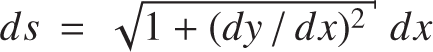

，因此曲线的总长度为

Another example arises when one seeks to compute the length of the curve traced by a smooth function *y* = *f*(*x*). One typically imagines cutting it into infinitesimal pieces and observing that each tiny piece is the hypotenuse *ds* of a triangle with infinitesimal legs *dx* and *dy*. So by an infinitesimal instance of the Pythagorean theorem, we see , from which one “factors out” *dx*, obtaining

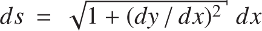

, and therefore the total length of the curve is given by

[figure not shown]

因此，人们不应对早期微积分的发展抱有夸张的理解，认为那不过是用已逝量的幽灵操作的笨拙胡言乱语。相反，那是一个数学巨大进步和持久力量深刻洞见的时代。也许这种情况让哲学家在思考基础问题对数学进步的重要性时有所思考——必须有坚实的基础才能推进数学知识？显然不是。尽管如此，利用ε-δ方法解决了这些问题基础，确实使得更为复杂的数学分析成为可能，带来了进一步的巨大数学发展和进步。终于修复了基础，这无疑是很有价值的。

Thus, one should not have a cartoon understanding of developments in early calculus, imagining that it was all bumbling nonsense working with the ghosts of departed quantities. On the contrary, it was a time of enormous mathematical progress and deep insights of enduring strength. Perhaps this situation gives a philosopher pause when contemplating the significance of foundational issues for mathematical progress—must one have sound foundations in order to advance mathematical knowledge? Apparently not. Nevertheless, the resolution of the problematic foundations with epsilon-delta methods did enable a far more sophisticated mathematical analysis, leading to further huge mathematical developments and progress. It was definitely valuable to have finally fixed the foundations.

### **非标准分析与超实数** **Nonstandard analysis and the hyperreal numbers**

1961年，亚伯拉罕·罗宾逊提出他的非标准分析理论，这一定是一个令人震惊的发展。该理论源自数理逻辑的思想，基于现称为超实数<sup>R*</sup>的概念，提供了一种严谨的无穷小处理方法，与早期微积分工作有许多相似之处。我把这一发展看作是一种玩笑，数学现实对数学的历史和哲学都玩了个玩笑。

What an astounding development it must have been in 1961, when Abraham Robinson introduced his theory of nonstandard analysis. This theory, arising from ideas in mathematical logic and based on what are now called the hyperreal numbers ℝ*, provides a rigorous method of handling infinitesimals, having many parallels to the early work in calculus. I look upon this development as a kind of joke that mathematical reality has played on both the history and philosophy of mathematics.

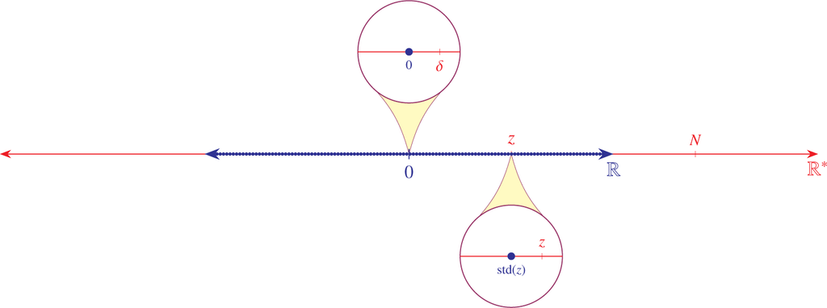

其运作方式如下。超实数系统 R* 是一个有序域，扩展了实数，但包含新的无限和无穷小数。图中，实数线——即整个实数线——用蓝色表示。因此，红色标出的超实数线严格超出实数线的端点。起初可能难以想象，但这正是超实数构造所产生的结果。例如，*图中所示*的超实数N大于所有实数，而*δ*数是正数，严格大于0但小于所有正实数。可以想象 *δ* = 1*/N*，因为无限数的倒易函数是无穷小的，反之亦然。

The way it works is as follows. The hyperreal number system ℝ* is an ordered field extending the real numbers, but having new infinite and infinitesimal numbers. In the figure, the real number line—meaning all of it, the entire real number line—is indicated in blue. The hyperreal number line, indicated in red, thus extends strictly beyond the end of the real number line. It may be difficult to imagine at first, but indeed this is what the construction of the hyperreal numbers produces. The hyperreal number *N* indicated in the figure, for example, is larger than every real number, and the number *δ* is positive, being strictly larger than 0 but smaller than every positive real number. One could imagine that *δ* = 1*/N*, since the reciprocal of an infinite number will be infinitesimal and conversely.

每个实数都被这些超实数的邻域包围，且其极小，因此如果放大超实数中的实数，最终会发现一个窗口仅包含该实数及其无限接近的超实数。每个被标准实数界定的超实*数 z* 都极其接近唯一的标准实数，称为 *z* 的标准部分，记作 std（*z*），如图所示。

Every real number is surrounded by a neighborhood of those hyperreal numbers infinitesimally close to it, and so if one were to zoom in on a real number in the hyperreal numbers, one would ultimately find a window containing only that real number and the hyperreal numbers infinitely close to it. Every hyperreal *z* that is bounded by standard real numbers is infinitesimally close to a unique standard real number, called the standard part of *z* and denoted as std(*z*), as indicated in the figure.

超实数在非标准分析中具有吸引力的部分原因是它们还有一个显著的特性：任何形式分析语言中对实数R成立的陈述，对超实数R*也同样<sup>成立。</sup>*转移原理*断言，每个实数*a*和实数上的函数*f*在超实数中都有非标准对应物*a**和*f**，因此在实数R中关于*a*和*f*的任何断言*φ*（*a， f*）也同样适用于对应的对应物*φ*（*a***， f）**）在超实数R*中。因此，实数有一个初等嵌入↦ *a**，嵌入到超实数 R ≾ R* 中。

Part of what makes the hyperreal numbers attractive for nonstandard analysis is their further remarkable property that any statement in the formal language of analysis that is true for the real numbers ℝ is also true for the hyperreal numbers ℝ*. The *transfer principle* asserts that every real number *a* and function *f* on the real numbers have nonstandard counterparts *a** and *f** in the hyperreal numbers, such that any assertion *φ*(*a, f*) about *a* and *f* that is true in the real numbers ℝ is also true of the counterparts *φ*(*a***, f**) in the hyperreal numbers ℝ*. Thus, the real numbers have an elementary embedding *a* ↦ *a** into the hyperreal numbers ℝ ≾ ℝ*.

由于转移原理，我们确切知道超实数允许的算术和代数运算类型——它们与实数系统中允许的操作相同。由于转移原理，我们将有无限整数、无限素数、无限次幂等概念，并且可以将实数区间划分为无限多个长度相等无穷小的子区间。这些正是微积分中想要做的事情，而非标准分析为其提供了严谨的基础。

Because of the transfer principle, we know exactly what kinds of arithmetic and algebraic operations are allowed in the hyperreal numbers—they are the same as those allowed in the real number system. Because of the transfer principle, we will have concepts of infinite integers, infinite prime numbers, infinite powers of 2, and so on, and we can divide an interval in the real numbers into infinitely many subintervals of equal infinitesimal length. These are exactly the kinds of things that one wants to do in calculus, and nonstandard analysis provides a rigorous foundation for it.

### **非标准分析中的微积分** **Calculus in nonstandard analysis**

让我们通过解释导数在非标准分析中如何处理来说明这一点。通过使用无穷小超实数计算函数*f*的导数，无需极限过程或ε-δ参数。例如，为了求得 *f*（*x*） = *x*<sup>2</sup> 的导数，设 *δ* 是一个正无穷小超实数。我们计算从*x*到*x*+*δ*区间的变化率商，

Let us illustrate this by explaining how the derivative is treated in nonstandard analysis. One computes the derivative of a function *f* by using an infinitesimal hyperreal number, without any limit process or epsilon-delta arguments. To find the derivative of *f*(*x*) = *x*<sup>2</sup>, for example, let *δ* be a positive infinitesimal hyperreal. We compute the rate-of-change quotient over the interval from *x* to *x* + *δ*,

[figure not shown]

采用之前执行的相同代数步骤，然后仅取结果的标准部分，得到

with the same algebraic steps as performed earlier, and then simply take the standard part of the result, arriving at

[figure not shown]

因此，*x*<sup>2</sup>的导数是2*x*。标准部分运算的使用实际上形式化了如何正确处理无穷小——它准确解释了幽灵如何离开！因此，非标准分析使得对无穷小函数的完全严谨使用成为可能。

Thus, the derivative of *x*<sup>2</sup> is 2*x*. The use of the standard-part operation in effect formalizes how one can correctly treat infinitesimals—it explains exactly how the ghosts depart! Thus, nonstandard analysis enables a fully rigorous use of infinitesimals.

非标准分析现已发展为成熟的理论，提供了与经典理论平行的替代概念。在从事非标准分析工作时，人们可能会自然采纳几种哲学观点，我现在想解释一下。不过，其中一些内容是技术性的，因此不熟悉超能力的读者可能会直接跳过。

Nonstandard analysis has now grown into a mature theory, providing an alternative conception parallel to the classical theory. There are several philosophical perspectives one might naturally adopt when undertaking work in nonstandard analysis, which I would like now to explain. Some of this material is technical, however, and so readers not familiar with ultrapowers, for example, might simply skip over it.

### **经典模型构造视角** **Classical model-construction perspective**

在这种方法中，人们将非标准宇宙视为显式构造的结果，比如超幂构造。在最基本的情况下，有一个标准实数域结构⟨R，+，·，0,1，Z⟩，然后你对自然数（或如果需要，也可以在其他集合上）的固定非主*超滤U*进行超幂构造。超幂结构 R* = R<sup>N</sup>*/U* 被视为超实数的概念，即一个有序的非阿基里德域，因此其元素为无穷小。

In this approach, one thinks of the nonstandard universe as the result of an explicit construction, such as an ultrapower construction. In the most basic instance, one has the standard real number field structure ⟨ℝ,+,·,0,1,ℤ⟩, and you perform the ultrapower construction with respect to a fixed nonprincipal ultrafilter *U* on the natural numbers (or on some other set if this were desirable). The ultrapower structure ℝ* = ℝ<sup>ℕ</sup>*/U* is then taken as a conception of the hyperreal numbers, an ordered non-Archimedean field, which therefore has infinitesimal elements.

然而，随着时间推移，人们会希望在超功率前模型中拥有更多结构，以便表达更多观点，而这些想法都会有非标准的对应。每个实数都有常数，Z 或 R 的每个子集都有谓词，实数上的每个函数都有一个函数符号，依此类推。通过这种方式，可以得到每个实数*z*的非标准类比z*、非标准整数的集合Z*，以及对实数上每个函数*f**的非*标准类比f*，依此类推。不久之后，人们还需要*P（*R）及更高迭代次数的非标准类比。最终，人们意识到，不如取整个集合论宇宙的超幂 *V*→*V* <sup>*ω*</sup>*/U*，这相当于对每个序数*α*进行非标准分析，包括二阶逻辑、三阶逻辑，甚至*α*阶。然后在非标准领域*V**中得到标准宇宙*V*的复制品，通过超幂构造本身进行分析和理解。

In time, however, one is led to want more structure in the pre-ultrapower model, so as to be able to express more ideas, which will each have nonstandard counterparts. One will have constants for every real number, a predicate for the integers ℤ, or indeed for every subset of ℝ, and a function symbol for every function on the real numbers, and so on. In this way, one gets the nonstandard analogue *z** of every real number *z*, the set of nonstandard integers ℤ*, and nonstandard analogues *f** for every function *f* on the real numbers, and so on. Before long, one also wants nonstandard analogues of the power set *P*(ℝ) and higher iterates. In the end, what one realizes is that one might as well take the ultrapower of the entire set-theoretic universe *V*→ *V* <sup>*ω*</sup>*/U*, which amounts to doing nonstandard analysis with second-order logic, third-order, and indeed *α*-order for every ordinal *α*. One then has the copy of the standard universe *V* inside the nonstandard realm *V**, which one analyzes and understands by means of the ultrapower construction itself.

一些非标准分析的应用要求不仅取单一超幂，还要求沿线性阶梯迭代超幂构造。这种超幂结构导致了许多非标准层面，这有时是有用的。最终，随着添加更多构造方法，这就等于将所有模型理论作为工具箱。人们会希望采用高级饱和性质、嵌入、标准系统等。有一个成熟的算术模型理论，采用了相当先进的方法。为了给出饱和的样本推论，每个无限图无论多大，都作为非标准有限图的诱导子图出现，该图在任何足够饱和的非标准分析模型中。这有时可以让你用无限图进行有限结构，但代价是向非标准上下文移动。

Some applications of nonstandard analysis have required one to take not just a single ultrapower, but an iterated ultrapower construction along a linear order. Such an ultrapower construction gives rise to many levels of nonstandardness, and this is sometimes useful. Ultimately, as one adds additional construction methods, this amounts just to adopting all model theory as one’s toolkit. One will want to employ advanced saturation properties, or embeddings, or the standard system, and so on. There is a well developed theory of models of arithmetic that uses quite advanced methods. To give a sample consequence of saturation, every infinite graph, no matter how large, arises as an induced subgraph of a nonstandard-finite graph in every sufficiently saturated model of nonstandard analysis. This sometimes can allow you to undertake finitary constructions with infinite graphs, with the cost being a move to the nonstandard context.

### **公理化方法** **Axiomatic approach**

然而，大多数非标准分析的应用并不依赖于超冪或迭代超冪构造的细节，因此通常认为有必要分离出使非标准论证成功的一般原则。因此，人们写下情境的公理。在基本情况下，有标准结构 R，依此类推，可能对每个实数（以及高阶情况下的所有子集和函数）设常数，映射到非标准结构 R*，使得每个实数 *a* 都有其非标准版本 *a**，实数上的每个函数 *f* 都有其非标准版本 *f**.通常，主要公理包括转移原则，该原则断言，任何用原始结构语言表达的性质，在标准宇宙中恰好成立，当该性质在非标准领域中这些对象的非标准类比中成立时。转移原理正好是映射 *a* ↦ *a** 从标准对象到其非标准对应物的元素性。通常还需要一个饱*和原理*，表达任何足够可实现的类型在非标准模型中实际上都已实现，这只是公理化了超幂的饱和性质。有时人们希望获得比自然数超幂更高的饱和度，但仍然可以通过更大的超幂或其他模型理论方法实现。

Most applications of nonstandard analysis, however, do not rely on the details of the ultrapower or iterated ultrapower constructions, and so it is often thought worthwhile to isolate the general principles that make the nonstandard arguments succeed. Thus, one writes down the axioms of the situation. In the basic case, one has the standard structure ℝ, and so on, perhaps with constants for every real number (and for all subsets and functions in the higher-order cases), with a map to the nonstandard structure ℝ*, so that every real number *a* has its nonstandard version *a** and every function *f* on the real numbers has its nonstandard version *f**. Typically, the main axioms would include the transfer principle, which asserts that any property expressible in the language of the original structure holds in the standard universe exactly when it holds of the nonstandard analogues of those objects in the nonstandard realm. The transfer principle amounts precisely to the elementarity of the map *a* ↦ *a** from standard objects to their nonstandard analogues. One often also wants a *saturation principle*, expressing that any sufficiently realizable type is actually realized in the nonstandard model, and this just axiomatizes the saturation properties of the ultrapower. Sometimes one wants more saturation than one would get from an ultrapower on the natural numbers, but one can still achieve this by larger ultrapowers or other model-theoretic methods.

本质上，同样的公理化方法适用于高阶情况，即每个集合论对象都有非标准版本，以及一个映射 *V*→*V* *，结构任意阶非标准。同样，也可以公理化想要在迭代超幂情形中使用的特征，标准程度不同。

Essentially the same axiomatic approach works with the higher-order case, where one has a nonstandard version of every set-theoretic object, and a map *V*→ *V* *, with nonstandard structures of any order. And similarly, one can axiomatize the features that one wants to use in the iterated ultrapower case, with various levels of standardness.

### **“那个”超真实数字？** **“The” hyperreal numbers?**

与大多数同时拥有构造和公理框架的数学情境一样，通常认为尽可能从公理中进行论证，而非依赖构造细节。而且我见过的大多数非标准分析应用，都可以只用通常的非标准性公理来完成。然而，公理化方法对非标准分析的一个主要缺点是公理化并非绝对化。不存在满足超实公理的唯一数学结构，也不存在“超实数”在同构范围内的结构。相反，我们有许多超实数的候选结构，这些数具有不同基数;其中一些相互扩展，且所有公理都满足这些公理，但并非全部同构。

As with most mathematical situations where one has both a construction and an axiomatic framework, it is usually thought better to argue from the axioms, when possible, than to use details of the construction. And most applications of nonstandard analysis that I have seen can be undertaken using only the usual nonstandardness axioms. A major drawback of the axiomatic approach to nonstandard analysis, however, is that the axiomatization is not categorical. There is no unique mathematical structure fulfilling the hyperreal axioms, and no structure that is “the” hyperreal numbers up to isomorphism. Rather, we have many candidate structures for the hyperreal numbers, of various cardinalities; some of them extend one another, and all of them satisfy the axioms, but they are not all isomorphic.

因此，尽管这种用法很常见，但从结构主义角度来看，称呼“那些”超实数似乎是不准确且最终没有意义的。这种情况与自然数、整数、实数和复数完全不同，后者确实存在范式刻画。诚然，结构主义者即使在这些情况下也面临使用单一项的挑战（我们在第一章讨论过），但对于超实数来说，情况更为糟糕。即使我们有权使用奇异项来表示自然数和实数，并可能带有某种结构主义的解释来解释其含义，但这些结构主义解释在超实数中将完全失效，因为公理中没有唯一结构。我们似乎没有权从任何有力的意义上单独引用超实数。

For this reason, and despite the common usage that one frequently sees, it seems incorrect, and ultimately not meaningful, to refer to “the” hyperreal numbers, even from a structuralist perspective. The situation is totally unlike that of the natural numbers, the integers, the real numbers, and the complex numbers, where we do have categorical characterizations. To be sure, the structuralist faces challenges with the use of singular terms even in those cases (challenges we discussed in chapter 1), but the situation is far worse with the hyperreal numbers. Even if we are entitled to use singular terms for the natural numbers and the real numbers, with perhaps some kind of structuralist explanation as to what this means, nevertheless those structuralist explanations will fail completely with the hyperreal numbers, simply because there is no unique structure that the axioms identify. We just do not seem entitled, in any robust sense, to make a singular reference to the hyperreal numbers.

然而，文献中确实大量提及“超真实数字”。我解释这没有造成根本性问题的原因是，对于非标准分析的目的，即通过非标准实数在微积分中建立实数的真理，各种超实结构之间的非同构差异恰好并不相关。所有这些结构都是具有转移原理的非阿基米德有序域，恰好仅凭这些性质就足以应用于这些场的应用。从这个意义上说，就像固定了一个特定的非标准域 R*——对于所考虑的应用来说，具体是哪个场并不重要——然后对“超实数”的引用仅仅指代那个被固定的特定 R*。这就像数学家们在实现斯图尔特·夏皮罗伪装的束缚量词，但没有得出分类性结果。

And yet, one does find abundant references to “the” hyperreal numbers in the literature. My explanation for why this has not caused a fundamental problem is that for the purposes of nonstandard analysis, that is, for the goal of establishing truths in calculus about the real numbers by means of the nonstandard real numbers, the nonisomorphic differences between the various hyperreal structures simply happen not to be relevant. All these structures are non-Archimedean ordered fields with the transfer principle, and it happens that these properties alone suffice for the applications of these fields that are undertaken. In this sense, it is as though one fixes a particular nonstandard field ℝ*—and for the applications considered, it does not matter much which one—and then reference to “the” hyperreal numbers simply refer to that particular ℝ* that has been fixed. It is as though the mathematicians are implementing Stewart Shapiro’s disguised bound quantifiers, but without a categoricity result.

我想知道这种缺乏分类性是否能解释一些数学家对研究非标准分析的犹豫;它阻止人们对超实数采取直接的结构主义态度，并倾向于将人们推回模型论方法，后者更准确地传达了情境的复杂性。

I wonder whether this lack of categoricity may explain the hesitancy of some mathematicians to study nonstandard analysis; it prevents one from adopting a straightforward structuralist attitude toward the hyperreal numbers, and it tends to push one back to the model-theoretic approach, which more accurately conveys the complexity of the situation.

与此同时，我们确实得到了超现实数的范畴性结果，它们构成了一个非标准有序的适当类大小域，在模型论意义上是饱和的——即每个集合大小的割都被填满。在标准的二阶集合论中，如带有全局选择原理（宇宙的类良序）的哥德尔-伯奈斯集合论或凯利-莫尔斯集合论，可以证明所有此类有序域都是同构的。这意味着“超实数”可以合理地赋予其意义，即将其视为指超实数，但代价是处理一个适当的类结构。

Meanwhile, we do have a categoricity result for the surreal numbers, which form a nonstandard ordered field of proper class size, one that is saturated in the model-theoretic sense—as in, every set-sized cut is filled. In the standard second-order set theories such as Gödel-Bernays set theory with the principle of global choice (a class well-ordering of the universe) or Kelley-Morse set theory, one can prove that all such ordered fields are isomorphic. This is a sense in which “the hyperreal numbers” might reasonably be given meaning by taking it to refer to the surreal numbers, at the cost of dealing with a proper class structure.

### **激进非标准性视角** **Radical nonstandardness perspective**

这种对非标准分析的观点涉及数学本体论的巨大基础性变革。也就是说，从这个角度看，与其将标准结构视为非标准世界中有类比，不如将非标准世界视为“真实”世界，并以“标准性”谓词划分其部分部分。在这种方法下，可以将实数视为包含无限实数和无穷小实数，并且可以判断两个有限实数何时以及是否具有相同的标准部分，依此类推。从这个角度来看，我们把“实数”想象成从另一个角度看的非标准实数，然后我们有一个谓词，即另一种方法中星图的射程。所以有些实数是标准的，有些函数是标准的，依此类推。

This perspective on nonstandard analysis involves an enormous foundational change in one’s mathematical ontology. Namely, from this perspective, rather than thinking of the standard structures as having analogues inside a nonstandard world, one instead thinks of the nonstandard world as the “real” world, with a “standardness” predicate picking out parts of it. On this approach, one views the real numbers as including both infinite and infinitesimal real numbers, and one can say when and whether two finite real numbers have the same standard part, and so on. With this perspective, we think of the “real” real numbers as what from the other perspective would be the nonstandard real numbers, and then we have a predicate on that, which amounts to the range of the star map in the other approach. So some real numbers are standard, some functions are standard, and so on.

例如，在涉及有限组合学的论证中，持这种观点的人可能会随意说：“设*N*为无限整数”或“考虑一个无穷小有理数”。（我纽约的一位同事有时也会这样说话。）这种说法对不习惯这种视角的人来说可能显得陌生，但对采纳这种观点的人来说，是有益的。这些从业者深深饮用了非标准葡萄酒;他们已经完全进入了非标准领域——一个新的存在层面。

In an argument involving finite combinatorics, for example, someone with this perspective might casually say, “Let *N* be an infinite integer” or “Consider an infinitesimal rational number.” (One of my New York colleagues sometimes talks this way.) That way of speaking may seem alien for someone not used to this perspective, but for those that adopt it, it is productive. These practitioners have drunk deeply of the nonstandardness wine; they have moved wholly into the nonstandard realm—a new plane of existence.

这一理念的极端版本采用了多种标准性和非标准性层次，并扩展到所有秩序。Karel Hrbacek（1979,2009）对非标准集合论提出了这样一个成熟的理论，具有无限深层次的标准性层次。根据这个观点，没有完全“标准”的领域。在赫尔巴切克的体系中，人们不是从一个标准宇宙开始，然后向上推到非标准宇宙，而是从整个宇宙（本质上是非标准的）开始，逐步向下延伸到更深层次的标准性。他证明了每个ZFC模型都是他所考虑的非标准集合论模型中的标准宇宙。

Extreme versions of this idea adopt many levels of standardness and nonstandardness, extended to all orders. Karel Hrbacek (1979, 2009) has a well developed theory like this for nonstandard set theory, with an infinitely deep hierarchy of levels of standardness. There is no fully “standard” realm according to this perspective. In Hrbacek’s system, one does not start with a standard universe and go up to the nonstandard universe, but rather, one starts with the full universe (which is fundamentally nonstandard) and goes down to deeper and deeper levels of standardness. Every model of ZFC, he proved, is the standard universe inside another model of the nonstandard set theories he considers.

### **非标准视角与经典视角之间的转换** **Translating between nonstandard and classical perspectives**

归根结底，我认为我所描述的三种视角中的选择是个人喜好问题，任何能用其中一种观点提出的论点，在其他观点中都有类似的。从这个意义上说，数学上，这两种观点之间的利害关系似乎并不大。然而，正如我在第1.16节所论述的，不同的哲学观点会引领人们走向不同的数学问题和不同的数学研究。

Ultimately, my view is that the choice between the three perspectives I have described is a matter of taste, and any argument that can be formulated in one of the perspectives has analogues in the others. In this sense, there seems to be little at stake, mathematically, between the perspectives. And yet, as I argued in section 1.16, divergent philosophical views can lead one toward different mathematical questions and different mathematical research efforts.

通常不仅可以将论证在非标准分析的视角之间转换，也可以在非标准领域与经典ε-δ方法之间进行转换。陶明（2007）将非标准分析方法描述为管理*ε*论证提供了一种顺畅的方法。有人可能会说，“这个*δ*比用那个*ε*定义的还要小。”这是一种方便的误差估计方式。陶也指出，超滤波器可以作为管理估计的简单方法来进行论证;如果分别知道对于每个对象*A*、*B*和*C*，都存在大量（相对于超滤波器）相关的见证者，那么也可以发现大量见证者同时与这三个对象共事。

One can usually translate arguments not only amongst the perspectives of nonstandard analysis, but also between the nonstandard realm and the classical epsilon-delta methods. Terence Tao (2007) has described the methods of nonstandard analysis as providing a smooth way to manage one’s *ε* arguments. One might say, “This *δ* is smaller than anything defined using that *ε*.” It is a convenient way to undertake error estimation. Tao similarly points out how ultrafilters can be utilized in an argument as a simple way to manage one’s estimates; if one knows separately that for each of the objects *a*, *b*, and *c*, there is a large measure (with respect to the ultrafilter) of associated witnesses, then one can also find a large measure of witnesses working with all three of them.

然而，对一些真正的分析师来说，正是对超滤波器或其他数学逻辑概念的不熟悉，阻碍了他们欣赏这些非标准方法。从这个意义上说，偏好或反对非标准分析似乎部分源于文化背景。

For some real analysts, however, it is precisely the lack of familiarity with ultrafilters or other concepts from mathematical logic that prevents them from appreciating the nonstandard methods. In this sense, the preference for or against nonstandard analysis appears to be in part a matter of cultural upbringing.

H. Jerome Keisler 编写了一本微积分入门教材《*初级微积分：一种无穷小方法*》（1976），面向大学一年级学生，基于非标准分析的思想，但其他方面实现了该类型微积分教材的效果。这是一本典型的厚卷，包含定积分、导数、优化问题和链式定律等的示范例，所有内容都配有适合本科微积分学生的练习题。表面上看起来和其他类似微积分课上常用的标准微积分教材。但如果你翻看凯斯勒的书，在封面上除了常见的三角恒等式和积分公式外，你会发现一份关于无限和无穷小数相互作用、转移原理、标准部分代数等公理列表。它全部基于非标准分析，根本上与其他微积分教材不同。该书曾一度被威斯康星大学麦迪逊分校的微积分课程成功使用。

H. Jerome Keisler wrote an introductory calculus textbook, *Elementary Calculus: An Infinitesimal Approach* (1976), intended for first-year university students, based on the ideas of nonstandard analysis, but otherwise achieving what this genre of calculus textbook achieves. It is a typical thick volume, with worked examples on definite integrals and derivatives and optimization problems and the chain rule, and so on, all with suitable exercises for an undergraduate calculus student. It looks superficially like any of the other standard calculus textbooks used in such a calculus class. But if you peer inside Keisler’s book, in the front cover alongside the usual trigonometric identities and integral formulas you will find a list of axioms concerning the interaction of infinite and infinitesimal numbers, the transfer principle, the algebra of standard parts, and so on. It is all based on nonstandard analysis and is fundamentally unlike the other calculus textbooks. The book was used for a time, successfully, in the calculus classes at the University of Wisconsin in Madison.

还有一个有趣的伴随故事，涉及书评的政治。《*美国数学学会公报*》主编保罗·哈尔莫斯请求埃雷特·毕晓普对凯斯勒的书进行书评，几十年前毕晓普曾是凯斯勒的学生，但毕晓普以其数学哲学中的建构主义观点闻名——这些观点与非标准分析的主要工具极为不兼容。该评论如预期般持负面态度，并受到广泛批评，尤其是后来同一期刊的马丁·戴维斯（1977年）。对该书评，凯斯勒（1977）评论道（另见戴维斯和豪斯纳，1978），选择毕晓普来评论这本书就像“让一个戒酒者品尝葡萄酒”。

There is an interesting companion tale to relate concerning the politics of book reviews. Paul Halmos, editor of the *Bulletin of the American Mathematical Society*, requested a review of Keisler’s book from Errett Bishop, who decades earlier had been his student but who was also prominently known for his constructivist views in the philosophy of mathematics—views that are deeply incompatible with the main tools of nonstandard analysis. The review was predictably negative, and it was widely criticized, notably by Martin Davis (1977), later in the same journal. In response to the review, Keisler (1977) remarked (see also Davis and Hausner, 1978), that the choice of Bishop to review the book was like “asking a teetotaler to sample wine.”

### **对非标准分析的批评** **Criticism of nonstandard analysis**

艾伦·康尼斯对非标准分析提出了根本性批评，他在一次采访中表示

Alan Connes mounted a fundamental criticism of nonstandard analysis, remarking in an interview

那时我一直在做非标准分析，但过了一段时间我发现了理论中的一个陷阱......关键是，一旦你有一个非标准的数字，你就会得到一个不可测量的集合。在肖凯的圈子里，我们深入研究波兰学派，知道你能说出的每一个集合都是可以测量的;所以用非标准分析来做物理似乎注定失败。戈德斯坦与斯坎达利斯（2007年）

At that time, I had been working on nonstandard analysis, but after a while I had found a catch in the theory…. The point is that as soon as you have a nonstandard number, you get a nonmeasurable set. And in Choquet’s circle, having well studied the Polish school, we knew that every set you can name is measurable; so it seemed utterly doomed to failure to try to use nonstandard analysis to do physics. Goldstein and Skandalis (2007)

他是什么意思？他指的是什么？让我解释一下。

What does he mean? To what is he referring? Let me explain.

“一旦你有一个非标准数字，你就会得到一个不可测量的集合。”

“as soon as you have a nonstandard number, you get a nonmeasurable set.”

每个非标准*自然数N*都产生了自然数集合的某种大性概念：集合X在*N⊂X**中，*恰∈好*是大。 换句话说，如果一个集合*X*表达了非标准数*N*所具有的性质，则称X为大集合。没有标准有限集是大集，而且任两个大集的交集都很大，且大集的任一超集都很大。因此，所有这些大集合 *X* 的集合 U 构成了自然数上的非主超滤子。我们可以将大集合与康托尔空间2<sup>N</sup>的元素相提并论，该空间携带自然概率测度——掷硬币测度，因此U是康托尔空间的一个子集。

Every nonstandard natural number *N* gives rise to a certain notion of largeness for sets of natural numbers: a set *X* ⊂ ℕ is large exactly if *N* ∈ *X**. In other words, a set *X* is large if it expresses a property that the nonstandard number *N* has. No standard finite set is large, and furthermore, the intersection of any two large sets is large and any superset of a large set is large. Thus, the collection 𝒰 of all these large sets *X* forms what is called a nonprincipal ultrafilter on the natural numbers. We may identify the large sets with elements of Cantor space 2<sup>ℕ</sup>, which carries a natural probability measure, the coin-flipping measure, and so 𝒰 is a subset of Cantor space.

“在波兰学校，......你能说出的每一组都是可以测量的。”

“in the Polish school, …every set you can name is measurable.”

另一种说法是，一个集合易于描述，即它位于描述性集合论层级的较低层级，这一层级由波兰逻辑学家著名地发展，而最低的此类集合必然是可测的。例如，Borel层级中的每个集合都是可测的，Borel上下文通常被描述为*显式*数学的领域。

Another way of saying that a set is easily described is to say that it lies low in the descriptive set-theoretic hierarchy, famously developed by the Polish logicians, and the lowest such sets are necessarily measurable. For example, every set in the Borel hierarchy is measurable, and the Borel context is often described as the domain of *explicit* mathematics.

在更强的集合论公理下，如大基数或射影确定性，现象复杂度提升，因为在这些假设下，射影层级中的所有集合都是勒贝格可测的。这包括任何你可以通过对实数和整数进行量化，并使用任何基本数学运算来定义的集合。因此，任何你能命名的集合都是可测的。

Under stronger set-theoretic axioms, such as large cardinals or projective determinacy, the phenomenon rises to higher levels of complexity, for under these hypotheses, it follows that all sets in the projective hierarchy are Lebesgue measurable. This would include any set that you can define by quantifying over the real numbers and the integers and using any of the basic mathematical operations. Thus, any set you can name is measurable.

康内斯批评的核心在于，无法以任何具体或显式方式构造超实数的模型，因为那样就是显式构造一个不可测集合，而这不可能。因此，非标准分析与超滤子和选择公理的弱形式密切相关。因此，就科学和物理的实际应用而言，它似乎毫无用处。

The essence of the Connes criticism is that one cannot construct a model of the hyperreal numbers in any concrete or explicit manner, because one would thereby be constructing explicitly a nonmeasurable set, which is impossible. Thus, nonstandard analysis is intimately wrapped up with ultrafilters and weak forms of the axiom of choice. For this reason, it seems useless so far as any real-world application in science and physics is concerned.

## **进一步思考的问题** **Questions for further thought**

**2.1** 论证 *f* 在 *c* 连续当且仅当防守方在连续性博弈中拥有必胜策略。你的论证是否使用选择公理来证明前瞻推论——也就是说，策略在面对特定*ε*时会发挥特定*表现δ*？你能在这个问题中排除空调的需求吗？

**2.1** Argue that *f* is continuous at *c* if and only if the defender has a winning strategy in the continuity game. Does your argument use the axiom of choice in order to prove the forward implication—that is, in order that the strategy would play a particular *δ* when faced with a particular *ε*? Can you eliminate the need for AC in this argument?

**2.3** 关于*定义*7第55页图中黄色阴影框中蓝色图f与黄色阴影框关系的具体细节，显示该*δ*适合该*ε*？比如，如果*ε*只有一半大，这*δ*行得通吗？

**2.3** Which precise detail about the relationship of the blue graph of *f* to the yellow-shaded box in the figure used in definition 7 on page 55 shows that this *δ* is a suitable choice for that *ε*? For example, would this *δ* work if *ε* were half as large?

**2.4** 设计一个*均匀连续性博弈*，在防守者与挑战者之间，并论证 *f* 是均匀连续的，当且仅当防守者在该博弈中拥有必胜策略时。

**2.4** Design a *uniform continuity game*, between defender and challenger, and argue that *f* is uniformly continuous if and only if the defender has a winning strategy in this game.

**2.5** 用通俗易懂的语言解释第2.3节中连续性陈述的各种量词变体的含义。对于这三种性质中的每一个，识别表现出它们的函数类别。

**2.5** Explain in plain language the meaning of the various quantifier variations of the continuity statement made in section 2.3. For each of the three properties, identify the class of functions exhibiting it.

**2.6** 用三种不同方式计算函数*f*（*x*） = *x*<sup>3</sup>的导数：（1）使用经典风格的无穷小函数;（2）采用ε-δ极限方法和导数定义;以及（3）使用非标准分析。比较这三种方法。你能准确指出伯克利“幽灵”这个已逝数量在你的计算中出现在哪里吗？

**2.6** Compute the derivative of the function *f*(*x*) = *x*<sup>3</sup> in three different ways: (1) using infinitesimals in the classical style; (2) using the epsilon-delta limit approach and the definition of the derivative; and (3) using nonstandard analysis. Compare the three approaches. Can you identify exactly where Berkeley’s ghost of a departed quantity appears in your calculation?

**2.8** 解释函数连续性与均匀连续性的区别，包括精确定义和示例。接下来，尽量用旧式的无穷小概念来表达这种区别，而不是现代ε-δ表述。

**2.8** Explain the difference between continuity and uniform continuity of a function, including the precise definitions and illustrative examples. Next, express the distinction as well as you can using only the old-style infinitesimal conceptions, rather than the modern epsilon-delta formulations.

**2.9** 数学理论之间常常可相互解释，这些不可或缺性论证会受到哪些影响？是否通过在整数中，或者在自然数中解释有理数，从而免除对有理数的需求？那真实数字呢？我们是否应该放弃对算术和实分析的需求，转而使用集合论？还是通过范畴论或其他数学基础？如果菲尔德用其他抽象对象（如时空位置）来解释数学对象，这是否会影响其名义化计划的成功？

**2.9** How are the indispensability arguments affected by the fact that mathematical theories are often interpretable in one another? Does one dispense with the need for the rational numbers by interpreting them within the integers, or indeed within the natural numbers? And how about the real numbers? Do we dispense with the need for arithmetic and real analysis by using set theory instead? Or by using category theory or some other mathematical foundation? Does this affect the success of Field’s nominalization program, if he has interpreted mathematical objects in terms of other abstract objects, such as spatio-temporal locations?

**2.10** 是否可以通过论证某一数学领域在数学其他部分的应用不可或缺来为数学真理提供基础？例如，线性代数在微分方程理论中的应用或许是不可或缺的。此外，如果后者理论对科学不可或缺，是否意味着线性代数对科学也不可或缺？

**2.10** Can one use an indispensability argument to ground mathematical truth by arguing that one area of mathematics is indispensable for its applications in another part of mathematics? For example, perhaps linear algebra is indispensable for its applications in the theory of differential equations. And further, if the latter theory is indispensable for science, does this mean that linear algebra also is indispensable for science?

**2.11** 对于那些希望不仅排除抽象数学对象存在性主张，也排除那些未直接观察到的具体物理现象主张的人来说，菲尔德的名义化论证在多大程度上成功？例如，我们能否用同样的论点支持怀疑科学理论，声称除了显微镜板中的病原体外没有病原体，或者地球中心不存在？

**2.11** To what extent does Field’s nominalization argument succeed for those who wish to remove not only the existence claims of abstract mathematical objects from our scientific theories, but also claims about concrete physical phenomena not directly observed. For example, can we mount the same style of argument in favor of skeptical scientific theories claiming that there are no germs or pathogens, except those in microscope plates, or that the center of the Earth does not exist?

**2.12** 引入模态算符 □*p*，表示“根据比阿特丽克斯·波特的故事*《杰里米·费舍尔*》，*p*.”你会如何翻译对偶运算符◇*p* = ¬□*¬p*？这些算子遵循哪些模态原则？例如，我们有□*p* → *p* 还是 □（*p* → *q*） → （□*p* →□*q*）？那带有嵌套模态的断言，比如◇□*p* □→p*或*□*p* →□◇p□*呢？*鉴于杰里米·费舍尔的故事没有对任何名为比阿特丽克斯·波特的人或其可能写过或未写过的故事（包括一个名为*杰里米·费舍尔*的故事）进行声明，这是否可以接受每个*p*都用¬□□*p*？与此同时，她在《*塞缪尔·胡须的故事或滚滚布丁*》（1908年，第61页）中以第一人称称呼自己，包括插图。

**2.12** Introduce a modal operator □*p* to mean, “according to the story *Jeremy Fisher* by Beatrix Potter, *p*.” How would you translate the meaning of the dual operator ◇*p* = ¬□¬*p*? Which modal principles do these operators obey? For example, do we have □*p* → *p* or □(*p* → *q*) → (□*p* →□*q*)? What about assertions with nested modalities, such as ◇□*p* →□◇*p* or □*p* →□□*p*? In light of the fact that the story of Jeremy Fisher makes no claims about any person named Beatrix Potter or any stories such a person may or may not have written, including a story called *Jeremy Fisher*, is this grounds to accept ¬□□*p* for every *p*? Meanwhile, she does refer to herself in the first person, including an illustration, in *The Tale of Samuel Whiskers or, The Roly-Poly Pudding* (1908, p. 61).

**2.13** 虚构主义在哪些方面等同于从客体理论退回元理论？

**2.13** In what way does fictionalism amount to a retreat from the object theory into the metatheory?

**2.14** 虚构主义处理元数学主张的效果如何？假设*T*是我们的主要对象论，比如集合论，并且我们通过元数学论证来对*T*中哪些内容可证或不可证作出主张。虚构主义者如何处理这些元数学断言？如果这些也是虚构的，那么那个元数学虚构中的理论*T*，是否就是*T虚构*所涉及的同一个理论T？

**2.14** How well does fictionalism handle metamathematical claims? Suppose that *T* is our main object theory, such as set theory, and that we have undertaken a metamathematical argument to make claims about what is or is not provable in *T*. How does a fictionalist handle these metamathematical assertions? If these also are fictional, then is the theory *T* inside that metamathematical fiction the same theory *T* that the *T* fiction is about?

**2.15** 如果菲尔德是正确的，而我们最好的科学理论，包括其数学成分，对这些理论的名义化版本持保守态度，那么这是否是我们不再需要这些名义化理论的原因？毕竟，如果数学扩展确实是保守的，那么我们可以安全地将它们用于科学推理。这会削弱名义化计划吗？

**2.15** If Field is correct and our best scientific theories, including their mathematical components, are conservative over the nominalized versions of those theories, then is this a reason why we would no longer need those nominalized theories? After all, if the mathematical extensions truly are conservative, then we may safely use them for scientific reasoning. Does this undermine the nominalization program?

**2.16** 论证连续归纳原理等价于实数中的最小上界原理，因此这三者都是Dedekind完备性的形式。

**2.16** Argue that the principle of continuous induction is equivalent to the least-upper-bound principle in the real numbers, and so all three are forms of Dedekind completeness.

**2.17** 利用ε-δ的连续性定义，解释为何康威函数不是连续的。

**2.17** Using the epsilon-delta definition of continuity, explain why the Conway function is not continuous.

**2.18** 关于非标准分析方法的微积分，超实数缺乏范畴性结果这一事实有何意义？这一事实是否削弱了微积分中非标准分析方法？

**2.18** Concerning the nonstandard analysis approach to calculus, what is the significance, if any, of the fact that the hyperreal numbers lack a categoricity result? Does this fact undermine the nonstandard analysis approach to calculus?

**2.19** 鉴于超实数缺乏分类性结果，我们如何理解关于超实数的真理断言？

**2.19** In light of the absence of a categoricity result for the hyperreal numbers, how are we to understand truth assertions made about the hyperreal numbers?

**2.20** 是否能轻松将非标准分析与结构主义数学哲学方法调和？

**2.20** Can one easily reconcile nonstandard analysis with a structuralist approach to the philosophy of mathematics?

**2.21** 扎实的基础对于数学知识的深刻进步是否必要？

**2.21** Are sound foundations necessary for insightful advances in mathematical knowledge?

## **延伸阅读** **Further reading**

- H. 杰罗姆·凯斯勒（2000）。这本不寻常的微积分教材利用无穷小函数发展了基础微积分，这些微积分基于非标准分析。
- H.Jerome Keisler (2000). This unusual calculus text carries out a development of elementary calculus using infinitesimals as they are founded in nonstandard analysis.
- 皮特·克拉克（2019年）。一篇愉快的论文基于连续归纳原则展开实分析。
- Pete Clark (2019). A delightful essay undertakes the development of real analysis upon the principle of continuous induction.
- 马克·科利文（2019年）。这是一篇关于不可或缺性论证的优秀SEP条目;这是一个非常好的总结，包含了许多额外的参考文献。
- Mark Colyvan (2019). An excellent SEP entry on the indispensability arguments; a very good summary with many additional references.
- 马克·巴拉格尔（2018年）。又一篇优秀的SEP条目，解释数学中的虚构主义。
- Mark Balaguer (2018). Another excellent SEP entry, explaining fictionalism in mathematics.
- 希拉里·普特南（1971年）。这是关于不可或缺性论证的经典论述。
- Hilary Putnam (1971). A classic account of the indispensability argument.
- 哈特里·H·菲尔德（1980年）。正在执行菲尔德的命名化计划。
- Hartry H. Field (1980). Undertaking Field’s nominalization program.

## **制作人员** **Credits**

本章部分内容，包括几个图表，改编自我的著作《*证明与数学的艺术*》（Hamkins，2020c）。连续归纳原理的历史尚不完全清楚，但Pete Clark（2019）提供了许多参考文献，并发现其版本至少可追溯到Chao（1919）和Khintchin（1923）。然而，赵氏原理实际上并不等价于连续归纳原理，因为他坚持至少Δ的均匀增加，这也是他也可以省略条件（3）的类似物的原因。我关于Connes采访的评论基于我在MathOverflow上发布的回答（见Hamkins，2011年），该回答是Robert Haraway提出的相关问题。详见Blackwell和Diaconis（1996）关于非主超滤子形成不可测尾事件的详细证明。

Some of the material in this chapter, including several of the figures, are adapted from my book, *Proof and the Art of Mathematics* (Hamkins, 2020c). The history of the principle of continuous induction is not fully clear, but Pete Clark (2019) provides many references and finds versions of it going back at least to Chao (1919) and Khintchin (1923). Chao’s principle is actually not equivalent to the principle of continuous induction, however, because he insists on a uniform increase of at least Δ, and this is why he can also omit the analogue of condition (3). My remarks about the Connes interview are based upon the answer I had posted to MathOverflow (see Hamkins, 2011), in response to a question about it posted by Robert Haraway. See Blackwell and Diaconis (1996) for a detailed proof that nonprincipal ultrafilters form a nonmeasurable tail event.

1. <sup>2</sup>然而，不应误解狄拉克对上帝的看法，因为他还说：“如果我们诚实——科学家必须诚实——我们必须承认宗教是一堆错误断言的混乱，没有现实基础。上帝的概念本身就是人类想象的产物。”狄拉克，引用自维尔纳·海森堡（Heisenberg， 1971，第85–86页）。
2. <sup>2</sup>One should not misunderstand Dirac’s views on God, however, for he also said, “If we are honest—and scientists have to be—we must admit that religion is a jumble of false assertions, with no basis in reality. The very idea of God is a product of the human imagination.” Dirac, quoted by Werner Heisenberg in (Heisenberg, 1971, pp. 85–86).

**3**

**3**

# **无限** **Infinity**

**摘要。**我们将追溯希尔伯特酒店的寓言和伽利略悖论，探讨等值关系和可数性的概念。与此同时，康托尔的对角线论证揭示了不可数性和庞大的无穷阶层次;有些论证导致了构造性证明与非构造性证明的区别。泽诺悖论凸显了古典关于潜能与实际无限的观念。此外，我们将将计数到超限序数中。

**Abstract.** We shall follow the allegory of Hilbert’s hotel and the paradox of Galileo to the equinumerosity relation and the notion of countability. Cantor’s diagonal arguments, meanwhile, reveal uncountability and a vast hierarchy of different orders of infinity; some arguments give rise to the distinction between constructive and nonconstructive proof. Zeno’s paradox highlights classical ideas on potential versus actual infinity. Furthermore, we shall count into the transfinite ordinals.

## **3.1 希尔伯特大酒店** **3.1 Hilbert’s Grand Hotel**

让我们听听希尔伯特大酒店的寓言。这家酒店确实豪华，拥有无数房间，每间都是豪华的全层套房，编号如自然数字：0、1、2，依此类推。酒店恰巧满了——每个房间都有客人，数量无穷无尽。但与此同时，一位新客人来了，想要一个房间。他在接待台询问。经理该怎么办？经理冷静地说：“没问题。”他向所有现有客人发出通知：所有人必须换到更高的房间：

Let us hear the parable of Hilbert’s Grand Hotel. The hotel is truly grand, with infinitely many rooms, each a luxurious, full-floor suite, numbered like the natural numbers: 0, 1, 2, and so on endlessly. The hotel happens to be completely full—every room has a guest, infinitely many in all. But meanwhile, a new guest has arrived, wanting a room. He inquires at the reception desk. What is the manager to do? The manager says cooly, “No problem.” He sends an announcement to all the current guests: everyone must change to the next higher room:

[figure not shown]

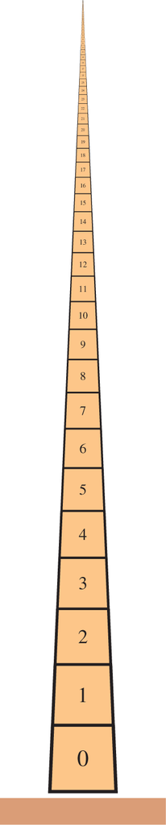

入住协议里有细则，规定客人可能需要在管理方的指示下换房。于是大家都照做了，结果是0号房现在空了，可以给新客人用。

There was fine print in the check-in agreement, you see, stipulating that guests might have to change rooms under the management’s direction. So everyone complies, with the result that room 0 has now become vacant, available for the new guest.

周末，一群人同时涌现——1000名客人——经理组织了一次大规模迁徙，指示所有现有客人搬到1000个房间：

On the weekend, a crowd shows up all at once—1000 guests—and the manager organizes a great migration, instructing all the current guests move up 1000 rooms:

[figure not shown]

这样可以提供0到999的所有房间，以适应人群需求。

This makes available all the rooms from 0 to 999, accommodating the crowd.

### **希尔伯特的公交车** **Hilbert’s bus**

接下来的一周，大批人潮到来：希尔伯特的公交车，车厢已满。公交车有无限多个座位，编号类似自然编号，比如座位0、座位1、座位2，依此类推;每个座位上都有一位新嘉宾。他们都想入住酒店。

The following week, a considerably larger crowd arrives: Hilbert’s bus, which is completely full. The bus has infinitely many seats, numbered like the natural numbers, so there is seat 0, seat 1, seat 2, and so on; in every seat, there is a new guest. They all want to check in to the hotel.

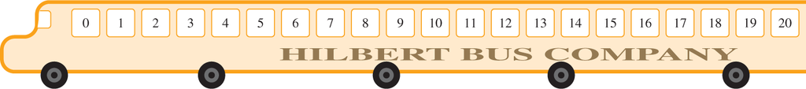

经理能照顾所有人吗？他不能像以前那样要求所有客人无限多地往上移动，因为每个房间都有有限的房间号，所以他不能简单地把所有人往上移动，在酒店底部腾出足够的空间。但他能否设法重新安排现有的客人，为公交乘客腾出空间？请先自己摸索方法再继续阅读。

Can the manager accommodate everyone? Well, he cannot, as before, ask all the guests to move up infinitely many rooms, since every individual room has a finite room number, and so he cannot simply move everyone up and make sufficient space at the bottom of the hotel. But can he somehow rearrange the current guests to make room for the bus passengers? Please try to figure out a method on your own before reading further.

你找到解决办法了吗？答案是可以的，客人可以被接待。有很多方法可以做到，但让我告诉你这位经理是怎么做的。首先，经理指示目前住*在n*房间的客人搬到*2n*房间，这样所有奇数房间就空出来了。然后他指示座位*S*的乘客选择2号房*s* + 1，这确实是奇数房间，不同座位的人会得到不同的奇数房间：

Did you find a solution? The answer is yes, the guests can be accommodated. There are many ways to do it, but let me tell you how this particular manager proceeded. First, the manager directed that the guest currently in room *n* should move to room 2*n*, which freed up all the odd-numbered rooms. Then he directed the passenger in seat *s* to take room 2*s* + 1, which is certainly an odd number, and people in different seats got different odd-numbered rooms:

[figure not shown]

这样，每个人都有自己的房间，之前的客人住在偶数号房间，公交乘客住在奇数房间。

In this way, everyone was accommodated with a room of their own, with the previous guests in the even-numbered rooms and the bus passengers in the odd-numbered rooms.

### **希尔伯特列车** **Hilbert’s train**

接着，希尔伯特的火车到达。列车有无限多节车厢，每节车厢有无限多座位，每个座位都被占满。每位乘客通过两条信息来识别：车牌号*c*和座位号*s*;每位乘客都急切地办理入住手续。

Next, Hilbert’s train arrives. The train has infinitely many train cars, each with infinitely many seats, and every seat is occupied. The passengers are each identified by two pieces of information: their car number *c* and their seat number *s*; and every passenger is eager to check into the hotel.

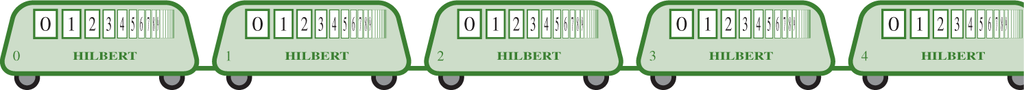

经理能照顾所有人吗？没错。作为第一步，管理者可以指示当前房间*n*的住户搬到房间2*n*，这样所有奇数房间都会被释放出来。接着，经理指示*C车厢*S座位的*乘客*应在<sup>5</sup><sup>*秒*</sup>后入住3号房间：

Can the manager accommodate them all? Yes, indeed. As a first step, the manager can direct that the current resident of room *n* should move to room 2*n*, which again frees up all the odd-numbered rooms. Next, the manager directs that the passenger in car *c*, seat *s* should check into room 3<sup>*c*</sup>5<sup>*s*</sup>:

[figure not shown]

由于3<sup>*c*</sup>5<sup>*s*</sup>肯定是奇数，因此对新客人开放，不同的列车乘客会因质因数分解的独特性占据不同的房间。所以，大家都得到了照顾。

Since 3<sup>*c*</sup>5<sup>*s*</sup> is certainly an odd number, it is available for a new guest, and different train passengers will take up different rooms because of the uniqueness of the prime factorization. So again, everyone is accommodated.

## **3.2 可数集** **3.2 Countable sets**

这个寓言的主要概念是*可数*性，因为当一个集合能被放入希尔伯特酒店中，并且它可以与一组自然数一一对应时，它就是可数的。另一种理解方式是，一个非*空集合A*是可数的，当且仅当可以用一个列表（可能带有重复）枚举*A的元素*，并用自然数索引：

The main concept at play in this allegory is *countability*, for a set is countable when it fits into Hilbert’s hotel, when it can be placed in a one-to-one correspondence with a set of natural numbers. Another way to think about it is that a nonempty set *A* is countable if and only if one can enumerate the elements of *A* by a list, possibly with repetition, indexed with the natural numbers:

[figure not shown]

我们允许重复以包含有限集合，这些有限集合我们也视为可数。

We allow repetition in order to include the finite sets, which we also regard as countable.

我们为希尔伯特酒店提出的论证表明，两个可数集合的并集是可数的，因为你可以将其中一个与偶数对应，另一个与奇数对应。例如，整数Z构成一个可数集，因为它们是两个可数无限集合——正整数和非正整数的并集。也可以通过这样枚举Z来判断它是可数的：

The arguments that we gave for Hilbert’s hotel show that the union of two countable sets is countable, since you can correspond one of them with even numbers and the other with odd numbers. The integers ℤ, for example, form a countable set, for they are the union of two countably infinite sets, the positive integers and the nonpositive integers. One can also see that ℤ is countable simply by enumerating it like this:

[figure not shown]

一个更强烈且或许令人惊讶的结果是，可数多个可数集合的并仍然是可数的。在希尔伯特列车的处理中可以看出这一点，因为列车本身由可数的可数集合组成——每个都是无限多节列车车厢。

A stronger and perhaps surprising result is that the union of countably many countable sets is still countable. One can see this with the argument in the treatment of Hilbert’s train, since the train itself consisted of countably many countable sets—infinitely many train cars, each infinite.

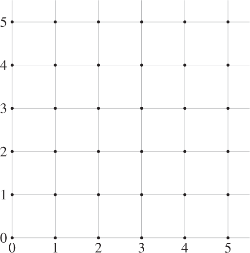

但让我们为这一根本性结果提供另一个论据。该主张是我们可以将自然数N与自然数*对*集合一一对应。如果我们将自然数对（*n， k*）视为构成网格中的格点（如图所示），那么格点的数量与自然数的数量相同。注意，该网格各列上的格点构成可数多个可数集合。我们希望以某种方式将这个二维点网格重新组织成一维点列表。

But let us give another argument for this fundamental result. The claim is that we may place the natural numbers ℕ in one-to-one correspondence with the set of *pairs* of natural numbers. If we consider the pairs (*n, k*) of natural numbers as forming the lattice points in a grid, as pictured here, then the claim is that the number of lattice points is the same as the number of natural numbers. Notice that the lattice points on the various columns of this grid form countably many countable sets. We want somehow to reorganize this two-dimensional grid of points into a one-dimensional list of points.

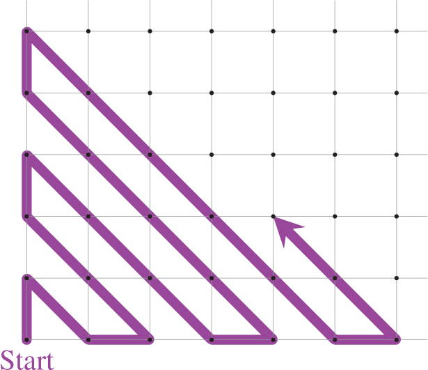

想象一下，沿着这里展示的蜿蜒小径穿过网格。我们从原点开始，然后沿着对角线逐步上下曲折地走。随着我们行走，最终会遇到任何特定的格点。当我们遇到路径上的连续点时，将它们分别关联到相继的自然数——第一个与0相关联，第二个为1，然后是2，依此类推，并将每个*自然数n*与该路径上遇到的*第n*个点（*x*<sub>*n*</sub>*， y*<sub>*n*</sub>）关联。因此，自然数与自然数对对应。

Imagine walking through the grid on the winding path pictured here. We start at the origin and then proceed to zig and zag progressively up and down the diagonals. As we walk, we shall eventually encounter any given lattice point. As we encounter the successive points on the path, let us associate them each with successive natural numbers—the first with 0, the next with 1, and then 2, and so on, and similarly associate every natural number *n* with the *n*th point (*x*<sub>*n*</sub>*, y*<sub>*n*</sub>) encountered on this path. Thus, the natural numbers are in correspondence with the pairs of natural numbers.

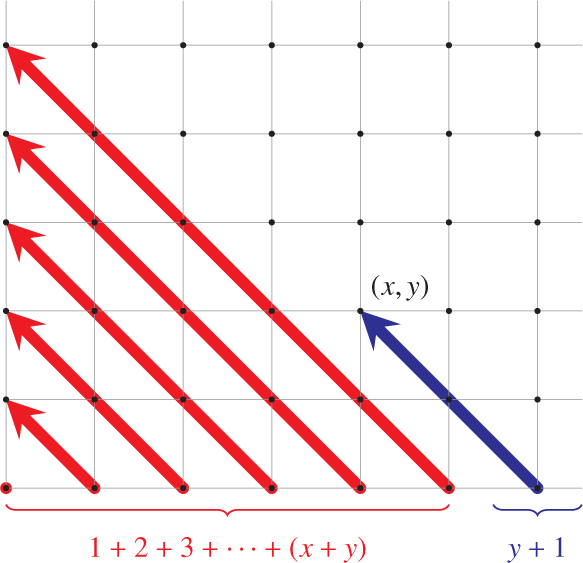

该论证的一个变体使我们能够为对应关系提供一个简单的多项式公式。也就是说，与其像之前那样沿着蜿蜒的紫色路径上下移动，不如依次沿着每条斜线向上走，从原点开始，如图中红色所示。到达点（*x， y*）之前遇到的点由向上的对角线组成，长度为1、2、3，依此类推，加上最终对角线上的*y* + 1个点。因此，前于（*x， y*）的总点数由和给出

A variation of the argument enables us to provide a simple polynomial formula for the correspondence. Namely, instead of following the winding purple path up and down as before, let us instead follow each diagonal upward successively in turn, starting at the origin, as pictured here in red. The points encountered before you get to the point (*x, y*) consist of the upward diagonals, having lengths 1, 2, 3, and so on, plus the *y* + 1 points on the final diagonal. So the total number of points preceding (*x, y*) is given by the sum

[figure not shown]

这等于

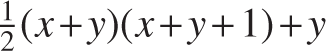

，从而为自然数提供了多项式配对函数。

This is equal to

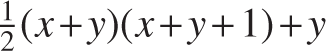

, which thereby provides a polynomial pairing function for the natural numbers.

## **3.3 等值** **3.3 Equinumerosity**

可数性是更一般的*等值性*概念的一个实例，即如果两个集合*A*和*B*的元素可以一一对应地对应，则它们是*等数*的。比如，这个房间里的人和鼻子数量是相等的，因为我们每个人都有一个鼻子，而没有人有两个（我猜没人口袋里藏着多一个鼻子）。我们可以在不计数人或鼻子的情况下验证这种等值现象，这意味着等值在概念上先于数量和计数。与此同时，在幼儿认知发展方面，这两个概念显然是一起产生的;（Sarnecka 和 Wright，2013，摘自摘要）发现“儿童要么既理解基数[计数]，也理解等值，要么两者都不理解。”

Countability is an instance of the more general underlying *equinumerosity* concept, by which two sets *A* and *B* are *equinumerous* if their elements can be placed in a one-to-one correspondence with each other. The set of people in this room, for example, is equinumerous with the set of noses, simply because we each have a nose and nobody has two (I presume nobody has an extra nose hidden in their pocket). We can verify this instance of equinumerosity without counting either the people or the noses, and this is a sense in which equinumerosity is conceptually prior to number and counting. Meanwhile, in terms of cognitive development for young children, the concepts evidently arise together; (Sarnecka and Wright, 2013, from the abstract) finds “that children either understand both cardinality [counting] and equinumerosity or they understand neither.”

我们在第一章讨论了关于弗雷格数概念和康托-休谟原理的等值性，该原理断言我们的数概念由等值性追踪，即两个类在等数时元素数恰好相同。讨论主要集中在有限数，因为弗雷格试图通过这一原理将算术归约为逻辑。相比之下，康托尔特别关注等值关系的无限集合。

We had discussed equinumerosity in chapter 1 in connection with Frege’s number concept and the Cantor-Hume principle, which asserts that our number concept is tracked by equinumerosity, in that two classes have the same number of elements exactly when they are equinumerous. That discussion was preoccupied with the finite numbers, for Frege was striving to reduce arithmetic to logic by means of this principle. Cantor, in contrast, focuses the equinumerosity relation particularly on the infinite sets.

伽利略在其最后的科学著作《*论两种新科学的对话*录》（1638年）中，先见之明地阐述了无限等值的复杂难题，这比弗雷格和康托尔早了几个世纪，书中是辛普利西奥与萨尔维亚蒂之间的对话，他们观察到，通过将每个数字*n*与其平方*n2*联系起来，自然数可以与完美平方一一对<sup>应：</sup>

Galileo wrote presciently on the confusing difficulties of infinitary equinumerosities in his final scientific work, *Dialogues Concerning Two New Sciences* (1638), centuries before Frege and Cantor, in a dialogue between the characters Simplicio and Salviati, who observe that the natural numbers can be placed in a one-to-one correspondence with the perfect squares by associating each number *n* with its square *n*<sup>2</sup>:

[figure not shown]

这种情况具有悖论，因为虽然数字似乎比正方形多，但并非每个数字都是正方形，但对应关系表明数字数量与正方形相同。因此，这个例子指出了“任意两个一对应集合大小相同（后来称为康托尔-休谟原理”）与欧*几里得原理*之间的张力，后者断言对象的任何真部分都小于原对象。伽利略认识到我们必须放弃其中一个。

The situation is paradoxical, since while there seem to be more numbers than squares, as not every number is a square, nevertheless the correspondence suggests that there are the same number of numbers as squares. The example, therefore, identifies tension between the idea that any two collections in one-to-one correspondence have the same size (later known as the Cantor-Hume principle), and *Euclid’s principle*, which asserts that any proper part of an object is smaller than the original object. Galileo recognized that we must give one of them up.

伽利略的字符同样观察到，不同长度的线段上的点可以通过相似扇实现一一对应，如下：

Galileo’s characters similarly observe that the points on line segments of different lengths can be associated in a one-to-one correspondence by a fan of similarity, like this:

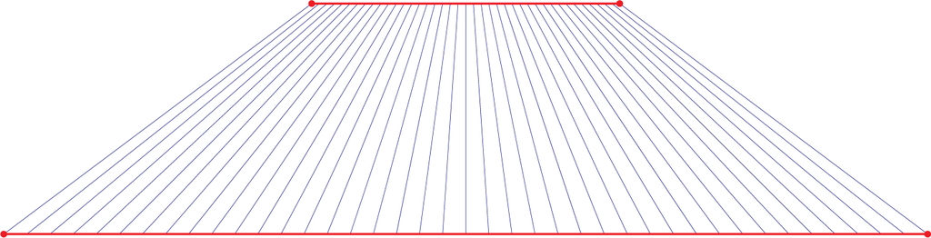

由于两段上的点因相似性被置于一一对应中，因此较小的段与较大段的点数相同，而较短的线段似乎也较少，这似乎具有悖论。

Because the points on the two segments are placed by this similarity into a one-to-one correspondence, it seems paradoxical that the smaller segment would have the same number of points as the larger segment, while at the same time, being shorter, it also seems to have fewer points.

事实上，伽利略的人物观察到有限的开线段可以与整条直线一一对应！在下一页顶部的图中，红色线段顶部内部的每个点都会下降到半圆，然后向外投影到该直线;直线上的每个点都被实现，因此线段与直线之间是一一对应的：

Indeed, Galileo’s characters observed that a finite open line segment can be placed in a one-to-one correspondence with an entire line! In the figure at the top of the next page, every point in the interior of the red segment at top drops down to the semicircle and is then radially projected out to the line; every point on the line is realized, and so this is a one-to-one correspondence between the line segment and the line:

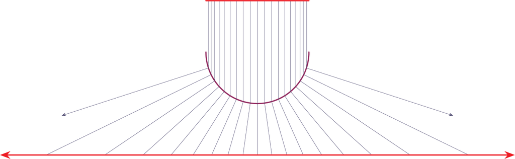

伽利略通过他的角色萨尔维亚蒂得出结论，在无限领域中，大小的比较根本不适用：

Galileo concludes, through his character Salviati, that comparisons of size simply do not apply in the realm of the infinite:

据我所见，我们只能推断所有数的总和是无限的，方格的数量是无限的，它们的根的数量是无限的;正方形的数量既不小于所有数的总和，后者也不大于前者;最后，“相等”、“更大”和“更小”这些属性不适用于无限，只适用于有限量。因此，当辛普利西奥引入几条不同长度的线并问我，为什么较长的线不会比较短的线包含更多点时，我回答他，一行不包含更多或更少或仅等于另一行的点数，而是每行包含无限多个点。（伽利略·伽利莱，1914年[1638]，第32页）

So far as I see we can only infer that the totality of all numbers is infinite, that the number of squares is infinite, and that the number of their roots is infinite; neither is the number of squares less than the totality of all the numbers, nor the latter greater than the former; and finally the attributes “equal,” “greater,” and “less,” are not applicable to infinite, but only to finite, quantities. When therefore Simplicio introduces several lines of different lengths and asks me how it is possible that the longer ones do not contain more points than the shorter, I answer him that one line does not contain more or less or just as many points as another, but that each line contains an infinite number. (Galileo Galilei, 1914 [1638], p. 32)

## **3.4 希尔伯特的半程马拉松** **3.4 Hilbert’s half-marathon**

回到我们的寓言，大家都在城里为大赛而来，比赛来了：希尔伯特的半程马拉松——这群人喜欢分数——跑者们挤得密密麻麻。每位跑者都有一个比赛编号，对应每个非负有理数：

Returning to our allegory, everyone is in town for the big race, and here it comes: Hilbert’s half-marathon—this crowd likes fractions—with the runners densely packed in amongst themselves. The runners each have a race number, one for every nonnegative rational number:

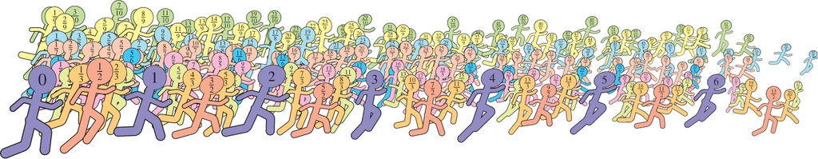

Can the hotel manager accommodate all the runners? Yes. As usual, he frees up the odd-numbered rooms by moving the current guests to double their current room number. Then, he places runner *p/q* in room 3<sup>*p*</sup>5<sup>*q*</sup>, where *p/q* is in lowest terms:

[figure not shown]

这样一来，整个半程马拉松就融入了希尔伯特的酒店。

In this way, the entire half-marathon fits into Hilbert’s hotel.

### **坎特的游轮** **Cantor’s cruise ship**

After the race, a shadow falls upon the hotel, as Cantor’s cruise ship pulls into the harbor. The ship carries a passenger for every real number. There is passenger , passenger *e*, passenger *π*, and so on, each excited finally to have arrived. Every ship passenger has a ticket, with a distinct ticket number printed upon it (a real number), and the cruise was fully booked: every real number arises on some ticket. The integers are in first class, and then the rational and algebraic numbers, followed by enormous crowds of passengers with transcendental ticket numbers. As the passengers disembark, they all want to check in to Hilbert’s Grand Hotel. Can the hotel accommodate all of Cantor’s passengers?

[figure not shown]

## **3.5 不可数性** **3.5 Uncountability**

有趣的答案，也许令人震惊或至少令人困惑，是不，坎托尔游轮上的乘客无法容纳希尔伯特的酒店。康托尔的深刻发现是实数集合*是不可数*的。实数不能与自然数一一对应。特别地，这表明无穷大有不同大小，因为实数的无限大于自然数的无限大。

The fascinating answer, perhaps shocking or at least confusing, is no, the passengers on Cantor’s cruise ship will not fit into Hilbert’s hotel. Cantor’s profound discovery was that the set of real numbers is *uncountable*. The real numbers cannot be placed in a one-to-one correspondence with the natural numbers. In particular, this shows that there are different sizes of infinity, for the infinity of the real numbers is a larger infinity than the infinity of the natural numbers.

该主张认为实数集合 R 是不可数的，无法与自然数 N 一一对应，因此 R 的大小比 N 的大小更高阶。为了证明这一点，假设实数构成一个可数集。因此，实数可以枚举在*列表 r*<sub>1</sub>*， r*<sub>2</sub>*， r*<sub>3</sub>*， ...*，其中每个实数都出现。利用这个列表，让我们描述一个特定的实数 *z*，通过指定其小数位：

The claim is that the set of real numbers ℝ is uncountable, that it cannot be put in one-to-one correspondence with the natural numbers ℕ, and therefore the size of ℝ is a higher-order infinity than that of ℕ. To prove this, let us suppose toward contradiction that the real numbers form a countable set. Thus, the real numbers can be enumerated in a list *r*<sub>1</sub>*, r*<sub>2</sub>*, r*<sub>3</sub>*, …*, in which every real number appears. Using this list, let us describe a particular real number *z*, by specifying its decimal digits:

[figure not shown]

We choose the digit *d*<sub>*n*</sub> specifically to be different from the *n*th digit of the decimal representations of *r*<sub>*n*</sub>. Let us take *d*<sub>*n*</sub> = 1, unless the *n*th digit of a decimal representation of *r*<sub>*n*</sub> is 1, in which case we use *d*<sub>*n*</sub> = 7 instead. In the construction, we ensure that *z ≠ r*<sub>*n*</sub> exactly at stage *n*, precisely because these two numbers differ in their *n*th decimal digits (and note that *z*, having all digits 1 or 7, has a unique decimal expansion). Since this is true for every *n*, it follows that the real number *z* does not appear on the list. But this contradicts our assumption that every real number appears on the list. And so the real numbers form an uncountable set, completing the proof.

为了加深对这一论证的理解，我用一个明确的例子来说明其构造。也许最初的数字列表恰好是这样开头的：

To deepen our understanding of the argument, let me illustrate the construction with an explicit example. Perhaps the initial list of numbers happened to begin like this:

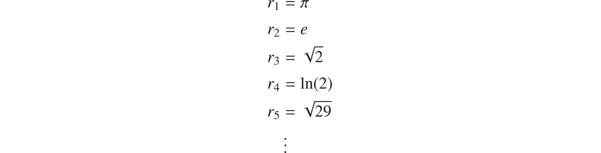

我们可以将这些数字的小数展开排在小数点后，如下：

We may line up the decimal expansions of these numbers after the decimal place, like this:

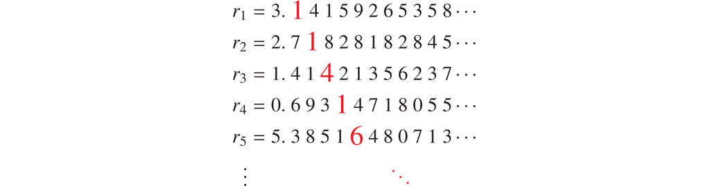

通过检查这些红色对角数字，我们看到证明中定义的对角实数 *z* 为

By inspecting those red diagonal digits, we see that the resulting diagonal real number *z* defined in the proof will be

[figure not shown]

由于构造中说用1作为*第n*位数字，除非*R*<sub>*的*</sub>*第n*位是1，此时我们用7作为数字。通过参考对角线上的红数字，这个过程得到上面的实数 *z*。实数 *z* 在给定枚举中称为*对角实数*，因为 *z* 的数字是参考原始数字列表中高亮的对角数字，即第 *n*个数字的*第 n*位数字。因此，康托尔的论证法被称为*对角法*，这是一种极其稳健的方法，可能出现在成千上万个数学论证中，其中许多相当抽象。本章我们将看到更多对角线论证。

since the construction said to use 1 as the *n*th digit, unless the *n*th digit of *r*<sub>*n*</sub> is 1, in which case we are to use 7 as the digit. By consulting the red digits on the diagonal, this process results in the real number *z* above. The real number *z* is called the *diagonal real number* for the given enumeration, because the digits of *z* are defined by reference to the highlighted diagonal digits on the original list of numbers, the *n*th digit of the *n*th number. For this reason, Cantor’s argument method is known as the *diagonal method*, a method that is extremely robust, appearing in perhaps thousands of mathematical arguments, many of them quite abstract. We shall see a few more diagonal arguments in this chapter.

让我简要讨论一个细微但最终较小的问题，原因是某些实数有两个表示，比如0.9999......= 1.0000......，因此一般来说，称实数的“十进制展开”是不正确的。由于非唯一性仅在这种最终全九/全零的情况中出现，且我们的对角实数 *z* 只有 1 和 7，因此它将具有唯一的表示。因此，实际上正因为这个性质本身，如果 *r*<sub>*n*</sub> 有两个表示，我们会自动实现 *z ≠ r*<sub>*n*</sub>。所以这个问题无关紧要。

Let me briefly address a subtle but ultimately minor issue caused by the fact that some real numbers have two representations, such as with 0.9999⋯ = 1.0000⋯, and for this reason, it is not correct in general to speak of “the” decimal expansion of a real number. Since nonuniqueness arises only in connection with such an eventually-all-nines/all-zeros situation, and since our diagonal real number *z* has only 1s and 7s, it will have a unique representation. Consequently, and indeed because of this property itself, we will achieve *z ≠ r*<sub>*n*</sub> automatically if *r*<sub>*n*</sub> should have two representations. So this problem is moot.

### **康托尔最初的论点** **Cantor’s original argument**

从历史角度看，康托尔最初的论证并不涉及数字数字，就像我们在这里给出的论证方式那样。相反，他这样论证：如果实数构成一个可数集，那么我们可以将它们枚举为 *r*<sub>1</sub>、*r*<sub>2</sub>、*r*<sub>3</sub> 等列表。然后我们可以构造一个嵌套闭区间序列，特别选择*第n*个区间以*排除rn*<sub>：</sub>

As a historical matter, Cantor’s original argument did not refer to the digits of the numbers, in the manner of argument we have given here. Rather, he argued as follows: If the real numbers form a countable set, then we may enumerate them in a list *r*<sub>1</sub>, *r*<sub>2</sub>, *r*<sub>3</sub>, and so on. We may then construct a nested sequence of closed intervals, choosing the *n*th interval specifically to exclude the number *r*<sub>*n*</sub>:

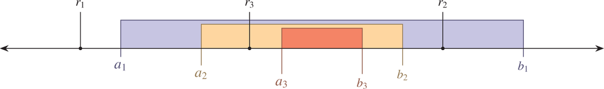

也就是说，我们选择第一个区间[*a*<sub>1</sub>*， b*<sub>1</sub>]以*排除数r*<sub>1</sub>，选择下一个区间[*a*<sub>2</sub>*， b*<sub>2</sub>]以排除*r*<sub>2</sub>，依此类推，依此类推，逐一通过自然数排列。设*z* = sup<sub>*n*</sub>*a*<sub>*n*</sub>，为区间左端点的上确界。这是一个实数，因此它都在所有区间内。因此，它与所有数*rn*<sub>不同，因为</sub>这些数字都被系统性地排除在区间之外。所以 *z* 是一个不在原始数字列表中的实数。但这与列表中包含所有实数的假设相矛盾。因此实数集合是不可数的。

That is, we choose the first interval [*a*<sub>1</sub>*, b*<sub>1</sub>] specifically to exclude the number *r*<sub>1</sub>, we choose the next interval [*a*<sub>2</sub>*, b*<sub>2</sub>] so as to exclude *r*<sub>2</sub>, and so on, progressively through the natural numbers. Let *z* = sup<sub>*n*</sub>*a*<sub>*n*</sub> be the supremum of the left endpoints of the intervals. This is a real number that is therefore inside all the intervals. It is consequently different from every number *r*<sub>*n*</sub> because those numbers were each systematically excluded from the intervals. So *z* is a real number that is not on the orginal list of numbers. But this contradicts the assumption that the list had included every real number. So the set of real numbers is uncountable.

一些作者指出这两种论证的差异，声称康托尔最初的论证没有对角化的概念，他们认为对角化是后来才出现的。我的观点是，这种批评是错误的，尽管这两个证明表面上不同，第一个使用对角化，第二个使用嵌套闭区间序列，但它们本质上是相同的构造。

Some authors have remarked on the difference between the two arguments, claiming that Cantor’s original argument did not have the diagonalization idea, which, they say, came only later. My perspective is that this criticism is wrong, and that although the two proofs are superficially different, the first using diagonalization and the second using a nested sequence of closed intervals, nevertheless they are fundamentally the same construction.

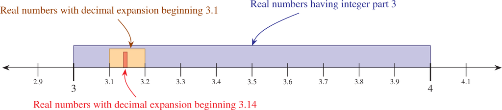

原因在于，在十进制展开中指定实数的前几位，恰恰是将实数区间限制在一定区间内，即那些以这些数字开始展开的数字。因此，指定对角实数的额外数字使得与*rn*<sub>不同，意味着</sub>限制在排除<sub>*rn*</sub>的数字区间内。所以这两个论点描述的是同一个潜在的思想。

The reason is that to specify the first several digits of a real number in the decimal expansion is exactly to restrict to a certain interval of real numbers, the numbers whose expansion begins with those digits. And so to specify an additional digit of the diagonal real number so as to be different from *r*<sub>*n*</sub> amounts to restricting to an interval of numbers excluding *r*<sub>*n*</sub>. So the two arguments are describing the same underlying idea.

### **数学曲柄** **Mathematical cranks**

康托尔的定理和证明有时会被某些典型方式误解，比如数学上的“曲柄”现象，即自认为是未被认可的天才，反驳了数学既定教条，但实际上并未做出任何事。我有时会收到一些人发来的邮件或手稿，声称康托尔的证明全错，或者整个数学都是错的，这是一种妄想的阴谋。遗憾的是，他们提出的反对意见毫无力量。

Cantor’s theorem and proof are sometimes misunderstood in certain characteristic ways, and there is the phenomenon of the mathematical “crank,” an unfortunate person who takes himself or herself as an unrecognized genius who has refuted the established dogma of mathematics, but who actually has done nothing of the sort. I sometimes receive email or manuscripts from people claiming that Cantor’s proof is all wrong, or that all of mathematics is wrong, a conspiracy of delusion. Sadly, the objections they raise are without force.

让我试着给你尝尝。在一些手稿中，其提议基本上是，在构造康托尔的对角实数*z*后，如果它没有出现在原始列表*r*<sub>1</sub>， *r*<sub>2</sub>， *r*<sub>3</sub>， ...中，那么只需*将其加入列表*即可！他们说，把对角*实数z*放在前面，一切就没问题了。当然，这个提议毫无道理。对角实数可能出现在另一个列表上，而不是原始列表，这根本无关紧要。对角实数的意义在于，由于它不在原始列表中，它推翻了原列表已经包含所有实数的假设。这一矛盾表明不可能构成包含所有实数的列表，这正是实数集合 R 不可数的含义。

Let me try to give a taste of it. In some manuscripts, the proposal is essentially that after having constructed Cantor’s diagonal real number *z*, if it does not appear on the original list *r*<sub>1</sub>, *r*<sub>2</sub>, *r*<sub>3</sub>, …, then one should simply *add it to the list*! Put the diagonal real number *z* in front, they say, and everything is fine. This proposal, of course, is without merit. It simply does not matter that the diagonal real number can appear on another list, different from the original list. The point of the diagonal real number is that because it is not on the original list, it refutes the supposition that the original list already contained all real numbers. This contradiction shows that it is impossible to make a list containing all real numbers, and that is exactly what it means to say that the set of real numbers ℝ is uncountable.

另一种策略是，有人会直接忽略康托尔的论证，转而尝试直接证明实数集合是可数的。例如，这个人可能先证明具有有限终止十进制展开的实数集合是可数的，接着指出每个实数都是此类数的极限;因此，他们得出结论，实数只有可数的数量。

Another strategy one sees is that a person will simply ignore Cantor’s argument and instead try to mount his or her own direct proof that the set of real numbers is countable. For example, the person might start by proving that the set of real numbers with finite terminating decimal expansions is countable, and next, point out that every real number is a limit of such numbers; and so, they conclude, there are only countably many real numbers.

这个论证一开始很不错，因为确实，具有有限终止十进制展开的数恰恰是分母为10的幂可以表达的有理数，因此这样的数只有可数的数量。第二步也没问题，因为每个实数都是此类有理数序列的极限，这些序列对实数的近似越来越近。然而，论证的最后一步并不正确;事实上，声称可数集的极限点集合是可数的主张通常没有证明或证明错误，结论本身就是错误的。实数集确实存在一个可数稠密集，但这并不意味着实数本身是可数的。

This argument starts out fine, since indeed, the numbers with a finite terminating decimal expansion are precisely the rational numbers expressible with a denominator that is a power of 10, and so there are only countably many such numbers. The second step is also fine, since indeed, every real number is a limit of a sequence of such rational numbers, which approximate it ever more closely. The last step of the argument, however, is not correct; and indeed, the claim that the set of limit points of a countable set is countable is usually left with no proof or with an erroneous proof, and the conclusion is simply incorrect. The set of real numbers does have a countable dense set, but this does not mean that the real numbers themselves are countable.

## **3.6 康托尔论先验数** **3.6 Cantor on transcendental numbers**

康托利用他的定理为利乌维尔1844年关于超越数存在的定理提供了新的证明。事实上，康托尔不仅证明了超越实数的存在，而且*大多数*实数都是超越的。具体来说，虽然代数实数只有可数的数量，但超越实数的不可数——即严格更大的无穷大。

Cantor used his theorem to provide a new proof of Liouville’s 1844 theorem that transcendental numbers exist. Indeed, Cantor proved not only that transcendental real numbers exist, but furthermore, *most* real numbers are transcendental. Specifically, while there are only countably many algebraic real numbers, there are uncountably many transcendental real numbers—a strictly larger infinity.

接下来，既然康托尔已经证明存在不可数的实数，那么必然存在一些非代数的实数，也就是说它们是超越性的。事实上，由于两个可数集合的并是可数的，因此必然存在不可数多个超越实数，但代数只能可数。从这个意义上说，大多数实数是超越性的。

Next, since Cantor had proved that there are uncountably many real numbers, it follows that there must be some real numbers that are not algebraic, which is to say that they are transcendental. Indeed, since the union of two countable sets is countable, there must be uncountably many transcendental real numbers, but only countably many algebraic numbers. In this sense, most real numbers are transcendental.

### **建构性论证与非建构性论证** **Constructive versus nonconstructive arguments**

让我强调这个论点中提出的一个微妙问题。存在超越数的主张是一种存在主义主张，即某种数学对象存在的主张（先验数）。数学中的存在性主张通常可以通过*构造*性证明来证明，即明确展示所涉及数学对象的证明。相比之下，非构造性证明可能证明存在这样的对象，但不提供具体实例，也不指向该类对象的具体例子。例如，存在性命题的非构造性证明可能通过假设不存在此类对象推导出矛盾来进行。

Let me highlight a certain subtle issue raised by this argument. The claim that there are transcendental numbers is an existential claim, a claim that a certain kind of mathematical object exists (a transcendental number). Existential claims in mathematics can often be proved with a *constructive* proof, a proof that explicitly exhibits the mathematical object in question. A nonconstructive proof, in contrast, might prove that there is such an object without providing any specific instance and without directing us to any specific example of that kind of object. A nonconstructive proof of an existential claim, for example, might proceed by deriving a contradiction from the assumption that there are no such objects.

考虑以下论点：这个仓库里一定有猫，因为我们没看到老鼠。该论证是非建设性的，因为它没有表现出任何特定的猫;建设性的论点会让我们看到真正的猫。同样，当我们论证必须存在超越实数，否则只有可数的实数时，我们似乎并未学到任何特定的超越数，而像刘维尔这样的建构性论证则会显示实际实例。数学家通常在可能的情况下，如果论证难度相当，更倾向于采用构造性证明。建设性的论点更有说服力吗？也许，因为当对象被明确提供时，论证中出现错误的可能性就降低了;当你给我看仓库里的猫时，我很容易相信仓库里真的有猫。然而，建构性证明往往比其他方法更繁琐和复杂，正因为它们提出了更详细的主张。另一个偏好建构性证明的原因是，它们通常似乎提供了比单纯存在陈述更多的关于被断言对象本质的信息。当你给我看真正的猫时，我可能会看到它的花纹，判断它是否友好等等。

Consider the following argument: there must be a cat in this warehouse, since we do not see any mice. The argument is nonconstructive, since it does not exhibit any specific cat; a constructive argument would show us the actual cat. Similarly, when we argue that there must be a transcendental real number because otherwise there would be only countably many real numbers, then we do not seem to learn of any specific transcendental number, while a constructive argument like Liouville’s would exhibit an actual instance. Mathematicians often prefer constructive proofs, when possible, if the difficulty of the argument is comparable. Are constructive arguments more convincing? Perhaps, because when the object is explicitly provided, then it seems less likely that there has been a mistake in the argument; when you show me an actual cat in the warehouse, it is easy to believe that there is a cat in the warehouse. Nevertheless, constructive proofs can often be fussy and more complicated than the alternatives, precisely because they make a more detailed claim. Another reason to prefer constructive proofs is that they often seem to provide more information about the nature of the object asserted to exist than merely the raw statement of existence. When you show me the actual cat, then I might see its markings and learn whether it is friendly, and so forth.

必须意识到，*建构*性术语的使用存在一定的冲突。也就是说，一方面，数学家通常以我刚才描述的宽泛方式使用该术语，指代一种情境，即数学论证在某种意义上构建了该论证所涉及的数学对象，即使这些手段可能是无限的或不可计算的。但另一方面，遵循建*构主义*哲学立场的数学家和哲学家则用该术语有更精确的含义，对建构性的要求要求更严格。例如，在此用法中，建构性论证甚至不允许使用排中律，例如论证中可能出现的案例，尽管在更宽容的普通用法中，这种用法仍可能被视为建设性。我们将在第五章进一步讨论这个话题。现在，让我们先用更宽松、通用的用法。

One must be aware that there is a certain clash in the usage of the *constructive* terminology. Namely, on the one hand, mathematicians commonly use the term in the loose way I have just described, to refer to a situation where a mathematical argument provides a means of building—in some sense—the mathematical object that the argument is about, even in cases where those means might be infinitary or noncomputable. But meanwhile, on the other hand, mathematicians and philosophers following the philosophical position known as *constructivism* use the term with a more exact meaning, imposing much stricter requirements on what counts as constructive. For example, in this usage, constructive arguments are not allowed even to use the law of excluded middle, such as might arise in an argument by cases, even though such a use might still be considered constructive in the more permissive ordinary usage. We shall discuss this topic further in chapter 5. For now, let us proceed with the looser, common usage.

那么，康托尔证明先验数存在的证明是构造性的吗？柳维尔早在1844年的论点无疑具有建设性;他通过指定数字给出了一个特定的实数——利维尔常数，并证明了它是超越的。康托尔的论证是否也提供了具体的先验数？还是说这只是纯粹的存在证明，表明一定存在一些超越数字，但我们对它们一无所知，就像仓库里那些看不见的猫一样？

So, is Cantor’s proof of the existence of transcendental numbers constructive? Liouville’s earlier 1844 argument was certainly constructive; he provided a specific real number, the Liouville constant, by specifying its digits, and he proved that it was transcendental. Does Cantor’s argument also provide specific transcendental numbers? Or is it instead only a pure existence proof, showing that there must be some transcendental numbers, but we know nothing about them, like the unseen cats in the warehouse.

偶尔，甚至经常会看到数学家断言康托尔的论证确实不是建设性的;我曾在一次大型公开讲座上见过一位极为著名的数学家向数百人提出这一断言。提出这一主张的数学家通常解释康托尔证明实数集合不可数性的过程是通过矛盾进行的——它不可数是因为任何提出的枚举都不充分——然后同样通过矛盾推断，必然存在超越数，否则将只有可数的实数，这也是第二个矛盾。这种论证方式确实看起来是非构造性的，因为它证明了一些实数必须是超越性的，但似乎并没有表现出任何特定的超越数。

One occasionally, or even often, finds mathematicians asserting that indeed, Cantor’s argument is not constructive; I once saw an extremely prominent mathematician make this assertion to hundreds of people in a big public lecture. Mathematicians making this claim usually explain that Cantor’s proof of the uncountability of the set of real numbers proceeds by contradiction—it is uncountable because any proposed enumeration is inadequate—and one then deduces, also by contradiction, that there must be transcendental numbers because otherwise there would be only countably many real numbers, which is a second contradiction. This way of arguing indeed appears nonconstructive, since it proves that some real numbers must be transcendental, but it does not seem to exhibit any particular transcendental number.

尽管如此，我认为康托尔的论证如果正确进行，实际上是建设性的，并且确实提供了具体的先验数字。要看清这一点，首先注意康托尔证明代数数可数提供了一种显式的枚举方法;其次，康托尔的对角化方法为任意实数枚举提供了构造特定数——对角实数的方法，而该对角实数并不出现在该枚举中。因此，结合这两步，先枚举代数数，再生成对角实数，从而构造出一个非代数的特定实数。所以康托尔的证明最终是建设性的。

Nevertheless, I claim that Cantor’s argument, undertaken properly, is actually constructive and does provide specific transcendental numbers. To see this, notice first that Cantor’s proof that the algebraic numbers are countable provides an explicit method for enumerating them and second that Cantor’s diagonalization method provides for any given enumeration of real numbers a method of constructing a specific number—the diagonal real—which does not appear on that enumeration. By combining these two steps, therefore, first enumerating the algebraic numbers and then producing the corresponding diagonal real number, we thereby construct a specific real number that is not algebraic. So Cantor’s proof is constructive after all.

## **3.7 关于集合子集的数量** **3.7 On the number of subsets of a set**

康托尔推广了他的对角论证，证明每个集合的子集数量严格多于元素。没有集合 *X* 与其*幂集 P*（*X*） 等数，后者是 *X* 的所有子集的集合。我们给出以下论证：假设一个集合*X*与其*幂集P*（*X*）等数。因此，*X* 的元素与 *X* 的子集之间存在一一对应关系，将每个元素 *a* ∈ *X* 与子集 *X*<sub>*A ⊆*</sub> *X* 关联，从而实现每个子集。基于这种关联，我们定义对角集：

Cantor generalized his diagonal argument to show that every set has strictly more subsets than elements. No set *X* is equinumerous with its *power set P*(*X*), the set of all subsets of *X*. Let us give the following argument: We suppose toward contradiction that a set *X* is equinumerous with its power set *P*(*X*). So there is a one-to-one correspondence between the elements of *X* and the subsets of *X*, associating each element *a* ∈ *X* with a subset *X*<sub>*a*</sub> ⊆ *X* in such a way that every subset is realized. Given this association, let us define the diagonal set:

[figure not shown]

This is a perfectly good subset of *X*. The key thing to notice is that for every element *a*, we have *a* ∈ *D* exactly when *a* ∉ *X*<sub>*a*</sub>. This immediately implies that *D ≠ X*<sub>*a*</sub> for every *a* ∈ *X*. So *D* is a subset that is not associated to any element *a* ∈ *X*, contrary to our assumption that we had a one-to-one association of the elements of *X* with all the subsets of *X*. So *P*(*X*) is not equinumerous with *X*. In fact, the argument shows that there can be no surjective map from a set *X* to its power set.

该论证遵循康托尔本质对角线思想的抽象形式，因为我们将元素*a置入*对角子集*D*中，取决于*a*是否属于<sub>*Xa*</sub>。也就是说，在坐标 *a* 处，我们处理集合 <sub>*X a*</sub>，实际上是在处理 *X* × *X* 的抽象对角线。

This argument follows an abstract form of Cantor’s essential diagonal idea, since we have placed an element *a* into the diagonal subset *D* depending on whether *a* is in *X*<sub>*a*</sub>. That is, at coordinate *a*, we work with set *X*<sub>*a*</sub>, in effect working on the abstract diagonal of *X* × *X*.

到目前为止，我们已经证明没有集合 *X* 与其幂集 *P*（*X*） 等群。同时，很容易看出每个集合 *X* 的子集数量至少与元素数相等，因为我们可以将每个元素 *x* ∈ *X* 关联到单元素集 {*x*}。因此，集合的幂集严格大于集合*X<P*（*X*）。

So far, we have proved that no set *X* is equinumerous with its power set *P*(*X*). Meanwhile, it is easy to see that every set *X* has at least as many subsets as elements, for we can associate each element *x* ∈ *X* with the singleton subset {*x*}. Therefore, the power set of a set is strictly larger than the set, *X < P*(*X*).

### **关于无穷大数** **On the number of infinities**

例如，自然数*P*（N）的幂集大于N，因此这是一个不可数集合。通过迭代幂集运算，我们可以产生越来越大的无穷大小：

The power set of the natural numbers *P*(ℕ), for example, is larger than ℕ, and so this is an uncountable set. By iterating the power set operation, we may therefore produce larger and larger sizes of infinity:

[figure not shown]

每个连续幂集都是一个严格更大的不可数无穷大，因此特别地，存在无限多个不同大小的无穷。

Each successive power set is a strictly larger uncountable infinity, and so in particular, there are infinitely many different sizes of infinity.

有多少个无限？正如我们刚才所说，是无限多的。但究竟是哪一个无限？假设我们有 *κ* 个不同的无限基数 *κ*<sub>*i*</sub>，它们由某个大小为 *κ* 的索引集 *I* 中的元素 *i* 索引。因此，每个基数*κ*<sub>*i*</sub>是某个集合*X*<sub>*的*</sub>基数。我们固定特定的此类集合 *X*<sub>*i*</sub>，设 *X* = ⋃ <sub>*i*∈*I*</sub>*X*<sub>*i*</sub> 是所有这些集合的并集，因此它至少与它们的任何集合一样大。因此，幂集 *P*（*X*） 严格大于所有集合 <sub>*X i*</sub> 。因此我们发现了一个大于每个*κ*<sub>*i*</sub>的基数。我们已经证明，没有一组基数能包含所有基数。

How many infinities are there? Well, infinitely many, as we have just said. But which infinity? Suppose that we have *κ* many different infinite cardinals *κ*<sub>*i*</sub>, indexed by elements *i* in some index set *I* of size *κ*. So each cardinal *κ*<sub>*i*</sub> is the cardinality of some set *X*<sub>*i*</sub>. Let us fix particular such sets *X*<sub>*i*</sub>, and let *X* = ⋃ <sub>*i*∈*I*</sub>*X*<sub>*i*</sub> be the union of all these sets, which is therefore at least as large as any of them. The power set *P*(*X*), therefore, is strictly larger than every set *X*<sub>*i*</sub>. So we have found a cardinality larger than every *κ*<sub>*i*</sub>. What we have proved is that no set of cardinal numbers can have all the cardinal numbers.

因此，总体结论是：

The general conclusion, therefore, is:

无限比任何一个给定的无限都多。

There are more different infinities than any given infinity.

我们将在第八章进一步探讨这个问题。虽然这里的论证在选择集合 <sub>*X i*</sub> 时使用了选择公理，但在泽梅洛-弗兰克尔集合论中，也可以在没有选择公理的情况下进行该公理的变体。与此同时，该结论无法在较弱的策梅洛系统中证明，该系统缺乏替代公理;事实上，策梅洛的理论与仅存在可数多个不同基数是一致的。

We shall pursue this further in chapter 8. While the argument here used the axiom of choice in picking the sets *X*<sub>*i*</sub>, nevertheless a version of it can be undertaken in Zermelo-Fraenkel set theory without the axiom of choice. Meanwhile, the conclusion cannot be proved in the weaker Zermelo system, which lacks the replacement axiom; indeed, Zermelo’s theory is consistent with the existence of only countably many different cardinalities.

### **罗素论命题数量** **Russell on the number of propositions**

伯特兰·罗素（1903年）提出了一个相关的论点，归功于康托尔，认为命题严格多于对象。首先，他直接论证命题数量至少与对象数量相等：

Bertrand Russell (1903) mounts a related argument, with credit to Cantor, that there are strictly more propositions than objects. First, he argues directly that there are at least as many propositions as objects:

或者再说一次，拿命题类来说。每个对象都可能出现在某个命题中，而且几乎可以肯定命题的数量至少和对象的数量一样多。因为如果 *u* 是固定类，那么“*x* 是 *u*”对于每个不同的 *x* 值都是一个不同的命题;......我们只需适当变换 *u*，即可获得对每个可能 *x* 的命题形式，因此命题数量至少要多于对象的命题数。（罗素，1903年，第348节）

Or again, take the class of propositions. Every object can occur in some proposition, and it seems indubitable that there are at least as many propositions as there are objects. For, if *u* be a fixed class, “*x* is a *u*” will be a different proposition for every different value of *x*; …we only have to vary *u* suitably in order to obtain propositions of this form for every possible *x*, and thus the number of propositions must be at least as great as that of objects. (Russell, 1903, §348)

其次，利用康托尔的对角化方法，他认为命题函数数量不可能与对象相同：

Second, using Cantor’s diagonalization method, he argues that there cannot be the same number of propositional functions as objects:

Again, we can easily prove that there are more propositional functions than objects. For suppose a correlation of all objects and some propositional functions to have been affected, and let *φ*<sub>*x*</sub> be the correlate of *x*. Then “not-*φ*<sub>*x*</sub>(*x*),” i.e. “*φ*<sub>*x*</sub> does not hold of *x*,” is a propositional function not contained in the correlation; for it is true or false of *x* according as *φ*<sub>*x*</sub> is false or true of *x*, and therefore it differs from *φ*<sub>*x*</sub> for every value of *x*. (Russell, 1903, §348)

该论证的形式对角逻辑几乎与康托尔证明集合*X*的子集多于元素的证明相同。

The formal diagonal logic of this argument is nearly identical to Cantor’s proof that a set *X* has more subsets than elements.

### **关于可能委员会的数量** **On the number of possible committees**

让我们以拟人化的形式重新表述这一论点，认为从给定人群中可能组成的委员会数量严格多于人数，无论人数是有限还是无限。假设委员会可以由该机构的任何一组人组成。所以我们有全职委员会，每个人都是成员;还有空委员会，没人是成员;还有所有单人委员会、各类两人或三人委员会，等等。从单人委员会来看，我们立刻看到委员会数量至少和人数一样多。然而，这本身并不意味着委员会数量多于人数，因为在无限的情况下，或许人与委员会之间仍可能存在一对一的通信。因此，我们通过康托尔对角化论证不存在这样的对应关系。假设人与委员会之间存在一对一的对应关系。我们将这封信解读为委员会命名方案，即以不同人物命名每个委员会。现在让我们成立*D*委员会，仅包含所有非以他们命名的委员会成员。这是一个完全正常的委员会，所以它必须以某个人的名字命名，比如*D*。让我们问一个问题，*D*是D委员会的*成员吗？*如果是，则*d*是以*d*命名的委员会成员，此时*d**不应*是*D*的成员;但如果*D*不是*D*的成员，那么*D*也不是以*D*命名的委员会成员，因此*D应*当是*D*的成员。无论哪种情况，我们都遇到了矛盾，因此不存在这样的命名系统，因此委员会数量必须严格多于人数。

Let us recast the argument in an anthropomorphic form by arguing that the number of possible committees that may be formed from a given body of people is strictly larger than the number of people, whether there are finitely or infinitely many people. Let us presume that a committee may be formed from any set of people from that body. So we have the general committee, of which everyone is a member, and the empty committee, of which nobody is a member, and all the one-person committees and the various two-person and three-person committees, and so on. From the one-person committees, we see immediately that there are at least as many committees as people. This by itself does not show that there are more committees than people, however, for in the infinite case, perhaps there could still be a one-to-one correspondence between people and committees. So let us argue via Cantor diagonalization that there is no such correspondence. Suppose toward contradiction that there is a one-to-one correspondence between people and committees. Let us interpret this correspondence as a committee-naming scheme, by which we name each committee after a different person. Let us now form the committee *D*, consisting of all and only those people that are not members of the committee that is named after them. This is a perfectly good committee, and so it must be named after someone, person *d*. Let us ask the question, is person *d* a member of committee *D*? If yes, then *d* is a member of the committee named after *d*, in which case *d* should *not* be a member of *D*; but if *d* is not a member of *D*, then *d* is not a member of the committee named after *d*, and so *d should* be a member of *D*. In either case, we have reached a contradiction, and so there can be no such naming system, and so the number of committees must therefore be strictly larger than the number of people.

这种推理本质上类似于康托尔证明集合的子集数量基数大于集合本身时所用的，也与我们将在第8章罗素悖论情形中使用的推理类似。从某种意义上说，这种推理并不适用于所有集合的类 *V*，因为实际上 *V* 的每个子集都是集合，因此 *V* 的子*集*数量与元素数相同。但由于 *V* 是一个类而非集合，类似的推广会考虑 *V* 的子类而非子集，在这种情况下，该论证是成立的。也就是说，在所有标准类论中，如哥德尔-伯奈集合论和凯利-莫尔斯集合论，都不可能对*V*的所有子类进行类枚举，因为同样可以对任意此类候选进行对角化。

This reasoning is essentially similar to that used by Cantor when he proved that the number of subsets of a set is greater in cardinality than the set itself, and it is also essentially similar to the reasoning we shall use in the case of the Russell paradox in chapter 8. In one sense, the reasoning does not extend to the class *V* of all sets, since in fact every sub*set* of *V* is a set and hence an element of *V*, and so there are just as many subsets of *V* as elements. But since *V* is a class and not a set, the analogous generalization would consider the subclasses of *V* rather than the subsets, and in this case, the argument does work. Namely, in all the standard class theories, such as Gödel-Bernays set theory and Kelley-Morse set theory, there can be no class enumeration of all the subclasses of *V*, as once again one can diagonalize against any such candidate.

### **特里斯特拉姆·尚迪的日记** **The diary of Tristram Shandy**

现在让我们转向一些有趣的无限悖论。首先考虑罗素在其*《数学原理*》中提出的特里斯特拉姆·尚迪悖论：

Let us turn now to some fun paradoxes of infinity. Consider first the paradox of Tristram Shandy, introduced by Russell in his *Principles of Mathematics*:

众所周知，特里斯特拉姆·尚迪花了两年时间写下他生命最初两天的历史，他感叹照这个速度，材料会积累得比他处理得快，永远无法结束。现在我坚持认为，如果他能永生，且不厌倦他的使命，那么即使他的人生如开头般充满波折，他的传记也不会有任何部分未被书写。（罗素，1903年，第340节）

Tristram Shandy, as we know, took two years writing the history of the first two days of his life, and lamented that, at this rate, material would accumulate faster than he could deal with it, so that he could never come to an end. Now I maintain that, if he had lived for ever, and not wearied of his task, then, even if his life had continued as eventfully as it began, no part of his biography would have remained unwritten. (Russell, 1903, §340)

关键是，如果特里斯特拉姆在他的*第n*年里一直写下第*n*天，那么每一天都会被记录下来。就像伽利略的线段和直线一样，永恒时间的日子与年数相等。

The point is that if Tristram were to write about his *n*th day all through his *n*th year, then indeed every day would be chronicled. Like Galileo’s line segment and the line, the days of eternal time are equinumerous with the years.

### **制图师悖论** **The cartographer’s paradox**

特里斯特拉姆·尚迪的日记在时间上被拉长，而豪尔赫·路易斯·博尔赫斯则提出了空间上的类比，据说是一部虚构的十七世纪作品中的摘录：

Whereas the diary of Tristram Shandy is stretched out temporally, Jorge Luis Borges suggests a spatial analogue, a supposed extract from a fictional seventeenth-century work:

......在那个帝国，制图艺术达到了如此完美，以至于一个省份的地图占据了整个城市，而帝国的地图则占据了整个省份。随着时间推移，那些不合理的地图不再满足，制图师公会制作了一张帝国地图，其大小与帝国相当，且与帝国点对应。后来的几代人，不像他们的祖先那样热衷于制图学，他们看到那张庞大的地图毫无用处，而且他们不无情地将它交给了太阳和冬天的不利条件。在西方沙漠中，直到今天，仍有那张地图上的破烂废墟，居住着动物和乞丐;在全国范围内，没有其他地理学科遗迹。

…In that Empire, the Art of Cartography attained such Perfection that the map of a single Province occupied the entirety of a City, and the map of the Empire, the entirety of a Province. In time, those Unconscionable Maps no longer satisfied, and the Cartographers Guilds struck a Map of the Empire whose size was that of the Empire, and which coincided point for point with it. The following Generations, who were not so fond of the Study of Cartography as their Forebears had been, saw that that vast map was Useless, and not without some Pitilessness was it, that they delivered it up to the Inclemencies of Sun and Winters. In the Deserts of the West, still today, there are Tattered Ruins of that Map, inhabited by Animals and Beggars; in all the Land there is no other Relic of the Disciplines of Geography.

——苏亚雷斯·米兰达，《*谨慎者的游记*》，第四卷，第四十五章，莱里达，1658年。

–Suárez Miranda, *Travels of Prudent Men*, Book Four, Ch. XLV, Lérida, 1658.

豪尔赫·路易斯·博尔赫斯（2004年）

Jorge Luis Borges (2004)

覆盖城市的省份大地图本身就是一个显著的地理特征，地图上以缩减版地图的形式呈现，随后进一步缩小，如此反复，直到细节在分辨率的细微中丢失。然而，帝国大地图以1：1的比例自画自画，分辨率并未因此丧失。

The great map of the province filling the city was itself a prominent geographical feature, depicted on the map as a reduced facsimile map-of-a-map, which was in turn displayed further reduced, and so on until details were lost in the fine grain of resolution. The Great Map of the Empire, however, depicting itself upon itself at the identity 1:1 scale, was self-depicted with no such loss of resolution.

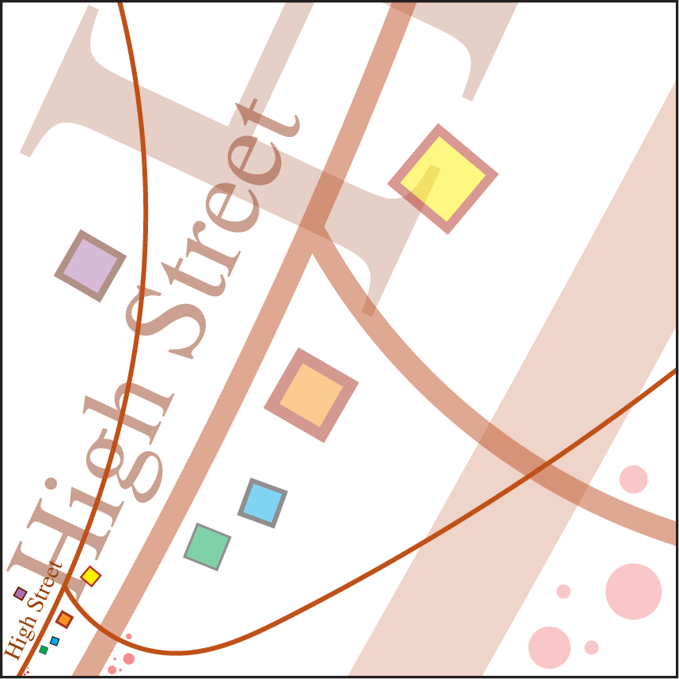

那么放大的秤呢？顺着特里斯特拉姆·尚迪的话说，我来告诉你我在海上遇到的那个竞争姊妹帝国，他们凭借一张远超1：1比例、超现实的宏伟地图赢得了制图大赛，城市地图覆盖整个省份，省份地图覆盖整个帝国。地图上标注了1平方公里的土地，显示植物的细胞结构以及市民笔记本和日记中放大的笔迹细节，仿佛用巨大的笔触在浩瀚画布上书写。事实上，地图上的所有细节本身就是地理特征，需要再次放大，但要更远，因此又要被放大、再远，如此循环。制图师无意中在羊皮纸上滴落的红墨水，先被放大成一个水池，然后变成湖泊，最后如果有人走得够远去寻找它，最后变成了海洋。然而，如果空间是一个无尽的欧几里得平面，那么确实存在足够的空间，使得其上的每个位置都被无限且且常以这种自相似的方式放大。

But what of magnified scales? In keeping with Tristram Shandy, let me tell you of the competing sister empire that I encountered across the sea, having won the Great Contest of Cartography with its own grandiose map at a scale far exceeding 1:1, larger than life, so that the map of the city fills the province and that of the province fills the empire. Each square meter of land is depicted on 1 square kilometer of the Map, which displays the cellular structure of plants and the elaborately magnified details of the handwriting in the citizen’s notebooks and diaries, written as though with enormous brushstrokes on a vast canvas. And indeed all the details of the Map are themselves geographic features to be writ large again, but farther off, and therefore writ even larger *again* still farther off, and so on continually. The cartographer’s accidental drop of red ink on the vellum becomes recorded magnified first as a pool, and then a lake, and then an ocean, if one should venture far enough to find it. Nevertheless, if space is an unending Euclidean plane, then indeed there is space enough that every location on it is recorded infinitely often magnified in this self-similar way.

### **巴别图书馆** **The Library of Babel**

博尔赫斯还提到了“巴别图书馆”，这是一大片由一模一样的六边形画廊组成的布局，由狭窄的通道和螺旋楼梯相连，每个画廊设有四个书架，每层书架各有五个书架;每个书架上摆放着三十五本格式统一的书，每本书正好有410页，每页四十行，每行八十个字母，全部来自同一二十五字符集（如果包括空格、句号和逗号）。图书管理员，每三个展厅各一人，勉强维持生计，但大多数早已离开图书馆或精神失常。人们提出了庞大图书馆的理论：它包含了所有可能的同格式书籍，没有两本是完全相同的。

Borges also relates “The Library of Babel,” a vast arrangement of identical hexagonal galleries, connected by narrow passages and spiral stairways, each gallery having four bookcases of five shelves; upon each shelf sits thirty-five books of uniform format, with each book having exactly 410 pages, each page having forty lines, and each line eighty letters, all from the same twenty-five-character set, if one includes spaces, periods, and commas. The librarians, one for each three galleries, are provided bare subsistence, but most have long abandoned the library or gone insane. One came to formulate the theory of the vast library: that it contained all possible books of that format, no two identical.

从这两个无可辩驳的前提中，他推断出图书馆是完整的，其书架记录了二十多个拼写符号的所有可能组合（虽然数量极其庞大，但并非无限）：一切：未来详尽的历史、大天使的自传、图书馆忠实的目录、成千上万的虚假目录， 证明那些目录的谬误，真实目录的谬误，诺斯替的巴西里德福音，对那福音的注释，对那福音的注释，你死亡的真实故事，所有语言的每一本书的翻译，所有书卷的插入。博尔赫斯（1962年）

From these two incontrovertible premises he deduced that the Library is total and that its shelves register all the possible combinations of the twenty-odd orthographical symbols (a number which, though extremely vast, is not infinite): Everything: the minutely detailed history of the future, the archangels’ autobiographies, the faithful catalogues of the Library, thousands and thousands of false catalogues, the demonstration of the fallacy of those catalogues, the demonstration of the fallacy of the true catalogue, the Gnostic gospel of Basilides, the commentary on that gospel, the commentary on the commentary on that gospel, the true story of your death, the translation of every book in all languages, the interpolations of every book in all books. Borges (1962)

Most of the books, of course, are gibberish—one of them repeats “CVS” over and over for the entire book. But also, no one meaningful book is so precious so as not to be lost, for there are vast numbers of facsimiles, differing from it inconsequentially, perhaps by a single comma or space, or by shifting the text. Yet, there are only finitely many books in total. Each page displays 40 × 80 = 3200 characters, and so each book has 410 × 3200 = 1312000 characters, a little over one million. Since there are 25 possibilities for each character, the number of books is therefore 25<sup>1312000</sup>. A very large number indeed, but not infinite.

奎因写道“宇宙图书馆”，通过二进制符号提出了另一种概念：

Quine writes on the “Universal Library,” offering another conception via binary notation:

有一种更简单、更便宜的减肥方法。......一个由点和划号组成的字体，可以完成我们这80字体的所有工作。......终极荒谬的事实摆在我们面前：一个由两卷组成的通用图书馆，一卷包含一个点，另一个包含一个划号。我们深知，持续重复和交替这两者足以阐明任何真理。有限但普遍的图书馆的奇迹不过是二进制记谱奇迹的膨胀：所有值得说的话，以及其他所有，都可以用两个字符表达。这对《绿野仙踪》来说是个令人失望的作品，但对计算机来说却是一大福音。（奎因，1987，第223页）

There is an easier and cheaper way of cutting down. …a font of two characters, dot and dash, can do all the work of our font of eighty. …The ultimate absurdity is now staring us in the face: a universal library of two volumes, one containing a single dot and the other a dash. Persistent repetition and alternation of the two is sufficient, we well know, for spelling out any and every truth. The miracle of the finite but universal library is a mere inflation of the miracle of binary notation: everything worth saying, and everything else as well, can be said with two characters. It is a letdown befitting the Wizard of Oz, but it has been a boon to computers. (Quine, 1987, p. 223)

### **关于可能的书籍数量** **On the number of possible books**

既然我们讨论的是可能的书的数量，我就给出一个荒谬的论点：实际上，即使不限制长度，可能的书也只有有限。这里说*的书*，让我们理解一件普通的事情：一本书由有限的页面序列组成，每页有一个普通的形式，比如最多100行文字，每行最多包含100个字符，来自固定的有限字符集，页码以普通方式出现在底部， 每页递增。我们不假设书中的页数。

Since we are discussing the number of possible books, let me give the farcical argument that in fact, there are only finitely many possible books, even when one does not restrict the length. By *book*, let us understand something ordinary: a book consists of a finite sequence of pages, where each page has an ordinary form, consisting of, say, at most 100 lines of text, each line having at most 100 characters from a fixed finite character set, and with a page number appearing in the ordinary way at the bottom, incremented with each page. We do not assume anything about the number of pages in the book.

乍一看，这种形式的书可能有无数种，因为我们会得到任意长度的全A书，每页反复出现字母A，B亦然，依此类推。这难道不会催生无数不同的书籍吗？不。我认为，这种形式的书本可能只有有限。关键原因是页码要求，一旦页数变得非常大，如果像我们说的那样“正常方式”写页码，底部就没有足够的空间写页码了。即使允许页码溢出到多行，最终页码也必须用数字填满整页。所以，对于合法出现在页面上的页码，有一个绝对的上限。因此，按照我描述的“书”能包含的页数有一个绝对上限。由于每页出现的字符数量有限，因此该类型的书的可能数量有限。

It might seem at first that there must be infinitely many possible books of this form, for we shall have the all-As book of any desired length, consisting of the letter A over and over again on each page, and similarly with B, and so on. Does this not lead to infinitely many different books? No. I claim that there are only finitely many possible books of the described form. The critical reason is the page number requirement, for once the number of pages becomes very large, there simply will not be enough room to write the page number at the bottom, if one should write it “in the ordinary way,” as we said. Even if one allows the page number to spill onto more than one line, then eventually the page number will have to fill the entire page with its digits. So there is an absolute finite upper bound on how large the page number could be to legally appear on a page. And therefore there is an absolute upper bound on the number of pages that a “book” following my description could include. Since only finitely many characters appear on each page, it follows that there are only finitely many possible books of that type.

与此同时，如果允许非标准页码，比如第一页写1，后面所有页写+1，或者使用“上一页编号后的下一个数字”等短语，论点就会失效。如果允许这样做，那么显然通过让书越来越长，可能的书会无限多。

Meanwhile, the argument breaks down if one allows nonstandard page numbering, such as by writing 1 on the first page and + 1 on all subsequent pages, or using the phrase “the next number after the previous page’s number,” or some such. If this is allowed, then clearly there would be infinitely many possible books by making them longer and longer.

## **3.8 超越等值性，涉及比较大小原则** **3.8 Beyond equinumerosity to the comparative size principle**

虽然康托-休谟原理为我们提供了表达两个集合或类大小相同——它们是等数的——但一个稳健的数量和大小概念也使我们能够做出*比较*大小判断，即说一个集合或类别至少与另一个集合或类别*相当。*为此，我们似乎需要一个严格超越康托尔-休谟原则的原则，比如康托尔所使用的原则：

Although the Cantor-Hume principle provides us with means for expressing that two sets or classes have the same size—they are equinumerous—a robust concept of number and size would enable us also to make *comparative* size judgements, to say that one set or class is *at least as large* as another. For this, we would seem to need a principle going strictly beyond the Cantor-Hume principle, such as the one used by Cantor:

**比较规模原则。** *一个集合的大小小于另一个集合当且仅当第一个集合与第二个集合的子集等数。*

**Comparative size principle.** *One set is less than or equal in size to another if and only if the first set is equinumerous to a subset of the second.*

Let us write *A* ≲ *B* to mean that the set *A* is less than or equal in size to the set *B*. The principle asserts that *A* ≲ *B* exactly when there is an injective function from *A* to *B*:

[figure not shown]

函数 *f* 的值域是 *B* 中 *A 与 A* 等量的子集。

The range of the function *f* is the subset of *B* with which *A* is equinumerous.

比较大小原理实际上是欧几里得原理的自反集合论重述，因为它断言每个集合至少与其任何子集一样大。而严格集合论版本的欧几里得原理则断言每个集合都严格大于其真子集，这一点通过自然数和完美平方等伽利略观察到的例子被康托尔-休谟原则驳斥。

The comparative size principle amounts to a reflexive set-theoretic reformulation of Euclid’s principle, since it is asserting that every set is at least as large as any of its subsets. The strict set-theoretic version of Euclid’s principle, in contrast, asserts that every set is strictly larger than its proper subsets, and this is refuted using the Cantor-Hume principle by examples such as the natural numbers and the perfect squares, as observed by Galileo.

我们在此使用 ≲ 符号带有一些包袱，因为它表明这种比较大小关系将表现出序的性质，或者至少是预序的性质。我们当然希望比较大小关系是有序的——但真的是这样吗？集合上的≲关系很容易看出是自反的，意味着*A*是*A，同时*也是传递的，意味着*A* ≲ *B* ≲ *C*蕴含*A* ≲ C。因此，比较大小关系 ≲ 开始看起来像一个序。然而，一个更微妙的问题是关系≲是否是反对称的。换句话说，如果两个集合至少大小相同，它们的大小是否必须相同？这样说可能会让一些人觉得答案很简单或立刻。但这并非小事。正确的推断正是薛德-康托-伯恩斯坦定理的内容。

Our use of the ≲ symbol here carries some baggage in that it suggests that this comparative size relation will exhibit the properties of an order, or at least a preorder. We certainly want our comparative size relation to be orderlike—but is it? Well, the ≲ relation on sets is easily seen to be reflexive, meaning that *A* ≲ *A*, as well as transitive, meaning that *A* ≲ *B* ≲ *C* implies *A* ≲ *C*. Thus, the comparative size relation ≲ begins to look like an order. A more subtle question, however, is whether the relation ≲ is antisymmetric. In other words, if two sets are at least as large as each other, must they have the same size? That way of saying it may lead some to expect that the answer is trivial or immediate. But it is not trivial. The inference, which is correct, is precisely the content of the Schröder-Cantor-Bernstein theorem.

**定理8（施罗德-康托尔-伯恩斯坦）。** *如果* A ≲ *B 和 B* ≲ *A，则集合 A 和 B 是等等的：A* ≃ *B*。

**Theorem 8 (Schröder-Cantor-Bernstein).** *If A* ≲ *B and B* ≲ *A, then the sets A and B are equinumerous: A* ≃ *B*.

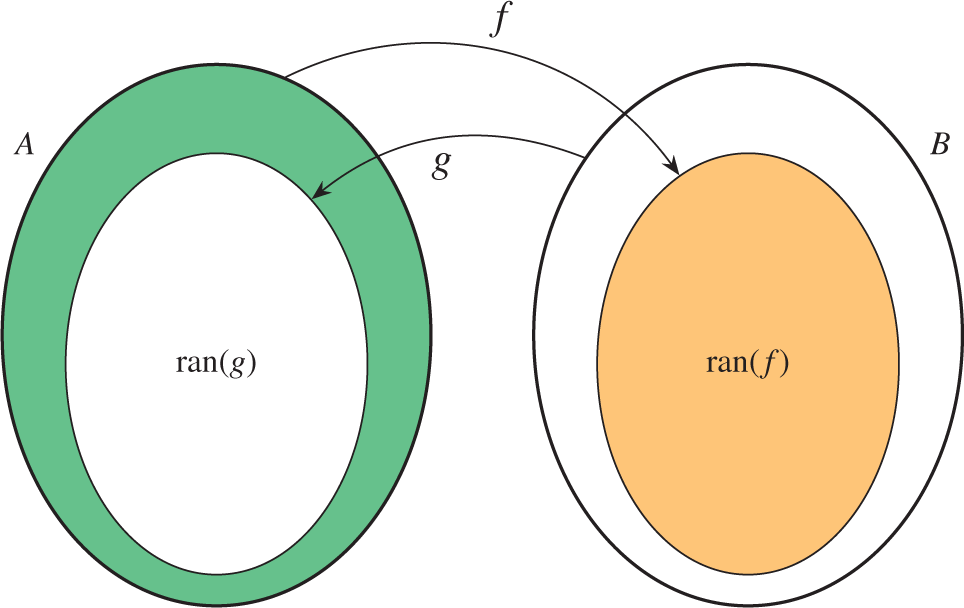

该定理的证明比预期更为复杂，历史复杂。康托尔于1887年提出该理论，未加证;1888年由德德金德证明但未发表;康托尔于1895年证明，但仅通过假设基数的线性性，由恩斯特·施罗德于1896年作为威廉·斯坦利·杰文斯定理的推论证明，1897年又独立证明（但该证明后来被发现有误）。 随后于1897年由费利克斯·伯恩斯坦独立证明。

The theorem, whose proof is subtler than one might expect, has a convoluted history. It was stated by Cantor in 1887 without proof, proved but not published by Dedekind in 1888, proved by Cantor in 1895 but only by assuming the linearity of cardinals, proved by Ernst Schröder in 1896 as a corollary of a theorem of William Stanley Jevons and then again in 1897 independently (but this proof was later found to be faulty), and then proved independently by Felix Bernstein in 1897.

正如康托尔所观察到的，该定理是假设每个集合都可以是良序的直接推论，事实上，该定理仅仅是从所有基数线性顺序为≲的假设中直接推导出来。然而，这一线性假设与选择公理（由弗里德里希·莫里茨·哈托格斯证明）等价，既然证明定理不需要这个额外假设，最好不依赖它。

As Cantor had observed, the theorem is an immediate consequence of the assumption that every set can be well-ordered, and indeed, the theorem follows immediately from the assumption merely that all cardinals are linearly ordered by ≲. This linearity hypothesis, however, turns out to be equivalent to the axiom of choice, as proved by Friedrich Moritz Hartogs, and since one does not need this extra assumption to prove the theorem, it is better to do so without it.

虽然我的主要观点是，这个定理比天真的观点更为微妙，但它并不难证明，任何优秀的集合论教材都能找到它的证明。例如，我在（Hamkins， 2020c，定理117）中基于尤利乌斯·柯尼希（Julius König，1906年）的证明提供了基本证明。

Although my main point is that this theorem is subtler than a naive outlook would lead one to expect, nevertheless the theorem is not so terribly difficult to prove, and one can find a proof of it in any good set theory textbook. For example, I provide an elementary proof in (Hamkins, 2020c, theorem 117) based on the proof of Julius König (1906).

让我举例说明施罗德-康托尔-伯恩斯坦定理的应用，用它来证明实数直线 R 和实平面 R × R 是等等的。什么？疯狂镇！线和平面的点数是一样的吗？没错。我们显然有R ≲ R×R，因为我们可以将实数直线与平面上的任意直线关联。为了证明反之关系，我们只需用一个实数对来编码一对实数。给定平面上的任意一点 （*x， y*） ∈ R × R，设 *z* 为将 *x* 和 *y* 的数字交错在其十进展开中。

Let me illustrate an application of the Schröder-Cantor-Bernstein theorem by using it to prove that the real line ℝ and the real plane ℝ × ℝ are equinumerous. What? Crazytown! The line and the plane have the same number of points? Yes, indeed. We clearly have ℝ ≲ ℝ × ℝ, since we can associate the real line, for example, with any given line in the plane. To prove the converse relation, we merely need to code a pair of real numbers with a single real number. Given any point in the plane (*x, y*) ∈ ℝ × ℝ, let *z* be the real number that interleaves the digits of *x* and *y* in their decimal expansions.

[figure not shown]

有一个令人恼火的问题是某些实数有两个十进制表示，比如1.000...... = 0.999......，因此在交错过程中，我们决定始终使用不以所有9结尾的*x*和*y*表示。结果的映射 （*x， y*） ↦ *z* 是单射的，因为从 *z* 可以恢复 *x* 和 *y* 的小数位数字（注意 *z* 永远不会在所有 9 中结束）。但这种关联并不适用于R，因为非唯一性问题意味着我们永远无法通过这种交错数字实现0.90909090......因此，我们得到的只是 R × R 的单射到 R 中。然而，根据薛罗德-康托尔-伯恩斯坦定理，这足以得出这两个集合是等数的结论。也就是说，虽然我们没有表现出显式一一对应，但我们已经在两个方向都表现出单射，因此该定理提供了双射对应关系。一个本质上类似的论证表明，实数直线 R 在任何有限维或可数维中均与实数空间 <sup>*R n*</sup> 等复数。如前所述（第9页），这一震惊的结果促使康托尔于1877年写信给德德金：“我看到了，但我不相信！”（Dauben，2004，第941页）

There is an irritating issue caused by the fact that some real numbers have two decimal representations, such as with 1.000⋯ = 0.999⋯, and so for the interleaving process, let us decide always to use the representations of *x* and *y* that do not end in all 9s. The resulting map (*x, y*) ↦ *z* is injective, since from *z* we can recover the decimal digits of *x* and *y* (note that *z* will never end in all 9s). But this association is not onto ℝ, since the nonuniqueness issue means that we shall never realize the number 0.90909090⋯ by interleaving digits this way. What we have, therefore, is merely an injection of ℝ × ℝ into ℝ. By the Schröder-Cantor-Bernstein theorem, however, this is enough to conclude that the two sets are equinumerous. That is, although we have not exhibited an explicit one-to-one correspondence, we have exhibited injections in both directions, and so the theorem provides a bijective correspondence. An essentially similar argument shows that the real line ℝ is equinumerous with the real number space ℝ<sup>*n*</sup> in any finite or indeed countable dimension. As mentioned earlier (page 9), this shocking result led Cantor to write to Dedekind in 1877, “I see it, but I don’t believe it!” (Dauben, 2004, p. 941)

### **重点放在反射性预购上** **Place focus on reflexive preorders**

我想讨论一下我在数学或哲学分析从有限领域延伸到无限时，在多次出现绊倒的共同现象。假设我们正在分析一个预序关系，比如大于或至少与 as 大关系，或优于或至少同样良好关系，或与超常性产生的关系，或与基地关系或其他约简概念产生的关系。我所说的问题在于，当人们优先考虑严格版本的顺序而非较弱的反身顺序时。例如，集合论的欧几里得原理断言每个集合严格大于其真部分，因此在严格序下有限集合的扩展思想成立，但该原理在无限领域出现了绊脚石，正如伽利略在自然数和完美平方中所注意到的那样。而反身序的对应原理恰恰是比较尺寸原理，该原理完全精细且与康托尔-休谟原则兼容。类似情况也出现在无限功利主义领域，文献中充斥着严格帕累托原理的各种版本，主张如果每个个体都被严格地变得更好（即使在无限世界中），那么整个世界也严格变得更好。然而，这一原则与非常自然的同构-不变性原理相矛盾，因为它以类似伽利略例子的方式允许反例情形（参见Hamkins 和 Montero 2000a，2000b）。我认为严格的帕累托原理在无穷功利主义领域中的误导和欧几里得的无穷基数原理一样，原因非常相似。与此同时，反身版本的帕累托原理仅断言当所有个体至少同样优秀时，结果世界至少同样优秀，避免了反例，并且与这些同构原则兼容。类似问题在许多其他情形中也会出现，包括涉及各种超额关系、基础和还约关系的案件。因此，在处理哲学预序关系时，我倾向于认为将严格版本的序关系作为主要概念以形成直觉或陈述原则，是一种根本性的错误——通常是初学者的错误。相反，应基于更为稳健的反身秩序关系来制定思想和原则。其中一个原因是，伽利略观察到的类似问题性反例情境会在这些其他无限语境中不断重演。第二个原因是数学观察，通常预序关系的自反版本比严格版本信息更多，也就是说可以从自反顺序定义严格顺序，但反过来则不行，因为给定严格顺序可以由多个自反预序产生（Hamkins， 2020c，第164页）;基本问题在于严格序无法区分无差异性，如 *x* ≤ *y* ≤ *x*，与不可比较性 *x* ⁄ ≤ *y* ⁄ ≤ *x*。因此，自反预序关系比相应的严格序更为基本。因此，为了避免常见的陷阱，请将你的哲学分析重点放在你所研究的预序关系的反身版本上，而非严格的顺序关系。

I should like to discuss what I have observed as a common feature in several instances where a mathematical or philosophical analysis stumbles while extending ideas from the finite realm to the infinite. Suppose we are analyzing a preorder relation, such as the larger-than or at-least-as-large-as relation, or the better-than or at-least-as-good-as relation, or the relations arising with supervenience, or those arising with grounding or some other reduction concept. The problematic feature I have in mind occurs when one gives priority to the strict version of the order over the weaker reflexive order. For example, with the set-theoretic Euclid’s principle, which asserts that every set is strictly larger than its proper parts, one has extended ideas that are true of finite sets for the strict order, but this principle stumbles in the infinite realm, as Galileo noticed with the natural numbers and the perfect squares. The corresponding principle for the reflexive order, meanwhile, is exactly the comparative size principle, which is totally fine and compatible with the Cantor-Hume principle. A similar situation occurs in the subject of infinitary utilitarianism, where the literature is full of versions of the strict Pareto principle, asserting that if every individual is made strictly better off (even in an infinite world), then the world as a whole is strictly better off. This principle, however, contradicts very natural isomorphism-invariance principles by admitting counterexample situations in a manner analogous to Galileo’s examples (see Hamkins and Montero 2000a, 2000b). My view is that the strict Pareto principle is just as misguided in the infinite realm of utiliarianism as Euclid’s principle is for infinite cardinality, for very similar reasons. Meanwhile, the reflexive version of the Pareto principle, which asserts merely that the resulting world is at least as good when all individuals are at least as good, avoids the counterexamples and remains compatible with those isomorphism principles. Similar issues arise in many other instances, including those concerned with various supervenience, grounding, and reduction relations. When working with a philosophical preorder relation, therefore, I tend to regard it as a fundamental mistake—often a kind of beginner’s error—to take the strict version of the order relation as the primary notion for the purpose of forming intuitions or stating one’s principles. One should instead base one’s ideas and principles on the more robust reflexive order relation. One reason is that the same kind of problematic counterexample situations as Galileo observed will continually recur in these other infinitary contexts. A second reason is the mathematical observation that, in general, the reflexive version of a preorder relation carries more information than the strict version of the relation, in the sense that one can define the strict order from the reflexive order, but not conversely, since a given strict order can arise from more than one reflexive preorder (Hamkins, 2020c, p. 164); the basic problem is that the strict order cannot distinguish between indifference, *x* ≤ *y* ≤ *x*, and incomparability, *x* ⁄≤ *y* ⁄≤ *x*. Thus, the reflexive preorder relation is more fundamental than the corresponding strict order. To avoid the common pitfalls, therefore, kindly focus your philosophical analysis on the reflexive version of whatever preorder relation you are studying, rather than on the strict order relation.

## **3.9 什么是康托尔连续统假设？** **3.9 What is Cantor’s continuum hypothesis?**

康托尔对一个有趣的观察感到好奇。也就是说，在数学中，我们似乎有许多可数无限集合的自然实例：

Cantor was intrigued by a curious observation. Namely, in mathematics we seem to have many natural instances of countably infinite sets:

自然数集合N;整数集合Z;有理数集Q;有限二元序列集合 2<sup>*<*N</sup>;整数多项式集合 Z[*x*]。

The set of natural numbers ℕ; the set of integers ℤ; the set of rational numbers ℚ; the set of finite binary sequences 2<sup>*<*ℕ</sup>; the set of integer polynomials ℤ[*x*].

我们似乎也自然地存在许多连续大小集合的实例：

We seem also to have many natural instances of sets of size continuum:

实数集合 R;复数集C;康托空间（无限二进制序列）2<sup>N</sup>;自然*数P*（N）的幂集;连续函数空间 *f*： R → R。

The set of real numbers ℝ; the set of complex numbers ℂ; Cantor space (infinite binary sequences) 2<sup>ℕ</sup>; the power set of the natural numbers *P*(ℕ); the space of continuous functions *f*: ℝ → ℝ.

但我们似乎没有可证明介于N和R之间的中间基数集合。康托尔努力解决自然数与连续统之间是否存在中间基数集合的问题。

But we seem to have no sets provably of intermediate cardinality between ℕ and ℝ. Cantor struggled to settle the question of whether there was a set of intermediate cardinality between the natural numbers and the continuum.

The *continuum hypothesis* (CH), formulated by Cantor, is the assertion that indeed there are no infinities between the countable and the continuum, between the natural numbers ℕ and the real numbers ℝ. Is it true? Is it refutable? The question consumed Cantor. Hilbert had listed the continuum hypothesis as the very first on his famous list of twenty-three open problems at the beginning of the twentieth century, problems that guided so much of the future of mathematical research.

康托尔能够证明连续统假设的许多实例，例如证明它对闭实数集合成立。他本想逐步提升到更复杂的套装。最终证明这是个合理的想法，至少部分如此。例如，可以证明对于Borel集成立，Borel集是指从开集开始、在可数并集、交集和补集下闭合的层级集合中产生的集合。

Cantor was able to prove many instances of the continuum hypothesis, showing, for example, that it holds for closed sets of real numbers. He had wanted to work his way up to more complicated sets. This was ultimately shown to be a sound idea, at least in part. One can prove, for example, that it holds for the Borel sets, the sets arising in the hierarchy of sets starting with the open sets and closing under countable unions, intersections, and complements.

更进一步，20世纪末，集合论者证明，如果存在足够多的大基数满足非常强的无穷公理，那么连续统假设不仅适用于Borel集合，也适用于射影层级中的所有集合。射影层级是通过定义实数集合的语言形成的集合扩张层级，允许基本算术概念和量化对整数和实数。这样，坎托尔的策略部分得以实现。

Going beyond this, in the late twentieth century, set theorists proved that if there are certain sufficient kinds of large cardinals that fulfill very strong axioms of infinity, then indeed the continuum hypothesis holds not only for the Borel sets, but for all sets in the projective hierarchy, which is the expansive hierarchy of sets that you can form by defining sets of real numbers in a language that allows basic arithmetic concepts and quantification over the integers and over the real numbers. In this way, Cantor’s strategy was partially fulfilled.

哥德尔于1938年证明，如果ZF集合论的公理是一致的，那么它们也与连续统假设和选择公理一致。因此，不能指望反驳这些原则，从这个意义上说，可以安全地假设它们是真实的。这一结果解释了为何康托尔未能找到N和R之间确定的中间基数集合，因为集合论中不存在这样的集合是一致的。

Gödel proved in 1938 that if the axioms of ZF set theory are consistent, then they are also consistent with the continuum hypothesis and the axiom of choice. Thus, one cannot expect to refute these principles, and in this sense, it is safe to assume that they are true. This result explains why Cantor was not able to find a definitive set of intermediate cardinality between ℕ and ℝ, since it is consistent with set theory that there is no such set.

科恩于1963年证明，如果ZF集合论的公理是一致的，那么它们也与选择公理和连续统假设的*否定*一致。从这个意义上说，也可以安全地假设连续统假设是错误的。这一结果或许能解释康托尔为何始终未能证明其为真，因为与集合论公理一致，这与其不成立是一致的;反驳观点是，康托尔并非在正式体系中工作。我们将在第8章重新探讨这些集合论思想。

Cohen proved in 1963 that if the axioms of ZF set theory are consistent, then they are also consistent together with the axiom of choice and the *negation* of the continuum hypothesis. In this sense, it is also safe to assume that the continuum hypothesis is false. This result may explain why Cantor was never able to find a proof that it was true, since it is consistent with the axioms of set theory that it is not; a counterpoint is that Cantor was not working in a formal system. We shall revisit these set-theoretic ideas in chapter 8.

## **3.10 超限基数——阿勒夫和贝斯** **3.10 Transfinite cardinals—the alephs and the beths**

现在让我们进一步阐述康托尔的超限理论。我们已经看到康托尔的论证表明无限大大小的无限，事实上，无限大小的数量比任何给定的无限还多。

Let us now develop a little more of Cantor’s theory of the transfinite. We have already seen that Cantor’s argument shows that there are infinitely many different sizes of infinity, and indeed there are more different sizes of infinity than any given infinity.

康托尔通过从最小的无限大א 0（自然数或任意可数无限集合的大小）开始定义无限基数序列，更一般地将<sub>*א α*</sub>定义为*第α*个无限基数，从而得到无限基数序列：

Cantor defined the sequence of infinite cardinals by starting with the smallest infinity, ℵ<sub>0</sub>, which is the size of the natural numbers or any countably infinite set, and more generally defining ℵ<sub>*α*</sub> to be the *α*th infinite cardinality, leading to the sequence of infinite cardinalities:

[figure not shown]

基数<sub>*א ω*</sub> 是有限数 *n* 的基数א<sub>*n*</sub> 的上确界。这个基数看起来可能相当大，因为它是不可数的，并且比无数其他不可数基数还要大;事实上，它是一个*极限基数*，这意味着不存在紧邻的无穷大。

The cardinal ℵ<sub>*ω*</sub> is the supremum of the cardinals ℵ<sub>*n*</sub> for finite numbers *n*. This cardinal may seem quite large, as it is uncountable and larger than infinitely many other uncountable cardinals; indeed, it is a *limit cardinal*, which means that there is no immediately preceding infinity.

与此同时，基数<sub>*א ω*</sub>还有另一个有趣的性质，这可能使其看起来相对易接近。也就是说，因为它是 *n < ω* <sub>中基</sub>数 n א 的上确界，因此它是*奇异*基数，是相对较小基数集合的上确界。也就是说，א<sub>*ω*</sub> 是一个大小小于 א<sub>*ω*</sub> 的集合，该集合由大小小于<sub>*א ω*</sub> 的基数组成。有了这个阶梯，我们可以轻松攀升至א<sub>*ω*</sub>。注意，基数א<sub>0</sub>，与可数无限基数相反，是一个*正则*基数，不存在这样的相对较短阶梯：每个有限有限数序列都有有限上确界。从这个意义上说，基数א<sub>0</sub>是无法从下方访问的。

Meanwhile, the cardinal ℵ<sub>*ω*</sub> has another curious property, which may make it seem comparatively accessible. Namely, because it is the supremum of the cardinals ℵ<sub>*n*</sub> for *n < ω*, it is therefore a *singular* cardinal, the supremum of a comparatively small set of comparatively small cardinals. That is, ℵ<sub>*ω*</sub> is the supremum of a set of size less than ℵ<sub>*ω*</sub> consisting of cardinals each of size less than ℵ<sub>*ω*</sub>. With this ladder, we thus climb easily up to ℵ<sub>*ω*</sub>. Notice that the cardinal ℵ<sub>0</sub>, in contrast, the countably infinite cardinality, is a *regular* cardinal, one that admits no such comparatively short ladder: every finite sequence of finite numbers has a finite supremum. In this sense, the cardinal ℵ<sub>0</sub> is inaccessible from below.

康托尔还考虑了基数的另一种相关层级结构——*贝斯层级，该层级*通过在每一步迭代幂集运算而产生：

Cantor also considered the alternative related hierarchy of cardinals, the *beth hierarchy*, which arises by iterating the power set operation at each step:

[figure not shown]

我们从最小的无限基数 ב<sub>0</sub> = א<sub>0</sub> 开始，在每个阶段应用幂集运算 <sub>*ב α*+1</sub> = 2<sup>ב<sub>*α*</sub></sup>，在极限阶段取上确界。

We start with the smallest infinite cardinal ℶ<sub>0</sub> = ℵ<sub>0</sub>, and at each stage, we apply the power set operation ℶ<sub>*α*+1</sub> = 2<sup>ℶ<sub>*α*</sub></sup>, taking suprema at limit stages.

连续统假设的主张是，א<sub>1</sub>和ב<sub>1</sub>是同一个无限基数，我们主要的生成不可数基数的方法——取一个可数无限集合的幂集——恰好也会产生下一个不可数基数。更一般地说，*广义连续统假设*是断言两个层级在上层是相同的，即每个序数*α* א<sub>*α*</sub> = ב<sub>*α*</sub>。

The continuum hypothesis amounts to the assertion that ℵ<sub>1</sub> and ℶ<sub>1</sub> are the same infinite cardinal, that our principal method of producing uncountable cardinalities—taking the power set of a countably infinite set—also happens to produce the very next uncountable cardinality. More generally, the *generalized continuum hypothesis* is the assertion that the two hierarchies are identical all the way up, that ℵ<sub>*α*</sub> = ℶ<sub>*α*</sub> for every ordinal *α*.

基数 <sub>*ב ω*</sub> 非常有趣，因为它是一个*强极限*基数，意味着它在幂集运算下是闭合的，即每个大小ב小于 <sub>*ω*</sub> 的集合的幂集大小也小于 <sub>*ב Ω*</sub>;这是因为如果一个集合的大小小于ב<sub>*Ω*</sub>，那么它对某个自然数*n*的最大大小为ב<sub>*n*</sub>，在这种情况下，它的幂集大小最多为<sub>*ב n*+1</sub>，小于ב<sub>*ω*</sub>。从这个意义上说，基数ב<sub>*ω*</sub>无法通过幂集被访问。然而，像<sub>*א ω*</sub> 一样，它是奇异的;它允许一个短梯子，一个短共终序列，因为它是 *n < ω* 中 ב<sub>*N*</sub> 的上确界，使其成为一小组小基数的上确界。

The cardinal ℶ<sub>*ω*</sub> is quite interesting, for it is a *strong limit* cardinal, meaning that it is closed under the power set operation, in that every set of size less than ℶ<sub>*ω*</sub> has its power set also of size less than ℶ<sub>*ω*</sub>; this is because if a set has size less than ℶ<sub>*ω*</sub>, then it has size at most ℶ<sub>*n*</sub> for some natural number *n*, in which case its power set has size at most ℶ<sub>*n*+1</sub>, which is smaller than ℶ<sub>*ω*</sub>. In this sense, the cardinal ℶ<sub>*ω*</sub> is inaccessible by means of power sets. Yet, like ℵ<sub>*ω*</sub>, it is singular; it admits a short ladder, a short cofinal sequence, for it is the supremum of the ℶ<sub>*n*</sub> for *n < ω*, making it the supremum of a small set of small cardinals.

真的有可能存在*一位真正难以接近的*枢机主教吗？这将是一个不可数基数*κ*，它（1）不可被幂集访问，即每个大小小*于κ*的集合也都有其大小小*于κ*的幂集;但（2）一个正则基数，即不允许短共终序列、不包含少*于κ*个且每个大小小*于κ*的基数序列，且其上确界为*κ*。最小的无穷א<sub>0虽然可</sub>数，但具有后两者性质，因为有限集的幂集是有限的，有限基数序列的上确界也是有限的。因此，要求一个不可达基数就是请求一个更高的无穷，即一个不可数基数，它像 א<sub>0</sub> 一样，看向较小的基数，包括<sub>א 0</sub>。这真的有可能发生吗？

Could there be a truly *inaccessible* cardinal? This would be an uncountable cardinal *κ* that was (1) inaccessible by power sets, in that every set of size less than *κ* also had its power set of size less than *κ*; but also (2) a regular cardinal, one admitting no short cofinal sequence, no sequence of fewer than *κ* many cardinals, each of size less than *κ*, whose supremum was *κ*. The smallest infinity ℵ<sub>0</sub>, although countable, has both of those latter properties since the power set of a finite set is finite and the supremum of a finite sequence of finite cardinals is also finite. Thus, to ask for an inaccessible cardinal is to ask for a higher infinity, an uncountable cardinal that looks to the smaller cardinals, including ℵ<sub>0</sub>, just as ℵ<sub>0</sub> looks to the finite cardinals. Can it happen?

答案复杂而引人入胜，我们将在第八章讲述这个故事。存在不可达基数的假设是最早的大*基*数公理之一，即强无穷公理，假设存在具有某些精确大度特征的无限基数。大基数公理是数学中已知最强的公理。

The answer is complex and fascinating, a story that we shall tell in chapter 8. The hypothesis that there is an inaccessible cardinal is one of the first *large cardinal* axioms, a strong axiom of infinity, hypothesizing the existence of an infinite cardinality with certain precise largeness features. The large cardinal axioms are the strongest-known axioms in mathematics.

### **Lewis论对象数量和性质** **Lewis on the number of objects and properties**

在罗素关于命题数量的观察基础上，大卫·刘易斯探讨了双重问题：有多少事物？那么，事物有多少属性？他分别给出了至少第<sub>2</sub> ב和第<sub>3</sub> ב出人意料的准确答案。让我试着重建他的推理。假设我们所处的实际物理时空，正如我们的物理理论中，由实数很好地建模出来。（这很容易被质疑;物理学家不必将他们的物理模型完全视为物理真实;经济学家用实值微分方程来建模人类经济行为，即使他们承认最终是一个离散系统，有限人做出有限多的选择;同样，物理学家也可能最终认为空间或时间是有限且离散的。）因此，空间或时空位置的数量即为连续统，即实数的基数，记作任一 ב<sub>1</sub> = 2<sup>א<sub>0</sub></sup> = |R|= c。任何一组空间点都是一个空间*区域*，我们可以将其视为一个“物体”。所以，事物的数量至少等于实数集合的数量，这也是2<sup>ב<sub>1</sub></sup>，和ב<sub>2</sub>一样。所以至少ב<sub>两</sub>件事。如果任何事物由其所处的时空点集合决定，这些点在空间和时间上都被扩展，那么我们也会反过来知道，事物的数量最多是时空点的集合数，因此事物的数量正*好*是<sub>ב 2</sub>。然而，许多哲学家会质疑这一假设，因为经典例子如雕像和泥块，这两个不同物体占据同一位置;基特·法恩（2003）通过在模具中形成合金来创造雕像，使“合金”和“雕像”在空间和时间上重合，但它们是不同的，因为可能一个做得很好，另一个不然。

Expanding on Russell’s observations concerning the number of propositions, David Lewis considers the dual problems: How many things are there? And then, how many properties of things are there? He offers the surprisingly precise answers of at least ℶ<sub>2</sub> and ℶ<sub>3</sub>, respectively. Let me try to reconstruct his reasoning. Let us assume that the actual physical space and spacetime that we inhabit is well modeled, as in our physical theories, by the real numbers. (This is easily debatable; physicists need not take their physical models to be fully physically real; economists model human economic behavior with real-valued differential equations, even if they recognize that ultimately it is a discrete system, with finitely many people making finitely many choices; similarly, physicists might ultimately hold that space or time is finite and discrete.) The number of spatial or spacetime locations, therefore, would be the continuum, the cardinality of the real numbers, denoted by any of ℶ<sub>1</sub> = 2<sup>ℵ<sub>0</sub></sup> = |ℝ| = 𝔠. Any set of spatial points is a spatial *region*, which we may take to be a “thing.” And so the number of things is at least the number of sets of real numbers, and this is 2<sup>ℶ<sub>1</sub></sup>, the same as ℶ<sub>2</sub>. So there are at least ℶ<sub>2</sub> many things. If any thing is determined by the collection of spacetime points that it inhabits, extended in both space and time, then we would also know conversely that the number of things was at most the number of sets of spacetime points, and so the number of things would be *exactly* ℶ<sub>2</sub>. Many philosophers would dispute that presumption, however, in light of classical examples such as the statue and the lump of clay, distinct things occupying the same location; and Kit Fine (2003) creates a statue by forming an alloy in a mold, so that “the alloy” and “the statue” coincide spatially and temporally, but they are different things, since perhaps one is well made and the other not.

关于性质，刘易斯写道：

As for properties, Lewis writes:

任何一类事物，无论多么划分、杂乱无章、思想和语言难以描述，或是多余地描述世界，它依然是一种属性。因此，这里有大量大量地产。（如果事物的数量，无论实际还是其他，都是beth-2，我认为这个估计更可能是低而非高，那么事物的属性数量是beth-3。这确实是一个巨大的无限，除非对集合论的外围研究者例外。）有太多属性，以至于那些可以用英语或大脑语言中描述的突触相互连接和神经尖峰的属性，可能只是极其微小的少数。（刘易斯，1983，第346页）

Any class of things, be it ever so gerrymandered and miscellaneous and indescribable in thought and language, and be it ever so superfluous in characterising the world, is nevertheless a property. So there are properties in immense abundance. (If the number of things, actual and otherwise, is beth-2, an estimate I regard as more likely low than high, then the number of properties of things is beth-3. And that is a big infinity indeed, except to students of the outer reaches of set theory.) There are so many properties that those specifiable in English, or in the brain’s language of synaptic interconnections and neural spikes, could be only an infinitesimal minority. (Lewis, 1983, p. 346)

因此，他论证了如果存在<sub>2</sub> ב许多事物，且任意一组事物决定一个性质，那么至少存在2个<sup>ב</sup> 2个多性质，这恰恰ב<sub>3</sub>。在其他研究中，他考虑了可能世界的数量，并得出结论：它也是ב<sub>2</sub>：

Thus, he is arguing that if there are ℶ<sub>2</sub> many things, and any set of things determines a property, then there are at least 2<sup>ℶ<sub>2</sub></sup> many properties, and this is precisely ℶ<sub>3</sub>. In other work, he considers the number of possible worlds, concluding that it also is ℶ<sub>2</sub>:

我们可能会问，归纳欺骗世界与非欺骗世界相比，它们的数量如何？如果这是基数的比较，那么很明显两个数字是相等的。对于欺骗性和非欺骗性世界，设置beth-two（即在时空点连续体上具有二值大小分布的数量）的下界都很容易;而且很难有力地证明有更高的基数。（刘易斯，1986，第118页）

We might ask how the inductively deceptive worlds compare in abundance to the undeceptive worlds. If this is meant as a comparison of cardinalities, it seems clear that the numbers will be equal. For deceptive and undeceptive worlds alike, it is easy to set a lower bound of beth-two, the number of distributions of a two-valued magnitude over a continuum of spacetime points; and hard to make a firm case for any higher cardinality. (Lewis, 1986, p. 118)

## **3.11 泽诺悖论** **3.11 Zeno’s paradox**

我们迄今为止对无限的讨论大多可以从当代的角度来看待，将无限集合视为数学景观中的普通部分。但让我们简单提一下一些关于无限的其他早期观点。

Most of our discussion of infinity so far can be taken under a certain contemporary perspective on infinity, viewing infinite sets as an ordinary part of the mathematical landscape. But let us briefly mention some other older perspectives on infinity.

埃利亚的芝诺（约公元前490–430年）认为所有运动都是不可能的，因为在你从这里移动到那里之前，必须先走到一半，但在你做这件事之前，你必须走到一半到那个点，如此循环。因此，他得出结论，你永远无法开始。同样，阿基琉斯在他们的赛跑中永远无法超越，因为在此之前，他必须先到达所在的位置，但在此期间，已经继续前进，当阿基琉斯到达*那*个点时，又再次继续前进，永无止境。所以阿基琉斯永远抓不到。你怎么看这些矛盾的论点？

Zeno of Elea (c. 490–430 BC) argued that all motion is impossible because before you move from here to there, you must get halfway, but before you do this, you must get halfway to the halfway point, and before you do *this*, you must get halfway to that point, and so on, ad infinitum. Thus, he concluded, you can never begin. Similarly, Achilles can never overtake the tortoise in their footrace, because before doing so, he must get to where the tortoise was, but during this time, the tortoise has moved on, and when Achilles reaches *that* point, the tortoise has moved on yet again, ad infinitum. So Achilles can never catch the tortoise. What do you think of these paradoxical arguments?

许多数学家认为这些问题可以通过微积分的思想得到令人满意的解决。积分演算特别是基于这样一个思想：可以通过将有限面积划分为依次的小矩形，并取这些面积的极限来计算。同样，标准的无限级数极限定分析直接与泽诺相对，认为可以加总一个无限数级数，例如：

Many mathematicians take them to be satisfactorily resolved by the ideas of calculus. The integral calculus, in particular, is founded on the idea that one may calculate a finite area by dividing it into successively tiny rectangles and taking a limit of those resulting areas. Similarly, the standard limit analysis of infinite series says, directly in opposition to Zeno, that one can add up an infinite series of numbers, such as

[figure not shown]

但仍然能获得有限的总和。在这种情况下，级数的和为1，这一事实为

and nevertheless achieve a finite sum. In this case, the series sums to 1, a fact that

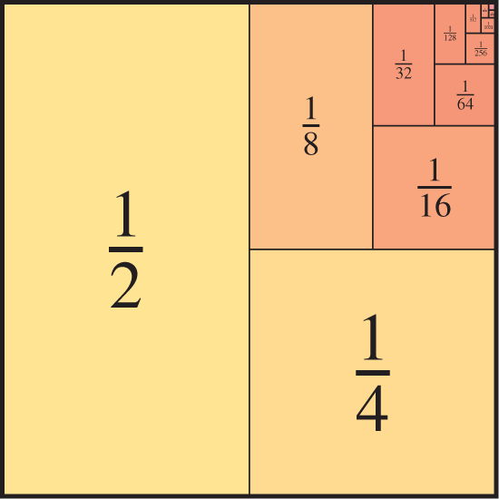

可以通过这里的图示来可视化。整个单位方块的面积为一。该区域被划分为更小的区域，如此类推。由于这些区域耗尽了平方，因此级数的和为1。

### **实际无穷大与潜在无穷** **Actual versus potential infinity**

另一个关于无限的历史观点是亚里士多德区分实际无限与仅潜在无限。在古代，潜能主义者占主导地位，但现在大多数数学家都是实在主义者。*潜在论*者仅在无限潜能的意义上将无限集合视为无限。无限集合可以拥有越来越多的成员，数量（有限多）可以任意多，但将它们作为一个完整的无限整体是不合理的。自然数有无限多，因此永远不会用完;我们永远不可能拥有所有的。相比之下，*实在主义*者声称将无限集合作为完成的整体构成。实在论者将所有自然数的集合视为完备整体，并且可能继续声称其他无限集合，如所有实数的集合，也称为完备整体。

Another historical idea concerning infinity is Aristotle’s distinction between actual and merely potential infinity. In ancient times, potentialists predominated, but now most mathematicians are actualists. The *potentialist* regards infinite collections as infinite only in a sense of unending potentiality. One can have more and more members of an infinite collection, as many (finitely many) as one likes, but it is not sensible to have them as a completed infinite totality. There are infinitely many natural numbers, in that one will never run out of them; we can never have all of them. The *actualist*, in contrast, claims to form infinite collections as completed totalities. The actualist considers the set of all natural numbers as a finished whole, and furthermore may go on to claim other infinite collections, such as the set of all real numbers, as completed totalities.

## **3.12 如何计数** **3.12 How to count**

让我们以学习如何计数到超限序数来结束本章。这是一项任何人都能掌握的任务。序数如你所料，以自然数开头：

Let us conclude this chapter by learning how to count into the transfinite ordinals. This is a task that anyone can master. The ordinal numbers begin as you might expect, with the natural numbers:

[figure not shown]

但序数会超越这些有限数。第一个无限序数称为*ω*，紧接着所有有限数，如下：

But the ordinals continue beyond these finite numbers. The first infinite ordinal is known as *ω*, and it comes immediately after all the finite numbers, like this:

[figure not shown]

序数*ω*是*极限*序数，因为它没有直接的前驱，且较小序数的集合在后继运算下是闭合的。在任意序数之后，总可以加上1，然后再加1，依此类推：

The ordinal *ω* is a *limit* ordinal, since it has no immediate predecessor, and the set of smaller ordinals is closed under the successor operation. After any ordinal, one can always add 1, and then another 1, and so on:

[figure not shown]

从这个角度看，无论从哪里开始，序数看起来都一样。在对每个有限数*n*穷尽*ω* + *n*后，最终得到*ω* + *ω*，也可写作*ω* ·2. *这是ω之后*的下一个极限序数：

From this perspective, the ordinals look the same going forward, no matter where you start. After one has exhausted *ω* + *n* for every finite number *n*, one finally gets to *ω* + *ω*, which can also be written as *ω* · 2. This is the next limit ordinal after *ω*:

[figure not shown]

之后继续加1，最终达到*ω*·3及以后：

After this, one continues adding 1, eventually reaching *ω* · 3 and beyond:

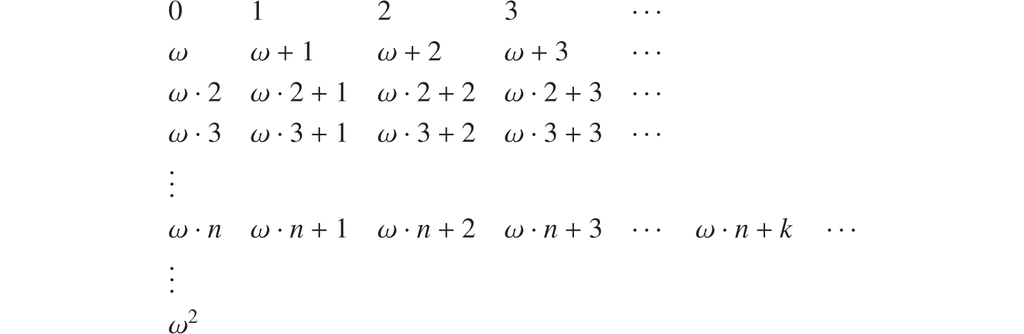

因此，我们通过所有形如*ω*·的序数，计数到*ω*<sup>2</sup>*n* + *k*，其中 *n* 和 *k* 是有限的。序数*ω*<sup>2</sup>是第一个极限序数的极限序数，因为*ω*<sup>2</sup>是*ω*·*n*，随着 *n* 在 *ω* 中增加。

Thus, we have counted up to *ω*<sup>2</sup>, through all the ordinals of the form *ω* ·*n* + *k*, where *n* and *k* are finite. The ordinal *ω*<sup>2</sup> is the first limit ordinal that is a limit of limit ordinals, since *ω*<sup>2</sup> is the limit of *ω* · *n* as *n* increases in *ω*.

数到*ω*<sup>2</sup>就像数到100。数到100时，实际上是数到10，但次数是10次;一个世纪相当于十个十年，而在一个十年内计数，本质上是在同一个十年内计数。在序数中计数到*ω*<sup>2</sup>的过程类似，只不过“十号”长度为*ω*，且*有ω。*因此，共数到 *ω* 的 *ω* 次。该类比是稳健的，对于*序数ω* ·*n* + *k* 恰好是 *ω* 为底的两位数序数。所以，数到 *ω*<sup>2</sup> 就是在计数所有两位数序数，就像数到 100 一样。

Counting up to *ω*<sup>2</sup> is rather like counting to 100. In counting to 100, one essentially counts to 10, but 10 times; a century is 10 decades, and counting within one decade is essentially the same as counting within another decade. Counting in the ordinals up to *ω*<sup>2</sup> is just like this, except that the “decades” have length *ω* and there are *ω* many of them. So, one counts to *ω* altogether *ω* times. The analogy is robust, for the ordinal numbers *ω* ·*n* + *k* are precisely the two-digit ordinal numbers, in base *ω*. So counting to *ω*<sup>2</sup> is counting through all the two-digit ordinals numbers, just like counting to 100.

但当然，序数远远超出*ω2*。它们继续推向*ω*的高次方，如下：

But of course, the ordinals continue far beyond *ω*<sup>2</sup>. They continue into the higher powers of *ω* like this:

[figure not shown]

然后进入迭代幂和幂的不动点：

And then into the iterated powers and the fixed points of the powers:

[figure not shown]

序数*ε*<sub>0</sub>*是ω*<sup>*ε*<sub>0</sub></sup> = *ε*<sub>0</sub>的最小序数，可以看作是无限次迭代的幂，这也解释了为什么*ω*<sup>*ε*<sub>0</sub></sup> = *ε*<sub>0</sub>：

The ordinal *ε*<sub>0</sub> is the smallest ordinal for which *ω*<sup>*ε*<sub>0</sub></sup> = *ε*<sub>0</sub>, and it can be thought of as the infinitely iterated power, which explains why *ω*<sup>*ε*<sub>0</sub></sup> = *ε*<sub>0</sub>:

[figure not shown]

之后，加1继续，*ε*<sub>1是</sub>该操作的下一个不动点。最终，人们会到达*ε*过程本身的不动点。序数*ω*Ch 1是*国际象棋的欧米伽一*，是无限国际象棋中局面中出现的博弈值的上确界，该值由Evans和Hamkins（2014）提出。序数*ω*<sub>1</sub><sup>*CK*</sup>是丘奇-克莱尼序数，它是作为可计算关系中自然数上序型产生的序数的上确界。

After this, one adds 1 and continues, and *ε*<sub>1</sub> is the next fixed point of this operation. Eventually, one gets to fixed points of the *ε*-process itself. The ordinal *ω*ℭ𝔥 1 is the *omega one of chess*, which is the supremum of the game values that arise for positions in infinite chess, introduced in Evans and Hamkins (2014). The ordinal *ω*<sub>1</sub><sup>*CK*</sup> is the Church-Kleene ordinal, which is the supremum of the ordinals that arise as the order type of a computable relation on the natural numbers.

虽然这些序数都非常大，但它们仍然只是可数序数，但超限序数会延续到不可数领域：

Although all very large, these ordinals are all still merely countable ordinals, but the transfinite ordinals continue into uncountable realms:

[figure not shown]

序数*ω*<sub>1</sub>是第一个不可数序数，*ω*<sub>2</sub>是下一个，依此类推。当然，点最终无法传达主题的详实细节，而我在这里只是略作暗示。在序数中往上移动，可以达到更大的无穷大，最终可能达到集合论中的各种大型基数，如不可达基数、马洛基数、可测基数、超紧基数等。序数无休止地继续，像沙粒一样穿过超限沙漏。

The ordinal *ω*<sub>1</sub> is the first uncountable ordinal, *ω*<sub>2</sub> is the next one, and so on. Dots and more dots, of course, ultimately fail to convey the robust details of the subject, which I have merely hinted at here. Moving higher in the ordinals, one reaches much larger infinities, perhaps eventually reaching various large cardinals of set theory, such as inaccessible cardinals, Mahlo cardinals, measurable cardinals, supercompact cardinals, and more. The ordinals continue on and on and on without end, falling like grains of sand through the transfinite hourglass.

既然本章讨论了建设性和非建设性的证据，我想以推特用户“隔离他们”（2020）的俏皮主张作为结尾，完整呈现：

Since we discussed constructive and nonconstructive proof in this chapter, I should like to close with the playful claim of Twitter user Quarantine ’em (2020), in its entirety:

关于非建构性证明，有一个非常棒的笑话。

There’s a really great joke about non-constructive proofs.

## **进一步思考的问题** **Questions for further thought**

**3.1** 假设客人以本章所述的方式抵达希尔伯特的大酒店：先有一位客人到达，然后一千人同时抵达，然后是希尔伯特的公交车，接着是希尔伯特的火车，最后是希尔伯特的半程马拉松。如果经理遵循了本章提到的程序，请描述0到100号房间的住户。他们是怎么到的，和哪个队伍一起？如果他们是坐火车还是公交车到达，他们到达时坐在哪个车厢或座位上？他们在马拉松中穿了哪一部分？如果你是第一个到达的客人，最终你会去哪里？你楼上第一个有人住的房间是什么？那位客人是怎么来的？

**3.1** Suppose that guests arrived at Hilbert’s Grand Hotel in the manner described in this chapter: first one guest arrives, and then 1000 all at once, and then Hilbert’s bus, followed by Hilbert’s train, and finally Hilbert’s half-marathon. If the manager followed the procedure mentioned in the chapter, describe who are the occupants of rooms 0 through 100. How did they arrive, and with which party? In which car or seat were they when they arrived if they arrived by train or bus? Which fraction did they wear in the marathon? If you were the very first guest to arrive, where do you end up in the end? And what is the first room above you that is occupied? How did that guest arrive?

**3.2** 在希尔伯特大酒店街上是希尔伯特立方合作公寓综合体，这是一座无限立方体建筑，类似于N × N ×N，每个住户的住处可以用楼层编号*N*、走廊编号*h*和走廊*r*来描述。由于室内房间光线极少，整个合作社都想搬到希尔伯特的酒店。经理如何照顾他们？

**3.2** Down the street from Hilbert’s Grand Hotel is Hilbert’s Cubical Co-op apartment complex, which is an infinite cubical building, like ℕ × ℕ × ℕ, where every occupant’s residence can be described by a floor number *n*, a hallway number *h*, and a corridor *r*. Because the interior rooms have very little light, the entire cooperative wants to move to Hilbert’s hotel. How can the manager accommodate them?

**3.3** 你能直接论证所有无限二进制序列的集合是不可数的吗？

**3.3** Can you give a direct argument that the set of all infinite binary sequences is uncountable?

**3.4** 你能论证空间 R<sup>3</sup> 的点数与实数线 R 相同吗？同样，在任何有限维中：R<sup>*n*</sup> 与 R 等群。你能否通过归纳法，从R ≃ R<sup>2</sup>推导出来，平滑地论证这一点？[提示：证明如果*A*和*B*等于，那么*A*×*C*和*B*也是等数，×*C*。]无限维度呢？

**3.4** Can you argue that space ℝ<sup>3</sup> has the same number of points as the real number line ℝ? And similarly in any finite dimension: ℝ<sup>*n*</sup> is equinumerous with ℝ. Can you argue this smoothly by induction, as a consequence from ℝ ≃ ℝ<sup>2</sup>? [Hint: Show that if *A* and *B* are equinumerous, then so are *A* × *C* and *B* × *C*.] What about infinite dimension?

**3.5** 实数上的连续函数有多少？

**3.5** How many continuous functions on the real numbers are there?

**3.6** 假设空间已用实数良好建模。空间有多少区域？有多少个开放的太空区域？（如果你熟悉实数的Borel集，有多少个Borel集？）你对这些问题的回答是否与刘易斯关于房产数量和物品数量的计算有关？

**3.6** Assume that space is well modeled with the real numbers. How many regions of space are there? How many open regions of space are there? (If you are familiar with the Borel sets of real numbers, how many Borel sets are there?) Are your answers to these questions relevant to Lewis’s calculation on the number of properties and the number of things?

**3.7** 从基数角度看，实数上的整数函数更多，还是整数上的实值函数？

**3.7** In terms of cardinality, are there more integer-valued functions on the real numbers, or real-valued functions on the integers?

**3.8** 伽利略的萨尔维亚蒂似乎认为，对于大小、大于与小于等价的关系来说，无限集合之间的大小比较并不合理。那么，大小大小与大小大小的比较又如何呢？Salviati能否认为每个集合至少与其子集一样大？Salviati能否认定每套棋子的大小都与自身相同？

**3.8** Galileo’s Salviati seems to hold that size comparisons between infinite collections are not sensible, at least for the relations of equality, greater-than, and less-than. But what about less-or-equal and greater-than-or-equal size comparisons? Can Salviati hold that every set is at least as large as its subsets? And can Salviati hold that every set is the same size as itself?

**3.9** 康托尔如何回应伽利略（通过萨尔维亚蒂）提出的无限集合间的大小比较不合理？坎托尔如何定义这种体型比较？

**3.9** How does Cantor reply to Galileo’s suggestion (via Salviati) that size comparisons between infinite collections are not sensible? How does Cantor define such size comparisons?

**3.10** 假设我们有无限多的台球和一个空袋，你进行以下过程：第一分钟，你把两个球放进袋子里，取出其中一个;接下来的半分钟内，你再往袋子里放两个球，并取出一个球;接下来的四分之一分钟内，你再往袋子里放两个球，并从袋子里取出一个球;诸如此类。两分钟后，你已经完成了无数次这样的交换。那时候袋子里有多少个球？移除哪颗球重要吗？假设球编号为1、2、3，依此类推，每一步你都会取出并丢弃袋中编号最小的球。然后呢？或者假设你总是去掉编号最大的那个？或者假设你随机取出一个球？

**3.10** Suppose that we have a supply of infinitely many billiard balls and an empty sack, and you undertake the following process: In the first minute, you place two balls into the sack, and remove one of them; in the next half-minute, you place two more balls in the sack, and remove a ball; in the succeeding quarter-minute, you place two more balls in the sack and remove one ball from the sack; and so on. After two minutes, you have completed infinitely many such exchanges. How many balls are in the sack at that time? Does it matter which ball is removed? Let us imagine that the balls are numbered 1, 2, 3, and so on, and that at each step, you always remove and discard the lowest-numbered ball currently in the sack. What then? Or suppose you always remove the largest-numbered ball? Or suppose you remove a random ball?

**3.11** 论证对于任何水果集合，可以做的水果沙拉数量比水果多。指出你的论证、文本中关于可能委员会数量的论证，以及康托尔证明每个集合*X*的大小严格小于其幂集*P*（*X*）之间的具体相似点。如果你熟悉罗素悖论（见第8章），也要确认这些论证与罗素悖论的具体相似性。

**3.11** Argue that for any collection of fruit, there are more possible fruit salads to make than there are fruits. Identify the precise similarities amongst your argument, the argument in the text concerning the number of possible committees, and Cantor’s proof that every set *X* is strictly smaller in size than its power set *P*(*X*). If you are familiar with the Russell paradox (see chapter 8), also identify the precise similarity of these arguments with that.

**3.12** 在委员会数量论点中，每个人都隶属于某个委员会重要吗？委员会从未以多个人的名字命名重要吗？如果没有，就重新设计论证，表明不存在部分人与所有委员会的满射关联。同样，证明对于任意集合 *X*，不存在从 *X* 的子集到 *X* 幂集的满射函数。

**3.12** Was it important in the number-of-committees argument that every person was associated with some committee? Was it important that committees were never named after multiple people? If not, rework the argument to show that there can be no surjective (onto) association of some of the people with all the committees. Similarly, prove that for any set *X*, there can be no surjective function from a subset of *X* to the power set of *X*.

**3.13** 假设你有无限多张1美元钞票（编号为1、3、5等），进入一个阴险的地下酒吧时，你发现魔鬼坐在堆满钱的桌子旁。你坐下，魔鬼向你解释说他对你的账单有执念，愿意支付溢价买下它们。具体来说，他愿意为你每张1美元的账单支付2美元。为了进行交换，他提出无限一系列交易，每笔交易中他会给你2美元，从你那里拿1美元。第一次交易需时半小时，第二次交易需时1/4小时，第三笔交易需时1/8小时，依此类推，因此1小时后整个交易将完成。魔鬼喝了一口威士忌，你在思考;你应该接受他的提议吗？也许你认为自己会变得更富有，或者你认为无限多的账单也无济于事。至少你认为这不会有害，于是合同签署，程序开始。这笔交易怎么会伤害你？起初看起来你们达成了不错的交易，因为在交易的每个环节，他都会付你2美元，而你只让出1美元。然而，魔鬼对钞票交换的顺序非常讲究。合同规定，在每个子交易中，他从你那里购买最低编号的钞票，并用编号较高的1美元钞票支付给你。因此，在第一次交易中，他接受了你的第一张账单，然后用第二和第四张账单支付给你。下一次交易时，他从你那里买了第2张账单（他刚付过钱），然后给你编号6和8的账单。接着，他从你那里买下第3张账单，第10和第12张，依此类推。当所有交换完成后，你会发现什么？

**3.13**   Suppose that you have infinitely many $1 bills (numbered 1, 3, 5, …) and upon entering a nefarious underground bar, you come upon the Devil sitting at a table piled high with money. You sit down, and the Devil explains to you that he has an attachment to your particular bills and is willing to pay you a premium to buy them from you. Specifically, he is willing to pay $2 for each of your $1 bills. To carry out the exchange, he proposes an infinite series of transactions, in each of which he will hand over to you $2 and take from you $1. The first transaction will take 1/2 hour, the second 1/4 hour, the third 1/8 hour, and so on, so that after 1 hour, the entire exchange will be complete. The Devil takes a sip of whiskey while you mull it over; should you accept his proposal? Perhaps you think that you will become richer, or perhaps you think that with infinitely many bills, it will make no difference. At the very least, you think that it will do no harm, and so the contract is signed and the procedure begins. How could the deal harm you? It appears initially that you have made a good bargain, because at every step of the transaction, he pays you $2 and you give up only $1. The Devil is very particular, however, about the order in which the bills are exchanged. The contract stipulates that in each subtransaction, he buys from you your lowest-numbered bill and pays you with higher-numbered $1 bills. Thus, on the first transaction he accepts from you bill number 1, and he pays you with bills numbered 2 and 4. On the next transaction, he buys from you bill number 2 (which he had just paid you) and gives you bills numbered 6 and 8. Next, he buys bill number 3 from you with bills 10 and 12, and so on. When all the exchanges are completed, what do you discover?

**3.14** 考虑拉劳多戈伊蒂亚的美丽超级任务，拉劳多戈伊蒂亚（1996）。想象无数个逐渐变小的台球，逐渐汇聚到一个点。球最初静止，但随后第一个球开始滚动。它与下一个球体碰撞，转移所有能量，球体开始滚动。每个球依次碰撞，转移所有能量。由于系统的物理排列，运动在某种意义上消失在奇点中;经过有限时间，所有碰撞都已发生，球体处于静止状态。因此，我们描述了一个物理过程，其中能量在每一步和每次相互作用中守恒，但不包括随时间的整体守恒。讨论一下。

**3.14** Consider Laraudogoitia’s beautiful supertask, Laraudogoitia (1996). Imagine infinitely many billiard balls of successively diminishing size, converging to a point. The balls are initially at rest, but then the first is set rolling. It collides with the next, transferring all its energy, and that ball begins to roll. Each ball in turn collides with the next, transferring all its energy. Because of the physical arrangements of the system, the motion disappears in a sense into the singularity; after a finite amount of time, all the collisions have taken place and the balls are at rest. So we have described a physical process in which energy is conserved at each step and in every interaction, but not overall through time. Discuss.

**3.15** 另一种排列方式是球体间距越来越远，向无穷远方向推进，将奇点推向无穷远点。第一个球击倒第二个，第二个球又被击飞，如此循环，飞向无限。如果球速足够快，按照牛顿规则，可以安排所有运动在有限时间内完成。这个例子和前一个例子有趣的是，时间对称性允许它们逆向运行，静态的球体构型突然运动，而不会在任何相互作用中违反能量守恒。讨论一下。

**3.15** Another arrangement has the balls spaced farther and farther out to infinity, pushing the singularity out to the point at infinity. The first ball knocks the second, which sends the next flying, and so on out to infinity. If the balls speed up sufficiently fast, under Newtonian rules, it can be arranged that all the motion is completed in a finite amount of time. The interesting thing about this example and the previous one is that time symmetry allows them to run in reverse, with static configurations of balls suddenly coming into motion without violating conservation of energy in any interaction. Discuss.

**3.16** 以汤姆森灯为例，它开一分钟，关一分半分钟，亮四分之一秒，关八分之一，依此类推。你怎么看两分钟后灯的状态，也就是总耗时？

**3.16** Consider Thomson’s lamp, which is on for one minute, off for a half minute, on for a quarter minute, off for an eighth, and so on. What do you think about the state of the lamp after two minutes, the total elapsed time?

**3.17** 解释康托尔关于超越数存在的证明，并讨论该证明是否具有构造性。它仅仅提供了超越数存在的纯粹存在证明，还是提供特定的超越数？

**3.17** Explain Cantor’s proof of the existence of transcendental numbers, and discuss whether this proof is constructive. Does it provide merely a pure-existence proof of the existence of transcendental numbers, or does it provide a particular specific transcendental number?

**3.18** 考虑十几个自然实数集合，判断它们是可数的还是大小连续的，或者它们在 N 和 R 之间有中间基数。

**3.18** Consider a dozen or so natural sets of real numbers, and determine in each case whether they are countable or size continuum, or whether they have intermediate cardinality between ℕ and ℝ.

**3.19** 描述一个在数学中自然产生的集合，该集合在逻辑和集合论以外的学科中，具有非常大的基数。你能找到的最大这类布景有多大？

**3.19** Describe a set that arises naturally in mathematics, in a subject other than logic and set theory, which has very large cardinality. How big is the largest such set you can find?

**3.20** 有多少不同的基数？有多少可数基数？

**3.20** How many different cardinalities are there? How many countable cardinalities?

## **延伸阅读** **Further reading**

- 伽利略·伽利莱（1914年[1638年]）。经典;特别是关于第一*天*关于无限的讨论。
- Galileo Galilei (1914 [1638]). A classic; see especially the *First Day* discussion of infinity.
- J. P. 拉劳多戈伊蒂亚（1996）。一篇简短但优美的文章，展示了练习中提到的“球到无限”超级任务示例。
- J. P. Laraudogoitia (1996). A brief but beautiful article, presenting the balls-to-infinity supertask example mentioned in the exercises.
- 库尔特·哥德尔（1947年）。哥德尔对连续统假设的论述，早于科恩独立性，通过强迫得出结论。
- Kurt Gödel (1947). Gödel’s account of the continuum hypothesis, published prior to Cohen’s independence result via forcing.
- 豪尔赫·路易斯·博尔赫斯（1962），《巴别图书馆》。一部文学天才的短篇作品，融合了有限与无限。
- Jorge Luis Borges (1962), “The Library of Babel.” A short work of literary genius, partaking of the finite and the infinite.
- 乔尔·大卫·哈姆金斯（2018年）。这是我关于算术势论和通用算法的论文;最后一节区分了隐性潜能论与显性潜能论。
- Joel David Hamkins (2018). This is my paper on arithmetic potentialism and the universal algorithm; the final section distinguishes between implicit and explicit potentialism.

## **制作人员** **Credits**

本章部分内容改编自我的著作《*证明与数学艺术*》（Hamkins，2020c）。大卫·希尔伯特在1924年的讲座《论无限》（Über das Unendliche）中介绍了他的《大酒店》（Über das Unendliche）——参见（希尔伯特，2013，第730页）。通过希尔伯特的公交车、希尔伯特的火车、希尔伯特的半程马拉松和坎托尔的游轮进行展示，是我在1990年代初的个人创意。坎特船只的图片由Cunard公司制作（1920年代初明信片），可通过维基共享资源获得公有领域。关于康托尔证明超越数存在是否具有建设性的问题，我曾出席一次数学研讨会的公开讲座，一位极具影响力的数学家在他向公众演讲时声称该证明并非建设性;演讲结束后我私下与他交谈，最终他同意我的看法，坎特的证据实际上具有建设性。感谢约瑟夫·莫申斯卡指引我去了解博尔赫斯的帝国地图及相关资料。1：1地图的概念显然被许多作者考虑过，包括刘易斯·卡罗尔（1894年）;另见Casey Cep（2014）的非正式当代总结。维基百科（2020年）对施罗德-康托尔-伯恩斯坦定理有很好的历史总结。当代关于潜在论的研究，如Hamkins and Linnebo（2019）以及Hamkins（2018），在宇宙碎片与扩展的概念中发现了潜在主义的本质，将该概念与无限脱节。关于与魔鬼交易和超级任务的练习改编自Hamkins（2002）的演讲。第3季第11集提到的水果沙拉创意是玛莎·斯托里提出的。

Some parts of this chapter were adapted from my book, *Proof and the Art of Mathematics*, Hamkins (2020c). David Hilbert introduced his Grand Hotel in a 1924 lecture, “Über das Unendliche” (“On the Infinite”)—see (Hilbert, 2013, p. 730). The presentation through Hilbert’s bus, Hilbert’s train, Hilbert’s half-marathon and Cantor’s cruise ship is my own invention from the early 1990s. The image of Cantor’s ship is by Cunard (Postcards from the Early 1920s), available in the public domain via Wikimedia Commons. Regarding the issue of whether Cantor’s proof of the existence of transcendental numbers is constructive, I was present at a mathematics colloquium public lecture where a highly distinguished mathematician made the claim that it was not constructive as part of his talk to a general audience; I spoke to him privately after the talk, and ultimately he agreed with me that Cantor’s proof is actually constructive. Thanks to Joseph Moshenska for pointing me to Borges’s Map of the Empire and related materials. The idea of a 1:1 map has evidently been considered by many authors, including Lewis Carroll (1894); see also Casey Cep (2014) for an informal contemporary summary. Wikipedia (2020) has a nice historical summary of the Schröder-Cantor-Bernstein theorem. Contemporary work on potentialism, such as Hamkins and Linnebo (2019) and Hamkins (2018), find the essence of potentialism in the idea of universe fragments and extensions, disconnecting the idea from infinity. The exercises on the deal with the Devil and the supertasks are adapted from presentations in Hamkins (2002). The fruit salad idea in question 3.11 is due to Martha Storey.

**4**

**4**

# **几何** **Geometry**

**摘要。**经典欧几里得几何是数学演绎过程的典范。然而，某些用直尺和圆规构造的不可能，比如将立方体加倍、角度三等分或圆平方，暗示了欧几里得之外的几何领域。非欧几里得几何的兴起，尤其是在科学理论和观察表明物理现实不是欧几里得的背景下，挑战了以往对几何的理解。新的形式化，如大卫·希尔伯特和阿尔弗雷德·塔尔斯基的，取代了旧有的公理化，通过完备性和介于两者之间的公理来补充和纠正欧几里得。最终，塔斯基的决策过程为几何推理自动化带来了令人期待的潜力。

**Abstract.** Classical Euclidean geometry is the archetype of a mathematical deductive process. Yet the impossibility of certain constructions by straightedge and compass, such as doubling the cube, trisecting the angle, or squaring the circle, hints at geometric realms beyond Euclid. The rise of non-Euclidean geometry, especially in light of scientific theories and observations suggesting that physical reality is not Euclidean, challenges previous accounts of what geometry is about. New formalizations, such as those of David Hilbert and Alfred Tarski, replace the old axiomatizations, augmenting and correcting Euclid with axioms on completeness and betweenness. Ultimately, Tarski’s decision procedure points to a tantalizing possibility of automation in geometrical reasoning.

经典欧几里得几何是演绎数学推理的永恒典范，旨在阐明几何、空间数学和科学的基本真理，从基本原理推导出所有这些真理。欧几里得从点和直线作为原始概念出发，给出了十条公理——五条本质上是代数的“共同概念”和五条本质上几何的“公理”——并逐步构建了一个宏伟的体系，先证明一个命题，再证一个命题，每个命题随后都可用于后续证明。在此过程中，他教会了我们所有人公理化的方法;他教我们如何做数学。他为我们提供了一种称为公理法的数学生成方法，以及一个无与伦比的例子——*《原论》（*公元前300年），这是迄今为止最成功、最有影响力的教科书，也是两千多年的主要数学教材。

Classical Euclidean geometry is an ageless paragon of deductive mathematical reasoning, aiming to elucidate the fundamental truths of geometry, the mathematics and science of space, deducing them all from first principles. Starting with points and lines as primitive notions, Euclid gives us ten axioms—five essentially algebraic “common notions” and five essentially geometric “postulates”—and proceeds to build a monumental edifice, proving one statement and then another and another, each subsequently available for use in further proofs. In doing so, he taught us all the axiomatic method; he taught us how to do mathematics. He gave us a method for producing mathematics called the axiomatic method, as well as an unequaled example, *The Elements* (300 BC), by far the most successful and influential textbook ever written and the principal mathematics textbook for over two millennia.

## **4.1 几何构造** **4.1 Geometric constructions**

在他的推理中，欧几里得基本使用了两种经典构造工具：

In his deductions, Euclid makes fundamental use of two classical construction tools:

直*尺*或无标记*尺*可以构造包含任意两个点的直线，并任意向任意方向延伸这条线。

A *straightedge* or unmarked *ruler* enables you to construct a line containing any two given points and to extend that line in either direction arbitrarily.

罗*盘*可以让你构造出一个具有特定中心并包含另一个给定点的圆。

A *compass* enables you to construct the circle having a given center and containing another given point.

这两种工具足以满足他所有的应用需求。

These two tools suffice for all his applications.

让我们直接进入欧几里得构造概念，按照阿波罗尼乌斯的方法，构造一条线段的垂直平分线和中点。给定一个线段 *AB*（下图左侧），我们试图构造中点和垂直平线。我们首先用圆规构造以*A*为中心并穿过*B*（中间）的圆。接下来，我们构造以*B*为中心并经过*A*的圆（右）。

Let us dive right into the Euclidean construction concept by constructing, according to the method of Apollonius, the perpendicular bisector and midpoint of a line segment. We are given a line segment *AB* (below at left), and we seek to construct the midpoint and perpendicular bisector. We begin by using the compass to construct the circle centered at *A* and passing through *B* (middle). Next, we construct the circle centered at *B* and passing through *A* (right).

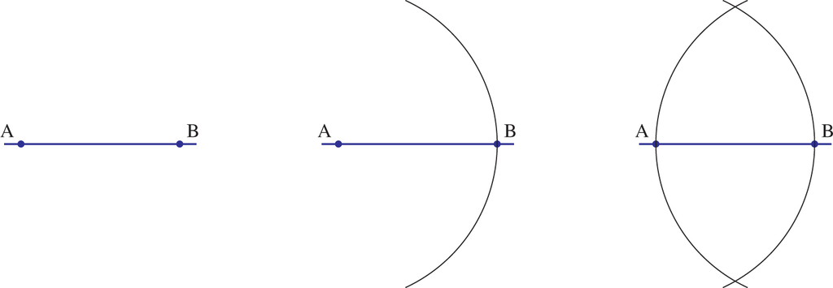

不必将这些圆画满一圈，因为我们只寻找上下的交点;有些几何学家习惯只在上下标记微小弧线，仅足以确定交叉点。设*P*和*Q*为圆的交点;用直尺构造直线*PQ*，即与直线*AB*在*中点C*相交的垂直平分线。

It is not necessary to draw these circles all the way around because we seek only the intersection points above and below; some geometers have the habit of marking only tiny arcs above and below, just enough to determine the intersections. Let *P* and *Q* be the points of intersection of the circles; with the straightedge, construct the line *PQ*, which is the perpendicular bisector intersecting the line *AB* at the midpoint *C*.

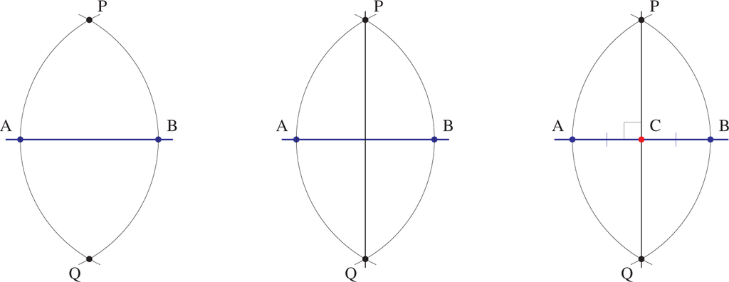

当然，描述一个构造是一回事，像我们这样用数学断言来断言又是另一回事。现在我们证明*C*是*AB*的中点，*PQ*是垂直的平分线。

It is one thing to describe a construction, of course, and quite another to make mathematical assertions about it as we have. So let us now prove that *C* is the midpoint of *AB* and *PQ* is the perpendicular bisector.

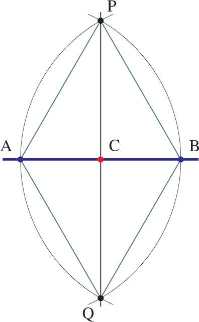

请看右图。由于点*P*和*Q*都位于两个圆上，因此AP*、**AQ*、*BP*和*BQ*线段都是这些圆的半径，因此与*AB*全等，因此彼此也相同。由此可知，三角形△*APQ*与△*BPQ*全余，这可由侧边边全余定理推导出。由于全等三角形的对应部分全等，我们得出角度 ∠*APQ* 与角度 ∠*BPQ* 全等。由此可知，三角形△*APC*与△*BPC*全余，这可由边角边同余定理推断。因此，线段*AC*与*BC*全等，因为对应的全等三角形部分全余，因此*C*是线段*AB*的中点，正如我们所说。此外，角度 ∠*ACP* 与角 ∠*BCP* 全等，因此它们是直角，因为它们合起来形成直角。因此，线 *PQ* 确实如我们所说，是 *AB* 的垂直平分线。QED。

Consider the diagram at right. Because the points *P* and *Q* each lie on both circles, it follows that segments *AP*, *AQ*, *BP*, and *BQ* are all radii of those circles, and therefore congruent to *AB*, and hence also to each other. From this, it follows that triangle △*APQ* is congruent to △*BPQ*, by the side-side-side congruence theorem. Since the corresponding parts of congruent triangles are congruent, we conclude that angle ∠*APQ* is congruent to angle ∠*BPQ*. It follows that triangle △*APC* is congruent to △*BPC*, by the side-angle-side congruence theorem. So segment *AC* is congruent to *BC*, since corresponding parts of congruent triangles are congruent, and therefore *C* is the midpoint of segment *AB*, as we claimed. Further, angle ∠*ACP* is congruent to angle ∠*BCP*, and therefore these are right angles since together they make a straight angle. So line *PQ* is indeed the perpendicular bisector of *AB*, as we have claimed. QED.

也许读者见过两栏证明格式，这种格式起源于20世纪的美国学校，数百万高中生都在使用，第一栏提出新观点，第二栏为每个案例提供理由。这种格式强调数学中的每一个断言都需要证明。与此同时，欧几里得用散文风格写《*原论*》，与我之前写的风格不相上下。但实际上，特别是在构造垂直平分面时，欧几里得的进展与阿波罗尼乌斯和我所说的略有不同：他首先证明可以在任意线段上构造等边三角形（命题I.1）;随后他利用这一（及其他发展）证明了角度可以被一分为二（I.9）;最后，他将这些组合成平分段（I.10）。

Perhaps the reader has seen the two-column proof format, a format arising in twentieth-century American schools and used by millions of high schoolers, in which new assertions are made in the first column, with justification in every case provided in the second column. This format emphasizes the view that every assertion in mathematics requires justification. Meanwhile, Euclid wrote his *Elements* in a prose style, not far from what I wrote previously. But actually, to construct perpendicular bisectors in particular, Euclid proceeds a bit differently than Apollonius and I have: he first proves that one may construct an equilateral triangle on any segment (proposition I.1); he then uses this (and other developments) to prove that angles can be bisected (I.9); and finally, he combines these to bisect segments (I.10).

### **通过对称性进行现代方法** **Contemporary approach via symmetries**

尽管欧几里得证明模型取得了巨大成功，当代几何学家通常更倾向于基于笼统一般对称原则的论证，这些原则被认为表达了比特定构造细节更为基础的几何思想。或许可以这样论证：给定线段*AB*，通过实际的垂直平分线反射平面，这一过程交换*了A*和*B*，从而交换了两个圆，从而固定了交点*P*和*Q*。因此，这些点必须位于垂直平分线上，因此*PQ是*垂直平分线，*C是中*点。

Despite the enormous success of the Euclidean proof model, contemporary geometers might typically prefer an argument based on sweeping general symmetry principles, which are held to express more fundamental geometric ideas than the details of a particular construction. Perhaps one might argue like this: Given segment *AB*, reflect the plane through the actual perpendicular bisector, a process that swaps *A* and *B* and therefore swaps the two circles and therefore fixes the points *P* and *Q* of intersection. These points must therefore lie on the perpendicular bisector, and so *PQ is* the perpendicular bisector, and therefore *C* is the midpoint.

通过这种方式，人们可以通过全等对称的基本性质来理解几何，而不是纠结于构造图的偶然细节。对称性原理使得一眼就能看出*PQ*是垂直平分线。

In this way, one understands the geometry by means of fundamental properties of congruence symmetries, rather than getting caught up in incidental details of a construction diagram. The symmetry principles allow one to see essentially at a glance that *PQ* is the perpendicular bisector.

费利克斯·克莱因（1872年）在其教授论文中，建立了后来被称为*埃尔朗根规划*（以他曾在埃尔朗根-纽伦堡大学命名），通过其变换群及相关不变量来理解和分析几何空间。几何性质通过这些变换得以保持，反之（且重要的是）所有变换所保持的特征都被视为几何性质。欧几里得平面通过平移、旋转和通过直线反射获得同余，这些都通过最多三次反射的连续实现。这些变换保持度量性质，而几何相似性意味着我们也可以允许缩放变换;定向平面几何排除反射，因为反射不保留手性;射影几何有其对应的变换群。这种方法统一了对多样几何的研究，最终导致了抽象结构主义的几何方法，通过精确指定其对称群来定义“几何”，这些对称性确定了对应的全余概念及其伴随的几何不变量。

Felix Klein (1872), in his professorial dissertation, established what has become known as the *Erlangen program* (named after the University of Erlangen-Nürnberg, where he worked), by which we are to understand and analyze a geometric space by means of its group of transformations and related invariants. Geometric properties are preserved by these transformations, and conversely (and importantly) any feature preserved by all transformations is deemed geometric. The Euclidean plane has congruences by translation, by rotation, and by reflection through a line, and these are all realized by a succession of at most three reflections. These transformations preserve metric properties, whereas geometric similarity means that we would also allow scaling transformations; oriented plane geometry rules out reflections, since those do not preserve handedness; and projective geometry has its own corresponding transformation groups. This approach unified the study of diverse geometries and led ultimately to an abstract structuralist approach to geometry, where one defines “a geometry” by exactly specifying its group of symmetries, which determine a corresponding congruence concept and accompanying geometric invariants.

### **可折叠罗盘** **Collapsible compasses**

让我们转向指南针使用中一个有争议的问题（至少曾经是有争议的）。也就是说，按照使用指南针的常规方式，将圆规的指点放在*点A*，绘图工具放在*B*点，然后描绘以*A*为中心、半径为*AB*的圆。然而，有时不直接构造这个特定的圆，而是构造一个半径相同 |*AB*|中心在某个可能较远的点*C*：

Let us turn to a certain controversial issue in the use of the compass (at least it was controversial at one time). Namely, in the usual manner of using a compass, one places the point of the compass at a point *A* and the drawing implement at *B* and then traces out the circle centered at *A* and having radius *AB*. It occasionally happens to be convenient, however, not to construct this particular circle, but to construct instead a circle of this same radius |*AB*| centered at some other point *C*, perhaps some distance away:

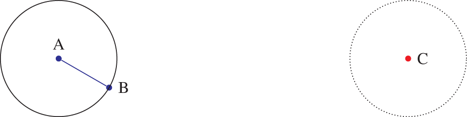

实际上，用一种常见的刚性圆规（抬起时保持半径）很容易实现，因为我们只需测量段 *AB*，然后拿起圆规并将其置于 *C*，构造半径为 |*AB*|中心为*C*。因此，我们在*点C*处复制长度*AB*。这合理吗？那么，这里的*合法性*意味着什么？这种罗盘的使用似乎并未直接得到欧几里得公理的授权，因为虽然欧几里得的第三公设指出每个线段都是圆的半径，但并没有公理表明每个点*C*都是与给定线段*AB*同余的半径圆的中心。因此，人们担心允许这种非标准的构造方法会使所用证明失效。

In practice, this is an easy matter to achieve with a common type of rigid compass, one that holds its radius when lifted, since we simply measure the segment *AB* and then pick up the compass and place it at *C*, constructing the circle of radius |*AB*| centered at *C*. Thus, we make a copy of the length *AB* at the point *C*. Is this legitimate? And what does *legitimacy* mean here? Such a compass use seems not directly authorized by Euclid’s axioms, for while Euclid’s postulate 3 states that every line segment is the radius of a circle, there is no axiom stating that every point *C* is the center of a circle of radius congruent to a given line segment *AB*. The worry, therefore, would be that allowing such a nonstandard construction method would invalidate the proofs in which it was used.

欧几里得时代的谨慎几何学家反对他们认为这是对直尺和圆规可构造性的腐蚀，坚持使用可折叠圆规，这种圆规只有在画圆时施加轻微压力时*才保持*半径，抬起时会塌陷。他们这样做正是为了防止令人反感的使用方式。

Cautious geometers in Euclid’s day objected to what they viewed as a corruption of straightedge-and-compass constructibility and insisted upon the use of *collapsible* compasses, which hold their radius only while under the slight pressure of drawing a circle, collapsing when lifted. They did so specifically to prevent the objectionable manner of use.

但让我们证明，即使只用传统方式使用圆规，我们仍然可以总能构*造C处*所需的圆。这被称为*罗盘等价定理*，由欧几里得在*《几何论*》命题I.2中证明，尽管欧几里得的构造与我这里给出的不同：

But let us show that we can nevertheless always construct the desired circle at *C*, even if we use the compass only in the customary manner. This has become known as the *compass equivalence theorem*, and it was proved by Euclid in the *Elements*, proposition I.2, although Euclid’s construction is different than the one I shall give here:

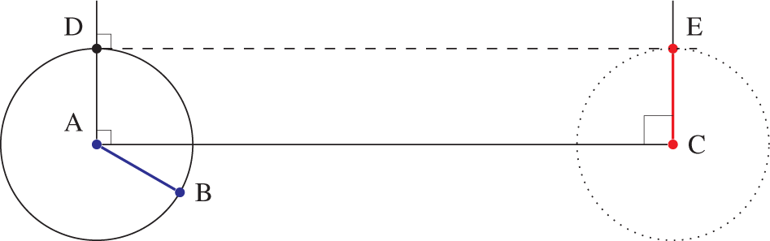

给定线*段AB*和点*C*，构造直线*AC*、该直线在*A*和*C*处的垂直线，以及以*A*为中心的圆包含*B*。设*D*为圆*与A处*垂直面的交点，构造一个垂直于*D*处的垂直*点。*设*E*为所得直线与在*C*处构造的垂直直线的交点。由于*ADEC*是一个矩*形，*AB与*AD*全余，因此段*CE*与*AB*全等，符合预期。（与此同时，有充分理由更倾向于采用不同的构造和论证，读者将在问题4.1中发现。）

Given segment *AB* and point *C*, construct the line *AC*, the perpendiculars to this line at *A* and at *C*, and the circle centered at *A* containing *B*. Let *D* be the intersection of the circle with the perpendicular at *A*, and construct a perpendicular to *AD* at *D*. Let *E* be the intersection of the resulting line with the perpendicular line constructed at *C*. Since *ADEC* is a rectangle and *AB* is congruent to *AD*, it follows that segment *CE* is congruent to *AB*, as desired. (Meanwhile, there are sound reasons to prefer a different construction and argument for this theorem, which the reader will discover in question 4.1.)

罗盘等价定理表明，我们实际上可以将段*AB*复制到*点C*，同时仅使用指南针的惯用方式，而不将其用作存储或测量工具。鉴于此，关于折叠罗盘的谨慎反对可能显得有些不妥，因为任何使用禁止罗盘的建筑都可以仅用普通用途完成。那为什么反对？

The compass equivalence theorem shows that we are in fact enabled to copy segment *AB* to the point *C*, while employing only the customary use of the compass and without using it as a memory storage or measuring device. In light of this, the cautious objections concerning collapsible compasses might seem misplaced, as any construction undertaken with the forbidden compass use can be carried out with only the ordinary use. So why object?

### **可构造点与可构造平面** **Constructible points and the constructible plane**

人们自然会询问自己建筑方法的强大性和局限性。假设某种看似几何合理的非标准构造方法，却无法与普通的直尺和圆规模拟。我们会如何看待它？给定一个几何图形，我们到底可以用直尺和圆规构造哪些其他点或图形？

One naturally inquires about the power and limitations of one’s construction methods. Suppose that some other nonstandard construction method, which might have seemed geometrically sound, turned out not to be simulable with the ordinary straightedge and compass. How would we regard it? And given a geometric figure, exactly which other points or figures are we able to construct with straightedge and compass?

让我们开始实施普遍的建筑过程，系统且全面地用直尺和圆规完成所有可能的建筑。我们从两个点*A*和*B*开始，建立单位距离：

Let us begin to carry out the universal construction process, systematically and exhaustively carrying out all possible constructions with straightedge and compass. We begin with two points *A* and *B*, establishing a unit distance:

[figure not shown]

用直尺，我们可以构造连接它们的直线;用圆规，我们可以构造两个以它们为中心的圆，半径为该段。这些圆与直线相交，形成4个额外的交点，总共6个点：

With the straightedge, we may construct the line joining them; and with the compass, we may construct the two circles centered at each of them, having that segment as radius. These circles and the line intersect each other, creating 4 additional points of intersection and making 6 points in all:

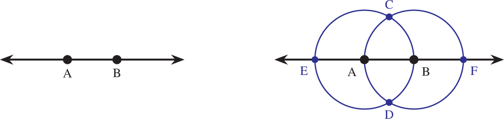

下一关会爆发，新增点数。即利用这6个点，我们可以形成9条新线和14个新圆，这些图形在许多新建的点中相交，总共形成203个点：

The next stage explodes with newly constructed points. Namely, using those 6 points, we may form 9 new lines and 14 new circles, and these figures intersect in many newly constructed points, providing 203 points altogether:

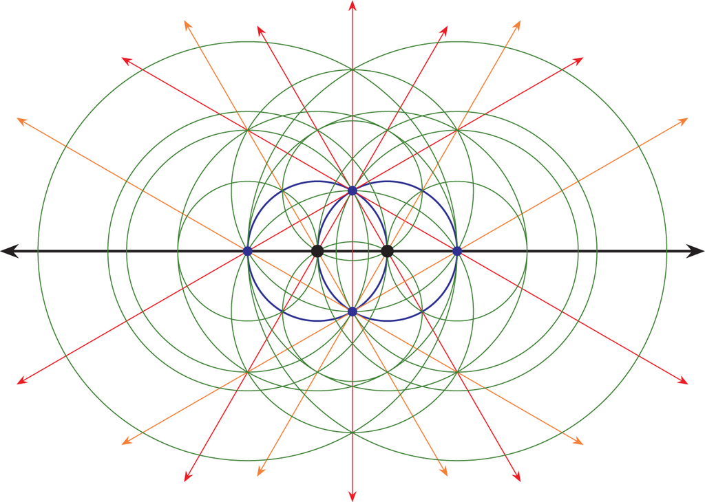

在后续阶段，利用直尺和圆规与这203个点，我们再次构造所有可能的直线和圆，并再次找到交点。在无穷无尽的有限阶段中，我们生成了所有*可构造点*，构成*了可构造平面*。

In a further subsequent stage, using the straightedge and compass with these 203 points, we again construct all possible lines and all possible circles and again find the resulting points of intersection. In an endless series of finite stages, we thereby generate all the *constructible points*, which constitute the *constructible plane*.

由于每个阶段只会产生有限数量的新线和圆，且这些线和圆最多有有限多个新交叉点，归纳可得出普遍构造过程中的每个阶段只有有限多个点。在Hamkins（2019）中，我引入*了构造性序列*，从2、6、203开始，并在每个阶段继续使用我刚才描述的普遍构造过程中出现的点数。起初，我们不知道序列下一个数字的确切值。我们甚至不知道下一阶段用203个点出现的线和圆的确切数量。然而，利用精确的计算机代数和大量计算时间，Pace Nielsen（2019）发现这203个点恰好形成了17562条直线和32719个不同的圆;经过大量计算努力（连续6天的高强度计算机运行时间，分布在3台机器上的6个进程），Teofil Camarasu发现这些线和圆在所有不同的交点1723816861都能产生。因此，可构造性序列继续：

Because only finitely many new lines and circles are created at each stage, and these have at most finitely many new intersection points, it follows inductively that every stage in the universal construction process has only finitely many points. In Hamkins (2019), I introduced the *constructibility sequence*, beginning 2, 6, 203, and continuing at each stage with the number of points arising in the universal construction process that I have just described. At first, we didn’t know the exact value of the next number on the sequence. We did not even know the exact number of lines and circles that arise at the next stage using the 203 points. Nevertheless, using exact computer algebra and many hours of computer processing time, Pace Nielsen (2019) found that the 203 points formed exactly 17562 lines and 32719 distinct circles; and with enormous further computational effort (6 continuous days of intense computer running time split amongst 6 processes on 3 machines), Teofil Camarasu found that these lines and circles produce in all 1723816861 distinct points of intersection. Thus, the constructibility sequence continues:

[figure not shown]

构造性序列现已收录于Hamkins（2020b）的《整数序列在线百科全书》中。

The constructructiblity sequence now appears in the Online Encyclopedia of Integer Sequences, Hamkins (2020b).

无论如何，这些可构造点通过该过程在一个可数的有限阶段层级中形成，因此只有可数多个可构造点。特别地，由于实数平面R2有不可数的点，必然存在一些不可构造的点。平面上的每个点并非都是可构造的。

In any case, the constructible points are formed by this process in a countable hierarchy of finite stages, and consequently, there are only countably many constructible points. In particular, since the real number plane ℝ<sup>2</sup> has uncountably many points, there must be some nonconstructible points. Not every point in the plane is constructible.

与此同时，可构造平面中的点在直尺和圆规构造下自然闭合，由此可推断该构造平面满足所有欧几里得公理。因此，可以将可构造平面视为一个替代的几何宇宙，从欧几里得构造角度看，它与实数平面<sup>R2</sup>非常相似，但遗漏了一些点。然而，仅凭欧几里得工具，我们仍无法指向任何缺失点的特定位置，因为用这些工具识别该位置，当然就是构造该点。

Meanwhile, the points in the constructible plane are naturally closed under straightedge-and-compass constructions, and from this, it follows that the constructible plane satisfies all the Euclidean axioms. One can thus view the constructible plane as an alternative geometric universe, one very like the real number plane ℝ<sup>2</sup>, so far as Euclidean constructions are concerned, and yet missing some points. Nevertheless, with only the Euclidean tools, we shall remain unable to point to any particular location where a point is missing, since to identify such a location with those tools, of course, would be exactly to construct the point.

### **可构造数与数线** **Constructible numbers and the number line**

正如第一章所述，经典的数量概念本质上是几何性的;一个量是一个几何长度，相对于由两个给定点*A*和*B*之间的线段所提供的单位长度标准。我们将这些点重新命名为0和1，因为我们将连接它们的线段视为一个标准单位长度，包含这些点的直线是*数线*。

The classical concept of quantity, as mentioned in chapter 1, is fundamentally geometric; a quantity is a geometrical length, in relation to a standard of unit length provided by the line segment between two given points *A* and *B*. Let us rename these points as 0 and 1, for we shall think of the line segment joining them as representing a standard unit length, and the line containing these points is the *number line*.

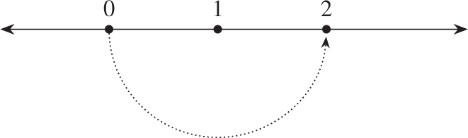

可构造数是数轴上的一点，我们仅用直尺和圆规，能够从点0和1构造出来。例如，我们可以通过将罗盘点置于1，并构造半径为1到0的圆来轻松构造数字2。

A constructible number is a point on the number line that we are able to construct from the points 0 and 1 using the straightedge and compass only. For example, we can easily construct the number 2 by placing the point of our compass at 1 and constructing the circle with radius from 1 to 0.

笛卡尔在*《方法论*》（1637年）附录*《几何*学》中首次研究可构造数，介绍了解析几何的基础思想，通过理解几何形状的代数方程来综合其结构。

Descartes mounted the initial study of constructible numbers in *La Geometrie*, an appendix to *Discourse on the Method* (1637), introducing the foundational ideas of analytic geometry, synthesizing algebra and geometry by understanding geometric shapes in terms of their algebraic equations.

## **4.2 不可构造数** **4.2 Nonconstructible numbers**

从当代视角来看，数学家常将实数连续统与经典数轴上的点联系起来，从这个意义上说，所有可构造数的集合构成了一个域，一个包含所有有理数的实数子域，以及更多。哪些实数是可构造的？每个实数都可以构造吗？

On the contemporary perspective, mathematicians often identify the continuum of real numbers with the points on the classical number line, and in this sense, the collection of all constructible numbers forms a field, a subfield of the real numbers containing every rational number, and far more. Which real numbers are constructible? Is every real number constructible?

答案是否定的。如前所述，只能有可数多个构造数，但根据康托尔定理，实数是不可数的。所以一定存在实数，即数线上的点，我们无法用直尺和圆规构造。

The answer is no. As we have mentioned, there are only countably many constructible numbers, but by Cantor’s theorem, there are uncountably many real numbers. So there must be real numbers, points on the number line, that we cannot construct by straightedge and compass.

尽管这是通过康托尔定理的软证明，但不可构造数的存在早在康托尔之前就已为人所知，这源于埃瓦里斯特·伽罗瓦等人在域扩张思想中发展出的代数深层结果。此外，这种代数式的构造性思维方式为可构造数的本质提供了复杂的信息。让我试着解释一下这个理论。主要观察是，每一个由直尺和圆规构造的新点，都是先前构造的线或圆的交点，这些线或圆具有线性或二次方程。因此，每个新构造的点都是某个线性或二次方程的解，可以用先前构造的数来表示。因此，每个后续构造的数的次数都比之前构造的数为1或2。由此，利用有理域扩张理论，可得出每个可构造数都是有理数域Q上的代数，且该构造数在Q上的次数必须是2的幂，形式为2<sup>*n*</sup>，且对某个*n*。特别地，我们无法构造能解不可约三次方程（次数3）或五次方程（次数5）的数，因为这样的实数对于某个*n*不会有次数2<sup>*n*</sup>。

Although that is a soft proof via Cantor’s theorem, nevertheless the existence of nonconstructible numbers was known even before Cantor as a consequence of deep results in algebra growing out of the field-extension ideas of Évariste Galois and others. Furthermore, this algebraic way of thinking about constructibility provided sophisticated information about the nature of constructible numbers. Let me try to explain a little about this theory. The main observation is that every new point constructed by straightedge and compass arises as a point of intersection of previously constructed lines or circles, and these have linear or quadratic equations. Thus, every newly constructed point is the solution of a certain linear or quadratic equation expressible in terms of previously constructed numbers. Each subsequently constructed number, therefore, has degree 1 or 2 over the previously constructed numbers. From this, using the theory of rational field extensions, it follows that every constructible number is algebraic over the field of rational numbers ℚ, and furthermore, the degree of the constructible number over ℚ must be a power of 2, of the form 2<sup>*n*</sup> for some *n*. In particular, we cannot construct numbers that solve an irreducible cubic (degree 3) or quintic (degree 5) equation, for such a real number will not have degree 2<sup>*n*</sup> for some *n*.